# SVA Model 1

Janou Roubroeks

Nov 2020

## Xi analysis

As inflation of p-values was observed in a previous analysis of baseline diagnosis on Xi, the model will now include surrogate variables.

In this case, surrogate variables have been generated using a model that only included disease status. This has generated 43 SVs, after the exclusion of 1 SVs which correlated with diagnosis.

Several models will be run, with an increasing number of SVs.

Packages used in this analysis: wateRmelon, dplyr, qqman, kableExtra, methylumi.  
Results from this analysis are stored in "/mnt/data1/Janou/AddNeuroMed/XY analysis/Xi/Inflation correction/SVA".

The analysis was run using dasen normalised data, where covariates had been removed from male and female data, and Xi DNA methylation had been calculated.

## ANOVA Models

### Model 1 (1SV)

The ANOVA of diagnosis has been run with 1 SV. Tables of the top 1000 DMPs have been produced for each variable of interest.

#### Top DMPs

**ANOVA:**  
47 probes pass the epigenome-wide significance threshold of 2.4x10-7  
*The top 50 diagnosis associated DMPs:*

| ProbeID | Position | F | p (F) | FDR.Anova | Difference | CI lower | CI upper | pCvM | FDR | Difference | CI lower | CI upper | pCvA | FDR | Difference | CI lower | CI upper | pMvA | FDR | UCSC Gene | UCSC Gene Group | UCSC Relation to CpG Island | Gene Closest TSS | Distance Closest TSS | GREAT Annotation 1 | GREAT Annotation 2 |
| --- | --- | --- | --- | --- | --- | --- | --- | --- | --- | --- | --- | --- | --- | --- | --- | --- | --- | --- | --- | --- | --- | --- | --- | --- | --- | --- |
| cg22822140 | chr X: 153046577 | 62.521 | 5.40e-21 | 5.21e-17 | -0.002 | -0.023 | 0.020 | 0.982 | 1 | -0.091 | -0.113 | -0.069 | 4.76e-14 | 4.59e-10 | -0.089 | -0.111 | -0.067 | 4.81e-14 | 1.77e-10 | SRPK3;SRPK3;SRPK3 | 1stExon;1stExon;1stExon | Island | SRPK3 | 122 | SRPK3 (122) | (NA) |
| cg13009143 | chr X: 100548223 | 48.023 | 3.34e-17 | 1.61e-13 | -0.016 | -0.023 | -0.009 | 3.69e-07 | 1.62e-04 | 0.012 | 0.005 | 0.019 | 1.67e-04 | 0.015 | 0.028 | 0.021 | 0.035 | 4.93e-14 | 1.77e-10 | TAF7L | TSS200 | S_Shore | TAF7L | -164 | TAF7L (-165) | (NA) |
| cg12230162 | chr X: 153046482 | 46.365 | 9.64e-17 | 3.10e-13 | 0.008 | -0.017 | 0.033 | 0.741 | 1 | -0.084 | -0.109 | -0.059 | 1.28e-12 | 4.12e-09 | -0.092 | -0.117 | -0.067 | 5.52e-14 | 1.77e-10 | SRPK3;SRPK3;SRPK3;SRPK3;SRPK3;SRPK3 | 5'UTR;1stExon;1stExon;5'UTR;5'UTR;1stExon | Island | SRPK3 | 27 | SRPK3 (27) | (NA) |
| cg24496423 | chr X: 153046480 | 42.795 | 9.89e-16 | 2.38e-12 | 0.005 | -0.015 | 0.025 | 0.8 | 1 | -0.065 | -0.085 | -0.045 | 5.82e-12 | 1.40e-08 | -0.070 | -0.090 | -0.050 | 1.12e-13 | 2.15e-10 | SRPK3;SRPK3;SRPK3;SRPK3;SRPK3;SRPK3 | 5'UTR;1stExon;1stExon;5'UTR;5'UTR;1stExon | Island | SRPK3 | 25 | SRPK3 (25) | (NA) |
| cg03360001 | chr X: 53453272 | 36.162 | 8.94e-14 | 1.73e-10 | -0.009 | -0.015 | -0.003 | 9.52e-04 | 0.045 | 0.012 | 0.006 | 0.018 | 1.47e-05 | 0.003 | 0.021 | 0.015 | 0.027 | 8.35e-14 | 2.01e-10 | RIBC1;RIBC1 | Body;Body | S_Shelf | RIBC1 | 3434 | SMC1A (-3655) | (NA) |
| cg16152676 | chr X: 10126878 | 35.880 | 1.09e-13 | 1.75e-10 | 0.041 | 0.026 | 0.055 | 9.47e-10 | 2.28e-06 | -0.006 | -0.021 | 0.008 | 0.551 | 1 | -0.047 | -0.062 | -0.033 | 2.13e-12 | 2.93e-09 | CLCN4 | 5'UTR | Island | CLCN4 | 550 | CLCN4 (1894) | MID1 (724930) |
| cg12468189 | chr X: 153046767 | 33.655 | 5.24e-13 | 7.22e-10 | -0.024 | -0.039 | -0.008 | 9.86e-04 | 0.046 | -0.053 | -0.069 | -0.038 | 2.54e-13 | 1.22e-09 | -0.030 | -0.045 | -0.015 | 2.00e-05 | 0.004 | SRPK3;SRPK3;SRPK3 | Body;Body;Body | Island | SRPK3 | 312 | SRPK3 (312) | (NA) |
| cg24605338 | chr X: 17395856 | 31.095 | 3.31e-12 | 4.00e-09 | -0.037 | -0.048 | -0.026 | 1.23e-12 | 1.18e-08 | -0.018 | -0.030 | -0.007 | 4.92e-04 | 0.033 | 0.019 | 0.008 | 0.030 | 2.76e-04 | 0.025 | NHS | Body | S_Shore | NHS | 2314 | SCML1 (-359735) | NHS (2314) |
| cg21252909 | chr X: 30326328 | 30.787 | 4.15e-12 | 4.14e-09 | 0.041 | 0.017 | 0.064 | 1.70e-04 | 0.013 | -0.036 | -0.060 | -0.013 | 0.001 | 0.06 | -0.077 | -0.100 | -0.054 | 1.58e-12 | 2.54e-09 | NR0B1 | 1stExon | N_Shore | NR0B1 | 1167 | NR0B1 (1166) | (NA) |
| cg09768654 | chr X: 153046386 | 30.742 | 4.29e-12 | 4.14e-09 | 0.013 | -0.01 | 0.035 | 0.385 | 1 | -0.058 | -0.081 | -0.035 | 4.19e-08 | 3.37e-05 | -0.071 | -0.094 | -0.048 | 1.89e-11 | 2.28e-08 | SRPK3;SRPK3;SRPK3 | TSS200;TSS200;TSS200 | Island | SRPK3 | -69 | SRPK3 (-69) | (NA) |
| cg16529483 | chr X: 153046451 | 30.587 | 4.80e-12 | 4.21e-09 | -0.004 | -0.029 | 0.021 | 0.929 | 1 | -0.073 | -0.098 | -0.048 | 3.04e-10 | 4.19e-07 | -0.069 | -0.094 | -0.045 | 1.16e-09 | 1.01e-06 | SRPK3;SRPK3;SRPK3 | TSS200;TSS200;TSS200 | Island | SRPK3 | -4 | SRPK3 (-4) | (NA) |
| cg19280671 | chr X: 149013642 | 29.509 | 1.06e-11 | 8.43e-09 | 0.017 | 0.011 | 0.023 | 4.44e-10 | 1.43e-06 | 0.001 | -0.005 | 0.007 | 0.884 | 1 | -0.016 | -0.022 | -0.010 | 4.95e-09 | 3.67e-06 | MAGEA8;MAGEA8;MAGEA8 | Body;Body;Body |  | MAGEA8 | 596 | MAMLD1 (-517908) | MAGEA8 (3702) |
| cg19938385 | chr X: 107020894 | 29.417 | 1.14e-11 | 8.43e-09 | -0.045 | -0.063 | -0.026 | 1.60e-07 | 8.57e-05 | -0.058 | -0.077 | -0.039 | 2.91e-11 | 5.61e-08 | -0.014 | -0.032 | 0.005 | 0.198 | 1 |  |  | S_Shore | TSC22D3 | -1692 | TSC22D3 (-1878) | (NA) |
| cg17003204 | chr X: 102861456 | 27.199 | 5.95e-11 | 4.10e-08 | -0.034 | -0.045 | -0.022 | 2.55e-10 | 1.23e-06 | -0.007 | -0.019 | 0.005 | 0.351 | 1 | 0.027 | 0.016 | 0.039 | 3.18e-07 | 1.70e-04 | TCEAL3;TCEAL3 | TSS1500;TSS1500 | N_Shore | TCEAL3 | -1377 | TCEAL3 (-1377) | (NA) |
| cg25896901 | chr X: 125300481 | 26.138 | 1.33e-10 | 8.56e-08 | 0.013 | -0.013 | 0.039 | 0.484 | 1 | -0.062 | -0.089 | -0.036 | 3.35e-07 | 1.79e-04 | -0.075 | -0.101 | -0.049 | 5.28e-10 | 5.09e-07 | DCAF12L2 | TSS1500 | S_Shore | DCAF12L2 | -401 | DCAF12L1 (386360) | (NA) |
| cg17405188 | chr X: 73164102 | 26.005 | 1.47e-10 | 8.88e-08 | 0.008 | 0.003 | 0.013 | 0.001 | 0.047 | 0.016 | 0.011 | 0.021 | 5.50e-11 | 8.84e-08 | 0.008 | 0.003 | 0.013 | 9.14e-04 | 0.057 | LOC554203 | TSS200 | Island | JPX | -56 | ZCCHC13 (-359922) | CHIC1 (381119) |
| cg22926378 | chr X: 6144633 | 25.723 | 1.83e-10 | 1.04e-07 | 0.015 | 0.008 | 0.022 | 5.94e-06 | 0.001 | -0.006 | -0.013 | 0.001 | 0.125 | 0.729 | -0.021 | -0.029 | -0.014 | 2.38e-10 | 2.55e-07 | NLGN4X;NLGN4X | 5'UTR;5'UTR | Island | NLGN4X | 483 | NLGN4X (2072) | (NA) |
| cg07069575 | chr X: 49688313 | 22.917 | 1.61e-09 | 8.43e-07 | 0.010 | -0.002 | 0.023 | 0.106 | 0.674 | -0.023 | -0.036 | -0.011 | 3.64e-05 | 0.005 | -0.034 | -0.046 | -0.022 | 1.30e-09 | 1.04e-06 | CLCN5;CLCN5 | 5'UTR;5'UTR | S_Shore | CLCN5 | 1089 | CLCN5 (1089) | AKAP4 (277350) |
| cg06452970 | chr X: 13835264 | 22.874 | 1.66e-09 | 8.43e-07 | 0.049 | 0.03 | 0.068 | 2.07e-08 | 1.77e-05 | 0.005 | -0.014 | 0.024 | 0.809 | 1 | -0.044 | -0.063 | -0.025 | 4.13e-07 | 1.99e-04 | GPM6B;GPM6B;GPM6B;GPM6B;GPM6B;GPM6B;GPM6B | 1stExon;5'UTR;5'UTR;Body;5'UTR;1stExon;1stExon |  | GPM6B | 50 | GPM6B (49) | (NA) |
| cg23914849 | chr X: 52950051 | 22.380 | 2.45e-09 | 1.18e-06 | 0.003 | 5.06e-04 | 0.005 | 0.012 | 0.228 | 0.007 | 0.004 | 0.009 | 1.12e-09 | 1.34e-06 | 0.004 | 0.001 | 0.006 | 4.41e-04 | 0.036 |  |  | Island | FAM156A | 13799 | FAM156B (21967) | FAM156A (74599) |
| cg17219209 | chr X: 149009840 | 22.180 | 2.87e-09 | 1.32e-06 | 0.022 | 0.014 | 0.030 | 8.59e-09 | 1.04e-05 | 0.005 | -0.004 | 0.013 | 0.401 | 1 | -0.017 | -0.025 | -0.009 | 4.49e-06 | 0.001 | MAGEA8;MAGEA8;MAGEA8 | TSS200;TSS200;TSS200 |  | MAGEA8 | -100 | MAGEA8 (-100) | (NA) |
| cg16122592 | chr X: 26210712 | 22.066 | 3.14e-09 | 1.38e-06 | -0.030 | -0.042 | -0.019 | 8.39e-09 | 1.04e-05 | -0.025 | -0.036 | -0.013 | 3.15e-06 | 9.81e-04 | 0.006 | -0.006 | 0.017 | 0.483 | 1 | MAGEB6 | 5'UTR |  | MAGEB6 | 156 | MAGEB6 (156) | (NA) |
| cg26484667 | chr X: 2733164 | 21.782 | 3.93e-09 | 1.65e-06 | -0.030 | -0.042 | -0.018 | 8.60e-08 | 5.53e-05 | -0.002 | -0.014 | 0.011 | 0.949 | 1 | 0.028 | 0.016 | 0.040 | 3.48e-07 | 1.77e-04 | XG;XG;XG | 3'UTR;3'UTR;3'UTR |  | GYG2 | -13698 | GYG2 (-13698) | XG (63072) |
| cg04710661 | chr X: 2848381 | 21.633 | 4.42e-09 | 1.78e-06 | 0.006 | -4.87e-04 | 0.013 | 0.075 | 0.575 | 0.019 | 0.012 | 0.026 | 3.44e-09 | 3.69e-06 | 0.012 | 0.006 | 0.019 | 6.73e-05 | 0.009 | ARSD;ARSD | TSS1500;TSS1500 | S_Shore | ARSD | -965 | ARSD (-966) | (NA) |
| cg09513996 | chr X: 48685182 | 21.470 | 5.03e-09 | 1.94e-06 | 0.005 | -0.009 | 0.018 | 0.684 | 1 | -0.03 | -0.043 | -0.016 | 2.05e-06 | 6.83e-04 | -0.035 | -0.048 | -0.021 | 2.27e-08 | 1.46e-05 |  |  | Island | ERAS | -2100 | ERAS (-2100) | (NA) |
| cg15907464 | chr X: 70712790 | 21.414 | 5.26e-09 | 1.94e-06 | -0.035 | -0.048 | -0.022 | 2.13e-09 | 4.11e-06 | -0.017 | -0.030 | -0.005 | 0.005 | 0.141 | 0.018 | 0.005 | 0.030 | 0.003 | 0.126 | BCYRN1;INGX | Body;TSS200 | Island | INGX | -186 | OGT (-40121) | TAF1 (126677) |
| cg11179997 | chr X: 119125670 | 21.374 | 5.43e-09 | 1.94e-06 | 0.028 | 0.017 | 0.040 | 1.09e-07 | 6.20e-05 | 0.002 | -0.010 | 0.013 | 0.946 | 1 | -0.027 | -0.038 | -0.015 | 4.63e-07 | 2.08e-04 |  |  | Island | AK123976 | -44530 | NKAP (-47936) | RHOXF2 (86036) |
| cg17513789 | chr X: 73073251 | 20.702 | 9.29e-09 | 3.11e-06 | -0.045 | -0.061 | -0.028 | 4.20e-09 | 6.75e-06 | -0.02 | -0.037 | -0.003 | 0.014 | 0.256 | 0.025 | 0.008 | 0.041 | 0.001 | 0.079 | XIST | TSS1500 |  | XIST | -663 | ZCCHC13 (-450773) | CHIC1 (290268) |
| cg04768884 | chr X: 19443172 | 20.694 | 9.36e-09 | 3.11e-06 | 0.007 | -0.007 | 0.021 | 0.475 | 1 | 0.036 | 0.022 | 0.050 | 2.99e-08 | 2.75e-05 | 0.029 | 0.015 | 0.043 | 4.95e-06 | 0.001 | MAP3K15 | Body |  | MAP3K15 | 35099 | PDHA1 (81162) | MAP3K15 (90206) |
| cg00190642 | chr X: 103268431 | 20.500 | 1.09e-08 | 3.51e-06 | -0.013 | -0.028 | 0.002 | 0.101 | 0.661 | 0.027 | 0.012 | 0.042 | 1.51e-04 | 0.014 | 0.040 | 0.025 | 0.055 | 7.56e-09 | 5.21e-06 | H2BFWT;MIR1256 | TSS200;Body | Island | H2BFWT | -175 | H2BFWT (-176) | (NA) |
| cg09661041 | chr X: 153141905 | 20.263 | 1.32e-08 | 4.12e-06 | -0.010 | -0.034 | 0.015 | 0.617 | 1 | -0.061 | -0.086 | -0.037 | 6.14e-08 | 4.56e-05 | -0.052 | -0.076 | -0.028 | 3.38e-06 | 8.82e-04 | L1CAM;L1CAM;L1CAM | TSS1500;TSS1500;TSS1500 |  | L1CAM | -506 | L1CAM (-507) | (NA) |
| cg24352688 | chr X: 13751727 | 19.988 | 1.65e-08 | 4.97e-06 | 0.001 | -0.006 | 0.008 | 0.912 | 1 | 0.017 | 0.010 | 0.024 | 2.21e-07 | 1.33e-04 | 0.016 | 0.009 | 0.022 | 9.82e-07 | 3.64e-04 | TRAPPC2;OFD1;TRAPPC2;TRAPPC2 | 5'UTR;TSS1500;5'UTR;5'UTR | N_Shore | TRAPPC2 | 1027 | OFD1 (-1104) | TRAPPC2 (1026) |
| cg08630881 | chr X: 70713213 | 19.922 | 1.74e-08 | 5.09e-06 | -0.029 | -0.04 | -0.018 | 1.25e-08 | 1.20e-05 | -0.02 | -0.031 | -0.008 | 1.47e-04 | 0.014 | 0.009 | -0.002 | 0.020 | 0.116 | 0.85 | BCYRN1;INGX | Body;TSS1500 | S_Shore | INGX | -609 | OGT (-39698) | TAF1 (127100) |
| cg14917571 | chr X: 79269151 | 19.619 | 2.22e-08 | 6.31e-06 | -0.051 | -0.071 | -0.032 | 9.66e-09 | 1.04e-05 | -0.024 | -0.044 | -0.004 | 0.012 | 0.234 | 0.027 | 0.008 | 0.047 | 0.003 | 0.123 | TBX22;TBX22 | TSS1500;TSS1500 |  | TBX22 | -1103 | ITM2A (-646103) | TBX22 (-8590) |
| cg01737010 | chr X: 101772014 | 18.803 | 4.32e-08 | 1.19e-05 | 0.007 | -0.003 | 0.017 | 0.193 | 0.861 | -0.018 | -0.027 | -0.008 | 1.47e-04 | 0.014 | -0.025 | -0.035 | -0.015 | 3.81e-08 | 2.29e-05 | TMSB15A | TSS1500 | S_Shore | TMSB15A | -315 | TMSB15A (-316) | (NA) |
| cg04817724 | chr X: 103809991 | 18.696 | 4.71e-08 | 1.26e-05 | 0.053 | 0.033 | 0.074 | 2.20e-08 | 1.77e-05 | 0.024 | 0.003 | 0.045 | 0.022 | 0.317 | -0.029 | -0.050 | -0.009 | 0.002 | 0.109 | IL1RAPL2 | TSS1500 | Island | IL1RAPL2 | -1004 | IL1RAPL2 (-1004) | (NA) |
| cg00805156 | chr X: 3264341 | 18.612 | 5.04e-08 | 1.32e-05 | 0.035 | 0.018 | 0.052 | 4.64e-06 | 0.001 | 0.04 | 0.023 | 0.057 | 2.96e-07 | 1.68e-04 | 0.005 | -0.012 | 0.021 | 0.784 | 1 | MXRA5 | 5'UTR | Island | MXRA5 | 343 | MXRA5 (342) | (NA) |
| cg13788827 | chr X: 12990209 | 18.459 | 5.72e-08 | 1.45e-05 | -0.007 | -0.017 | 0.002 | 0.147 | 0.773 | 0.016 | 0.006 | 0.025 | 2.75e-04 | 0.021 | 0.023 | 0.014 | 0.032 | 4.24e-08 | 2.40e-05 |  |  | N_Shelf | TMSB4X | -3016 | TMSB4X (-3016) | (NA) |
| cg09953945 | chr X: 150345040 | 18.233 | 6.88e-08 | 1.70e-05 | -0.027 | -0.037 | -0.016 | 2.99e-08 | 2.22e-05 | -0.015 | -0.025 | -0.004 | 0.004 | 0.123 | 0.012 | 0.002 | 0.023 | 0.019 | 0.365 | GPR50 | TSS200 | N_Shore | GPR50 | -15 | GPR50 (-15) | (NA) |
| cg22574818 | chr X: 55479616 | 18.201 | 7.07e-08 | 1.70e-05 | -0.033 | -0.056 | -0.010 | 0.003 | 0.096 | -0.059 | -0.082 | -0.036 | 3.14e-08 | 2.75e-05 | -0.027 | -0.050 | -0.004 | 0.018 | 0.347 | MAGEH1;MAGEH1 | 1stExon;3'UTR |  | MAGEH1 | 1079 | MAGEH1 (1079) | USP51 (36014) |
| cg08464958 | chr X: 2852845 | 18.037 | 8.08e-08 | 1.90e-05 | -0.022 | -0.032 | -0.013 | 3.31e-07 | 1.52e-04 | -0.003 | -0.013 | 0.006 | 0.666 | 1 | 0.019 | 0.009 | 0.028 | 1.61e-05 | 0.003 | ARSE | 3'UTR |  | ARSD | -5429 | ARSD (-5430) | ARSE (29648) |
| cg00123001 | chr X: 13395880 | 17.753 | 1.02e-07 | 2.35e-05 | -0.017 | -0.025 | -0.009 | 3.87e-06 | 0.001 | -0.019 | -0.027 | -0.010 | 9.77e-07 | 3.77e-04 | -0.001 | -0.009 | 0.007 | 0.928 | 1 |  |  | N_Shore | LOC100133123 | 42521 | EGFL6 (-191813) | ATXN3L (-57363) |
| cg02329520 | chr X: 153740317 | 17.634 | 1.13e-07 | 2.53e-05 | -0.014 | -0.022 | -0.006 | 9.43e-05 | 0.009 | -0.019 | -0.027 | -0.011 | 1.39e-07 | 9.57e-05 | -0.005 | -0.013 | 0.003 | 0.279 | 1 | FAM3A;FAM3A;FAM3A;FAM3A;FAM3A | Body;Body;Body;Body;Body | N_Shelf | FAM3A | 4249 | SLC10A3 (-21316) | FAM3A (4248) |
| cg25433595 | chr X: 100183764 | 17.540 | 1.22e-07 | 2.67e-05 | 0.046 | 0.028 | 0.065 | 9.18e-08 | 5.53e-05 | 0.032 | 0.013 | 0.051 | 3.33e-04 | 0.025 | -0.014 | -0.033 | 0.004 | 0.168 | 0.967 | XKRX;XKRX | 5'UTR;1stExon | N_Shore | XKRX | 134 | XKRX (133) | (NA) |
| cg24834461 | chr X: 153637645 | 17.473 | 1.29e-07 | 2.76e-05 | 0.017 | 0.01 | 0.024 | 8.87e-08 | 5.53e-05 | 0.012 | 0.005 | 0.019 | 4.50e-04 | 0.031 | -0.006 | -0.013 | 0.001 | 0.141 | 0.917 | DNASE1L1;DNASE1L1;DNASE1L1;DNASE1L1 | TSS200;5'UTR;5'UTR;5'UTR | N_Shelf | DNASE1L1 | -70 | TAZ (-2231) | (NA) |
| cg06068202 | chr X: 150343148 | 17.392 | 1.38e-07 | 2.89e-05 | 0.038 | 0.019 | 0.057 | 1.62e-05 | 0.003 | 0.045 | 0.025 | 0.064 | 4.95e-07 | 2.39e-04 | 0.007 | -0.012 | 0.026 | 0.678 | 1 |  |  | Island | GPR50 | -1907 | GPR50 (-1907) | (NA) |
| cg08333400 | chr X: 10126881 | 16.920 | 2.04e-07 | 4.18e-05 | 0.055 | 0.029 | 0.081 | 3.67e-06 | 9.83e-04 | 7.58e-04 | -0.026 | 0.027 | 0.997 | 1 | -0.055 | -0.081 | -0.029 | 4.51e-06 | 0.001 | CLCN4 | 5'UTR | Island | CLCN4 | 553 | CLCN4 (1897) | MID1 (724927) |
| ch.X.153018199F | chr X: 153365005 | 16.671 | 2.50e-07 | 5.03e-05 | -0.011 | -0.015 | -0.006 | 2.54e-07 | 1.22e-04 | -0.003 | -0.008 | 0.001 | 0.221 | 0.938 | 0.008 | 0.003 | 0.012 | 3.60e-04 | 0.032 |  |  | S_Shore | MECP2 | -1817 | MECP2 (-1818) | (NA) |
| cg14306994 | chr X: 49019804 | 16.528 | 2.82e-07 | 5.56e-05 | 0.032 | 0.019 | 0.046 | 1.72e-07 | 8.73e-05 | 0.012 | -0.001 | 0.026 | 0.081 | 0.589 | -0.020 | -0.033 | -0.007 | 0.002 | 0.085 | MAGIX;MAGIX;MAGIX;MAGIX | Body;Body;Body;TSS1500 | Island | MAGIX | -316 | GPKOW (-39726) | PLP2 (-8379) |
| cg22090245 | chr X: 99661860 | 16.291 | 3.44e-07 | 6.64e-05 | -0.007 | -0.034 | 0.020 | 0.833 | 1 | 0.053 | 0.026 | 0.081 | 2.60e-05 | 0.004 | 0.060 | 0.033 | 0.087 | 1.39e-06 | 4.20e-04 | PCDH19;PCDH19 | 1stExon;1stExon | Island | PCDH19 | 3411 | PCDH19 (3410) | (NA) |

**CTL vs MCI:**  
19 probes pass the epigenome-wide significance threshold of 2.4x10-7

*The top 50 CTL vs MCI associated DMPs:*

| ProbeID | Position | F | p (F) | FDR.Anova | Difference | CI lower | CI upper | pCvM | FDR | Difference | CI lower | CI upper | pCvA | FDR | Difference | CI lower | CI upper | pMvA | FDR | UCSC Gene | UCSC Gene Group | UCSC Relation to CpG Island | Gene Closest TSS | Distance Closest TSS | GREAT Annotation 1 | GREAT Annotation 2 |
| --- | --- | --- | --- | --- | --- | --- | --- | --- | --- | --- | --- | --- | --- | --- | --- | --- | --- | --- | --- | --- | --- | --- | --- | --- | --- | --- |
| cg24605338 | chr X: 17395856 | 31.095 | 3.31e-12 | 4.00e-09 | -0.037 | -0.048 | -0.026 | 1.23e-12 | 1.18e-08 | -0.018 | -0.030 | -0.007 | 4.92e-04 | 0.033 | 0.019 | 0.008 | 0.03 | 2.76e-04 | 0.025 | NHS | Body | S_Shore | NHS | 2314 | SCML1 (-359735) | NHS (2314) |
| cg17003204 | chr X: 102861456 | 27.199 | 5.95e-11 | 4.10e-08 | -0.034 | -0.045 | -0.022 | 2.55e-10 | 1.23e-06 | -0.007 | -0.019 | 0.005 | 0.351 | 1 | 0.027 | 0.016 | 0.039 | 3.18e-07 | 1.70e-04 | TCEAL3;TCEAL3 | TSS1500;TSS1500 | N_Shore | TCEAL3 | -1377 | TCEAL3 (-1377) | (NA) |
| cg19280671 | chr X: 149013642 | 29.509 | 1.06e-11 | 8.43e-09 | 0.017 | 0.011 | 0.023 | 4.44e-10 | 1.43e-06 | 0.001 | -0.005 | 0.007 | 0.884 | 1 | -0.016 | -0.022 | -0.01 | 4.95e-09 | 3.67e-06 | MAGEA8;MAGEA8;MAGEA8 | Body;Body;Body |  | MAGEA8 | 596 | MAMLD1 (-517908) | MAGEA8 (3702) |
| cg16152676 | chr X: 10126878 | 35.880 | 1.09e-13 | 1.75e-10 | 0.041 | 0.026 | 0.055 | 9.47e-10 | 2.28e-06 | -0.006 | -0.021 | 0.008 | 0.551 | 1 | -0.047 | -0.062 | -0.033 | 2.13e-12 | 2.93e-09 | CLCN4 | 5'UTR | Island | CLCN4 | 550 | CLCN4 (1894) | MID1 (724930) |
| cg15907464 | chr X: 70712790 | 21.414 | 5.26e-09 | 1.94e-06 | -0.035 | -0.048 | -0.022 | 2.13e-09 | 4.11e-06 | -0.017 | -0.030 | -0.005 | 0.005 | 0.141 | 0.018 | 0.005 | 0.03 | 0.003 | 0.126 | BCYRN1;INGX | Body;TSS200 | Island | INGX | -186 | OGT (-40121) | TAF1 (126677) |
| cg17513789 | chr X: 73073251 | 20.702 | 9.29e-09 | 3.11e-06 | -0.045 | -0.061 | -0.028 | 4.20e-09 | 6.75e-06 | -0.02 | -0.037 | -0.003 | 0.014 | 0.256 | 0.025 | 0.008 | 0.041 | 0.001 | 0.079 | XIST | TSS1500 |  | XIST | -663 | ZCCHC13 (-450773) | CHIC1 (290268) |
| cg16122592 | chr X: 26210712 | 22.066 | 3.14e-09 | 1.38e-06 | -0.030 | -0.042 | -0.019 | 8.39e-09 | 1.04e-05 | -0.025 | -0.036 | -0.013 | 3.15e-06 | 9.81e-04 | 0.006 | -0.006 | 0.017 | 0.483 | 1 | MAGEB6 | 5'UTR |  | MAGEB6 | 156 | MAGEB6 (156) | (NA) |
| cg17219209 | chr X: 149009840 | 22.180 | 2.87e-09 | 1.32e-06 | 0.022 | 0.014 | 0.030 | 8.59e-09 | 1.04e-05 | 0.005 | -0.004 | 0.013 | 0.401 | 1 | -0.017 | -0.025 | -0.009 | 4.49e-06 | 0.001 | MAGEA8;MAGEA8;MAGEA8 | TSS200;TSS200;TSS200 |  | MAGEA8 | -100 | MAGEA8 (-100) | (NA) |
| cg14917571 | chr X: 79269151 | 19.619 | 2.22e-08 | 6.31e-06 | -0.051 | -0.071 | -0.032 | 9.66e-09 | 1.04e-05 | -0.024 | -0.044 | -0.004 | 0.012 | 0.234 | 0.027 | 0.008 | 0.047 | 0.003 | 0.123 | TBX22;TBX22 | TSS1500;TSS1500 |  | TBX22 | -1103 | ITM2A (-646103) | TBX22 (-8590) |
| cg08630881 | chr X: 70713213 | 19.922 | 1.74e-08 | 5.09e-06 | -0.029 | -0.040 | -0.018 | 1.25e-08 | 1.20e-05 | -0.02 | -0.031 | -0.008 | 1.47e-04 | 0.014 | 0.009 | -0.002 | 0.02 | 0.116 | 0.85 | BCYRN1;INGX | Body;TSS1500 | S_Shore | INGX | -609 | OGT (-39698) | TAF1 (127100) |
| cg06452970 | chr X: 13835264 | 22.874 | 1.66e-09 | 8.43e-07 | 0.049 | 0.030 | 0.068 | 2.07e-08 | 1.77e-05 | 0.005 | -0.014 | 0.024 | 0.809 | 1 | -0.044 | -0.063 | -0.025 | 4.13e-07 | 1.99e-04 | GPM6B;GPM6B;GPM6B;GPM6B;GPM6B;GPM6B;GPM6B | 1stExon;5'UTR;5'UTR;Body;5'UTR;1stExon;1stExon |  | GPM6B | 50 | GPM6B (49) | (NA) |
| cg04817724 | chr X: 103809991 | 18.696 | 4.71e-08 | 1.26e-05 | 0.053 | 0.033 | 0.074 | 2.20e-08 | 1.77e-05 | 0.024 | 0.003 | 0.045 | 0.022 | 0.317 | -0.029 | -0.050 | -0.009 | 0.002 | 0.109 | IL1RAPL2 | TSS1500 | Island | IL1RAPL2 | -1004 | IL1RAPL2 (-1004) | (NA) |
| cg09953945 | chr X: 150345040 | 18.233 | 6.88e-08 | 1.70e-05 | -0.027 | -0.037 | -0.016 | 2.99e-08 | 2.22e-05 | -0.015 | -0.025 | -0.004 | 0.004 | 0.123 | 0.012 | 0.002 | 0.023 | 0.019 | 0.365 | GPR50 | TSS200 | N_Shore | GPR50 | -15 | GPR50 (-15) | (NA) |
| cg26484667 | chr X: 2733164 | 21.782 | 3.93e-09 | 1.65e-06 | -0.030 | -0.042 | -0.018 | 8.60e-08 | 5.53e-05 | -0.002 | -0.014 | 0.011 | 0.949 | 1 | 0.028 | 0.016 | 0.04 | 3.48e-07 | 1.77e-04 | XG;XG;XG | 3'UTR;3'UTR;3'UTR |  | GYG2 | -13698 | GYG2 (-13698) | XG (63072) |
| cg24834461 | chr X: 153637645 | 17.473 | 1.29e-07 | 2.76e-05 | 0.017 | 0.010 | 0.024 | 8.87e-08 | 5.53e-05 | 0.012 | 0.005 | 0.019 | 4.50e-04 | 0.031 | -0.006 | -0.013 | 0.001 | 0.141 | 0.917 | DNASE1L1;DNASE1L1;DNASE1L1;DNASE1L1 | TSS200;5'UTR;5'UTR;5'UTR | N_Shelf | DNASE1L1 | -70 | TAZ (-2231) | (NA) |
| cg25433595 | chr X: 100183764 | 17.540 | 1.22e-07 | 2.67e-05 | 0.046 | 0.028 | 0.065 | 9.18e-08 | 5.53e-05 | 0.032 | 0.013 | 0.051 | 3.33e-04 | 0.025 | -0.014 | -0.033 | 0.004 | 0.168 | 0.967 | XKRX;XKRX | 5'UTR;1stExon | N_Shore | XKRX | 134 | XKRX (133) | (NA) |
| cg11179997 | chr X: 119125670 | 21.374 | 5.43e-09 | 1.94e-06 | 0.028 | 0.017 | 0.040 | 1.09e-07 | 6.20e-05 | 0.002 | -0.010 | 0.013 | 0.946 | 1 | -0.027 | -0.038 | -0.015 | 4.63e-07 | 2.08e-04 |  |  | Island | AK123976 | -44530 | NKAP (-47936) | RHOXF2 (86036) |
| cg19938385 | chr X: 107020894 | 29.417 | 1.14e-11 | 8.43e-09 | -0.045 | -0.063 | -0.026 | 1.60e-07 | 8.57e-05 | -0.058 | -0.077 | -0.039 | 2.91e-11 | 5.61e-08 | -0.014 | -0.032 | 0.005 | 0.198 | 1 |  |  | S_Shore | TSC22D3 | -1692 | TSC22D3 (-1878) | (NA) |
| cg14306994 | chr X: 49019804 | 16.528 | 2.82e-07 | 5.56e-05 | 0.032 | 0.019 | 0.046 | 1.72e-07 | 8.73e-05 | 0.012 | -0.001 | 0.026 | 0.081 | 0.589 | -0.02 | -0.033 | -0.007 | 0.002 | 0.085 | MAGIX;MAGIX;MAGIX;MAGIX | Body;Body;Body;TSS1500 | Island | MAGIX | -316 | GPKOW (-39726) | PLP2 (-8379) |
| ch.X.153018199F | chr X: 153365005 | 16.671 | 2.50e-07 | 5.03e-05 | -0.011 | -0.015 | -0.006 | 2.54e-07 | 1.22e-04 | -0.003 | -0.008 | 0.001 | 0.221 | 0.938 | 0.008 | 0.003 | 0.012 | 3.60e-04 | 0.032 |  |  | S_Shore | MECP2 | -1817 | MECP2 (-1818) | (NA) |
| cg08464958 | chr X: 2852845 | 18.037 | 8.08e-08 | 1.90e-05 | -0.022 | -0.032 | -0.013 | 3.31e-07 | 1.52e-04 | -0.003 | -0.013 | 0.006 | 0.666 | 1 | 0.019 | 0.009 | 0.028 | 1.61e-05 | 0.003 | ARSE | 3'UTR |  | ARSD | -5429 | ARSD (-5430) | ARSE (29648) |
| cg13009143 | chr X: 100548223 | 48.023 | 3.34e-17 | 1.61e-13 | -0.016 | -0.023 | -0.009 | 3.69e-07 | 1.62e-04 | 0.012 | 0.005 | 0.019 | 1.67e-04 | 0.015 | 0.028 | 0.021 | 0.035 | 4.93e-14 | 1.77e-10 | TAF7L | TSS200 | S_Shore | TAF7L | -164 | TAF7L (-165) | (NA) |
| cg08867267 | chr X: 130033963 | 15.203 | 8.59e-07 | 1.24e-04 | -0.024 | -0.034 | -0.014 | 3.92e-07 | 1.64e-04 | -0.012 | -0.023 | -0.002 | 0.014 | 0.253 | 0.011 | 0.001 | 0.022 | 0.024 | 0.394 | ENOX2;ENOX2 | 5'UTR;5'UTR | N_Shelf | ENOX2 | 3245 | ENOX2 (3244) | RBMX2 (498021) |
| cg25177692 | chr X: 129193893 | 15.950 | 4.58e-07 | 7.70e-05 | -0.026 | -0.037 | -0.014 | 8.32e-07 | 3.35e-04 | -0.021 | -0.032 | -0.009 | 9.36e-05 | 0.011 | 0.005 | -0.006 | 0.016 | 0.56 | 1 |  |  | N_Shore | BCORL1 | 34929 | ELF4 (50794) | BCORL1 (54730) |
| cg25396787 | chr X: 3733991 | 13.970 | 2.46e-06 | 2.82e-04 | 0.028 | 0.015 | 0.040 | 1.30e-06 | 5.02e-04 | 0.017 | 0.004 | 0.029 | 0.006 | 0.158 | -0.011 | -0.023 | 0.001 | 0.093 | 0.774 |  |  | Island | TRNA_Ile | 22500 | PRKX (-102317) | (NA) |
| cg27558057 | chr X: 70712724 | 13.591 | 3.40e-06 | 3.56e-04 | -0.029 | -0.042 | -0.016 | 1.94e-06 | 7.19e-04 | -0.012 | -0.025 | 0.002 | 0.094 | 0.636 | 0.017 | 0.004 | 0.03 | 0.007 | 0.209 | BCYRN1;INGX | Body;TSS200 | Island | INGX | -120 | OGT (-40187) | TAF1 (126611) |
| cg26468081 | chr X: 69501565 | 14.706 | 1.31e-06 | 1.75e-04 | -0.014 | -0.021 | -0.008 | 2.32e-06 | 8.29e-04 | -0.003 | -0.010 | 0.004 | 0.5 | 1 | 0.011 | 0.005 | 0.018 | 2.64e-04 | 0.024 | ARR3;RAB41 | Body;TSS1500 |  | RAB41 | -456 | RAB41 (-456) | (NA) |
| cg16508637 | chr X: 132094977 | 15.744 | 5.45e-07 | 8.61e-05 | 0.026 | 0.014 | 0.039 | 2.53e-06 | 8.73e-04 | 0.003 | -0.009 | 0.016 | 0.802 | 1 | -0.023 | -0.035 | -0.011 | 3.83e-05 | 0.006 | HS6ST2;HS6ST2 | 5'UTR;5'UTR | S_Shelf | HS6ST2 | 446 | HS6ST2 (445) | (NA) |
| cg09979033 | chr X: 16726904 | 13.601 | 3.37e-06 | 3.56e-04 | -0.017 | -0.025 | -0.009 | 2.82e-06 | 9.34e-04 | -0.012 | -0.020 | -0.004 | 0.001 | 0.068 | 0.005 | -0.003 | 0.013 | 0.301 | 1 | CTPS2;CTPS2;CTPS2 | 5'UTR;5'UTR;5'UTR | N_Shelf | CTPS2 | 3436 | CTPS2 (4154) | S100G (58624) |
| cg25958561 | chr X: 110187179 | 14.132 | 2.14e-06 | 2.54e-04 | 0.031 | 0.016 | 0.045 | 2.90e-06 | 9.34e-04 | 0.024 | 0.010 | 0.038 | 3.65e-04 | 0.026 | -0.007 | -0.021 | 0.008 | 0.508 | 1 | PAK3;PAK3 | TSS1500;TSS1500 |  | PAK3 | -333 | PAK3 (-179125) | CHRDL1 (-148104) |
| cg12461113 | chr X: 13587550 | 12.887 | 6.24e-06 | 5.90e-04 | -0.077 | -0.113 | -0.041 | 3.03e-06 | 9.38e-04 | -0.04 | -0.076 | -0.003 | 0.029 | 0.361 | 0.037 | 0.002 | 0.073 | 0.038 | 0.499 | EGFL6;EGFL6 | TSS200;TSS200 | N_Shore | EGFL6 | -143 | EGFL6 (-143) | (NA) |
| cg07089438 | chr X: 133988190 | 12.867 | 6.35e-06 | 5.95e-04 | -0.023 | -0.034 | -0.012 | 3.18e-06 | 9.38e-04 | -0.011 | -0.022 | 9.07e-07 | 0.05 | 0.465 | 0.012 | 0.001 | 0.023 | 0.022 | 0.383 | FAM122C;FAM122C | 3'UTR;Body |  | MOSPD1 | 45374 | PLAC1 (-195678) | MOSPD1 (61106) |
| cg17397814 | chr X: 100670855 | 13.042 | 5.46e-06 | 5.43e-04 | 0.046 | 0.025 | 0.068 | 3.21e-06 | 9.38e-04 | 0.029 | 0.007 | 0.051 | 0.005 | 0.153 | -0.017 | -0.039 | 0.004 | 0.148 | 0.937 |  |  | N_Shelf | ARMCX4 | -2410 | ARMCX1 (-134658) | HNRNPH2 (7735) |
| cg05889382 | chr X: 70887722 | 14.459 | 1.62e-06 | 2.07e-04 | -0.020 | -0.029 | -0.011 | 3.31e-06 | 9.39e-04 | -0.017 | -0.026 | -0.007 | 1.53e-04 | 0.014 | 0.003 | -0.006 | 0.013 | 0.671 | 1 | BCYRN1 | Body | Island | LOC100132741 | -29323 | PIN4 (-513803) | CXCR3 (-49356) |
| cg21364342 | chr X: 107226611 | 15.937 | 4.63e-07 | 7.70e-05 | -0.022 | -0.032 | -0.012 | 3.54e-06 | 9.75e-04 | -0.021 | -0.031 | -0.011 | 1.25e-05 | 0.003 | 9.67e-04 | -0.009 | 0.011 | 0.973 | 1 | TEX13B | TSS1500 |  | TEX13B | -1011 | VSIG1 (-61588) | MID2 (157528) |
| cg08333400 | chr X: 10126881 | 16.920 | 2.04e-07 | 4.18e-05 | 0.055 | 0.029 | 0.081 | 3.67e-06 | 9.83e-04 | 7.58e-04 | -0.026 | 0.027 | 0.997 | 1 | -0.055 | -0.081 | -0.029 | 4.51e-06 | 0.001 | CLCN4 | 5'UTR | Island | CLCN4 | 553 | CLCN4 (1897) | MID1 (724927) |
| cg00123001 | chr X: 13395880 | 17.753 | 1.02e-07 | 2.35e-05 | -0.017 | -0.025 | -0.009 | 3.87e-06 | 0.001 | -0.019 | -0.027 | -0.01 | 9.77e-07 | 3.77e-04 | -0.001 | -0.009 | 0.007 | 0.928 | 1 |  |  | N_Shore | LOC100133123 | 42521 | EGFL6 (-191813) | ATXN3L (-57363) |
| cg26101161 | chr X: 122736584 | 16.262 | 3.52e-07 | 6.67e-05 | -0.021 | -0.031 | -0.011 | 4.41e-06 | 0.001 | -0.021 | -0.031 | -0.011 | 6.15e-06 | 0.002 | 4.67e-05 | -0.010 | 0.01 | 1 | 1 | THOC2 | 3'UTR |  | THOC2 | 8230 | THOC2 (130319) | GRIA3 (418489) |
| cg03035653 | chr X: 99662932 | 12.622 | 7.85e-06 | 6.89e-04 | 0.039 | 0.021 | 0.057 | 4.53e-06 | 0.001 | 0.016 | -0.003 | 0.035 | 0.109 | 0.682 | -0.023 | -0.041 | -0.005 | 0.01 | 0.258 | PCDH19;PCDH19 | 1stExon;1stExon | Island | PCDH19 | 2339 | PCDH19 (2338) | (NA) |
| cg00805156 | chr X: 3264341 | 18.612 | 5.04e-08 | 1.32e-05 | 0.035 | 0.018 | 0.052 | 4.64e-06 | 0.001 | 0.04 | 0.023 | 0.057 | 2.96e-07 | 1.68e-04 | 0.005 | -0.012 | 0.021 | 0.784 | 1 | MXRA5 | 5'UTR | Island | MXRA5 | 343 | MXRA5 (342) | (NA) |
| cg10841064 | chr X: 22292462 | 12.638 | 7.75e-06 | 6.86e-04 | -0.031 | -0.046 | -0.016 | 4.85e-06 | 0.001 | -0.012 | -0.027 | 0.003 | 0.141 | 0.77 | 0.019 | 0.004 | 0.034 | 0.007 | 0.213 | ZNF645;ZNF645 | 3'UTR;1stExon |  | ZNF645 | 1433 | DDX53 (-725615) | ZNF645 (1433) |
| cg03800724 | chr X: 53253348 | 12.651 | 7.66e-06 | 6.84e-04 | 0.025 | 0.013 | 0.037 | 5.17e-06 | 0.001 | 0.017 | 0.005 | 0.029 | 0.004 | 0.127 | -0.008 | -0.020 | 0.004 | 0.222 | 1 | KDM5C;KDM5C | Body;Body | N_Shore | KDM5C | 1256 | KDM5C (1255) | TSPYL2 (141807) |
| cg25831435 | chr X: 137714452 | 12.348 | 9.97e-06 | 8.15e-04 | -0.031 | -0.046 | -0.016 | 5.36e-06 | 0.001 | -0.018 | -0.033 | -0.003 | 0.012 | 0.234 | 0.013 | -0.002 | 0.027 | 0.11 | 0.832 | FGF13;FGF13;FGF13;FGF13;FGF13;FGF13 | 3'UTR;3'UTR;3'UTR;3'UTR;3'UTR;3'UTR |  | LOC158696 | -14653 | FGF13 (572732) | (NA) |
| cg22926378 | chr X: 6144633 | 25.723 | 1.83e-10 | 1.04e-07 | 0.015 | 0.008 | 0.022 | 5.94e-06 | 0.001 | -0.006 | -0.013 | 0.001 | 0.125 | 0.729 | -0.021 | -0.029 | -0.014 | 2.38e-10 | 2.55e-07 | NLGN4X;NLGN4X | 5'UTR;5'UTR | Island | NLGN4X | 483 | NLGN4X (2072) | (NA) |
| cg20881335 | chr X: 14547172 | 12.412 | 9.42e-06 | 7.90e-04 | 0.065 | 0.034 | 0.097 | 6.14e-06 | 0.001 | 0.025 | -0.007 | 0.056 | 0.161 | 0.823 | -0.041 | -0.072 | -0.009 | 0.007 | 0.206 | GLRA2;GLRA2;GLRA2 | TSS1500;TSS1500;TSS1500 |  | GLRA2 | -247 | GLRA2 (-247) | (NA) |
| cg05860920 | chr X: 11679501 | 12.501 | 8.72e-06 | 7.51e-04 | 0.057 | 0.030 | 0.085 | 6.42e-06 | 0.001 | 0.039 | 0.011 | 0.067 | 0.003 | 0.111 | -0.018 | -0.045 | 0.009 | 0.269 | 1 | ARHGAP6;ARHGAP6 | Body;Body | N_Shelf | ARHGAP6 | 4320 | ARHGAP6 (4319) | AMELX (367969) |
| cg06068891 | chr X: 135228207 | 12.181 | 1.15e-05 | 9.05e-04 | -0.047 | -0.070 | -0.024 | 6.81e-06 | 0.001 | -0.03 | -0.053 | -0.007 | 0.008 | 0.188 | 0.018 | -0.005 | 0.04 | 0.162 | 0.957 | FHL1;FHL1;FHL1;FHL1 | TSS1500;TSS1500;TSS1500;TSS1500 | N_Shore | FHL1 | -653 | FHL1 (-1351) | (NA) |
| cg07892139 | chr X: 84192519 | 13.878 | 2.66e-06 | 2.98e-04 | -0.040 | -0.059 | -0.021 | 7.01e-06 | 0.001 | -0.034 | -0.054 | -0.015 | 1.36e-04 | 0.014 | 0.005 | -0.014 | 0.024 | 0.789 | 1 |  |  | S_Shelf | UBE2DNL | 3363 | APOOL (-66378) | UBE2DNL (3363) |
| cg13613450 | chr X: 136657310 | 11.928 | 1.44e-05 | 0.001 | 0.038 | 0.019 | 0.056 | 7.22e-06 | 0.001 | 0.02 | 0.002 | 0.038 | 0.03 | 0.368 | -0.018 | -0.036 | 4.97e-04 | 0.059 | 0.621 |  |  | S_Shore | ZIC3 | 8965 | ZIC3 (8965) | (NA) |
| cg06138173 | chr X: 16668923 | 11.878 | 1.50e-05 | 0.001 | -0.028 | -0.041 | -0.014 | 9.28e-06 | 0.002 | -0.011 | -0.025 | 0.003 | 0.147 | 0.785 | 0.017 | 0.003 | 0.03 | 0.011 | 0.265 | CTPS2;S100G;CTPS2;CTPS2 | Body;5'UTR;Body;Body |  | S100G | 643 | S100G (643) | (NA) |

**CTL vs AD:**  
16 probes pass the epigenome-wide significance threshold of 2.4x10-7  
*The top 50 CTL vs AD associated DMPs:*

| ProbeID | Position | F | p (F) | FDR.Anova | Difference | CI lower | CI upper | pCvM | FDR | Difference | CI lower | CI upper | pCvA | FDR | Difference | CI lower | CI upper | pMvA | FDR | UCSC Gene | UCSC Gene Group | UCSC Relation to CpG Island | Gene Closest TSS | Distance Closest TSS | GREAT Annotation 1 | GREAT Annotation 2 |
| --- | --- | --- | --- | --- | --- | --- | --- | --- | --- | --- | --- | --- | --- | --- | --- | --- | --- | --- | --- | --- | --- | --- | --- | --- | --- | --- |
| cg22822140 | chr X: 153046577 | 62.521 | 5.40e-21 | 5.21e-17 | -0.002 | -0.023 | 0.02 | 0.982 | 1 | -0.091 | -0.113 | -0.069 | 4.76e-14 | 4.59e-10 | -0.089 | -0.111 | -0.067 | 4.81e-14 | 1.77e-10 | SRPK3;SRPK3;SRPK3 | 1stExon;1stExon;1stExon | Island | SRPK3 | 122 | SRPK3 (122) | (NA) |
| cg12468189 | chr X: 153046767 | 33.655 | 5.24e-13 | 7.22e-10 | -0.024 | -0.039 | -0.008 | 9.86e-04 | 0.046 | -0.053 | -0.069 | -0.038 | 2.54e-13 | 1.22e-09 | -0.03 | -0.045 | -0.015 | 2.00e-05 | 0.004 | SRPK3;SRPK3;SRPK3 | Body;Body;Body | Island | SRPK3 | 312 | SRPK3 (312) | (NA) |
| cg12230162 | chr X: 153046482 | 46.365 | 9.64e-17 | 3.10e-13 | 0.008 | -0.017 | 0.033 | 0.741 | 1 | -0.084 | -0.109 | -0.059 | 1.28e-12 | 4.12e-09 | -0.092 | -0.117 | -0.067 | 5.52e-14 | 1.77e-10 | SRPK3;SRPK3;SRPK3;SRPK3;SRPK3;SRPK3 | 5'UTR;1stExon;1stExon;5'UTR;5'UTR;1stExon | Island | SRPK3 | 27 | SRPK3 (27) | (NA) |
| cg24496423 | chr X: 153046480 | 42.795 | 9.89e-16 | 2.38e-12 | 0.005 | -0.015 | 0.025 | 0.8 | 1 | -0.065 | -0.085 | -0.045 | 5.82e-12 | 1.40e-08 | -0.07 | -0.09 | -0.05 | 1.12e-13 | 2.15e-10 | SRPK3;SRPK3;SRPK3;SRPK3;SRPK3;SRPK3 | 5'UTR;1stExon;1stExon;5'UTR;5'UTR;1stExon | Island | SRPK3 | 25 | SRPK3 (25) | (NA) |
| cg19938385 | chr X: 107020894 | 29.417 | 1.14e-11 | 8.43e-09 | -0.045 | -0.063 | -0.026 | 1.60e-07 | 8.57e-05 | -0.058 | -0.077 | -0.039 | 2.91e-11 | 5.61e-08 | -0.014 | -0.032 | 0.005 | 0.198 | 1 |  |  | S_Shore | TSC22D3 | -1692 | TSC22D3 (-1878) | (NA) |
| cg17405188 | chr X: 73164102 | 26.005 | 1.47e-10 | 8.88e-08 | 0.008 | 0.003 | 0.013 | 0.001 | 0.047 | 0.016 | 0.011 | 0.021 | 5.50e-11 | 8.84e-08 | 0.008 | 0.003 | 0.013 | 9.14e-04 | 0.057 | LOC554203 | TSS200 | Island | JPX | -56 | ZCCHC13 (-359922) | CHIC1 (381119) |
| cg16529483 | chr X: 153046451 | 30.587 | 4.80e-12 | 4.21e-09 | -0.004 | -0.029 | 0.021 | 0.929 | 1 | -0.073 | -0.098 | -0.048 | 3.04e-10 | 4.19e-07 | -0.069 | -0.094 | -0.045 | 1.16e-09 | 1.01e-06 | SRPK3;SRPK3;SRPK3 | TSS200;TSS200;TSS200 | Island | SRPK3 | -4 | SRPK3 (-4) | (NA) |
| cg23914849 | chr X: 52950051 | 22.380 | 2.45e-09 | 1.18e-06 | 0.003 | 5.06e-04 | 0.005 | 0.012 | 0.228 | 0.007 | 0.004 | 0.009 | 1.12e-09 | 1.34e-06 | 0.004 | 0.001 | 0.006 | 4.41e-04 | 0.036 |  |  | Island | FAM156A | 13799 | FAM156B (21967) | FAM156A (74599) |
| cg04710661 | chr X: 2848381 | 21.633 | 4.42e-09 | 1.78e-06 | 0.006 | -4.87e-04 | 0.013 | 0.075 | 0.575 | 0.019 | 0.012 | 0.026 | 3.44e-09 | 3.69e-06 | 0.012 | 0.006 | 0.019 | 6.73e-05 | 0.009 | ARSD;ARSD | TSS1500;TSS1500 | S_Shore | ARSD | -965 | ARSD (-966) | (NA) |
| cg04768884 | chr X: 19443172 | 20.694 | 9.36e-09 | 3.11e-06 | 0.007 | -0.007 | 0.021 | 0.475 | 1 | 0.036 | 0.022 | 0.050 | 2.99e-08 | 2.75e-05 | 0.029 | 0.015 | 0.043 | 4.95e-06 | 0.001 | MAP3K15 | Body |  | MAP3K15 | 35099 | PDHA1 (81162) | MAP3K15 (90206) |
| cg22574818 | chr X: 55479616 | 18.201 | 7.07e-08 | 1.70e-05 | -0.033 | -0.056 | -0.01 | 0.003 | 0.096 | -0.059 | -0.082 | -0.036 | 3.14e-08 | 2.75e-05 | -0.027 | -0.05 | -0.004 | 0.018 | 0.347 | MAGEH1;MAGEH1 | 1stExon;3'UTR |  | MAGEH1 | 1079 | MAGEH1 (1079) | USP51 (36014) |
| cg09768654 | chr X: 153046386 | 30.742 | 4.29e-12 | 4.14e-09 | 0.013 | -0.01 | 0.035 | 0.385 | 1 | -0.058 | -0.081 | -0.035 | 4.19e-08 | 3.37e-05 | -0.071 | -0.094 | -0.048 | 1.89e-11 | 2.28e-08 | SRPK3;SRPK3;SRPK3 | TSS200;TSS200;TSS200 | Island | SRPK3 | -69 | SRPK3 (-69) | (NA) |
| cg09661041 | chr X: 153141905 | 20.263 | 1.32e-08 | 4.12e-06 | -0.01 | -0.034 | 0.015 | 0.617 | 1 | -0.061 | -0.086 | -0.037 | 6.14e-08 | 4.56e-05 | -0.052 | -0.076 | -0.028 | 3.38e-06 | 8.82e-04 | L1CAM;L1CAM;L1CAM | TSS1500;TSS1500;TSS1500 |  | L1CAM | -506 | L1CAM (-507) | (NA) |
| cg02329520 | chr X: 153740317 | 17.634 | 1.13e-07 | 2.53e-05 | -0.014 | -0.022 | -0.006 | 9.43e-05 | 0.009 | -0.019 | -0.027 | -0.011 | 1.39e-07 | 9.57e-05 | -0.005 | -0.013 | 0.003 | 0.279 | 1 | FAM3A;FAM3A;FAM3A;FAM3A;FAM3A | Body;Body;Body;Body;Body | N_Shelf | FAM3A | 4249 | SLC10A3 (-21316) | FAM3A (4248) |
| cg07344627 | chr X: 125687011 | 16.084 | 4.09e-07 | 7.48e-05 | -0.032 | -0.056 | -0.007 | 0.007 | 0.168 | -0.060 | -0.085 | -0.035 | 1.85e-07 | 1.19e-04 | -0.028 | -0.052 | -0.003 | 0.021 | 0.379 | DCAF12L1 | TSS200 | S_Shore | DCAF12L1 | -169 | DCAF12L1 (-170) | (NA) |
| cg24352688 | chr X: 13751727 | 19.988 | 1.65e-08 | 4.97e-06 | 0.001 | -0.006 | 0.008 | 0.912 | 1 | 0.017 | 0.010 | 0.024 | 2.21e-07 | 1.33e-04 | 0.016 | 0.009 | 0.022 | 9.82e-07 | 3.64e-04 | TRAPPC2;OFD1;TRAPPC2;TRAPPC2 | 5'UTR;TSS1500;5'UTR;5'UTR | N_Shore | TRAPPC2 | 1027 | OFD1 (-1104) | TRAPPC2 (1026) |
| cg00805156 | chr X: 3264341 | 18.612 | 5.04e-08 | 1.32e-05 | 0.035 | 0.018 | 0.052 | 4.64e-06 | 0.001 | 0.040 | 0.023 | 0.057 | 2.96e-07 | 1.68e-04 | 0.005 | -0.012 | 0.021 | 0.784 | 1 | MXRA5 | 5'UTR | Island | MXRA5 | 343 | MXRA5 (342) | (NA) |
| cg25896901 | chr X: 125300481 | 26.138 | 1.33e-10 | 8.56e-08 | 0.013 | -0.013 | 0.039 | 0.484 | 1 | -0.062 | -0.089 | -0.036 | 3.35e-07 | 1.79e-04 | -0.075 | -0.101 | -0.049 | 5.28e-10 | 5.09e-07 | DCAF12L2 | TSS1500 | S_Shore | DCAF12L2 | -401 | DCAF12L1 (386360) | (NA) |
| cg00928753 | chr X: 36976515 | 15.084 | 9.51e-07 | 1.35e-04 | 0.025 | 0.003 | 0.046 | 0.019 | 0.292 | 0.051 | 0.029 | 0.073 | 4.36e-07 | 2.22e-04 | 0.026 | 0.004 | 0.047 | 0.014 | 0.308 |  |  | S_Shore | FAM47C | -49916 | PRRG1 (-232012) | CXorf59 (911463) |
| cg06068202 | chr X: 150343148 | 17.392 | 1.38e-07 | 2.89e-05 | 0.038 | 0.019 | 0.057 | 1.62e-05 | 0.003 | 0.045 | 0.025 | 0.064 | 4.95e-07 | 2.39e-04 | 0.007 | -0.012 | 0.026 | 0.678 | 1 |  |  | Island | GPR50 | -1907 | GPR50 (-1907) | (NA) |
| cg12039689 | chr X: 153141750 | 15.812 | 5.14e-07 | 8.27e-05 | -0.014 | -0.036 | 0.007 | 0.259 | 0.981 | -0.051 | -0.073 | -0.029 | 5.45e-07 | 2.50e-04 | -0.036 | -0.058 | -0.015 | 3.27e-04 | 0.029 | L1CAM;L1CAM;L1CAM | TSS1500;TSS1500;TSS1500 |  | L1CAM | -351 | L1CAM (-352) | (NA) |
| cg00072799 | chr X: 78427682 | 15.939 | 4.62e-07 | 7.70e-05 | -0.008 | -0.022 | 0.006 | 0.397 | 1 | -0.033 | -0.048 | -0.019 | 7.18e-07 | 3.15e-04 | -0.025 | -0.04 | -0.011 | 1.41e-04 | 0.015 | GPR174;GPR174 | 1stExon;3'UTR |  | GPR174 | 1214 | GPR174 (1214) | ITM2A (195366) |
| cg06616051 | chr X: 153094332 | 14.859 | 1.15e-06 | 1.56e-04 | 0.014 | -0.004 | 0.032 | 0.159 | 0.802 | 0.041 | 0.023 | 0.059 | 8.49e-07 | 3.56e-04 | 0.027 | 0.009 | 0.045 | 0.001 | 0.073 | PDZD4 | Body | Island | PDZD4 | 1019 | IDH3G (-34366) | PDZD4 (1670) |
| cg08850124 | chr X: 118207749 | 15.411 | 7.21e-07 | 1.07e-04 | -0.012 | -0.019 | -0.005 | 2.36e-04 | 0.017 | -0.016 | -0.023 | -0.009 | 9.14e-07 | 3.67e-04 | -0.004 | -0.011 | 0.003 | 0.361 | 1 |  |  | Island | KIAA1210 | 76793 | PGRMC1 (-162461) | LONRF3 (99037) |
| cg00123001 | chr X: 13395880 | 17.753 | 1.02e-07 | 2.35e-05 | -0.017 | -0.025 | -0.009 | 3.87e-06 | 0.001 | -0.019 | -0.027 | -0.010 | 9.77e-07 | 3.77e-04 | -0.001 | -0.009 | 0.007 | 0.928 | 1 |  |  | N_Shore | LOC100133123 | 42521 | EGFL6 (-191813) | ATXN3L (-57363) |
| ch.X.1639000R | chr X: 113225430 | 14.020 | 2.35e-06 | 2.73e-04 | 0.008 | 0.001 | 0.015 | 0.016 | 0.258 | 0.016 | 0.009 | 0.023 | 1.11e-06 | 4.13e-04 | 0.007 | 6.04e-04 | 0.014 | 0.029 | 0.441 |  |  |  | HTR2C | -593120 | HTR2C (-593120) | (NA) |
| cg20814574 | chr X: 92928640 | 14.449 | 1.63e-06 | 2.07e-04 | 0.004 | -0.002 | 0.009 | 0.234 | 0.941 | 0.012 | 0.007 | 0.018 | 1.45e-06 | 5.18e-04 | 0.009 | 0.003 | 0.014 | 8.91e-04 | 0.057 | FAM133A;FAM133A;NAP1L3;FAM133A;FAM133A | TSS1500;TSS1500;TSS200;TSS1500;TSS1500 | Island | NAP1L3 | 42 | NAP1L3 (41) | (NA) |
| cg00779763 | chr X: 47479114 | 13.611 | 3.34e-06 | 3.56e-04 | 0.01 | -0.002 | 0.022 | 0.116 | 0.699 | 0.027 | 0.015 | 0.039 | 2.04e-06 | 6.83e-04 | 0.017 | 0.005 | 0.029 | 0.004 | 0.144 | SYN1;SYN1 | 1stExon;1stExon | Island | SYN1 | 142 | SYN1 (141) | (NA) |
| cg09513996 | chr X: 48685182 | 21.470 | 5.03e-09 | 1.94e-06 | 0.005 | -0.009 | 0.018 | 0.684 | 1 | -0.030 | -0.043 | -0.016 | 2.05e-06 | 6.83e-04 | -0.035 | -0.048 | -0.021 | 2.27e-08 | 1.46e-05 |  |  | Island | ERAS | -2100 | ERAS (-2100) | (NA) |
| cg02048654 | chr X: 132551786 | 13.798 | 2.85e-06 | 3.12e-04 | 0.02 | -0.008 | 0.048 | 0.214 | 0.903 | 0.062 | 0.034 | 0.091 | 2.30e-06 | 7.38e-04 | 0.042 | 0.014 | 0.07 | 0.002 | 0.082 |  |  | S_Shore | GPC4 | -2581 | GPC4 (-2582) | (NA) |
| cg16122592 | chr X: 26210712 | 22.066 | 3.14e-09 | 1.38e-06 | -0.03 | -0.042 | -0.019 | 8.39e-09 | 1.04e-05 | -0.025 | -0.036 | -0.013 | 3.15e-06 | 9.81e-04 | 0.006 | -0.006 | 0.017 | 0.483 | 1 | MAGEB6 | 5'UTR |  | MAGEB6 | 156 | MAGEB6 (156) | (NA) |
| cg16170760 | chr X: 153708103 | 12.569 | 8.23e-06 | 7.15e-04 | -0.009 | -0.017 | -1.64e-04 | 0.045 | 0.455 | -0.018 | -0.026 | -0.009 | 4.09e-06 | 0.001 | -0.009 | -0.018 | -0.001 | 0.022 | 0.386 | LAGE3 | TSS1500 | S_Shore | LAGE3 | -507 | LAGE3 (-508) | (NA) |
| cg00977690 | chr X: 24167334 | 15.992 | 4.42e-07 | 7.70e-05 | 6.66e-04 | -0.005 | 0.006 | 0.953 | 1 | 0.011 | 0.006 | 0.017 | 4.19e-06 | 0.001 | 0.011 | 0.005 | 0.016 | 1.05e-05 | 0.002 |  |  | N_Shore | ZFX | -427 | ZFX (-427) | (NA) |
| cg05152459 | chr X: 75005087 | 12.332 | 1.01e-05 | 8.19e-04 | -0.023 | -0.043 | -0.003 | 0.017 | 0.272 | -0.042 | -0.062 | -0.022 | 5.16e-06 | 0.001 | -0.019 | -0.039 | 8.13e-04 | 0.063 | 0.645 | MAGEE2 | TSS200 |  | MAGEE2 | -8 | CXorf26 (-387683) | TTC3P1 (-42174) |
| cg13145750 | chr X: 110512115 | 12.718 | 7.23e-06 | 6.58e-04 | -0.016 | -0.028 | -0.005 | 0.003 | 0.089 | -0.024 | -0.036 | -0.013 | 5.51e-06 | 0.002 | -0.008 | -0.019 | 0.004 | 0.234 | 1 | CAPN6 | 5'UTR |  | CAPN6 | 1659 | CAPN6 (1658) | PAK3 (145811) |
| cg24636657 | chr X: 105280886 | 12.480 | 8.89e-06 | 7.58e-04 | -0.01 | -0.023 | 0.003 | 0.165 | 0.812 | -0.028 | -0.041 | -0.014 | 5.87e-06 | 0.002 | -0.018 | -0.031 | -0.005 | 0.005 | 0.167 | SERPINA7 | 1stExon |  | SERPINA7 | 398 | SERPINA7 (1831) | NRK (214351) |
| cg26101161 | chr X: 122736584 | 16.262 | 3.52e-07 | 6.67e-05 | -0.021 | -0.031 | -0.011 | 4.41e-06 | 0.001 | -0.021 | -0.031 | -0.011 | 6.15e-06 | 0.002 | 4.67e-05 | -0.01 | 0.01 | 1 | 1 | THOC2 | 3'UTR |  | THOC2 | 8230 | THOC2 (130319) | GRIA3 (418489) |
| cg01975035 | chr X: 24761808 | 12.097 | 1.24e-05 | 9.43e-04 | -0.01 | -0.021 | 9.89e-05 | 0.053 | 0.492 | -0.022 | -0.033 | -0.012 | 6.28e-06 | 0.002 | -0.012 | -0.022 | -0.001 | 0.024 | 0.394 | SCARNA23;POLA1 | TSS1500;Body |  | SCARNA23 | -749 | POLA1 (49745) | ARX (272256) |
| cg22964346 | chr X: 109411307 | 12.471 | 8.96e-06 | 7.58e-04 | -0.007 | -0.013 | -0.002 | 0.003 | 0.09 | -0.011 | -0.016 | -0.006 | 7.04e-06 | 0.002 | -0.003 | -0.009 | 0.002 | 0.255 | 1 | TMEM164;TMEM164 | Body;Body |  | SNORD96B | 56981 | AMMECR1 (150072) | TMEM164 (164966) |
| cg11138004 | chr X: 154283466 | 12.920 | 6.07e-06 | 5.79e-04 | 0.004 | -0.004 | 0.013 | 0.412 | 1 | 0.017 | 0.009 | 0.026 | 7.31e-06 | 0.002 | 0.013 | 0.005 | 0.021 | 8.89e-04 | 0.057 | FUNDC2 | 3'UTR |  | MTCP1 | 16081 | MTCP1NB (16080) | FUNDC2 (28403) |
| cg01961936 | chr X: 102349348 | 11.741 | 1.69e-05 | 0.001 | -0.007 | -0.016 | 0.002 | 0.128 | 0.729 | -0.018 | -0.027 | -0.009 | 9.98e-06 | 0.002 | -0.011 | -0.02 | -0.002 | 0.011 | 0.265 | NXF3 | TSS1500 |  | NXF3 | -1326 | NXF3 (-1327) | (NA) |
| cg10288121 | chr X: 53247489 | 15.711 | 5.60e-07 | 8.71e-05 | -4.44e-05 | -0.005 | 0.005 | 1 | 1 | 0.011 | 0.006 | 0.017 | 1.00e-05 | 0.002 | 0.011 | 0.006 | 0.017 | 6.35e-06 | 0.001 | KDM5C;KDM5C | Body;Body |  | KDM5C | 7115 | KDM5C (7114) | TSPYL2 (135948) |
| cg20784188 | chr X: 44703983 | 14.692 | 1.33e-06 | 1.75e-04 | -0.001 | -0.011 | 0.009 | 0.961 | 1 | -0.021 | -0.031 | -0.010 | 1.08e-05 | 0.002 | -0.019 | -0.029 | -0.009 | 2.42e-05 | 0.004 | DUSP21;DUSP21 | 3'UTR;1stExon | S_Shore | DUSP21 | 735 | DUSP21 (735) | (NA) |
| cg21364342 | chr X: 107226611 | 15.937 | 4.63e-07 | 7.70e-05 | -0.022 | -0.032 | -0.012 | 3.54e-06 | 9.75e-04 | -0.021 | -0.031 | -0.011 | 1.25e-05 | 0.003 | 9.67e-04 | -0.009 | 0.011 | 0.973 | 1 | TEX13B | TSS1500 |  | TEX13B | -1011 | VSIG1 (-61588) | MID2 (157528) |
| cg02754763 | chr X: 44403388 | 15.051 | 9.78e-07 | 1.37e-04 | -2.58e-04 | -0.008 | 0.007 | 0.996 | 1 | -0.015 | -0.022 | -0.008 | 1.25e-05 | 0.003 | -0.015 | -0.022 | -0.007 | 1.25e-05 | 0.002 | FUNDC1 | TSS1500 |  | FUNDC1 | -1167 | DUSP21 (-299860) | EFHC2 (-200466) |
| cg01004447 | chr X: 44699940 | 12.659 | 7.61e-06 | 6.84e-04 | -0.003 | -0.009 | 0.004 | 0.563 | 1 | -0.013 | -0.020 | -0.007 | 1.25e-05 | 0.003 | -0.01 | -0.017 | -0.004 | 5.62e-04 | 0.041 |  |  | N_Shelf | DUSP21 | -3308 | DUSP21 (-3308) | (NA) |
| cg02049865 | chr X: 117973548 | 12.204 | 1.13e-05 | 9.05e-04 | 0.017 | 0.006 | 0.029 | 0.001 | 0.053 | 0.023 | 0.012 | 0.035 | 1.29e-05 | 0.003 | 0.006 | -0.005 | 0.017 | 0.44 | 1 |  |  | Island | AK057519 | 30 | LONRF3 (-135164) | ZCCHC12 (15762) |
| cg03360001 | chr X: 53453272 | 36.162 | 8.94e-14 | 1.73e-10 | -0.009 | -0.015 | -0.003 | 9.52e-04 | 0.045 | 0.012 | 0.006 | 0.018 | 1.47e-05 | 0.003 | 0.021 | 0.015 | 0.027 | 8.35e-14 | 2.01e-10 | RIBC1;RIBC1 | Body;Body | S_Shelf | RIBC1 | 3434 | SMC1A (-3655) | (NA) |
| cg14295696 | chr X: 135230717 | 11.191 | 2.75e-05 | 0.002 | -0.01 | -0.019 | -0.001 | 0.021 | 0.299 | -0.018 | -0.027 | -0.009 | 1.48e-05 | 0.003 | -0.008 | -0.017 | 0.001 | 0.095 | 0.777 | FHL1;FHL1;FHL1;FHL1;FHL1 | Body;5'UTR;5'UTR;5'UTR;TSS200 | S_Shore | FHL1 | -19 | FHL1 (1159) | MAP7D3 (103020) |
| cg26747413 | chr X: 15807140 | 14.185 | 2.04e-06 | 2.53e-04 | -0.032 | -0.048 | -0.015 | 3.19e-05 | 0.004 | -0.034 | -0.050 | -0.017 | 1.51e-05 | 0.003 | -0.002 | -0.018 | 0.015 | 0.969 | 1 | INE2;ZRSR2 | TSS1500;TSS1500 | N_Shore | INE2 | -1428 | ZRSR2 (-1433) | (NA) |

**MCI vs AD:**  
17 probes pass the epigenome-wide significance threshold of 2.4x10-7

*The top 50 MCI vs AD associated DMPs:*

| ProbeID | Position | F | p (F) | FDR.Anova | Difference | CI lower | CI upper | pCvM | FDR | Difference | CI lower | CI upper | pCvA | FDR | Difference | CI lower | CI upper | pMvA | FDR | UCSC Gene | UCSC Gene Group | UCSC Relation to CpG Island | Gene Closest TSS | Distance Closest TSS | GREAT Annotation 1 | GREAT Annotation 2 |
| --- | --- | --- | --- | --- | --- | --- | --- | --- | --- | --- | --- | --- | --- | --- | --- | --- | --- | --- | --- | --- | --- | --- | --- | --- | --- | --- |
| cg22822140 | chr X: 153046577 | 62.521 | 5.40e-21 | 5.21e-17 | -0.002 | -0.023 | 0.02 | 0.982 | 1 | -0.091 | -0.113 | -0.069 | 4.76e-14 | 4.59e-10 | -0.089 | -0.111 | -0.067 | 4.81e-14 | 1.77e-10 | SRPK3;SRPK3;SRPK3 | 1stExon;1stExon;1stExon | Island | SRPK3 | 122 | SRPK3 (122) | (NA) |
| cg13009143 | chr X: 100548223 | 48.023 | 3.34e-17 | 1.61e-13 | -0.016 | -0.023 | -0.009 | 3.69e-07 | 1.62e-04 | 0.012 | 0.005 | 0.019 | 1.67e-04 | 0.015 | 0.028 | 0.021 | 0.035 | 4.93e-14 | 1.77e-10 | TAF7L | TSS200 | S_Shore | TAF7L | -164 | TAF7L (-165) | (NA) |
| cg12230162 | chr X: 153046482 | 46.365 | 9.64e-17 | 3.10e-13 | 0.008 | -0.017 | 0.033 | 0.741 | 1 | -0.084 | -0.109 | -0.059 | 1.28e-12 | 4.12e-09 | -0.092 | -0.117 | -0.067 | 5.52e-14 | 1.77e-10 | SRPK3;SRPK3;SRPK3;SRPK3;SRPK3;SRPK3 | 5'UTR;1stExon;1stExon;5'UTR;5'UTR;1stExon | Island | SRPK3 | 27 | SRPK3 (27) | (NA) |
| cg03360001 | chr X: 53453272 | 36.162 | 8.94e-14 | 1.73e-10 | -0.009 | -0.015 | -0.003 | 9.52e-04 | 0.045 | 0.012 | 0.006 | 0.018 | 1.47e-05 | 0.003 | 0.021 | 0.015 | 0.027 | 8.35e-14 | 2.01e-10 | RIBC1;RIBC1 | Body;Body | S_Shelf | RIBC1 | 3434 | SMC1A (-3655) | (NA) |
| cg24496423 | chr X: 153046480 | 42.795 | 9.89e-16 | 2.38e-12 | 0.005 | -0.015 | 0.025 | 0.8 | 1 | -0.065 | -0.085 | -0.045 | 5.82e-12 | 1.40e-08 | -0.070 | -0.090 | -0.050 | 1.12e-13 | 2.15e-10 | SRPK3;SRPK3;SRPK3;SRPK3;SRPK3;SRPK3 | 5'UTR;1stExon;1stExon;5'UTR;5'UTR;1stExon | Island | SRPK3 | 25 | SRPK3 (25) | (NA) |
| cg21252909 | chr X: 30326328 | 30.787 | 4.15e-12 | 4.14e-09 | 0.041 | 0.017 | 0.064 | 1.70e-04 | 0.013 | -0.036 | -0.060 | -0.013 | 0.001 | 0.06 | -0.077 | -0.100 | -0.054 | 1.58e-12 | 2.54e-09 | NR0B1 | 1stExon | N_Shore | NR0B1 | 1167 | NR0B1 (1166) | (NA) |
| cg16152676 | chr X: 10126878 | 35.880 | 1.09e-13 | 1.75e-10 | 0.041 | 0.026 | 0.055 | 9.47e-10 | 2.28e-06 | -0.006 | -0.021 | 0.008 | 0.551 | 1 | -0.047 | -0.062 | -0.033 | 2.13e-12 | 2.93e-09 | CLCN4 | 5'UTR | Island | CLCN4 | 550 | CLCN4 (1894) | MID1 (724930) |
| cg09768654 | chr X: 153046386 | 30.742 | 4.29e-12 | 4.14e-09 | 0.013 | -0.01 | 0.035 | 0.385 | 1 | -0.058 | -0.081 | -0.035 | 4.19e-08 | 3.37e-05 | -0.071 | -0.094 | -0.048 | 1.89e-11 | 2.28e-08 | SRPK3;SRPK3;SRPK3 | TSS200;TSS200;TSS200 | Island | SRPK3 | -69 | SRPK3 (-69) | (NA) |
| cg22926378 | chr X: 6144633 | 25.723 | 1.83e-10 | 1.04e-07 | 0.015 | 0.008 | 0.022 | 5.94e-06 | 0.001 | -0.006 | -0.013 | 0.001 | 0.125 | 0.729 | -0.021 | -0.029 | -0.014 | 2.38e-10 | 2.55e-07 | NLGN4X;NLGN4X | 5'UTR;5'UTR | Island | NLGN4X | 483 | NLGN4X (2072) | (NA) |
| cg25896901 | chr X: 125300481 | 26.138 | 1.33e-10 | 8.56e-08 | 0.013 | -0.013 | 0.039 | 0.484 | 1 | -0.062 | -0.089 | -0.036 | 3.35e-07 | 1.79e-04 | -0.075 | -0.101 | -0.049 | 5.28e-10 | 5.09e-07 | DCAF12L2 | TSS1500 | S_Shore | DCAF12L2 | -401 | DCAF12L1 (386360) | (NA) |
| cg16529483 | chr X: 153046451 | 30.587 | 4.80e-12 | 4.21e-09 | -0.004 | -0.029 | 0.021 | 0.929 | 1 | -0.073 | -0.098 | -0.048 | 3.04e-10 | 4.19e-07 | -0.069 | -0.094 | -0.045 | 1.16e-09 | 1.01e-06 | SRPK3;SRPK3;SRPK3 | TSS200;TSS200;TSS200 | Island | SRPK3 | -4 | SRPK3 (-4) | (NA) |
| cg07069575 | chr X: 49688313 | 22.917 | 1.61e-09 | 8.43e-07 | 0.01 | -0.002 | 0.023 | 0.106 | 0.674 | -0.023 | -0.036 | -0.011 | 3.64e-05 | 0.005 | -0.034 | -0.046 | -0.022 | 1.30e-09 | 1.04e-06 | CLCN5;CLCN5 | 5'UTR;5'UTR | S_Shore | CLCN5 | 1089 | CLCN5 (1089) | AKAP4 (277350) |
| cg19280671 | chr X: 149013642 | 29.509 | 1.06e-11 | 8.43e-09 | 0.017 | 0.011 | 0.023 | 4.44e-10 | 1.43e-06 | 0.001 | -0.005 | 0.007 | 0.884 | 1 | -0.016 | -0.022 | -0.010 | 4.95e-09 | 3.67e-06 | MAGEA8;MAGEA8;MAGEA8 | Body;Body;Body |  | MAGEA8 | 596 | MAMLD1 (-517908) | MAGEA8 (3702) |
| cg00190642 | chr X: 103268431 | 20.500 | 1.09e-08 | 3.51e-06 | -0.013 | -0.028 | 0.002 | 0.101 | 0.661 | 0.027 | 0.012 | 0.042 | 1.51e-04 | 0.014 | 0.040 | 0.025 | 0.055 | 7.56e-09 | 5.21e-06 | H2BFWT;MIR1256 | TSS200;Body | Island | H2BFWT | -175 | H2BFWT (-176) | (NA) |
| cg09513996 | chr X: 48685182 | 21.470 | 5.03e-09 | 1.94e-06 | 0.005 | -0.009 | 0.018 | 0.684 | 1 | -0.03 | -0.043 | -0.016 | 2.05e-06 | 6.83e-04 | -0.035 | -0.048 | -0.021 | 2.27e-08 | 1.46e-05 |  |  | Island | ERAS | -2100 | ERAS (-2100) | (NA) |
| cg01737010 | chr X: 101772014 | 18.803 | 4.32e-08 | 1.19e-05 | 0.007 | -0.003 | 0.017 | 0.193 | 0.861 | -0.018 | -0.027 | -0.008 | 1.47e-04 | 0.014 | -0.025 | -0.035 | -0.015 | 3.81e-08 | 2.29e-05 | TMSB15A | TSS1500 | S_Shore | TMSB15A | -315 | TMSB15A (-316) | (NA) |
| cg13788827 | chr X: 12990209 | 18.459 | 5.72e-08 | 1.45e-05 | -0.007 | -0.017 | 0.002 | 0.147 | 0.773 | 0.016 | 0.006 | 0.025 | 2.75e-04 | 0.021 | 0.023 | 0.014 | 0.032 | 4.24e-08 | 2.40e-05 |  |  | N_Shelf | TMSB4X | -3016 | TMSB4X (-3016) | (NA) |
| cg17003204 | chr X: 102861456 | 27.199 | 5.95e-11 | 4.10e-08 | -0.034 | -0.045 | -0.022 | 2.55e-10 | 1.23e-06 | -0.007 | -0.019 | 0.005 | 0.351 | 1 | 0.027 | 0.016 | 0.039 | 3.18e-07 | 1.70e-04 | TCEAL3;TCEAL3 | TSS1500;TSS1500 | N_Shore | TCEAL3 | -1377 | TCEAL3 (-1377) | (NA) |
| cg26484667 | chr X: 2733164 | 21.782 | 3.93e-09 | 1.65e-06 | -0.03 | -0.042 | -0.018 | 8.60e-08 | 5.53e-05 | -0.002 | -0.014 | 0.011 | 0.949 | 1 | 0.028 | 0.016 | 0.040 | 3.48e-07 | 1.77e-04 | XG;XG;XG | 3'UTR;3'UTR;3'UTR |  | GYG2 | -13698 | GYG2 (-13698) | XG (63072) |
| cg06452970 | chr X: 13835264 | 22.874 | 1.66e-09 | 8.43e-07 | 0.049 | 0.03 | 0.068 | 2.07e-08 | 1.77e-05 | 0.005 | -0.014 | 0.024 | 0.809 | 1 | -0.044 | -0.063 | -0.025 | 4.13e-07 | 1.99e-04 | GPM6B;GPM6B;GPM6B;GPM6B;GPM6B;GPM6B;GPM6B | 1stExon;5'UTR;5'UTR;Body;5'UTR;1stExon;1stExon |  | GPM6B | 50 | GPM6B (49) | (NA) |
| cg11179997 | chr X: 119125670 | 21.374 | 5.43e-09 | 1.94e-06 | 0.028 | 0.017 | 0.04 | 1.09e-07 | 6.20e-05 | 0.002 | -0.010 | 0.013 | 0.946 | 1 | -0.027 | -0.038 | -0.015 | 4.63e-07 | 2.08e-04 |  |  | Island | AK123976 | -44530 | NKAP (-47936) | RHOXF2 (86036) |
| cg26486175 | chr X: 18658942 | 16.078 | 4.11e-07 | 7.48e-05 | 0.015 | -0.011 | 0.042 | 0.365 | 1 | -0.046 | -0.073 | -0.019 | 2.40e-04 | 0.02 | -0.061 | -0.088 | -0.035 | 4.75e-07 | 2.08e-04 | CDKL5;CDKL5;RS1 | Body;Body;3'UTR |  | RS1 | 31281 | RS1 (31280) | CDKL5 (215218) |
| cg07395961 | chr X: 25041645 | 15.859 | 4.94e-07 | 8.08e-05 | -0.034 | -0.054 | -0.014 | 3.67e-04 | 0.023 | 0.013 | -0.008 | 0.034 | 0.312 | 1 | 0.047 | 0.026 | 0.067 | 5.74e-07 | 2.41e-04 |  |  | S_Shore | ARX | -7580 | ARX (-7581) | (NA) |
| cg10482495 | chr X: 71351314 | 15.692 | 5.69e-07 | 8.71e-05 | -0.005 | -0.014 | 0.004 | 0.41 | 1 | 0.016 | 0.007 | 0.026 | 2.42e-04 | 0.02 | 0.021 | 0.012 | 0.031 | 7.08e-07 | 2.85e-04 | NHSL2;RGAG4 | Body;1stExon | Island | RGAG4 | 76 | CXCR3 (-512948) | PIN4 (-50211) |
| cg09626131 | chr X: 82764537 | 15.293 | 7.97e-07 | 1.16e-04 | 0.01 | -0.008 | 0.029 | 0.408 | 1 | -0.031 | -0.050 | -0.013 | 3.12e-04 | 0.024 | -0.041 | -0.060 | -0.023 | 9.56e-07 | 3.64e-04 | POU3F4;POU3F4 | 3'UTR;1stExon | N_Shore | POU3F4 | 1269 | CYLC1 (-351632) | POU3F4 (1269) |
| cg24352688 | chr X: 13751727 | 19.988 | 1.65e-08 | 4.97e-06 | 0.001 | -0.006 | 0.008 | 0.912 | 1 | 0.017 | 0.010 | 0.024 | 2.21e-07 | 1.33e-04 | 0.016 | 0.009 | 0.022 | 9.82e-07 | 3.64e-04 | TRAPPC2;OFD1;TRAPPC2;TRAPPC2 | 5'UTR;TSS1500;5'UTR;5'UTR | N_Shore | TRAPPC2 | 1027 | OFD1 (-1104) | TRAPPC2 (1026) |
| cg04867253 | chr X: 70472827 | 14.873 | 1.14e-06 | 1.56e-04 | -0.01 | -0.026 | 0.006 | 0.309 | 1 | 0.026 | 0.010 | 0.043 | 6.71e-04 | 0.042 | 0.036 | 0.020 | 0.053 | 1.05e-06 | 3.76e-04 | ZMYM3;ZMYM3;BCYRN1;ZMYM3;ZMYM3 | Body;Body;Body;Body;Body | N_Shore | ZMYM3 | 1211 | ZMYM3 (1210) | GJB1 (37766) |
| cg03198117 | chr X: 152939967 | 15.424 | 7.13e-07 | 1.07e-04 | 0.031 | 0.013 | 0.048 | 2.02e-04 | 0.015 | -0.009 | -0.027 | 0.009 | 0.485 | 1 | -0.039 | -0.057 | -0.022 | 1.23e-06 | 4.20e-04 | PNCK;PNCK | TSS1500;TSS200 | S_Shore | PNCK | -151 | PNCK (-152) | (NA) |
| cg17662252 | chr X: 54560704 | 15.961 | 4.54e-07 | 7.70e-05 | -0.024 | -0.037 | -0.011 | 7.01e-05 | 0.008 | 0.005 | -0.008 | 0.018 | 0.655 | 1 | 0.029 | 0.016 | 0.042 | 1.29e-06 | 4.20e-04 | GNL3L | Body | S_Shelf | GNL3L | 4061 | GNL3L (4061) | ITIH6 (263968) |
| cg24401049 | chr X: 11157158 | 13.864 | 2.69e-06 | 2.98e-04 | 0.035 | 0.006 | 0.064 | 0.013 | 0.236 | -0.029 | -0.059 | 2.81e-04 | 0.053 | 0.472 | -0.064 | -0.093 | -0.035 | 1.34e-06 | 4.20e-04 | ARHGAP6;ARHGAP6 | Body;Body | Island | HCCS | 27753 | AMELX (-154374) | HCCS (27753) |
| cg09167861 | chr X: 135251741 | 14.038 | 2.32e-06 | 2.73e-04 | 0.008 | -0.002 | 0.017 | 0.137 | 0.754 | -0.013 | -0.023 | -0.004 | 0.004 | 0.127 | -0.021 | -0.030 | -0.011 | 1.37e-06 | 4.20e-04 | FHL1;FHL1;FHL1;FHL1;FHL1;FHL1;FHL1;FHL1 | Body;1stExon;5'UTR;5'UTR;TSS200;5'UTR;5'UTR;5'UTR |  | FHL1 | -54 | FHL1 (22183) | MAP7D3 (81996) |
| cg22090245 | chr X: 99661860 | 16.291 | 3.44e-07 | 6.64e-05 | -0.007 | -0.034 | 0.02 | 0.833 | 1 | 0.053 | 0.026 | 0.081 | 2.60e-05 | 0.004 | 0.060 | 0.033 | 0.087 | 1.39e-06 | 4.20e-04 | PCDH19;PCDH19 | 1stExon;1stExon | Island | PCDH19 | 3411 | PCDH19 (3410) | (NA) |
| cg16801826 | chr X: 54587084 | 14.281 | 1.88e-06 | 2.36e-04 | -0.014 | -0.022 | -0.005 | 0.001 | 0.046 | 0.006 | -0.003 | 0.014 | 0.297 | 1 | 0.019 | 0.010 | 0.028 | 1.85e-06 | 5.41e-04 | GNL3L | 3'UTR |  | GNL3L | 30441 | GNL3L (30441) | ITIH6 (237588) |
| cg00695046 | chr X: 100545995 | 13.484 | 3.73e-06 | 3.87e-04 | 0.025 | -0.006 | 0.055 | 0.139 | 0.759 | -0.042 | -0.073 | -0.011 | 0.005 | 0.147 | -0.066 | -0.097 | -0.036 | 2.17e-06 | 6.16e-04 | TAF7L;TAF7L | Body;5'UTR | N_Shore | TAF7L | 330 | TAF7L (2063) | DRP2 (71063) |
| cg24743423 | chr X: 8701002 | 13.459 | 3.81e-06 | 3.91e-04 | 0.024 | 0.007 | 0.041 | 0.004 | 0.119 | -0.013 | -0.031 | 0.004 | 0.169 | 0.839 | -0.037 | -0.055 | -0.020 | 2.58e-06 | 7.12e-04 | KAL1 | TSS1500 | S_Shore | KAL1 | -775 | KAL1 (-776) | (NA) |
| cg25880538 | chr X: 68840309 | 14.596 | 1.44e-06 | 1.88e-04 | -0.018 | -0.028 | -0.007 | 2.54e-04 | 0.018 | 0.005 | -0.006 | 0.015 | 0.551 | 1 | 0.023 | 0.012 | 0.033 | 2.68e-06 | 7.17e-04 | EDA;EDA;EDA;EDA;EDA | Body;Body;Body;Body;Body | S_Shelf | EDA | 4399 | EDA (4399) | AWAT2 (429478) |
| cg09661041 | chr X: 153141905 | 20.263 | 1.32e-08 | 4.12e-06 | -0.01 | -0.034 | 0.015 | 0.617 | 1 | -0.061 | -0.086 | -0.037 | 6.14e-08 | 4.56e-05 | -0.052 | -0.076 | -0.028 | 3.38e-06 | 8.82e-04 | L1CAM;L1CAM;L1CAM | TSS1500;TSS1500;TSS1500 |  | L1CAM | -506 | L1CAM (-507) | (NA) |
| cg17219209 | chr X: 149009840 | 22.180 | 2.87e-09 | 1.32e-06 | 0.022 | 0.014 | 0.03 | 8.59e-09 | 1.04e-05 | 0.005 | -0.004 | 0.013 | 0.401 | 1 | -0.017 | -0.025 | -0.009 | 4.49e-06 | 0.001 | MAGEA8;MAGEA8;MAGEA8 | TSS200;TSS200;TSS200 |  | MAGEA8 | -100 | MAGEA8 (-100) | (NA) |
| cg08333400 | chr X: 10126881 | 16.920 | 2.04e-07 | 4.18e-05 | 0.055 | 0.029 | 0.081 | 3.67e-06 | 9.83e-04 | 7.58e-04 | -0.026 | 0.027 | 0.997 | 1 | -0.055 | -0.081 | -0.029 | 4.51e-06 | 0.001 | CLCN4 | 5'UTR | Island | CLCN4 | 553 | CLCN4 (1897) | MID1 (724927) |
| cg04768884 | chr X: 19443172 | 20.694 | 9.36e-09 | 3.11e-06 | 0.007 | -0.007 | 0.021 | 0.475 | 1 | 0.036 | 0.022 | 0.05 | 2.99e-08 | 2.75e-05 | 0.029 | 0.015 | 0.043 | 4.95e-06 | 0.001 | MAP3K15 | Body |  | MAP3K15 | 35099 | PDHA1 (81162) | MAP3K15 (90206) |
| cg22049457 | chr X: 129519749 | 12.786 | 6.81e-06 | 6.32e-04 | -0.015 | -0.026 | -0.004 | 0.004 | 0.111 | 0.008 | -0.003 | 0.019 | 0.237 | 0.962 | 0.023 | 0.012 | 0.034 | 5.25e-06 | 0.001 | GPR119 | TSS1500 |  | GPR119 | -238 | GPR119 (-239) | (NA) |
| cg04553232 | chr X: 8700576 | 13.091 | 5.23e-06 | 5.28e-04 | 0.009 | -0.008 | 0.025 | 0.428 | 1 | -0.026 | -0.043 | -0.009 | 0.001 | 0.06 | -0.035 | -0.051 | -0.018 | 5.50e-06 | 0.001 | KAL1 | TSS1500 | S_Shore | KAL1 | -349 | KAL1 (-350) | (NA) |
| cg23722334 | chr X: 106515943 | 12.186 | 1.15e-05 | 9.05e-04 | 0.019 | -9.15e-04 | 0.039 | 0.065 | 0.539 | -0.022 | -0.042 | -0.002 | 0.026 | 0.349 | -0.041 | -0.061 | -0.022 | 5.76e-06 | 0.001 |  |  | Island | CXorf41 | 66082 | KIAA1817 (-327691) | NUP62CL (-66274) |
| cg19863639 | chr X: 70332901 | 12.082 | 1.26e-05 | 9.48e-04 | -0.013 | -0.027 | 4.96e-04 | 0.061 | 0.531 | 0.015 | 0.001 | 0.029 | 0.029 | 0.361 | 0.029 | 0.015 | 0.042 | 6.30e-06 | 0.001 | IL2RG | TSS1500 |  | IL2RG | -1420 | IL2RG (-1421) | (NA) |
| cg10288121 | chr X: 53247489 | 15.711 | 5.60e-07 | 8.71e-05 | -4.44e-05 | -0.005 | 0.005 | 1 | 1 | 0.011 | 0.006 | 0.017 | 1.00e-05 | 0.002 | 0.011 | 0.006 | 0.017 | 6.35e-06 | 0.001 | KDM5C;KDM5C | Body;Body |  | KDM5C | 7115 | KDM5C (7114) | TSPYL2 (135948) |
| cg04751886 | chr X: 53220515 | 14.146 | 2.11e-06 | 2.54e-04 | -0.017 | -0.026 | -0.008 | 8.80e-05 | 0.009 | 0.002 | -0.007 | 0.012 | 0.869 | 1 | 0.019 | 0.010 | 0.028 | 9.24e-06 | 0.002 | KDM5C;KDM5C | 3'UTR;3'UTR |  | AY927613 | -1382 | KDM5C (34088) | TSPYL2 (108974) |
| cg00977690 | chr X: 24167334 | 15.992 | 4.42e-07 | 7.70e-05 | 6.66e-04 | -0.005 | 0.006 | 0.953 | 1 | 0.011 | 0.006 | 0.017 | 4.19e-06 | 0.001 | 0.011 | 0.005 | 0.016 | 1.05e-05 | 0.002 |  |  | N_Shore | ZFX | -427 | ZFX (-427) | (NA) |
| cg01996723 | chr X: 139592127 | 11.464 | 2.16e-05 | 0.001 | 0.015 | -0.002 | 0.032 | 0.086 | 0.608 | -0.019 | -0.035 | -0.002 | 0.028 | 0.361 | -0.034 | -0.050 | -0.017 | 1.12e-05 | 0.002 |  |  | N_Shore | SOX3 | -4902 | SOX3 (-4903) | (NA) |
| cg02754763 | chr X: 44403388 | 15.051 | 9.78e-07 | 1.37e-04 | -2.58e-04 | -0.008 | 0.007 | 0.996 | 1 | -0.015 | -0.022 | -0.008 | 1.25e-05 | 0.003 | -0.015 | -0.022 | -0.007 | 1.25e-05 | 0.002 | FUNDC1 | TSS1500 |  | FUNDC1 | -1167 | DUSP21 (-299860) | EFHC2 (-200466) |
| cg01067505 | chr X: 107178820 | 13.878 | 2.66e-06 | 2.98e-04 | 0.052 | 0.023 | 0.081 | 8.75e-05 | 0.009 | -0.005 | -0.034 | 0.024 | 0.904 | 1 | -0.058 | -0.086 | -0.029 | 1.29e-05 | 0.002 |  |  | N_Shore | BC070370 | 4978 | VSIG1 (-109379) | MID2 (109737) |

#### Q-Q plot

To inspect whether there is any inflation, a Q-Q plot of p-values has been created and lambda has been calculated as a measure of inflation.

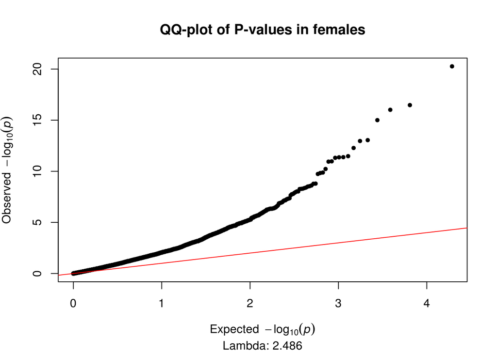

### Model 2 (2SV)

The ANOVA of diagnosis has been run with 2 SVs. Tables of the top 1000 DMPs have been produced for each variable of interest.

#### Top DMPs

**ANOVA:**  
55 probes pass the epigenome-wide significance threshold of 2.4x10-7  
*The top 50 diagnosis associated DMPs:*

| ProbeID | Position | F | p (F) | FDR.Anova | Difference | CI lower | CI upper | pCvM | FDR | Difference | CI lower | CI upper | pCvA | FDR | Difference | CI lower | CI upper | pMvA | FDR | UCSC Gene | UCSC Gene Group | UCSC Relation to CpG Island | Gene Closest TSS | Distance Closest TSS | GREAT Annotation 1 | GREAT Annotation 2 |
| --- | --- | --- | --- | --- | --- | --- | --- | --- | --- | --- | --- | --- | --- | --- | --- | --- | --- | --- | --- | --- | --- | --- | --- | --- | --- | --- |
| cg22822140 | chr X: 153046577 | 60.692 | 1.55e-20 | 1.49e-16 | -0.002 | -0.024 | 0.020 | 0.98 | 1 | -0.090 | -0.112 | -0.068 | 4.85e-14 | 4.68e-10 | -0.088 | -0.11 | -0.066 | 4.94e-14 | 1.51e-10 | SRPK3;SRPK3;SRPK3 | 1stExon;1stExon;1stExon | Island | SRPK3 | 122 | SRPK3 (122) | (NA) |
| cg12230162 | chr X: 153046482 | 49.366 | 1.43e-17 | 6.90e-14 | 0.008 | -0.017 | 0.032 | 0.728 | 1 | -0.086 | -0.111 | -0.061 | 3.31e-13 | 1.60e-09 | -0.094 | -0.118 | -0.069 | 4.95e-14 | 1.51e-10 | SRPK3;SRPK3;SRPK3;SRPK3;SRPK3;SRPK3 | 5'UTR;1stExon;1stExon;5'UTR;5'UTR;1stExon | Island | SRPK3 | 27 | SRPK3 (27) | (NA) |
| cg13009143 | chr X: 100548223 | 45.750 | 1.43e-16 | 4.15e-13 | -0.016 | -0.023 | -0.009 | 2.05e-07 | 9.40e-05 | 0.011 | 0.004 | 0.018 | 7.10e-04 | 0.042 | 0.027 | 0.02 | 0.033 | 4.77e-14 | 1.51e-10 | TAF7L | TSS200 | S_Shore | TAF7L | -164 | TAF7L (-165) | (NA) |
| cg24496423 | chr X: 153046480 | 45.466 | 1.72e-16 | 4.15e-13 | 0.005 | -0.014 | 0.025 | 0.79 | 1 | -0.066 | -0.086 | -0.046 | 1.54e-12 | 3.71e-09 | -0.071 | -0.091 | -0.052 | 6.27e-14 | 1.51e-10 | SRPK3;SRPK3;SRPK3;SRPK3;SRPK3;SRPK3 | 5'UTR;1stExon;1stExon;5'UTR;5'UTR;1stExon | Island | SRPK3 | 25 | SRPK3 (25) | (NA) |
| cg16152676 | chr X: 10126878 | 35.299 | 1.64e-13 | 3.16e-10 | 0.041 | 0.026 | 0.055 | 1.03e-09 | 1.89e-06 | -0.006 | -0.021 | 0.009 | 0.595 | 1 | -0.047 | -0.061 | -0.032 | 3.51e-12 | 5.64e-09 | CLCN4 | 5'UTR | Island | CLCN4 | 550 | CLCN4 (1894) | MID1 (724930) |
| cg16529483 | chr X: 153046451 | 34.349 | 3.20e-13 | 5.14e-10 | -0.004 | -0.028 | 0.020 | 0.932 | 1 | -0.075 | -0.100 | -0.051 | 3.34e-11 | 5.36e-08 | -0.072 | -0.096 | -0.048 | 1.21e-10 | 1.30e-07 | SRPK3;SRPK3;SRPK3 | TSS200;TSS200;TSS200 | Island | SRPK3 | -4 | SRPK3 (-4) | (NA) |
| cg03360001 | chr X: 53453272 | 33.630 | 5.33e-13 | 7.35e-10 | -0.009 | -0.015 | -0.003 | 9.63e-04 | 0.042 | 0.011 | 0.005 | 0.017 | 4.96e-05 | 0.006 | 0.020 | 0.014 | 0.026 | 2.39e-13 | 4.62e-10 | RIBC1;RIBC1 | Body;Body | S_Shelf | RIBC1 | 3434 | SMC1A (-3655) | (NA) |
| cg12468189 | chr X: 153046767 | 32.368 | 1.32e-12 | 1.59e-09 | -0.024 | -0.039 | -0.008 | 9.84e-04 | 0.042 | -0.053 | -0.068 | -0.037 | 5.50e-13 | 1.77e-09 | -0.029 | -0.044 | -0.014 | 3.86e-05 | 0.006 | SRPK3;SRPK3;SRPK3 | Body;Body;Body | Island | SRPK3 | 312 | SRPK3 (312) | (NA) |
| cg09768654 | chr X: 153046386 | 31.447 | 2.57e-12 | 2.75e-09 | 0.013 | -0.01 | 0.035 | 0.38 | 1 | -0.059 | -0.082 | -0.036 | 2.91e-08 | 2.34e-05 | -0.071 | -0.094 | -0.049 | 1.19e-11 | 1.43e-08 | SRPK3;SRPK3;SRPK3 | TSS200;TSS200;TSS200 | Island | SRPK3 | -69 | SRPK3 (-69) | (NA) |
| cg24605338 | chr X: 17395856 | 31.118 | 3.26e-12 | 3.15e-09 | -0.037 | -0.048 | -0.026 | 1.21e-12 | 1.17e-08 | -0.018 | -0.030 | -0.007 | 5.21e-04 | 0.033 | 0.019 | 0.008 | 0.03 | 2.57e-04 | 0.025 | NHS | Body | S_Shore | NHS | 2314 | SCML1 (-359735) | NHS (2314) |
| cg19280671 | chr X: 149013642 | 29.973 | 7.54e-12 | 6.61e-09 | 0.017 | 0.011 | 0.023 | 3.91e-10 | 1.26e-06 | 0.001 | -0.005 | 0.007 | 0.911 | 1 | -0.016 | -0.022 | -0.01 | 3.14e-09 | 2.33e-06 | MAGEA8;MAGEA8;MAGEA8 | Body;Body;Body |  | MAGEA8 | 596 | MAMLD1 (-517908) | MAGEA8 (3702) |
| cg21252909 | chr X: 30326328 | 28.617 | 2.06e-11 | 1.65e-08 | 0.04 | 0.018 | 0.063 | 1.38e-04 | 0.011 | -0.032 | -0.055 | -0.009 | 0.004 | 0.104 | -0.072 | -0.095 | -0.05 | 8.53e-12 | 1.18e-08 | NR0B1 | 1stExon | N_Shore | NR0B1 | 1167 | NR0B1 (1166) | (NA) |
| cg19938385 | chr X: 107020894 | 28.398 | 2.42e-11 | 1.80e-08 | -0.045 | -0.063 | -0.026 | 1.27e-07 | 6.79e-05 | -0.056 | -0.075 | -0.038 | 8.77e-11 | 1.21e-07 | -0.012 | -0.03 | 0.007 | 0.303 | 1 |  |  | S_Shore | TSC22D3 | -1692 | TSC22D3 (-1878) | (NA) |
| cg17405188 | chr X: 73164102 | 27.886 | 3.55e-11 | 2.45e-08 | 0.008 | 0.003 | 0.013 | 9.24e-04 | 0.041 | 0.016 | 0.011 | 0.022 | 1.31e-11 | 2.52e-08 | 0.008 | 0.003 | 0.014 | 4.02e-04 | 0.034 | LOC554203 | TSS200 | Island | JPX | -56 | ZCCHC13 (-359922) | CHIC1 (381119) |
| cg17003204 | chr X: 102861456 | 27.189 | 6.00e-11 | 3.86e-08 | -0.034 | -0.045 | -0.022 | 1.31e-10 | 6.34e-07 | -0.009 | -0.020 | 0.003 | 0.186 | 0.869 | 0.025 | 0.014 | 0.037 | 1.10e-06 | 4.43e-04 | TCEAL3;TCEAL3 | TSS1500;TSS1500 | N_Shore | TCEAL3 | -1377 | TCEAL3 (-1377) | (NA) |
| cg22926378 | chr X: 6144633 | 24.383 | 5.12e-10 | 3.09e-07 | 0.015 | 0.008 | 0.022 | 3.34e-06 | 7.50e-04 | -0.005 | -0.012 | 0.002 | 0.267 | 0.989 | -0.020 | -0.027 | -0.013 | 1.11e-09 | 9.72e-07 | NLGN4X;NLGN4X | 5'UTR;5'UTR | Island | NLGN4X | 483 | NLGN4X (2072) | (NA) |
| cg25896901 | chr X: 125300481 | 23.570 | 9.63e-10 | 5.47e-07 | 0.012 | -0.013 | 0.038 | 0.483 | 1 | -0.057 | -0.082 | -0.031 | 1.51e-06 | 4.85e-04 | -0.069 | -0.094 | -0.044 | 2.98e-09 | 2.33e-06 | DCAF12L2 | TSS1500 | S_Shore | DCAF12L2 | -401 | DCAF12L1 (386360) | (NA) |
| cg07069575 | chr X: 49688313 | 23.378 | 1.12e-09 | 6.00e-07 | 0.01 | -0.002 | 0.023 | 0.104 | 0.652 | -0.024 | -0.036 | -0.011 | 2.90e-05 | 0.004 | -0.034 | -0.046 | -0.022 | 9.21e-10 | 8.89e-07 | CLCN5;CLCN5 | 5'UTR;5'UTR | S_Shore | CLCN5 | 1089 | CLCN5 (1089) | AKAP4 (277350) |
| cg17219209 | chr X: 149009840 | 23.296 | 1.19e-09 | 6.06e-07 | 0.022 | 0.014 | 0.030 | 5.50e-09 | 6.63e-06 | 0.004 | -0.004 | 0.012 | 0.499 | 1 | -0.018 | -0.026 | -0.01 | 1.39e-06 | 4.80e-04 | MAGEA8;MAGEA8;MAGEA8 | TSS200;TSS200;TSS200 |  | MAGEA8 | -100 | MAGEA8 (-100) | (NA) |
| cg17513789 | chr X: 73073251 | 22.867 | 1.67e-09 | 8.05e-07 | -0.044 | -0.06 | -0.029 | 6.54e-10 | 1.58e-06 | -0.023 | -0.039 | -0.008 | 0.002 | 0.065 | 0.021 | 0.005 | 0.036 | 0.005 | 0.168 | XIST | TSS1500 |  | XIST | -663 | ZCCHC13 (-450773) | CHIC1 (290268) |
| cg06452970 | chr X: 13835264 | 22.534 | 2.17e-09 | 9.96e-07 | 0.049 | 0.03 | 0.068 | 2.16e-08 | 1.60e-05 | 0.006 | -0.013 | 0.025 | 0.761 | 1 | -0.043 | -0.062 | -0.024 | 6.43e-07 | 3.22e-04 | GPM6B;GPM6B;GPM6B;GPM6B;GPM6B;GPM6B;GPM6B | 1stExon;5'UTR;5'UTR;Body;5'UTR;1stExon;1stExon |  | GPM6B | 50 | GPM6B (49) | (NA) |
| cg15907464 | chr X: 70712790 | 22.152 | 2.93e-09 | 1.28e-06 | -0.035 | -0.047 | -0.022 | 1.18e-09 | 1.89e-06 | -0.019 | -0.031 | -0.006 | 0.001 | 0.061 | 0.016 | 0.004 | 0.028 | 0.007 | 0.224 | BCYRN1;INGX | Body;TSS200 | Island | INGX | -186 | OGT (-40121) | TAF1 (126677) |
| cg16122592 | chr X: 26210712 | 22.062 | 3.15e-09 | 1.32e-06 | -0.03 | -0.042 | -0.019 | 8.39e-09 | 8.10e-06 | -0.025 | -0.036 | -0.013 | 3.18e-06 | 8.76e-04 | 0.006 | -0.006 | 0.017 | 0.482 | 1 | MAGEB6 | 5'UTR |  | MAGEB6 | 156 | MAGEB6 (156) | (NA) |
| cg26484667 | chr X: 2733164 | 21.922 | 3.52e-09 | 1.41e-06 | -0.029 | -0.041 | -0.018 | 2.43e-08 | 1.67e-05 | -0.004 | -0.016 | 0.007 | 0.678 | 1 | 0.025 | 0.014 | 0.037 | 1.38e-06 | 4.80e-04 | XG;XG;XG | 3'UTR;3'UTR;3'UTR |  | GYG2 | -13698 | GYG2 (-13698) | XG (63072) |
| cg21364342 | chr X: 107226611 | 21.748 | 4.04e-09 | 1.56e-06 | -0.022 | -0.031 | -0.012 | 3.60e-07 | 1.45e-04 | -0.023 | -0.033 | -0.014 | 5.51e-08 | 3.80e-05 | -0.002 | -0.011 | 0.007 | 0.89 | 1 | TEX13B | TSS1500 |  | TEX13B | -1011 | VSIG1 (-61588) | MID2 (157528) |
| cg09513996 | chr X: 48685182 | 21.534 | 4.78e-09 | 1.78e-06 | 0.005 | -0.009 | 0.018 | 0.683 | 1 | -0.030 | -0.043 | -0.016 | 1.98e-06 | 5.97e-04 | -0.035 | -0.048 | -0.021 | 2.17e-08 | 1.40e-05 |  |  | Island | ERAS | -2100 | ERAS (-2100) | (NA) |
| cg04768884 | chr X: 19443172 | 21.376 | 5.42e-09 | 1.94e-06 | 0.007 | -0.007 | 0.021 | 0.475 | 1 | 0.036 | 0.022 | 0.051 | 1.87e-08 | 1.64e-05 | 0.030 | 0.016 | 0.043 | 3.24e-06 | 9.78e-04 | MAP3K15 | Body |  | MAP3K15 | 35099 | PDHA1 (81162) | MAP3K15 (90206) |
| cg11179997 | chr X: 119125670 | 21.073 | 6.91e-09 | 2.38e-06 | 0.028 | 0.017 | 0.040 | 1.14e-07 | 6.47e-05 | 0.002 | -0.010 | 0.014 | 0.922 | 1 | -0.026 | -0.038 | -0.015 | 6.68e-07 | 3.22e-04 |  |  | Island | AK123976 | -44530 | NKAP (-47936) | RHOXF2 (86036) |
| cg14917571 | chr X: 79269151 | 20.966 | 7.52e-09 | 2.50e-06 | -0.051 | -0.07 | -0.032 | 3.07e-09 | 4.23e-06 | -0.027 | -0.046 | -0.009 | 0.002 | 0.077 | 0.024 | 0.005 | 0.042 | 0.009 | 0.248 | TBX22;TBX22 | TSS1500;TSS1500 |  | TBX22 | -1103 | ITM2A (-646103) | TBX22 (-8590) |
| cg23914849 | chr X: 52950051 | 20.755 | 8.91e-09 | 2.87e-06 | 0.003 | 5.43e-04 | 0.005 | 0.011 | 0.198 | 0.006 | 0.004 | 0.009 | 3.87e-09 | 4.67e-06 | 0.003 | 0.001 | 0.006 | 0.001 | 0.077 |  |  | Island | FAM156A | 13799 | FAM156B (21967) | FAM156A (74599) |
| cg08630881 | chr X: 70713213 | 20.407 | 1.18e-08 | 3.67e-06 | -0.029 | -0.04 | -0.018 | 6.41e-09 | 6.87e-06 | -0.018 | -0.029 | -0.007 | 3.29e-04 | 0.023 | 0.011 | -1.28e-04 | 0.021 | 0.054 | 0.64 | BCYRN1;INGX | Body;TSS1500 | S_Shore | INGX | -609 | OGT (-39698) | TAF1 (127100) |
| cg01737010 | chr X: 101772014 | 20.058 | 1.56e-08 | 4.70e-06 | 0.007 | -0.002 | 0.017 | 0.184 | 0.831 | -0.018 | -0.028 | -0.008 | 7.70e-05 | 0.008 | -0.025 | -0.035 | -0.016 | 1.45e-08 | 9.98e-06 | TMSB15A | TSS1500 | S_Shore | TMSB15A | -315 | TMSB15A (-316) | (NA) |
| cg04710661 | chr X: 2848381 | 19.996 | 1.64e-08 | 4.79e-06 | 0.006 | -4.01e-04 | 0.013 | 0.07 | 0.54 | 0.018 | 0.011 | 0.025 | 1.12e-08 | 1.21e-05 | 0.012 | 0.005 | 0.018 | 1.90e-04 | 0.02 | ARSD;ARSD | TSS1500;TSS1500 | S_Shore | ARSD | -965 | ARSD (-966) | (NA) |
| cg09953945 | chr X: 150345040 | 19.322 | 2.83e-08 | 8.03e-06 | -0.027 | -0.037 | -0.017 | 1.41e-08 | 1.20e-05 | -0.016 | -0.027 | -0.006 | 7.79e-04 | 0.044 | 0.010 | 2.42e-04 | 0.021 | 0.043 | 0.592 | GPR50 | TSS200 | N_Shore | GPR50 | -15 | GPR50 (-15) | (NA) |
| cg04817724 | chr X: 103809991 | 19.052 | 3.52e-08 | 9.72e-06 | 0.053 | 0.033 | 0.073 | 1.49e-08 | 1.20e-05 | 0.026 | 0.006 | 0.047 | 0.009 | 0.18 | -0.027 | -0.047 | -0.007 | 0.005 | 0.186 | IL1RAPL2 | TSS1500 | Island | IL1RAPL2 | -1004 | IL1RAPL2 (-1004) | (NA) |
| cg00190642 | chr X: 103268431 | 19.009 | 3.65e-08 | 9.78e-06 | -0.013 | -0.028 | 0.002 | 0.104 | 0.651 | 0.026 | 0.010 | 0.041 | 3.33e-04 | 0.023 | 0.039 | 0.024 | 0.054 | 2.38e-08 | 1.43e-05 | H2BFWT;MIR1256 | TSS200;Body | Island | H2BFWT | -175 | H2BFWT (-176) | (NA) |
| cg00123001 | chr X: 13395880 | 18.889 | 4.03e-08 | 1.04e-05 | -0.017 | -0.025 | -0.009 | 3.11e-06 | 7.27e-04 | -0.019 | -0.027 | -0.011 | 2.90e-07 | 1.56e-04 | -0.002 | -0.01 | 0.006 | 0.831 | 1 |  |  | N_Shore | LOC100133123 | 42521 | EGFL6 (-191813) | ATXN3L (-57363) |
| cg22574818 | chr X: 55479616 | 18.856 | 4.13e-08 | 1.04e-05 | -0.032 | -0.055 | -0.010 | 0.003 | 0.088 | -0.060 | -0.083 | -0.037 | 1.79e-08 | 1.64e-05 | -0.028 | -0.05 | -0.005 | 0.013 | 0.309 | MAGEH1;MAGEH1 | 1stExon;3'UTR |  | MAGEH1 | 1079 | MAGEH1 (1079) | USP51 (36014) |
| cg09661041 | chr X: 153141905 | 18.835 | 4.21e-08 | 1.04e-05 | -0.01 | -0.034 | 0.015 | 0.607 | 1 | -0.059 | -0.084 | -0.035 | 1.60e-07 | 1.03e-04 | -0.050 | -0.074 | -0.025 | 8.70e-06 | 0.002 | L1CAM;L1CAM;L1CAM | TSS1500;TSS1500;TSS1500 |  | L1CAM | -506 | L1CAM (-507) | (NA) |
| cg24352688 | chr X: 13751727 | 18.808 | 4.30e-08 | 1.04e-05 | 0.001 | -0.006 | 0.008 | 0.908 | 1 | 0.016 | 0.009 | 0.023 | 4.75e-07 | 1.76e-04 | 0.015 | 0.008 | 0.022 | 2.18e-06 | 7.02e-04 | TRAPPC2;OFD1;TRAPPC2;TRAPPC2 | 5'UTR;TSS1500;5'UTR;5'UTR | N_Shore | TRAPPC2 | 1027 | OFD1 (-1104) | TRAPPC2 (1026) |
| cg02754763 | chr X: 44403388 | 18.467 | 5.68e-08 | 1.32e-05 | -1.85e-04 | -0.007 | 0.007 | 0.998 | 1 | -0.016 | -0.023 | -0.009 | 1.33e-06 | 4.44e-04 | -0.016 | -0.023 | -0.009 | 1.16e-06 | 4.46e-04 | FUNDC1 | TSS1500 |  | FUNDC1 | -1167 | DUSP21 (-299860) | EFHC2 (-200466) |
| cg00805156 | chr X: 3264341 | 18.455 | 5.74e-08 | 1.32e-05 | 0.035 | 0.018 | 0.052 | 4.63e-06 | 9.31e-04 | 0.039 | 0.023 | 0.056 | 3.56e-07 | 1.61e-04 | 0.004 | -0.012 | 0.021 | 0.807 | 1 | MXRA5 | 5'UTR | Island | MXRA5 | 343 | MXRA5 (342) | (NA) |
| cg25433595 | chr X: 100183764 | 18.197 | 7.09e-08 | 1.59e-05 | 0.046 | 0.028 | 0.065 | 7.04e-08 | 4.24e-05 | 0.034 | 0.015 | 0.053 | 1.22e-04 | 0.011 | -0.013 | -0.031 | 0.006 | 0.246 | 1 | XKRX;XKRX | 5'UTR;1stExon | N_Shore | XKRX | 134 | XKRX (133) | (NA) |
| cg24834461 | chr X: 153637645 | 18.004 | 8.31e-08 | 1.79e-05 | 0.017 | 0.01 | 0.024 | 4.38e-08 | 2.82e-05 | 0.011 | 0.004 | 0.018 | 0.001 | 0.052 | -0.007 | -0.013 | 2.64e-04 | 0.062 | 0.67 | DNASE1L1;DNASE1L1;DNASE1L1;DNASE1L1 | TSS200;5'UTR;5'UTR;5'UTR | N_Shelf | DNASE1L1 | -70 | TAZ (-2231) | (NA) |
| cg08464958 | chr X: 2852845 | 17.999 | 8.34e-08 | 1.79e-05 | -0.022 | -0.032 | -0.013 | 3.34e-07 | 1.40e-04 | -0.004 | -0.013 | 0.006 | 0.66 | 1 | 0.019 | 0.009 | 0.028 | 1.69e-05 | 0.003 | ARSE | 3'UTR |  | ARSD | -5429 | ARSD (-5430) | ARSE (29648) |
| cg07344627 | chr X: 125687011 | 17.878 | 9.22e-08 | 1.93e-05 | -0.032 | -0.056 | -0.007 | 0.006 | 0.151 | -0.062 | -0.086 | -0.037 | 3.95e-08 | 2.93e-05 | -0.030 | -0.054 | -0.006 | 0.009 | 0.259 | DCAF12L1 | TSS200 | S_Shore | DCAF12L1 | -169 | DCAF12L1 (-170) | (NA) |
| cg06068202 | chr X: 150343148 | 17.701 | 1.07e-07 | 2.19e-05 | 0.038 | 0.019 | 0.057 | 1.58e-05 | 0.002 | 0.045 | 0.026 | 0.064 | 3.53e-07 | 1.61e-04 | 0.007 | -0.012 | 0.026 | 0.637 | 1 |  |  | Island | GPR50 | -1907 | GPR50 (-1907) | (NA) |
| ch.X.153018199F | chr X: 153365005 | 17.630 | 1.13e-07 | 2.27e-05 | -0.011 | -0.015 | -0.006 | 1.60e-07 | 8.14e-05 | -0.003 | -0.007 | 0.002 | 0.305 | 1 | 0.008 | 0.004 | 0.012 | 1.17e-04 | 0.014 |  |  | S_Shore | MECP2 | -1817 | MECP2 (-1818) | (NA) |
| cg00072799 | chr X: 78427682 | 17.504 | 1.26e-07 | 2.47e-05 | -0.008 | -0.022 | 0.006 | 0.395 | 1 | -0.034 | -0.049 | -0.020 | 2.27e-07 | 1.29e-04 | -0.026 | -0.041 | -0.012 | 5.34e-05 | 0.008 | GPR174;GPR174 | 1stExon;3'UTR |  | GPR174 | 1214 | GPR174 (1214) | ITM2A (195366) |
| cg12039689 | chr X: 153141750 | 17.325 | 1.45e-07 | 2.81e-05 | -0.014 | -0.036 | 0.007 | 0.256 | 0.963 | -0.052 | -0.074 | -0.030 | 1.73e-07 | 1.04e-04 | -0.038 | -0.059 | -0.016 | 1.32e-04 | 0.015 | L1CAM;L1CAM;L1CAM | TSS1500;TSS1500;TSS1500 |  | L1CAM | -351 | L1CAM (-352) | (NA) |

**CTL vs MCI:**  
22 probes pass the epigenome-wide significance threshold of 2.4x10-7

*The top 50 CTL vs MCI associated DMPs:*

| ProbeID | Position | F | p (F) | FDR.Anova | Difference | CI lower | CI upper | pCvM | FDR | Difference | CI lower | CI upper | pCvA | FDR | Difference | CI lower | CI upper | pMvA | FDR | UCSC Gene | UCSC Gene Group | UCSC Relation to CpG Island | Gene Closest TSS | Distance Closest TSS | GREAT Annotation 1 | GREAT Annotation 2 |
| --- | --- | --- | --- | --- | --- | --- | --- | --- | --- | --- | --- | --- | --- | --- | --- | --- | --- | --- | --- | --- | --- | --- | --- | --- | --- | --- |
| cg24605338 | chr X: 17395856 | 31.118 | 3.26e-12 | 3.15e-09 | -0.037 | -0.048 | -0.026 | 1.21e-12 | 1.17e-08 | -0.018 | -0.030 | -0.007 | 5.21e-04 | 0.033 | 0.019 | 0.008 | 0.03 | 2.57e-04 | 0.025 | NHS | Body | S_Shore | NHS | 2314 | SCML1 (-359735) | NHS (2314) |
| cg17003204 | chr X: 102861456 | 27.189 | 6.00e-11 | 3.86e-08 | -0.034 | -0.045 | -0.022 | 1.31e-10 | 6.34e-07 | -0.009 | -0.020 | 0.003 | 0.186 | 0.869 | 0.025 | 0.014 | 0.037 | 1.10e-06 | 4.43e-04 | TCEAL3;TCEAL3 | TSS1500;TSS1500 | N_Shore | TCEAL3 | -1377 | TCEAL3 (-1377) | (NA) |
| cg19280671 | chr X: 149013642 | 29.973 | 7.54e-12 | 6.61e-09 | 0.017 | 0.011 | 0.023 | 3.91e-10 | 1.26e-06 | 0.001 | -0.005 | 0.007 | 0.911 | 1 | -0.016 | -0.022 | -0.01 | 3.14e-09 | 2.33e-06 | MAGEA8;MAGEA8;MAGEA8 | Body;Body;Body |  | MAGEA8 | 596 | MAMLD1 (-517908) | MAGEA8 (3702) |
| cg17513789 | chr X: 73073251 | 22.867 | 1.67e-09 | 8.05e-07 | -0.044 | -0.060 | -0.029 | 6.54e-10 | 1.58e-06 | -0.023 | -0.039 | -0.008 | 0.002 | 0.065 | 0.021 | 0.005 | 0.036 | 0.005 | 0.168 | XIST | TSS1500 |  | XIST | -663 | ZCCHC13 (-450773) | CHIC1 (290268) |
| cg16152676 | chr X: 10126878 | 35.299 | 1.64e-13 | 3.16e-10 | 0.041 | 0.026 | 0.055 | 1.03e-09 | 1.89e-06 | -0.006 | -0.021 | 0.009 | 0.595 | 1 | -0.047 | -0.061 | -0.032 | 3.51e-12 | 5.64e-09 | CLCN4 | 5'UTR | Island | CLCN4 | 550 | CLCN4 (1894) | MID1 (724930) |
| cg15907464 | chr X: 70712790 | 22.152 | 2.93e-09 | 1.28e-06 | -0.035 | -0.047 | -0.022 | 1.18e-09 | 1.89e-06 | -0.019 | -0.031 | -0.006 | 0.001 | 0.061 | 0.016 | 0.004 | 0.028 | 0.007 | 0.224 | BCYRN1;INGX | Body;TSS200 | Island | INGX | -186 | OGT (-40121) | TAF1 (126677) |
| cg14917571 | chr X: 79269151 | 20.966 | 7.52e-09 | 2.50e-06 | -0.051 | -0.070 | -0.032 | 3.07e-09 | 4.23e-06 | -0.027 | -0.046 | -0.009 | 0.002 | 0.077 | 0.024 | 0.005 | 0.042 | 0.009 | 0.248 | TBX22;TBX22 | TSS1500;TSS1500 |  | TBX22 | -1103 | ITM2A (-646103) | TBX22 (-8590) |
| cg17219209 | chr X: 149009840 | 23.296 | 1.19e-09 | 6.06e-07 | 0.022 | 0.014 | 0.030 | 5.50e-09 | 6.63e-06 | 0.004 | -0.004 | 0.012 | 0.499 | 1 | -0.018 | -0.026 | -0.01 | 1.39e-06 | 4.80e-04 | MAGEA8;MAGEA8;MAGEA8 | TSS200;TSS200;TSS200 |  | MAGEA8 | -100 | MAGEA8 (-100) | (NA) |
| cg08630881 | chr X: 70713213 | 20.407 | 1.18e-08 | 3.67e-06 | -0.029 | -0.040 | -0.018 | 6.41e-09 | 6.87e-06 | -0.018 | -0.029 | -0.007 | 3.29e-04 | 0.023 | 0.011 | -1.28e-04 | 0.021 | 0.054 | 0.64 | BCYRN1;INGX | Body;TSS1500 | S_Shore | INGX | -609 | OGT (-39698) | TAF1 (127100) |
| cg16122592 | chr X: 26210712 | 22.062 | 3.15e-09 | 1.32e-06 | -0.030 | -0.042 | -0.019 | 8.39e-09 | 8.10e-06 | -0.025 | -0.036 | -0.013 | 3.18e-06 | 8.76e-04 | 0.006 | -0.006 | 0.017 | 0.482 | 1 | MAGEB6 | 5'UTR |  | MAGEB6 | 156 | MAGEB6 (156) | (NA) |
| cg09953945 | chr X: 150345040 | 19.322 | 2.83e-08 | 8.03e-06 | -0.027 | -0.037 | -0.017 | 1.41e-08 | 1.20e-05 | -0.016 | -0.027 | -0.006 | 7.79e-04 | 0.044 | 0.01 | 2.42e-04 | 0.021 | 0.043 | 0.592 | GPR50 | TSS200 | N_Shore | GPR50 | -15 | GPR50 (-15) | (NA) |
| cg04817724 | chr X: 103809991 | 19.052 | 3.52e-08 | 9.72e-06 | 0.053 | 0.033 | 0.073 | 1.49e-08 | 1.20e-05 | 0.026 | 0.006 | 0.047 | 0.009 | 0.18 | -0.027 | -0.047 | -0.007 | 0.005 | 0.186 | IL1RAPL2 | TSS1500 | Island | IL1RAPL2 | -1004 | IL1RAPL2 (-1004) | (NA) |
| cg06452970 | chr X: 13835264 | 22.534 | 2.17e-09 | 9.96e-07 | 0.049 | 0.030 | 0.068 | 2.16e-08 | 1.60e-05 | 0.006 | -0.013 | 0.025 | 0.761 | 1 | -0.043 | -0.062 | -0.024 | 6.43e-07 | 3.22e-04 | GPM6B;GPM6B;GPM6B;GPM6B;GPM6B;GPM6B;GPM6B | 1stExon;5'UTR;5'UTR;Body;5'UTR;1stExon;1stExon |  | GPM6B | 50 | GPM6B (49) | (NA) |
| cg26484667 | chr X: 2733164 | 21.922 | 3.52e-09 | 1.41e-06 | -0.029 | -0.041 | -0.018 | 2.43e-08 | 1.67e-05 | -0.004 | -0.016 | 0.007 | 0.678 | 1 | 0.025 | 0.014 | 0.037 | 1.38e-06 | 4.80e-04 | XG;XG;XG | 3'UTR;3'UTR;3'UTR |  | GYG2 | -13698 | GYG2 (-13698) | XG (63072) |
| cg24834461 | chr X: 153637645 | 18.004 | 8.31e-08 | 1.79e-05 | 0.017 | 0.010 | 0.024 | 4.38e-08 | 2.82e-05 | 0.011 | 0.004 | 0.018 | 0.001 | 0.052 | -0.007 | -0.013 | 2.64e-04 | 0.062 | 0.67 | DNASE1L1;DNASE1L1;DNASE1L1;DNASE1L1 | TSS200;5'UTR;5'UTR;5'UTR | N_Shelf | DNASE1L1 | -70 | TAZ (-2231) | (NA) |
| cg25433595 | chr X: 100183764 | 18.197 | 7.09e-08 | 1.59e-05 | 0.046 | 0.028 | 0.065 | 7.04e-08 | 4.24e-05 | 0.034 | 0.015 | 0.053 | 1.22e-04 | 0.011 | -0.013 | -0.031 | 0.006 | 0.246 | 1 | XKRX;XKRX | 5'UTR;1stExon | N_Shore | XKRX | 134 | XKRX (133) | (NA) |
| cg11179997 | chr X: 119125670 | 21.073 | 6.91e-09 | 2.38e-06 | 0.028 | 0.017 | 0.040 | 1.14e-07 | 6.47e-05 | 0.002 | -0.010 | 0.014 | 0.922 | 1 | -0.026 | -0.038 | -0.015 | 6.68e-07 | 3.22e-04 |  |  | Island | AK123976 | -44530 | NKAP (-47936) | RHOXF2 (86036) |
| cg19938385 | chr X: 107020894 | 28.398 | 2.42e-11 | 1.80e-08 | -0.045 | -0.063 | -0.026 | 1.27e-07 | 6.79e-05 | -0.056 | -0.075 | -0.038 | 8.77e-11 | 1.21e-07 | -0.012 | -0.03 | 0.007 | 0.303 | 1 |  |  | S_Shore | TSC22D3 | -1692 | TSC22D3 (-1878) | (NA) |
| ch.X.153018199F | chr X: 153365005 | 17.630 | 1.13e-07 | 2.27e-05 | -0.011 | -0.015 | -0.006 | 1.60e-07 | 8.14e-05 | -0.003 | -0.007 | 0.002 | 0.305 | 1 | 0.008 | 0.004 | 0.012 | 1.17e-04 | 0.014 |  |  | S_Shore | MECP2 | -1817 | MECP2 (-1818) | (NA) |
| cg14306994 | chr X: 49019804 | 16.514 | 2.86e-07 | 4.83e-05 | 0.032 | 0.019 | 0.046 | 1.73e-07 | 8.33e-05 | 0.013 | -0.001 | 0.026 | 0.08 | 0.573 | -0.02 | -0.033 | -0.006 | 0.002 | 0.094 | MAGIX;MAGIX;MAGIX;MAGIX | Body;Body;Body;TSS1500 | Island | MAGIX | -316 | GPKOW (-39726) | PLP2 (-8379) |
| cg13009143 | chr X: 100548223 | 45.750 | 1.43e-16 | 4.15e-13 | -0.016 | -0.023 | -0.009 | 2.05e-07 | 9.40e-05 | 0.011 | 0.004 | 0.018 | 7.10e-04 | 0.042 | 0.027 | 0.02 | 0.033 | 4.77e-14 | 1.51e-10 | TAF7L | TSS200 | S_Shore | TAF7L | -164 | TAF7L (-165) | (NA) |
| cg08867267 | chr X: 130033963 | 15.990 | 4.43e-07 | 6.89e-05 | -0.024 | -0.034 | -0.014 | 2.15e-07 | 9.45e-05 | -0.014 | -0.024 | -0.004 | 0.004 | 0.108 | 0.01 | -8.28e-05 | 0.02 | 0.052 | 0.637 | ENOX2;ENOX2 | 5'UTR;5'UTR | N_Shelf | ENOX2 | 3245 | ENOX2 (3244) | RBMX2 (498021) |
| cg08464958 | chr X: 2852845 | 17.999 | 8.34e-08 | 1.79e-05 | -0.022 | -0.032 | -0.013 | 3.34e-07 | 1.40e-04 | -0.004 | -0.013 | 0.006 | 0.66 | 1 | 0.019 | 0.009 | 0.028 | 1.69e-05 | 0.003 | ARSE | 3'UTR |  | ARSD | -5429 | ARSD (-5430) | ARSE (29648) |
| cg21364342 | chr X: 107226611 | 21.748 | 4.04e-09 | 1.56e-06 | -0.022 | -0.031 | -0.012 | 3.60e-07 | 1.45e-04 | -0.023 | -0.033 | -0.014 | 5.51e-08 | 3.80e-05 | -0.002 | -0.011 | 0.007 | 0.89 | 1 | TEX13B | TSS1500 |  | TEX13B | -1011 | VSIG1 (-61588) | MID2 (157528) |
| cg25177692 | chr X: 129193893 | 15.954 | 4.56e-07 | 6.99e-05 | -0.026 | -0.037 | -0.014 | 8.32e-07 | 3.21e-04 | -0.021 | -0.032 | -0.009 | 9.29e-05 | 0.009 | 0.005 | -0.006 | 0.016 | 0.562 | 1 |  |  | N_Shore | BCORL1 | 34929 | ELF4 (50794) | BCORL1 (54730) |
| cg25549901 | chr X: 137951118 | 17.280 | 1.51e-07 | 2.86e-05 | -0.024 | -0.034 | -0.013 | 1.02e-06 | 3.73e-04 | -0.022 | -0.033 | -0.011 | 7.38e-06 | 0.002 | 0.002 | -0.009 | 0.012 | 0.926 | 1 | FGF13;FGF13;FGF13;FGF13 | 5'UTR;Body;TSS1500;Body |  | FGF13 | -1401 | FGF13 (336066) | (NA) |
| cg26468081 | chr X: 69501565 | 14.898 | 1.11e-06 | 1.43e-04 | -0.014 | -0.021 | -0.008 | 1.04e-06 | 3.73e-04 | -0.004 | -0.011 | 0.002 | 0.242 | 0.96 | 0.01 | 0.004 | 0.016 | 8.89e-04 | 0.063 | ARR3;RAB41 | Body;TSS1500 |  | RAB41 | -456 | RAB41 (-456) | (NA) |
| cg12461113 | chr X: 13587550 | 14.160 | 2.09e-06 | 2.52e-04 | -0.077 | -0.112 | -0.043 | 1.09e-06 | 3.75e-04 | -0.034 | -0.069 | 0.001 | 0.06 | 0.509 | 0.044 | 0.009 | 0.078 | 0.009 | 0.249 | EGFL6;EGFL6 | TSS200;TSS200 | N_Shore | EGFL6 | -143 | EGFL6 (-143) | (NA) |
| cg25396787 | chr X: 3733991 | 13.986 | 2.42e-06 | 2.78e-04 | 0.028 | 0.015 | 0.040 | 1.31e-06 | 4.34e-04 | 0.017 | 0.004 | 0.03 | 0.005 | 0.129 | -0.011 | -0.023 | 0.002 | 0.101 | 0.833 |  |  | Island | TRNA_Ile | 22500 | PRKX (-102317) | (NA) |
| cg09979033 | chr X: 16726904 | 15.056 | 9.73e-07 | 1.29e-04 | -0.017 | -0.025 | -0.009 | 1.41e-06 | 4.42e-04 | -0.013 | -0.021 | -0.006 | 2.13e-04 | 0.016 | 0.004 | -0.004 | 0.011 | 0.499 | 1 | CTPS2;CTPS2;CTPS2 | 5'UTR;5'UTR;5'UTR | N_Shelf | CTPS2 | 3436 | CTPS2 (4154) | S100G (58624) |
| cg07089438 | chr X: 133988190 | 13.766 | 2.92e-06 | 3.21e-04 | -0.023 | -0.034 | -0.013 | 1.42e-06 | 4.42e-04 | -0.013 | -0.024 | -0.002 | 0.012 | 0.219 | 0.01 | -1.64e-04 | 0.021 | 0.055 | 0.642 | FAM122C;FAM122C | 3'UTR;Body |  | MOSPD1 | 45374 | PLAC1 (-195678) | MOSPD1 (61106) |
| cg05889382 | chr X: 70887722 | 16.203 | 3.71e-07 | 5.86e-05 | -0.020 | -0.029 | -0.011 | 1.72e-06 | 5.19e-04 | -0.018 | -0.027 | -0.009 | 2.01e-05 | 0.003 | 0.002 | -0.007 | 0.011 | 0.874 | 1 | BCYRN1 | Body | Island | LOC100132741 | -29323 | PIN4 (-513803) | CXCR3 (-49356) |
| cg27558057 | chr X: 70712724 | 13.536 | 3.56e-06 | 3.62e-04 | -0.029 | -0.042 | -0.016 | 1.89e-06 | 5.52e-04 | -0.013 | -0.026 | 7.75e-04 | 0.069 | 0.54 | 0.016 | 0.003 | 0.03 | 0.011 | 0.277 | BCYRN1;INGX | Body;TSS200 | Island | INGX | -120 | OGT (-40187) | TAF1 (126611) |
| cg25831435 | chr X: 137714452 | 13.886 | 2.64e-06 | 2.99e-04 | -0.031 | -0.045 | -0.017 | 1.98e-06 | 5.56e-04 | -0.021 | -0.035 | -0.007 | 0.002 | 0.066 | 0.01 | -0.004 | 0.023 | 0.242 | 1 | FGF13;FGF13;FGF13;FGF13;FGF13;FGF13 | 3'UTR;3'UTR;3'UTR;3'UTR;3'UTR;3'UTR |  | LOC158696 | -14653 | FGF13 (572732) | (NA) |
| cg07892139 | chr X: 84192519 | 16.956 | 1.98e-07 | 3.60e-05 | -0.040 | -0.058 | -0.021 | 2.02e-06 | 5.56e-04 | -0.038 | -0.057 | -0.02 | 5.37e-06 | 0.001 | 0.001 | -0.017 | 0.019 | 0.987 | 1 |  |  | S_Shelf | UBE2DNL | 3363 | APOOL (-66378) | UBE2DNL (3363) |
| cg16508637 | chr X: 132094977 | 16.234 | 3.61e-07 | 5.80e-05 | 0.026 | 0.014 | 0.039 | 2.19e-06 | 5.87e-04 | 0.003 | -0.010 | 0.015 | 0.856 | 1 | -0.024 | -0.036 | -0.012 | 2.16e-05 | 0.004 | HS6ST2;HS6ST2 | 5'UTR;5'UTR | S_Shelf | HS6ST2 | 446 | HS6ST2 (445) | (NA) |
| cg06138173 | chr X: 16668923 | 13.191 | 4.80e-06 | 4.47e-04 | -0.027 | -0.040 | -0.015 | 2.31e-06 | 6.03e-04 | -0.014 | -0.027 | -0.001 | 0.027 | 0.335 | 0.013 | 8.06e-04 | 0.026 | 0.034 | 0.529 | CTPS2;S100G;CTPS2;CTPS2 | Body;5'UTR;Body;Body |  | S100G | 643 | S100G (643) | (NA) |
| cg25958561 | chr X: 110187179 | 14.037 | 2.32e-06 | 2.73e-04 | 0.031 | 0.016 | 0.045 | 2.74e-06 | 6.95e-04 | 0.023 | 0.009 | 0.038 | 5.03e-04 | 0.032 | -0.007 | -0.021 | 0.007 | 0.448 | 1 | PAK3;PAK3 | TSS1500;TSS1500 |  | PAK3 | -333 | PAK3 (-179125) | CHRDL1 (-148104) |
| cg17397814 | chr X: 100670855 | 13.080 | 5.28e-06 | 4.81e-04 | 0.046 | 0.025 | 0.068 | 2.88e-06 | 7.13e-04 | 0.028 | 0.006 | 0.05 | 0.007 | 0.166 | -0.018 | -0.04 | 0.003 | 0.113 | 0.871 |  |  | N_Shelf | ARMCX4 | -2410 | ARMCX1 (-134658) | HNRNPH2 (7735) |
| cg06068891 | chr X: 135228207 | 13.558 | 3.50e-06 | 3.59e-04 | -0.047 | -0.069 | -0.025 | 3.03e-06 | 7.27e-04 | -0.034 | -0.056 | -0.011 | 0.001 | 0.059 | 0.013 | -0.008 | 0.035 | 0.319 | 1 | FHL1;FHL1;FHL1;FHL1 | TSS1500;TSS1500;TSS1500;TSS1500 | N_Shore | FHL1 | -653 | FHL1 (-1351) | (NA) |
| cg00123001 | chr X: 13395880 | 18.889 | 4.03e-08 | 1.04e-05 | -0.017 | -0.025 | -0.009 | 3.11e-06 | 7.27e-04 | -0.019 | -0.027 | -0.011 | 2.90e-07 | 1.56e-04 | -0.002 | -0.01 | 0.006 | 0.831 | 1 |  |  | N_Shore | LOC100133123 | 42521 | EGFL6 (-191813) | ATXN3L (-57363) |
| cg03035653 | chr X: 99662932 | 13.221 | 4.67e-06 | 4.44e-04 | 0.039 | 0.021 | 0.057 | 3.16e-06 | 7.27e-04 | 0.014 | -0.004 | 0.033 | 0.161 | 0.81 | -0.025 | -0.043 | -0.007 | 0.004 | 0.164 | PCDH19;PCDH19 | 1stExon;1stExon | Island | PCDH19 | 2339 | PCDH19 (2338) | (NA) |
| cg22926378 | chr X: 6144633 | 24.383 | 5.12e-10 | 3.09e-07 | 0.015 | 0.008 | 0.022 | 3.34e-06 | 7.50e-04 | -0.005 | -0.012 | 0.002 | 0.267 | 0.989 | -0.02 | -0.027 | -0.013 | 1.11e-09 | 9.72e-07 | NLGN4X;NLGN4X | 5'UTR;5'UTR | Island | NLGN4X | 483 | NLGN4X (2072) | (NA) |
| cg08333400 | chr X: 10126881 | 17.154 | 1.68e-07 | 3.11e-05 | 0.055 | 0.029 | 0.081 | 3.48e-06 | 7.63e-04 | 2.49e-04 | -0.026 | 0.027 | 1 | 1 | -0.055 | -0.081 | -0.029 | 3.47e-06 | 9.85e-04 | CLCN4 | 5'UTR | Island | CLCN4 | 553 | CLCN4 (1897) | MID1 (724927) |
| cg26101161 | chr X: 122736584 | 15.899 | 4.78e-07 | 7.18e-05 | -0.021 | -0.031 | -0.011 | 3.66e-06 | 7.74e-04 | -0.02 | -0.030 | -0.01 | 1.27e-05 | 0.003 | 9.25e-04 | -0.009 | 0.011 | 0.973 | 1 | THOC2 | 3'UTR |  | THOC2 | 8230 | THOC2 (130319) | GRIA3 (418489) |
| cg03800724 | chr X: 53253348 | 13.384 | 4.06e-06 | 4.04e-04 | 0.025 | 0.013 | 0.037 | 3.69e-06 | 7.74e-04 | 0.018 | 0.006 | 0.03 | 0.001 | 0.057 | -0.007 | -0.019 | 0.005 | 0.347 | 1 | KDM5C;KDM5C | Body;Body | N_Shore | KDM5C | 1256 | KDM5C (1255) | TSPYL2 (141807) |
| cg05860920 | chr X: 11679501 | 13.587 | 3.41e-06 | 3.58e-04 | 0.057 | 0.030 | 0.084 | 3.82e-06 | 7.83e-04 | 0.043 | 0.016 | 0.07 | 6.90e-04 | 0.042 | -0.014 | -0.04 | 0.013 | 0.439 | 1 | ARHGAP6;ARHGAP6 | Body;Body | N_Shelf | ARHGAP6 | 4320 | ARHGAP6 (4319) | AMELX (367969) |
| cg00805156 | chr X: 3264341 | 18.455 | 5.74e-08 | 1.32e-05 | 0.035 | 0.018 | 0.052 | 4.63e-06 | 9.31e-04 | 0.039 | 0.023 | 0.056 | 3.56e-07 | 1.61e-04 | 0.004 | -0.012 | 0.021 | 0.807 | 1 | MXRA5 | 5'UTR | Island | MXRA5 | 343 | MXRA5 (342) | (NA) |
| cg10841064 | chr X: 22292462 | 12.561 | 8.28e-06 | 6.71e-04 | -0.031 | -0.046 | -0.016 | 4.87e-06 | 9.58e-04 | -0.013 | -0.028 | 0.002 | 0.116 | 0.697 | 0.019 | 0.004 | 0.033 | 0.01 | 0.263 | ZNF645;ZNF645 | 3'UTR;1stExon |  | ZNF645 | 1433 | DDX53 (-725615) | ZNF645 (1433) |
| cg20881335 | chr X: 14547172 | 12.344 | 1.00e-05 | 7.50e-04 | 0.065 | 0.034 | 0.096 | 5.77e-06 | 0.001 | 0.027 | -0.005 | 0.059 | 0.112 | 0.681 | -0.038 | -0.069 | -0.007 | 0.012 | 0.292 | GLRA2;GLRA2;GLRA2 | TSS1500;TSS1500;TSS1500 |  | GLRA2 | -247 | GLRA2 (-247) | (NA) |

**CTL vs AD:**  
17 probes pass the epigenome-wide significance threshold of 2.4x10-7  
*The top 50 CTL vs AD associated DMPs:*

| ProbeID | Position | F | p (F) | FDR.Anova | Difference | CI lower | CI upper | pCvM | FDR | Difference | CI lower | CI upper | pCvA | FDR | Difference | CI lower | CI upper | pMvA | FDR | UCSC Gene | UCSC Gene Group | UCSC Relation to CpG Island | Gene Closest TSS | Distance Closest TSS | GREAT Annotation 1 | GREAT Annotation 2 |
| --- | --- | --- | --- | --- | --- | --- | --- | --- | --- | --- | --- | --- | --- | --- | --- | --- | --- | --- | --- | --- | --- | --- | --- | --- | --- | --- |
| cg22822140 | chr X: 153046577 | 60.692 | 1.55e-20 | 1.49e-16 | -0.002 | -0.024 | 0.02 | 0.98 | 1 | -0.090 | -0.112 | -0.068 | 4.85e-14 | 4.68e-10 | -0.088 | -0.110 | -0.066 | 4.94e-14 | 1.51e-10 | SRPK3;SRPK3;SRPK3 | 1stExon;1stExon;1stExon | Island | SRPK3 | 122 | SRPK3 (122) | (NA) |
| cg12230162 | chr X: 153046482 | 49.366 | 1.43e-17 | 6.90e-14 | 0.008 | -0.017 | 0.032 | 0.728 | 1 | -0.086 | -0.111 | -0.061 | 3.31e-13 | 1.60e-09 | -0.094 | -0.118 | -0.069 | 4.95e-14 | 1.51e-10 | SRPK3;SRPK3;SRPK3;SRPK3;SRPK3;SRPK3 | 5'UTR;1stExon;1stExon;5'UTR;5'UTR;1stExon | Island | SRPK3 | 27 | SRPK3 (27) | (NA) |
| cg12468189 | chr X: 153046767 | 32.368 | 1.32e-12 | 1.59e-09 | -0.024 | -0.039 | -0.008 | 9.84e-04 | 0.042 | -0.053 | -0.068 | -0.037 | 5.50e-13 | 1.77e-09 | -0.029 | -0.044 | -0.014 | 3.86e-05 | 0.006 | SRPK3;SRPK3;SRPK3 | Body;Body;Body | Island | SRPK3 | 312 | SRPK3 (312) | (NA) |
| cg24496423 | chr X: 153046480 | 45.466 | 1.72e-16 | 4.15e-13 | 0.005 | -0.014 | 0.025 | 0.79 | 1 | -0.066 | -0.086 | -0.046 | 1.54e-12 | 3.71e-09 | -0.071 | -0.091 | -0.052 | 6.27e-14 | 1.51e-10 | SRPK3;SRPK3;SRPK3;SRPK3;SRPK3;SRPK3 | 5'UTR;1stExon;1stExon;5'UTR;5'UTR;1stExon | Island | SRPK3 | 25 | SRPK3 (25) | (NA) |
| cg17405188 | chr X: 73164102 | 27.886 | 3.55e-11 | 2.45e-08 | 0.008 | 0.003 | 0.013 | 9.24e-04 | 0.041 | 0.016 | 0.011 | 0.022 | 1.31e-11 | 2.52e-08 | 0.008 | 0.003 | 0.014 | 4.02e-04 | 0.034 | LOC554203 | TSS200 | Island | JPX | -56 | ZCCHC13 (-359922) | CHIC1 (381119) |
| cg16529483 | chr X: 153046451 | 34.349 | 3.20e-13 | 5.14e-10 | -0.004 | -0.028 | 0.02 | 0.932 | 1 | -0.075 | -0.100 | -0.051 | 3.34e-11 | 5.36e-08 | -0.072 | -0.096 | -0.048 | 1.21e-10 | 1.30e-07 | SRPK3;SRPK3;SRPK3 | TSS200;TSS200;TSS200 | Island | SRPK3 | -4 | SRPK3 (-4) | (NA) |
| cg19938385 | chr X: 107020894 | 28.398 | 2.42e-11 | 1.80e-08 | -0.045 | -0.063 | -0.026 | 1.27e-07 | 6.79e-05 | -0.056 | -0.075 | -0.038 | 8.77e-11 | 1.21e-07 | -0.012 | -0.030 | 0.007 | 0.303 | 1 |  |  | S_Shore | TSC22D3 | -1692 | TSC22D3 (-1878) | (NA) |
| cg23914849 | chr X: 52950051 | 20.755 | 8.91e-09 | 2.87e-06 | 0.003 | 5.43e-04 | 0.005 | 0.011 | 0.198 | 0.006 | 0.004 | 0.009 | 3.87e-09 | 4.67e-06 | 0.003 | 0.001 | 0.006 | 0.001 | 0.077 |  |  | Island | FAM156A | 13799 | FAM156B (21967) | FAM156A (74599) |
| cg04710661 | chr X: 2848381 | 19.996 | 1.64e-08 | 4.79e-06 | 0.006 | -4.01e-04 | 0.013 | 0.07 | 0.54 | 0.018 | 0.011 | 0.025 | 1.12e-08 | 1.21e-05 | 0.012 | 0.005 | 0.018 | 1.90e-04 | 0.02 | ARSD;ARSD | TSS1500;TSS1500 | S_Shore | ARSD | -965 | ARSD (-966) | (NA) |
| cg22574818 | chr X: 55479616 | 18.856 | 4.13e-08 | 1.04e-05 | -0.032 | -0.055 | -0.01 | 0.003 | 0.088 | -0.060 | -0.083 | -0.037 | 1.79e-08 | 1.64e-05 | -0.028 | -0.050 | -0.005 | 0.013 | 0.309 | MAGEH1;MAGEH1 | 1stExon;3'UTR |  | MAGEH1 | 1079 | MAGEH1 (1079) | USP51 (36014) |
| cg04768884 | chr X: 19443172 | 21.376 | 5.42e-09 | 1.94e-06 | 0.007 | -0.007 | 0.021 | 0.475 | 1 | 0.036 | 0.022 | 0.051 | 1.87e-08 | 1.64e-05 | 0.03 | 0.016 | 0.043 | 3.24e-06 | 9.78e-04 | MAP3K15 | Body |  | MAP3K15 | 35099 | PDHA1 (81162) | MAP3K15 (90206) |
| cg09768654 | chr X: 153046386 | 31.447 | 2.57e-12 | 2.75e-09 | 0.013 | -0.01 | 0.035 | 0.38 | 1 | -0.059 | -0.082 | -0.036 | 2.91e-08 | 2.34e-05 | -0.071 | -0.094 | -0.049 | 1.19e-11 | 1.43e-08 | SRPK3;SRPK3;SRPK3 | TSS200;TSS200;TSS200 | Island | SRPK3 | -69 | SRPK3 (-69) | (NA) |
| cg07344627 | chr X: 125687011 | 17.878 | 9.22e-08 | 1.93e-05 | -0.032 | -0.056 | -0.007 | 0.006 | 0.151 | -0.062 | -0.086 | -0.037 | 3.95e-08 | 2.93e-05 | -0.03 | -0.054 | -0.006 | 0.009 | 0.259 | DCAF12L1 | TSS200 | S_Shore | DCAF12L1 | -169 | DCAF12L1 (-170) | (NA) |
| cg21364342 | chr X: 107226611 | 21.748 | 4.04e-09 | 1.56e-06 | -0.022 | -0.031 | -0.012 | 3.60e-07 | 1.45e-04 | -0.023 | -0.033 | -0.014 | 5.51e-08 | 3.80e-05 | -0.002 | -0.011 | 0.007 | 0.89 | 1 | TEX13B | TSS1500 |  | TEX13B | -1011 | VSIG1 (-61588) | MID2 (157528) |
| cg09661041 | chr X: 153141905 | 18.835 | 4.21e-08 | 1.04e-05 | -0.01 | -0.034 | 0.015 | 0.607 | 1 | -0.059 | -0.084 | -0.035 | 1.60e-07 | 1.03e-04 | -0.05 | -0.074 | -0.025 | 8.70e-06 | 0.002 | L1CAM;L1CAM;L1CAM | TSS1500;TSS1500;TSS1500 |  | L1CAM | -506 | L1CAM (-507) | (NA) |
| cg12039689 | chr X: 153141750 | 17.325 | 1.45e-07 | 2.81e-05 | -0.014 | -0.036 | 0.007 | 0.256 | 0.963 | -0.052 | -0.074 | -0.030 | 1.73e-07 | 1.04e-04 | -0.038 | -0.059 | -0.016 | 1.32e-04 | 0.015 | L1CAM;L1CAM;L1CAM | TSS1500;TSS1500;TSS1500 |  | L1CAM | -351 | L1CAM (-352) | (NA) |
| cg00072799 | chr X: 78427682 | 17.504 | 1.26e-07 | 2.47e-05 | -0.008 | -0.022 | 0.006 | 0.395 | 1 | -0.034 | -0.049 | -0.020 | 2.27e-07 | 1.29e-04 | -0.026 | -0.041 | -0.012 | 5.34e-05 | 0.008 | GPR174;GPR174 | 1stExon;3'UTR |  | GPR174 | 1214 | GPR174 (1214) | ITM2A (195366) |
| cg00123001 | chr X: 13395880 | 18.889 | 4.03e-08 | 1.04e-05 | -0.017 | -0.025 | -0.009 | 3.11e-06 | 7.27e-04 | -0.019 | -0.027 | -0.011 | 2.90e-07 | 1.56e-04 | -0.002 | -0.010 | 0.006 | 0.831 | 1 |  |  | N_Shore | LOC100133123 | 42521 | EGFL6 (-191813) | ATXN3L (-57363) |
| cg20814574 | chr X: 92928640 | 16.312 | 3.38e-07 | 5.53e-05 | 0.004 | -0.002 | 0.009 | 0.228 | 0.914 | 0.013 | 0.007 | 0.018 | 3.41e-07 | 1.61e-04 | 0.009 | 0.004 | 0.014 | 2.96e-04 | 0.027 | FAM133A;FAM133A;NAP1L3;FAM133A;FAM133A | TSS1500;TSS1500;TSS200;TSS1500;TSS1500 | Island | NAP1L3 | 42 | NAP1L3 (41) | (NA) |
| cg06068202 | chr X: 150343148 | 17.701 | 1.07e-07 | 2.19e-05 | 0.038 | 0.019 | 0.057 | 1.58e-05 | 0.002 | 0.045 | 0.026 | 0.064 | 3.53e-07 | 1.61e-04 | 0.007 | -0.012 | 0.026 | 0.637 | 1 |  |  | Island | GPR50 | -1907 | GPR50 (-1907) | (NA) |
| cg00805156 | chr X: 3264341 | 18.455 | 5.74e-08 | 1.32e-05 | 0.035 | 0.018 | 0.052 | 4.63e-06 | 9.31e-04 | 0.039 | 0.023 | 0.056 | 3.56e-07 | 1.61e-04 | 0.004 | -0.012 | 0.021 | 0.807 | 1 | MXRA5 | 5'UTR | Island | MXRA5 | 343 | MXRA5 (342) | (NA) |
| cg06616051 | chr X: 153094332 | 15.884 | 4.84e-07 | 7.18e-05 | 0.014 | -0.004 | 0.031 | 0.157 | 0.782 | 0.042 | 0.024 | 0.060 | 3.78e-07 | 1.61e-04 | 0.028 | 0.010 | 0.046 | 6.80e-04 | 0.051 | PDZD4 | Body | Island | PDZD4 | 1019 | IDH3G (-34366) | PDZD4 (1670) |
| cg01975035 | chr X: 24761808 | 15.332 | 7.71e-07 | 1.08e-04 | -0.01 | -0.02 | -2.37e-04 | 0.044 | 0.431 | -0.024 | -0.034 | -0.014 | 3.85e-07 | 1.61e-04 | -0.014 | -0.024 | -0.003 | 0.005 | 0.173 | SCARNA23;POLA1 | TSS1500;Body |  | SCARNA23 | -749 | POLA1 (49745) | ARX (272256) |
| cg02329520 | chr X: 153740317 | 16.754 | 2.34e-07 | 4.10e-05 | -0.014 | -0.022 | -0.006 | 6.90e-05 | 0.007 | -0.018 | -0.026 | -0.010 | 4.11e-07 | 1.65e-04 | -0.004 | -0.012 | 0.004 | 0.439 | 1 | FAM3A;FAM3A;FAM3A;FAM3A;FAM3A | Body;Body;Body;Body;Body | N_Shelf | FAM3A | 4249 | SLC10A3 (-21316) | FAM3A (4248) |
| ch.X.1639000R | chr X: 113225430 | 15.063 | 9.67e-07 | 1.29e-04 | 0.008 | 0.001 | 0.015 | 0.015 | 0.243 | 0.016 | 0.009 | 0.023 | 4.43e-07 | 1.71e-04 | 0.008 | 0.001 | 0.015 | 0.018 | 0.371 |  |  |  | HTR2C | -593120 | HTR2C (-593120) | (NA) |
| cg24352688 | chr X: 13751727 | 18.808 | 4.30e-08 | 1.04e-05 | 0.001 | -0.006 | 0.008 | 0.908 | 1 | 0.016 | 0.009 | 0.023 | 4.75e-07 | 1.76e-04 | 0.015 | 0.008 | 0.022 | 2.18e-06 | 7.02e-04 | TRAPPC2;OFD1;TRAPPC2;TRAPPC2 | 5'UTR;TSS1500;5'UTR;5'UTR | N_Shore | TRAPPC2 | 1027 | OFD1 (-1104) | TRAPPC2 (1026) |
| cg00928753 | chr X: 36976515 | 14.666 | 1.36e-06 | 1.70e-04 | 0.025 | 0.003 | 0.046 | 0.019 | 0.276 | 0.050 | 0.028 | 0.072 | 6.27e-07 | 2.20e-04 | 0.025 | 0.004 | 0.047 | 0.017 | 0.364 |  |  | S_Shore | FAM47C | -49916 | PRRG1 (-232012) | CXorf59 (911463) |
| cg08850124 | chr X: 118207749 | 15.759 | 5.38e-07 | 7.86e-05 | -0.012 | -0.019 | -0.005 | 2.31e-04 | 0.016 | -0.016 | -0.023 | -0.009 | 6.39e-07 | 2.20e-04 | -0.004 | -0.011 | 0.003 | 0.323 | 1 |  |  | Island | KIAA1210 | 76793 | PGRMC1 (-162461) | LONRF3 (99037) |
| cg02754763 | chr X: 44403388 | 18.467 | 5.68e-08 | 1.32e-05 | -1.85e-04 | -0.007 | 0.007 | 0.998 | 1 | -0.016 | -0.023 | -0.009 | 1.33e-06 | 4.44e-04 | -0.016 | -0.023 | -0.009 | 1.16e-06 | 4.46e-04 | FUNDC1 | TSS1500 |  | FUNDC1 | -1167 | DUSP21 (-299860) | EFHC2 (-200466) |
| cg25896901 | chr X: 125300481 | 23.570 | 9.63e-10 | 5.47e-07 | 0.012 | -0.013 | 0.038 | 0.483 | 1 | -0.057 | -0.082 | -0.031 | 1.51e-06 | 4.85e-04 | -0.069 | -0.094 | -0.044 | 2.98e-09 | 2.33e-06 | DCAF12L2 | TSS1500 | S_Shore | DCAF12L2 | -401 | DCAF12L1 (386360) | (NA) |
| cg02048654 | chr X: 132551786 | 14.085 | 2.23e-06 | 2.65e-04 | 0.02 | -0.008 | 0.048 | 0.215 | 0.89 | 0.063 | 0.034 | 0.091 | 1.83e-06 | 5.69e-04 | 0.043 | 0.014 | 0.071 | 0.001 | 0.078 |  |  | S_Shore | GPC4 | -2581 | GPC4 (-2582) | (NA) |
| cg09513996 | chr X: 48685182 | 21.534 | 4.78e-09 | 1.78e-06 | 0.005 | -0.009 | 0.018 | 0.683 | 1 | -0.030 | -0.043 | -0.016 | 1.98e-06 | 5.97e-04 | -0.035 | -0.048 | -0.021 | 2.17e-08 | 1.40e-05 |  |  | Island | ERAS | -2100 | ERAS (-2100) | (NA) |
| cg16170760 | chr X: 153708103 | 13.158 | 4.94e-06 | 4.54e-04 | -0.008 | -0.017 | -1.79e-04 | 0.044 | 0.433 | -0.018 | -0.027 | -0.010 | 2.44e-06 | 7.05e-04 | -0.01 | -0.018 | -0.001 | 0.016 | 0.355 | LAGE3 | TSS1500 | S_Shore | LAGE3 | -507 | LAGE3 (-508) | (NA) |
| cg20784188 | chr X: 44703983 | 16.876 | 2.11e-07 | 3.77e-05 | -0.001 | -0.011 | 0.009 | 0.964 | 1 | -0.022 | -0.031 | -0.012 | 2.48e-06 | 7.05e-04 | -0.02 | -0.030 | -0.011 | 5.33e-06 | 0.001 | DUSP21;DUSP21 | 3'UTR;1stExon | S_Shore | DUSP21 | 735 | DUSP21 (735) | (NA) |
| cg16122592 | chr X: 26210712 | 22.062 | 3.15e-09 | 1.32e-06 | -0.03 | -0.042 | -0.019 | 8.39e-09 | 8.10e-06 | -0.025 | -0.036 | -0.013 | 3.18e-06 | 8.76e-04 | 0.006 | -0.006 | 0.017 | 0.482 | 1 | MAGEB6 | 5'UTR |  | MAGEB6 | 156 | MAGEB6 (156) | (NA) |
| cg00779763 | chr X: 47479114 | 12.442 | 9.18e-06 | 7.26e-04 | 0.011 | -2.70e-04 | 0.021 | 0.058 | 0.495 | 0.023 | 0.012 | 0.034 | 4.68e-06 | 0.001 | 0.013 | 0.002 | 0.023 | 0.018 | 0.373 | SYN1;SYN1 | 1stExon;1stExon | Island | SYN1 | 142 | SYN1 (141) | (NA) |
| cg07892139 | chr X: 84192519 | 16.956 | 1.98e-07 | 3.60e-05 | -0.04 | -0.058 | -0.021 | 2.02e-06 | 5.56e-04 | -0.038 | -0.057 | -0.020 | 5.37e-06 | 0.001 | 0.001 | -0.017 | 0.019 | 0.987 | 1 |  |  | S_Shelf | UBE2DNL | 3363 | APOOL (-66378) | UBE2DNL (3363) |
| cg01004447 | chr X: 44699940 | 13.722 | 3.04e-06 | 3.29e-04 | -0.003 | -0.009 | 0.004 | 0.564 | 1 | -0.014 | -0.020 | -0.007 | 5.64e-06 | 0.001 | -0.011 | -0.017 | -0.004 | 2.80e-04 | 0.026 |  |  | N_Shelf | DUSP21 | -3308 | DUSP21 (-3308) | (NA) |
| cg13492609 | chr X: 151308320 | 12.224 | 1.11e-05 | 7.88e-04 | -0.01 | -0.02 | 4.14e-04 | 0.063 | 0.519 | -0.021 | -0.031 | -0.011 | 5.72e-06 | 0.001 | -0.012 | -0.022 | -0.002 | 0.018 | 0.376 | MAGEA10;MAGEA10 | TSS1500;TSS1500 |  | MAGEA10 | -1270 | MAGEA5 (-21910) | GABRA3 (311510) |
| cg21179255 | chr X: 152772707 | 13.185 | 4.82e-06 | 4.47e-04 | -0.006 | -0.018 | 0.005 | 0.407 | 1 | -0.025 | -0.037 | -0.013 | 5.87e-06 | 0.001 | -0.018 | -0.030 | -0.007 | 7.71e-04 | 0.057 | BGN | Body |  | HAUS7 | -11729 | ATP2B3 (-28872) | BGN (12361) |
| cg05152459 | chr X: 75005087 | 12.102 | 1.24e-05 | 8.57e-04 | -0.023 | -0.043 | -0.003 | 0.017 | 0.26 | -0.042 | -0.062 | -0.022 | 6.40e-06 | 0.002 | -0.019 | -0.038 | 0.001 | 0.071 | 0.712 | MAGEE2 | TSS200 |  | MAGEE2 | -8 | CXorf26 (-387683) | TTC3P1 (-42174) |
| ch.X.188238R | chr X: 12813542 | 12.583 | 8.13e-06 | 6.64e-04 | 0.006 | -0.003 | 0.016 | 0.273 | 0.987 | 0.020 | 0.010 | 0.030 | 6.96e-06 | 0.002 | 0.014 | 0.004 | 0.024 | 0.002 | 0.111 | PRPS2;PRPS2 | Body;Body | S_Shelf | PRPS2 | -3783 | TLR7 (-71659) | PRPS2 (4069) |
| cg25549901 | chr X: 137951118 | 17.280 | 1.51e-07 | 2.86e-05 | -0.024 | -0.034 | -0.013 | 1.02e-06 | 3.73e-04 | -0.022 | -0.033 | -0.011 | 7.38e-06 | 0.002 | 0.002 | -0.009 | 0.012 | 0.926 | 1 | FGF13;FGF13;FGF13;FGF13 | 5'UTR;Body;TSS1500;Body |  | FGF13 | -1401 | FGF13 (336066) | (NA) |
| cg01988541 | chr X: 125683904 | 12.151 | 1.18e-05 | 8.27e-04 | -0.012 | -0.021 | -0.004 | 0.003 | 0.092 | -0.018 | -0.027 | -0.009 | 9.44e-06 | 0.002 | -0.006 | -0.014 | 0.003 | 0.271 | 1 | DCAF12L1 | 3'UTR | N_Shore | DCAF12L1 | 2687 | DCAF12L1 (2937) | (NA) |
| cg27250462 | chr X: 119250508 | 11.554 | 2.00e-05 | 0.001 | -0.008 | -0.017 | -1.73e-04 | 0.044 | 0.433 | -0.017 | -0.025 | -0.009 | 1.01e-05 | 0.002 | -0.009 | -0.017 | -3.50e-04 | 0.039 | 0.557 | RHOXF1 | TSS1500 | S_Shore | RHOXF1 | -661 | RHOXF1 (-662) | (NA) |
| cg11138004 | chr X: 154283466 | 12.290 | 1.05e-05 | 7.71e-04 | 0.005 | -0.004 | 0.013 | 0.409 | 1 | 0.017 | 0.009 | 0.025 | 1.18e-05 | 0.002 | 0.013 | 0.004 | 0.021 | 0.001 | 0.08 | FUNDC2 | 3'UTR |  | MTCP1 | 16081 | MTCP1NB (16080) | FUNDC2 (28403) |
| cg01961936 | chr X: 102349348 | 11.541 | 2.02e-05 | 0.001 | -0.007 | -0.016 | 0.002 | 0.127 | 0.71 | -0.018 | -0.027 | -0.009 | 1.18e-05 | 0.002 | -0.011 | -0.020 | -0.002 | 0.012 | 0.295 | NXF3 | TSS1500 |  | NXF3 | -1326 | NXF3 (-1327) | (NA) |
| cg00977690 | chr X: 24167334 | 14.351 | 1.77e-06 | 2.17e-04 | 7.15e-04 | -0.005 | 0.006 | 0.946 | 1 | 0.011 | 0.005 | 0.016 | 1.24e-05 | 0.002 | 0.01 | 0.005 | 0.015 | 3.41e-05 | 0.005 |  |  | N_Shore | ZFX | -427 | ZFX (-427) | (NA) |
| cg26101161 | chr X: 122736584 | 15.899 | 4.78e-07 | 7.18e-05 | -0.021 | -0.031 | -0.011 | 3.66e-06 | 7.74e-04 | -0.020 | -0.030 | -0.010 | 1.27e-05 | 0.003 | 9.25e-04 | -0.009 | 0.011 | 0.973 | 1 | THOC2 | 3'UTR |  | THOC2 | 8230 | THOC2 (130319) | GRIA3 (418489) |
| cg16627148 | chr X: 9963985 | 11.381 | 2.33e-05 | 0.001 | 0.012 | 0.002 | 0.021 | 0.014 | 0.237 | 0.020 | 0.010 | 0.029 | 1.31e-05 | 0.003 | 0.008 | -0.002 | 0.018 | 0.118 | 0.881 |  |  | S_Shelf | WWC3 | -19809 | CLCN4 (-160999) | SHROOM2 (209490) |

**MCI vs AD:**  
17 probes pass the epigenome-wide significance threshold of 2.4x10-7

*The top 50 MCI vs AD associated DMPs:*

| ProbeID | Position | F | p (F) | FDR.Anova | Difference | CI lower | CI upper | pCvM | FDR | Difference | CI lower | CI upper | pCvA | FDR | Difference | CI lower | CI upper | pMvA | FDR | UCSC Gene | UCSC Gene Group | UCSC Relation to CpG Island | Gene Closest TSS | Distance Closest TSS | GREAT Annotation 1 | GREAT Annotation 2 |
| --- | --- | --- | --- | --- | --- | --- | --- | --- | --- | --- | --- | --- | --- | --- | --- | --- | --- | --- | --- | --- | --- | --- | --- | --- | --- | --- |
| cg13009143 | chr X: 100548223 | 45.750 | 1.43e-16 | 4.15e-13 | -0.016 | -0.023 | -0.009 | 2.05e-07 | 9.40e-05 | 0.011 | 0.004 | 0.018 | 7.10e-04 | 0.042 | 0.027 | 0.020 | 0.033 | 4.77e-14 | 1.51e-10 | TAF7L | TSS200 | S_Shore | TAF7L | -164 | TAF7L (-165) | (NA) |
| cg22822140 | chr X: 153046577 | 60.692 | 1.55e-20 | 1.49e-16 | -0.002 | -0.024 | 0.020 | 0.98 | 1 | -0.09 | -0.112 | -0.068 | 4.85e-14 | 4.68e-10 | -0.088 | -0.110 | -0.066 | 4.94e-14 | 1.51e-10 | SRPK3;SRPK3;SRPK3 | 1stExon;1stExon;1stExon | Island | SRPK3 | 122 | SRPK3 (122) | (NA) |
| cg12230162 | chr X: 153046482 | 49.366 | 1.43e-17 | 6.90e-14 | 0.008 | -0.017 | 0.032 | 0.728 | 1 | -0.086 | -0.111 | -0.061 | 3.31e-13 | 1.60e-09 | -0.094 | -0.118 | -0.069 | 4.95e-14 | 1.51e-10 | SRPK3;SRPK3;SRPK3;SRPK3;SRPK3;SRPK3 | 5'UTR;1stExon;1stExon;5'UTR;5'UTR;1stExon | Island | SRPK3 | 27 | SRPK3 (27) | (NA) |
| cg24496423 | chr X: 153046480 | 45.466 | 1.72e-16 | 4.15e-13 | 0.005 | -0.014 | 0.025 | 0.79 | 1 | -0.066 | -0.086 | -0.046 | 1.54e-12 | 3.71e-09 | -0.071 | -0.091 | -0.052 | 6.27e-14 | 1.51e-10 | SRPK3;SRPK3;SRPK3;SRPK3;SRPK3;SRPK3 | 5'UTR;1stExon;1stExon;5'UTR;5'UTR;1stExon | Island | SRPK3 | 25 | SRPK3 (25) | (NA) |
| cg03360001 | chr X: 53453272 | 33.630 | 5.33e-13 | 7.35e-10 | -0.009 | -0.015 | -0.003 | 9.63e-04 | 0.042 | 0.011 | 0.005 | 0.017 | 4.96e-05 | 0.006 | 0.020 | 0.014 | 0.026 | 2.39e-13 | 4.62e-10 | RIBC1;RIBC1 | Body;Body | S_Shelf | RIBC1 | 3434 | SMC1A (-3655) | (NA) |
| cg16152676 | chr X: 10126878 | 35.299 | 1.64e-13 | 3.16e-10 | 0.041 | 0.026 | 0.055 | 1.03e-09 | 1.89e-06 | -0.006 | -0.021 | 0.009 | 0.595 | 1 | -0.047 | -0.061 | -0.032 | 3.51e-12 | 5.64e-09 | CLCN4 | 5'UTR | Island | CLCN4 | 550 | CLCN4 (1894) | MID1 (724930) |
| cg21252909 | chr X: 30326328 | 28.617 | 2.06e-11 | 1.65e-08 | 0.04 | 0.018 | 0.063 | 1.38e-04 | 0.011 | -0.032 | -0.055 | -0.009 | 0.004 | 0.104 | -0.072 | -0.095 | -0.050 | 8.53e-12 | 1.18e-08 | NR0B1 | 1stExon | N_Shore | NR0B1 | 1167 | NR0B1 (1166) | (NA) |
| cg09768654 | chr X: 153046386 | 31.447 | 2.57e-12 | 2.75e-09 | 0.013 | -0.01 | 0.035 | 0.38 | 1 | -0.059 | -0.082 | -0.036 | 2.91e-08 | 2.34e-05 | -0.071 | -0.094 | -0.049 | 1.19e-11 | 1.43e-08 | SRPK3;SRPK3;SRPK3 | TSS200;TSS200;TSS200 | Island | SRPK3 | -69 | SRPK3 (-69) | (NA) |
| cg16529483 | chr X: 153046451 | 34.349 | 3.20e-13 | 5.14e-10 | -0.004 | -0.028 | 0.020 | 0.932 | 1 | -0.075 | -0.100 | -0.051 | 3.34e-11 | 5.36e-08 | -0.072 | -0.096 | -0.048 | 1.21e-10 | 1.30e-07 | SRPK3;SRPK3;SRPK3 | TSS200;TSS200;TSS200 | Island | SRPK3 | -4 | SRPK3 (-4) | (NA) |
| cg07069575 | chr X: 49688313 | 23.378 | 1.12e-09 | 6.00e-07 | 0.01 | -0.002 | 0.023 | 0.104 | 0.652 | -0.024 | -0.036 | -0.011 | 2.90e-05 | 0.004 | -0.034 | -0.046 | -0.022 | 9.21e-10 | 8.89e-07 | CLCN5;CLCN5 | 5'UTR;5'UTR | S_Shore | CLCN5 | 1089 | CLCN5 (1089) | AKAP4 (277350) |
| cg22926378 | chr X: 6144633 | 24.383 | 5.12e-10 | 3.09e-07 | 0.015 | 0.008 | 0.022 | 3.34e-06 | 7.50e-04 | -0.005 | -0.012 | 0.002 | 0.267 | 0.989 | -0.020 | -0.027 | -0.013 | 1.11e-09 | 9.72e-07 | NLGN4X;NLGN4X | 5'UTR;5'UTR | Island | NLGN4X | 483 | NLGN4X (2072) | (NA) |
| cg25896901 | chr X: 125300481 | 23.570 | 9.63e-10 | 5.47e-07 | 0.012 | -0.013 | 0.038 | 0.483 | 1 | -0.057 | -0.082 | -0.031 | 1.51e-06 | 4.85e-04 | -0.069 | -0.094 | -0.044 | 2.98e-09 | 2.33e-06 | DCAF12L2 | TSS1500 | S_Shore | DCAF12L2 | -401 | DCAF12L1 (386360) | (NA) |
| cg19280671 | chr X: 149013642 | 29.973 | 7.54e-12 | 6.61e-09 | 0.017 | 0.011 | 0.023 | 3.91e-10 | 1.26e-06 | 0.001 | -0.005 | 0.007 | 0.911 | 1 | -0.016 | -0.022 | -0.010 | 3.14e-09 | 2.33e-06 | MAGEA8;MAGEA8;MAGEA8 | Body;Body;Body |  | MAGEA8 | 596 | MAMLD1 (-517908) | MAGEA8 (3702) |
| cg01737010 | chr X: 101772014 | 20.058 | 1.56e-08 | 4.70e-06 | 0.007 | -0.002 | 0.017 | 0.184 | 0.831 | -0.018 | -0.028 | -0.008 | 7.70e-05 | 0.008 | -0.025 | -0.035 | -0.016 | 1.45e-08 | 9.98e-06 | TMSB15A | TSS1500 | S_Shore | TMSB15A | -315 | TMSB15A (-316) | (NA) |
| cg09513996 | chr X: 48685182 | 21.534 | 4.78e-09 | 1.78e-06 | 0.005 | -0.009 | 0.018 | 0.683 | 1 | -0.03 | -0.043 | -0.016 | 1.98e-06 | 5.97e-04 | -0.035 | -0.048 | -0.021 | 2.17e-08 | 1.40e-05 |  |  | Island | ERAS | -2100 | ERAS (-2100) | (NA) |
| cg00190642 | chr X: 103268431 | 19.009 | 3.65e-08 | 9.78e-06 | -0.013 | -0.028 | 0.002 | 0.104 | 0.651 | 0.026 | 0.010 | 0.041 | 3.33e-04 | 0.023 | 0.039 | 0.024 | 0.054 | 2.38e-08 | 1.43e-05 | H2BFWT;MIR1256 | TSS200;Body | Island | H2BFWT | -175 | H2BFWT (-176) | (NA) |
| cg13788827 | chr X: 12990209 | 16.406 | 3.13e-07 | 5.20e-05 | -0.007 | -0.016 | 0.002 | 0.142 | 0.744 | 0.014 | 0.005 | 0.023 | 9.27e-04 | 0.049 | 0.021 | 0.012 | 0.030 | 2.06e-07 | 1.17e-04 |  |  | N_Shelf | TMSB4X | -3016 | TMSB4X (-3016) | (NA) |
| cg26486175 | chr X: 18658942 | 16.610 | 2.64e-07 | 4.54e-05 | 0.015 | -0.011 | 0.042 | 0.36 | 1 | -0.047 | -0.074 | -0.020 | 1.79e-04 | 0.015 | -0.062 | -0.088 | -0.036 | 3.14e-07 | 1.68e-04 | CDKL5;CDKL5;RS1 | Body;Body;3'UTR |  | RS1 | 31281 | RS1 (31280) | CDKL5 (215218) |
| cg06452970 | chr X: 13835264 | 22.534 | 2.17e-09 | 9.96e-07 | 0.049 | 0.03 | 0.068 | 2.16e-08 | 1.60e-05 | 0.006 | -0.013 | 0.025 | 0.761 | 1 | -0.043 | -0.062 | -0.024 | 6.43e-07 | 3.22e-04 | GPM6B;GPM6B;GPM6B;GPM6B;GPM6B;GPM6B;GPM6B | 1stExon;5'UTR;5'UTR;Body;5'UTR;1stExon;1stExon |  | GPM6B | 50 | GPM6B (49) | (NA) |
| cg11179997 | chr X: 119125670 | 21.073 | 6.91e-09 | 2.38e-06 | 0.028 | 0.017 | 0.040 | 1.14e-07 | 6.47e-05 | 0.002 | -0.010 | 0.014 | 0.922 | 1 | -0.026 | -0.038 | -0.015 | 6.68e-07 | 3.22e-04 |  |  | Island | AK123976 | -44530 | NKAP (-47936) | RHOXF2 (86036) |
| cg07395961 | chr X: 25041645 | 15.491 | 6.74e-07 | 9.56e-05 | -0.034 | -0.054 | -0.013 | 3.79e-04 | 0.023 | 0.012 | -0.009 | 0.033 | 0.346 | 1 | 0.046 | 0.026 | 0.067 | 8.28e-07 | 3.81e-04 |  |  | S_Shore | ARX | -7580 | ARX (-7581) | (NA) |
| cg03198117 | chr X: 152939967 | 15.636 | 5.96e-07 | 8.59e-05 | 0.031 | 0.013 | 0.048 | 1.96e-04 | 0.014 | -0.009 | -0.027 | 0.009 | 0.463 | 1 | -0.040 | -0.057 | -0.022 | 9.96e-07 | 4.21e-04 | PNCK;PNCK | TSS1500;TSS200 | S_Shore | PNCK | -151 | PNCK (-152) | (NA) |
| cg16801826 | chr X: 54587084 | 14.915 | 1.10e-06 | 1.43e-04 | -0.014 | -0.022 | -0.005 | 9.35e-04 | 0.041 | 0.006 | -0.003 | 0.015 | 0.25 | 0.976 | 0.020 | 0.011 | 0.028 | 1.00e-06 | 4.21e-04 | GNL3L | 3'UTR |  | GNL3L | 30441 | GNL3L (30441) | ITIH6 (237588) |
| cg17003204 | chr X: 102861456 | 27.189 | 6.00e-11 | 3.86e-08 | -0.034 | -0.045 | -0.022 | 1.31e-10 | 6.34e-07 | -0.009 | -0.020 | 0.003 | 0.186 | 0.869 | 0.025 | 0.014 | 0.037 | 1.10e-06 | 4.43e-04 | TCEAL3;TCEAL3 | TSS1500;TSS1500 | N_Shore | TCEAL3 | -1377 | TCEAL3 (-1377) | (NA) |
| cg02754763 | chr X: 44403388 | 18.467 | 5.68e-08 | 1.32e-05 | -1.85e-04 | -0.007 | 0.007 | 0.998 | 1 | -0.016 | -0.023 | -0.009 | 1.33e-06 | 4.44e-04 | -0.016 | -0.023 | -0.009 | 1.16e-06 | 4.46e-04 | FUNDC1 | TSS1500 |  | FUNDC1 | -1167 | DUSP21 (-299860) | EFHC2 (-200466) |
| cg10482495 | chr X: 71351314 | 14.851 | 1.16e-06 | 1.47e-04 | -0.005 | -0.014 | 0.004 | 0.417 | 1 | 0.016 | 0.006 | 0.025 | 3.92e-04 | 0.026 | 0.021 | 0.011 | 0.030 | 1.37e-06 | 4.80e-04 | NHSL2;RGAG4 | Body;1stExon | Island | RGAG4 | 76 | CXCR3 (-512948) | PIN4 (-50211) |
| cg26484667 | chr X: 2733164 | 21.922 | 3.52e-09 | 1.41e-06 | -0.029 | -0.041 | -0.018 | 2.43e-08 | 1.67e-05 | -0.004 | -0.016 | 0.007 | 0.678 | 1 | 0.025 | 0.014 | 0.037 | 1.38e-06 | 4.80e-04 | XG;XG;XG | 3'UTR;3'UTR;3'UTR |  | GYG2 | -13698 | GYG2 (-13698) | XG (63072) |
| cg17219209 | chr X: 149009840 | 23.296 | 1.19e-09 | 6.06e-07 | 0.022 | 0.014 | 0.030 | 5.50e-09 | 6.63e-06 | 0.004 | -0.004 | 0.012 | 0.499 | 1 | -0.018 | -0.026 | -0.010 | 1.39e-06 | 4.80e-04 | MAGEA8;MAGEA8;MAGEA8 | TSS200;TSS200;TSS200 |  | MAGEA8 | -100 | MAGEA8 (-100) | (NA) |
| cg09626131 | chr X: 82764537 | 14.619 | 1.41e-06 | 1.74e-04 | 0.01 | -0.009 | 0.028 | 0.414 | 1 | -0.031 | -0.049 | -0.012 | 4.59e-04 | 0.029 | -0.041 | -0.059 | -0.022 | 1.62e-06 | 5.39e-04 | POU3F4;POU3F4 | 3'UTR;1stExon | N_Shore | POU3F4 | 1269 | CYLC1 (-351632) | POU3F4 (1269) |
| cg24352688 | chr X: 13751727 | 18.808 | 4.30e-08 | 1.04e-05 | 0.001 | -0.006 | 0.008 | 0.908 | 1 | 0.016 | 0.009 | 0.023 | 4.75e-07 | 1.76e-04 | 0.015 | 0.008 | 0.022 | 2.18e-06 | 7.02e-04 | TRAPPC2;OFD1;TRAPPC2;TRAPPC2 | 5'UTR;TSS1500;5'UTR;5'UTR | N_Shore | TRAPPC2 | 1027 | OFD1 (-1104) | TRAPPC2 (1026) |
| cg04867253 | chr X: 70472827 | 13.828 | 2.77e-06 | 3.11e-04 | -0.01 | -0.026 | 0.006 | 0.315 | 1 | 0.025 | 0.009 | 0.042 | 0.001 | 0.057 | 0.035 | 0.019 | 0.051 | 2.43e-06 | 7.55e-04 | ZMYM3;ZMYM3;BCYRN1;ZMYM3;ZMYM3 | Body;Body;Body;Body;Body | N_Shore | ZMYM3 | 1211 | ZMYM3 (1210) | GJB1 (37766) |
| cg04768884 | chr X: 19443172 | 21.376 | 5.42e-09 | 1.94e-06 | 0.007 | -0.007 | 0.021 | 0.475 | 1 | 0.036 | 0.022 | 0.051 | 1.87e-08 | 1.64e-05 | 0.030 | 0.016 | 0.043 | 3.24e-06 | 9.78e-04 | MAP3K15 | Body |  | MAP3K15 | 35099 | PDHA1 (81162) | MAP3K15 (90206) |
| cg22090245 | chr X: 99661860 | 15.065 | 9.66e-07 | 1.29e-04 | -0.006 | -0.033 | 0.021 | 0.841 | 1 | 0.051 | 0.024 | 0.078 | 5.54e-05 | 0.006 | 0.057 | 0.031 | 0.084 | 3.45e-06 | 9.85e-04 | PCDH19;PCDH19 | 1stExon;1stExon | Island | PCDH19 | 3411 | PCDH19 (3410) | (NA) |
| cg08333400 | chr X: 10126881 | 17.154 | 1.68e-07 | 3.11e-05 | 0.055 | 0.029 | 0.081 | 3.48e-06 | 7.63e-04 | 2.49e-04 | -0.026 | 0.027 | 1 | 1 | -0.055 | -0.081 | -0.029 | 3.47e-06 | 9.85e-04 | CLCN4 | 5'UTR | Island | CLCN4 | 553 | CLCN4 (1897) | MID1 (724927) |
| cg09167861 | chr X: 135251741 | 12.824 | 6.59e-06 | 5.73e-04 | 0.008 | -0.002 | 0.017 | 0.14 | 0.743 | -0.012 | -0.022 | -0.003 | 0.007 | 0.164 | -0.020 | -0.029 | -0.011 | 3.78e-06 | 0.001 | FHL1;FHL1;FHL1;FHL1;FHL1;FHL1;FHL1;FHL1 | Body;1stExon;5'UTR;5'UTR;TSS200;5'UTR;5'UTR;5'UTR |  | FHL1 | -54 | FHL1 (22183) | MAP7D3 (81996) |
| cg20784188 | chr X: 44703983 | 16.876 | 2.11e-07 | 3.77e-05 | -0.001 | -0.011 | 0.009 | 0.964 | 1 | -0.022 | -0.031 | -0.012 | 2.48e-06 | 7.05e-04 | -0.020 | -0.030 | -0.011 | 5.33e-06 | 0.001 | DUSP21;DUSP21 | 3'UTR;1stExon | S_Shore | DUSP21 | 735 | DUSP21 (735) | (NA) |
| cg17662252 | chr X: 54560704 | 15.197 | 8.64e-07 | 1.19e-04 | -0.024 | -0.036 | -0.011 | 3.43e-05 | 0.004 | 0.002 | -0.010 | 0.015 | 0.916 | 1 | 0.026 | 0.014 | 0.038 | 5.37e-06 | 0.001 | GNL3L | Body | S_Shelf | GNL3L | 4061 | GNL3L (4061) | ITIH6 (263968) |
| cg24401049 | chr X: 11157158 | 12.374 | 9.74e-06 | 7.41e-04 | 0.035 | 0.006 | 0.063 | 0.012 | 0.209 | -0.024 | -0.053 | 0.005 | 0.118 | 0.699 | -0.059 | -0.087 | -0.031 | 5.60e-06 | 0.001 | ARHGAP6;ARHGAP6 | Body;Body | Island | HCCS | 27753 | AMELX (-154374) | HCCS (27753) |
| cg23722334 | chr X: 106515943 | 12.017 | 1.33e-05 | 9.04e-04 | 0.019 | -9.48e-04 | 0.039 | 0.066 | 0.525 | -0.022 | -0.042 | -0.002 | 0.028 | 0.338 | -0.041 | -0.061 | -0.021 | 6.70e-06 | 0.002 |  |  | Island | CXorf41 | 66082 | KIAA1817 (-327691) | NUP62CL (-66274) |
| cg04553232 | chr X: 8700576 | 12.770 | 6.91e-06 | 5.85e-04 | 0.009 | -0.008 | 0.025 | 0.431 | 1 | -0.025 | -0.042 | -0.009 | 0.001 | 0.06 | -0.034 | -0.051 | -0.018 | 7.13e-06 | 0.002 | KAL1 | TSS1500 | S_Shore | KAL1 | -349 | KAL1 (-350) | (NA) |
| cg06472309 | chr X: 108776114 | 12.949 | 5.91e-06 | 5.26e-04 | -0.007 | -0.021 | 0.008 | 0.501 | 1 | 0.023 | 0.008 | 0.037 | 8.75e-04 | 0.047 | 0.030 | 0.015 | 0.044 | 7.13e-06 | 0.002 |  |  | N_Shelf | NXT2 | -2895 | NXT2 (-2895) | (NA) |
| cg00695046 | chr X: 100545995 | 12.025 | 1.32e-05 | 9.04e-04 | 0.024 | -0.006 | 0.055 | 0.139 | 0.743 | -0.038 | -0.068 | -0.007 | 0.011 | 0.212 | -0.062 | -0.092 | -0.032 | 7.45e-06 | 0.002 | TAF7L;TAF7L | Body;5'UTR | N_Shore | TAF7L | 330 | TAF7L (2063) | DRP2 (71063) |
| cg09661041 | chr X: 153141905 | 18.835 | 4.21e-08 | 1.04e-05 | -0.01 | -0.034 | 0.015 | 0.607 | 1 | -0.059 | -0.084 | -0.035 | 1.60e-07 | 1.03e-04 | -0.050 | -0.074 | -0.025 | 8.70e-06 | 0.002 | L1CAM;L1CAM;L1CAM | TSS1500;TSS1500;TSS1500 |  | L1CAM | -506 | L1CAM (-507) | (NA) |
| cg25880538 | chr X: 68840309 | 14.015 | 2.36e-06 | 2.75e-04 | -0.018 | -0.028 | -0.008 | 9.03e-05 | 0.008 | 0.002 | -0.008 | 0.012 | 0.881 | 1 | 0.020 | 0.010 | 0.029 | 1.06e-05 | 0.002 | EDA;EDA;EDA;EDA;EDA | Body;Body;Body;Body;Body | S_Shelf | EDA | 4399 | EDA (4399) | AWAT2 (429478) |
| cg24743423 | chr X: 8701002 | 12.256 | 1.08e-05 | 7.72e-04 | 0.024 | 0.007 | 0.040 | 0.002 | 0.075 | -0.009 | -0.026 | 0.007 | 0.382 | 1 | -0.033 | -0.049 | -0.017 | 1.10e-05 | 0.002 | KAL1 | TSS1500 | S_Shore | KAL1 | -775 | KAL1 (-776) | (NA) |
| cg00632130 | chr X: 47931806 | 12.462 | 9.03e-06 | 7.20e-04 | -0.005 | -0.02 | 0.009 | 0.658 | 1 | 0.023 | 0.009 | 0.038 | 6.37e-04 | 0.04 | 0.028 | 0.014 | 0.043 | 1.46e-05 | 0.003 | ZNF630 | TSS1500 | S_Shore | ZNF630 | -781 | ZNF630 (-1299) | (NA) |
| cg01996723 | chr X: 139592127 | 11.095 | 2.99e-05 | 0.002 | 0.015 | -0.002 | 0.032 | 0.088 | 0.595 | -0.018 | -0.035 | -0.001 | 0.033 | 0.371 | -0.033 | -0.050 | -0.016 | 1.56e-05 | 0.003 |  |  | N_Shore | SOX3 | -4902 | SOX3 (-4903) | (NA) |
| cg08464958 | chr X: 2852845 | 17.999 | 8.34e-08 | 1.79e-05 | -0.022 | -0.032 | -0.013 | 3.34e-07 | 1.40e-04 | -0.004 | -0.013 | 0.006 | 0.66 | 1 | 0.019 | 0.009 | 0.028 | 1.69e-05 | 0.003 | ARSE | 3'UTR |  | ARSD | -5429 | ARSD (-5430) | ARSE (29648) |
| cg01067505 | chr X: 107178820 | 13.560 | 3.49e-06 | 3.59e-04 | 0.052 | 0.023 | 0.081 | 9.03e-05 | 0.008 | -0.004 | -0.033 | 0.025 | 0.934 | 1 | -0.056 | -0.085 | -0.028 | 1.88e-05 | 0.004 |  |  | N_Shore | BC070370 | 4978 | VSIG1 (-109379) | MID2 (109737) |
| cg22049457 | chr X: 129519749 | 11.597 | 1.92e-05 | 0.001 | -0.015 | -0.026 | -0.004 | 0.003 | 0.095 | 0.006 | -0.005 | 0.017 | 0.4 | 1 | 0.021 | 0.010 | 0.032 | 1.92e-05 | 0.004 | GPR119 | TSS1500 |  | GPR119 | -238 | GPR119 (-239) | (NA) |

#### Q-Q plot

To inspect whether there is any inflation, a Q-Q plot of p-values has been created and lambda has been calculated as a measure of inflation.

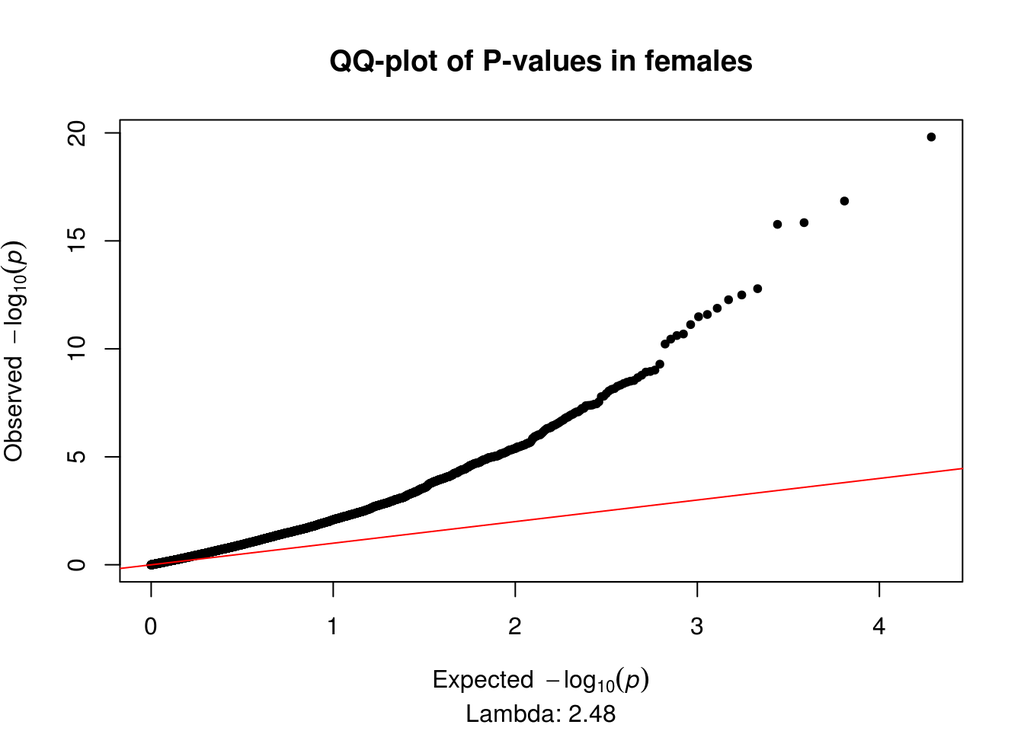

### Model 3 (3SV)

The ANOVA of diagnosis has been run with 3 SVs. Tables of the top 1000 DMPs have been produced for each variable of interest.

#### Top DMPs

**ANOVA:**  
49 probes pass the epigenome-wide significance threshold of 2.4x10-7  
*The top 50 diagnosis associated DMPs:*

| ProbeID | Position | F | p (F) | FDR.Anova | Difference | CI lower | CI upper | pCvM | FDR | Difference | CI lower | CI upper | pCvA | FDR | Difference | CI lower | CI upper | pMvA | FDR | UCSC Gene | UCSC Gene Group | UCSC Relation to CpG Island | Gene Closest TSS | Distance Closest TSS | GREAT Annotation 1 | GREAT Annotation 2 |
| --- | --- | --- | --- | --- | --- | --- | --- | --- | --- | --- | --- | --- | --- | --- | --- | --- | --- | --- | --- | --- | --- | --- | --- | --- | --- | --- |
| cg22822140 | chr X: 153046577 | 62.607 | 5.14e-21 | 4.96e-17 | 0.001 | -0.021 | 0.023 | 0.992 | 1 | -0.089 | -0.111 | -0.067 | 4.90e-14 | 4.72e-10 | -0.090 | -0.111 | -0.068 | 4.90e-14 | 1.42e-10 | SRPK3;SRPK3;SRPK3 | 1stExon;1stExon;1stExon | Island | SRPK3 | 122 | SRPK3 (122) | (NA) |
| cg12230162 | chr X: 153046482 | 50.265 | 8.15e-18 | 3.93e-14 | 0.01 | -0.015 | 0.034 | 0.615 | 1 | -0.085 | -0.110 | -0.060 | 3.82e-13 | 1.84e-09 | -0.095 | -0.119 | -0.07 | 4.77e-14 | 1.42e-10 | SRPK3;SRPK3;SRPK3;SRPK3;SRPK3;SRPK3 | 5'UTR;1stExon;1stExon;5'UTR;5'UTR;1stExon | Island | SRPK3 | 27 | SRPK3 (27) | (NA) |
| cg24496423 | chr X: 153046480 | 45.734 | 1.45e-16 | 4.66e-13 | 0.006 | -0.014 | 0.026 | 0.745 | 1 | -0.066 | -0.085 | -0.046 | 1.72e-12 | 4.14e-09 | -0.072 | -0.091 | -0.052 | 5.87e-14 | 1.42e-10 | SRPK3;SRPK3;SRPK3;SRPK3;SRPK3;SRPK3 | 5'UTR;1stExon;1stExon;5'UTR;5'UTR;1stExon | Island | SRPK3 | 25 | SRPK3 (25) | (NA) |
| cg13009143 | chr X: 100548223 | 43.226 | 7.44e-16 | 1.79e-12 | -0.015 | -0.021 | -0.008 | 1.60e-06 | 6.43e-04 | 0.011 | 0.005 | 0.018 | 3.36e-04 | 0.024 | 0.026 | 0.019 | 0.033 | 4.94e-14 | 1.42e-10 | TAF7L | TSS200 | S_Shore | TAF7L | -164 | TAF7L (-165) | (NA) |
| cg16529483 | chr X: 153046451 | 34.335 | 3.23e-13 | 6.24e-10 | -0.004 | -0.028 | 0.020 | 0.925 | 1 | -0.075 | -0.100 | -0.051 | 3.19e-11 | 4.40e-08 | -0.072 | -0.096 | -0.048 | 1.29e-10 | 1.39e-07 | SRPK3;SRPK3;SRPK3 | TSS200;TSS200;TSS200 | Island | SRPK3 | -4 | SRPK3 (-4) | (NA) |
| cg03360001 | chr X: 53453272 | 33.248 | 7.01e-13 | 1.13e-09 | -0.009 | -0.015 | -0.003 | 0.001 | 0.066 | 0.011 | 0.005 | 0.017 | 4.55e-05 | 0.005 | 0.020 | 0.014 | 0.026 | 3.04e-13 | 5.86e-10 | RIBC1;RIBC1 | Body;Body | S_Shelf | RIBC1 | 3434 | SMC1A (-3655) | (NA) |
| cg16152676 | chr X: 10126878 | 32.207 | 1.48e-12 | 1.94e-09 | 0.038 | 0.024 | 0.052 | 1.09e-08 | 1.31e-05 | -0.007 | -0.022 | 0.007 | 0.477 | 1 | -0.045 | -0.059 | -0.031 | 1.48e-11 | 2.04e-08 | CLCN4 | 5'UTR | Island | CLCN4 | 550 | CLCN4 (1894) | MID1 (724930) |
| cg12468189 | chr X: 153046767 | 32.093 | 1.61e-12 | 1.94e-09 | -0.023 | -0.038 | -0.008 | 0.001 | 0.071 | -0.052 | -0.068 | -0.037 | 6.82e-13 | 2.19e-09 | -0.029 | -0.044 | -0.014 | 3.17e-05 | 0.006 | SRPK3;SRPK3;SRPK3 | Body;Body;Body | Island | SRPK3 | 312 | SRPK3 (312) | (NA) |
| cg09768654 | chr X: 153046386 | 31.322 | 2.81e-12 | 3.01e-09 | 0.012 | -0.01 | 0.035 | 0.405 | 1 | -0.059 | -0.082 | -0.036 | 2.68e-08 | 2.16e-05 | -0.071 | -0.094 | -0.049 | 1.40e-11 | 2.04e-08 | SRPK3;SRPK3;SRPK3 | TSS200;TSS200;TSS200 | Island | SRPK3 | -69 | SRPK3 (-69) | (NA) |
| cg19938385 | chr X: 107020894 | 31.137 | 3.22e-12 | 3.10e-09 | -0.047 | -0.065 | -0.029 | 1.58e-08 | 1.39e-05 | -0.057 | -0.076 | -0.039 | 2.04e-11 | 3.28e-08 | -0.010 | -0.028 | 0.008 | 0.381 | 1 |  |  | S_Shore | TSC22D3 | -1692 | TSC22D3 (-1878) | (NA) |
| cg24605338 | chr X: 17395856 | 30.975 | 3.62e-12 | 3.17e-09 | -0.037 | -0.048 | -0.026 | 1.34e-12 | 1.29e-08 | -0.018 | -0.030 | -0.007 | 5.36e-04 | 0.033 | 0.019 | 0.008 | 0.03 | 2.68e-04 | 0.027 | NHS | Body | S_Shore | NHS | 2314 | SCML1 (-359735) | NHS (2314) |
| cg17405188 | chr X: 73164102 | 29.245 | 1.29e-11 | 1.04e-08 | 0.006 | 0.001 | 0.011 | 0.008 | 0.206 | 0.016 | 0.011 | 0.021 | 6.65e-12 | 1.28e-08 | 0.009 | 0.005 | 0.014 | 1.85e-05 | 0.003 | LOC554203 | TSS200 | Island | JPX | -56 | ZCCHC13 (-359922) | CHIC1 (381119) |
| cg19280671 | chr X: 149013642 | 27.417 | 5.05e-11 | 3.75e-08 | 0.016 | 0.01 | 0.022 | 2.66e-09 | 4.83e-06 | 6.93e-04 | -0.005 | 0.007 | 0.96 | 1 | -0.016 | -0.021 | -0.01 | 9.76e-09 | 6.44e-06 | MAGEA8;MAGEA8;MAGEA8 | Body;Body;Body |  | MAGEA8 | 596 | MAMLD1 (-517908) | MAGEA8 (3702) |
| cg21252909 | chr X: 30326328 | 27.025 | 6.79e-11 | 4.68e-08 | 0.037 | 0.014 | 0.059 | 5.68e-04 | 0.038 | -0.034 | -0.057 | -0.011 | 0.002 | 0.08 | -0.070 | -0.093 | -0.048 | 2.58e-11 | 3.11e-08 | NR0B1 | 1stExon | N_Shore | NR0B1 | 1167 | NR0B1 (1166) | (NA) |
| cg17219209 | chr X: 149009840 | 24.085 | 6.45e-10 | 4.15e-07 | 0.022 | 0.014 | 0.030 | 3.01e-09 | 4.83e-06 | 0.004 | -0.004 | 0.012 | 0.474 | 1 | -0.018 | -0.026 | -0.01 | 9.86e-07 | 4.32e-04 | MAGEA8;MAGEA8;MAGEA8 | TSS200;TSS200;TSS200 |  | MAGEA8 | -100 | MAGEA8 (-100) | (NA) |
| cg17003204 | chr X: 102861456 | 23.500 | 1.02e-09 | 6.13e-07 | -0.031 | -0.042 | -0.020 | 2.32e-09 | 4.83e-06 | -0.007 | -0.019 | 0.004 | 0.28 | 1 | 0.024 | 0.012 | 0.035 | 4.28e-06 | 0.001 | TCEAL3;TCEAL3 | TSS1500;TSS1500 | N_Shore | TCEAL3 | -1377 | TCEAL3 (-1377) | (NA) |
| cg07069575 | chr X: 49688313 | 23.396 | 1.10e-09 | 6.22e-07 | 0.007 | -0.005 | 0.019 | 0.325 | 1 | -0.025 | -0.037 | -0.013 | 4.00e-06 | 0.001 | -0.032 | -0.044 | -0.021 | 2.09e-09 | 2.02e-06 | CLCN5;CLCN5 | 5'UTR;5'UTR | S_Shore | CLCN5 | 1089 | CLCN5 (1089) | AKAP4 (277350) |
| cg25896901 | chr X: 125300481 | 23.331 | 1.16e-09 | 6.22e-07 | 0.011 | -0.014 | 0.036 | 0.566 | 1 | -0.057 | -0.083 | -0.032 | 1.16e-06 | 3.85e-04 | -0.068 | -0.093 | -0.043 | 4.47e-09 | 3.60e-06 | DCAF12L2 | TSS1500 | S_Shore | DCAF12L2 | -401 | DCAF12L1 (386360) | (NA) |
| cg22926378 | chr X: 6144633 | 22.455 | 2.31e-09 | 1.17e-06 | 0.014 | 0.007 | 0.021 | 1.66e-05 | 0.004 | -0.005 | -0.012 | 0.002 | 0.203 | 0.902 | -0.019 | -0.026 | -0.012 | 3.31e-09 | 2.90e-06 | NLGN4X;NLGN4X | 5'UTR;5'UTR | Island | NLGN4X | 483 | NLGN4X (2072) | (NA) |
| cg09513996 | chr X: 48685182 | 22.328 | 2.55e-09 | 1.23e-06 | 0.006 | -0.007 | 0.019 | 0.527 | 1 | -0.029 | -0.043 | -0.016 | 2.54e-06 | 7.65e-04 | -0.035 | -0.049 | -0.022 | 7.94e-09 | 5.89e-06 |  |  | Island | ERAS | -2100 | ERAS (-2100) | (NA) |
| cg15907464 | chr X: 70712790 | 21.928 | 3.50e-09 | 1.61e-06 | -0.035 | -0.047 | -0.022 | 1.41e-09 | 4.83e-06 | -0.019 | -0.031 | -0.006 | 0.001 | 0.064 | 0.016 | 0.003 | 0.028 | 0.008 | 0.232 | BCYRN1;INGX | Body;TSS200 | Island | INGX | -186 | OGT (-40121) | TAF1 (126677) |
| cg04768884 | chr X: 19443172 | 21.586 | 4.59e-09 | 1.95e-06 | 0.005 | -0.008 | 0.019 | 0.631 | 1 | 0.036 | 0.022 | 0.050 | 2.61e-08 | 2.16e-05 | 0.031 | 0.017 | 0.044 | 1.39e-06 | 5.15e-04 | MAP3K15 | Body |  | MAP3K15 | 35099 | PDHA1 (81162) | MAP3K15 (90206) |
| cg14917571 | chr X: 79269151 | 21.568 | 4.66e-09 | 1.95e-06 | -0.052 | -0.07 | -0.033 | 1.88e-09 | 4.83e-06 | -0.028 | -0.047 | -0.009 | 0.002 | 0.075 | 0.024 | 0.005 | 0.042 | 0.007 | 0.226 | TBX22;TBX22 | TSS1500;TSS1500 |  | TBX22 | -1103 | ITM2A (-646103) | TBX22 (-8590) |
| cg16122592 | chr X: 26210712 | 21.315 | 5.70e-09 | 2.29e-06 | -0.03 | -0.041 | -0.018 | 1.58e-08 | 1.39e-05 | -0.025 | -0.036 | -0.013 | 4.10e-06 | 0.001 | 0.005 | -0.006 | 0.017 | 0.522 | 1 | MAGEB6 | 5'UTR |  | MAGEB6 | 156 | MAGEB6 (156) | (NA) |
| cg11179997 | chr X: 119125670 | 20.869 | 8.13e-09 | 3.07e-06 | 0.028 | 0.016 | 0.039 | 1.34e-07 | 8.61e-05 | 0.002 | -0.010 | 0.013 | 0.926 | 1 | -0.026 | -0.038 | -0.015 | 7.38e-07 | 3.56e-04 |  |  | Island | AK123976 | -44530 | NKAP (-47936) | RHOXF2 (86036) |
| cg23914849 | chr X: 52950051 | 20.846 | 8.28e-09 | 3.07e-06 | 0.003 | 5.73e-04 | 0.005 | 0.01 | 0.227 | 0.006 | 0.004 | 0.009 | 3.56e-09 | 4.29e-06 | 0.003 | 0.001 | 0.006 | 0.001 | 0.075 |  |  | Island | FAM156A | 13799 | FAM156B (21967) | FAM156A (74599) |
| cg01737010 | chr X: 101772014 | 20.399 | 1.18e-08 | 4.16e-06 | 0.008 | -0.002 | 0.017 | 0.152 | 0.857 | -0.018 | -0.028 | -0.008 | 8.65e-05 | 0.009 | -0.026 | -0.035 | -0.016 | 1.00e-08 | 6.44e-06 | TMSB15A | TSS1500 | S_Shore | TMSB15A | -315 | TMSB15A (-316) | (NA) |
| cg04710661 | chr X: 2848381 | 20.375 | 1.21e-08 | 4.16e-06 | 0.007 | 4.16e-05 | 0.014 | 0.048 | 0.528 | 0.018 | 0.011 | 0.025 | 7.33e-09 | 7.86e-06 | 0.011 | 0.005 | 0.018 | 2.51e-04 | 0.026 | ARSD;ARSD | TSS1500;TSS1500 | S_Shore | ARSD | -965 | ARSD (-966) | (NA) |
| cg06452970 | chr X: 13835264 | 20.119 | 1.49e-08 | 4.94e-06 | 0.046 | 0.027 | 0.065 | 1.51e-07 | 9.11e-05 | 0.004 | -0.015 | 0.024 | 0.85 | 1 | -0.041 | -0.06 | -0.022 | 1.86e-06 | 6.33e-04 | GPM6B;GPM6B;GPM6B;GPM6B;GPM6B;GPM6B;GPM6B | 1stExon;5'UTR;5'UTR;Body;5'UTR;1stExon;1stExon |  | GPM6B | 50 | GPM6B (49) | (NA) |
| cg09661041 | chr X: 153141905 | 19.934 | 1.72e-08 | 5.43e-06 | -0.005 | -0.028 | 0.019 | 0.892 | 1 | -0.057 | -0.081 | -0.033 | 2.07e-07 | 1.17e-04 | -0.053 | -0.076 | -0.029 | 1.15e-06 | 4.82e-04 | L1CAM;L1CAM;L1CAM | TSS1500;TSS1500;TSS1500 |  | L1CAM | -506 | L1CAM (-507) | (NA) |
| cg08630881 | chr X: 70713213 | 19.919 | 1.74e-08 | 5.43e-06 | -0.029 | -0.039 | -0.018 | 9.64e-09 | 1.31e-05 | -0.018 | -0.029 | -0.007 | 3.75e-04 | 0.025 | 0.010 | -3.26e-04 | 0.021 | 0.06 | 0.682 | BCYRN1;INGX | Body;TSS1500 | S_Shore | INGX | -609 | OGT (-39698) | TAF1 (127100) |
| cg21364342 | chr X: 107226611 | 19.694 | 2.09e-08 | 6.31e-06 | -0.019 | -0.028 | -0.010 | 5.06e-06 | 0.002 | -0.022 | -0.031 | -0.013 | 8.03e-08 | 5.17e-05 | -0.004 | -0.012 | 0.005 | 0.607 | 1 | TEX13B | TSS1500 |  | TEX13B | -1011 | VSIG1 (-61588) | MID2 (157528) |
| cg17513789 | chr X: 73073251 | 19.225 | 3.06e-08 | 8.95e-06 | -0.039 | -0.054 | -0.024 | 1.29e-08 | 1.39e-05 | -0.021 | -0.037 | -0.006 | 0.003 | 0.099 | 0.018 | 0.003 | 0.033 | 0.014 | 0.315 | XIST | TSS1500 |  | XIST | -663 | ZCCHC13 (-450773) | CHIC1 (290268) |
| cg26484667 | chr X: 2733164 | 19.152 | 3.25e-08 | 9.22e-06 | -0.027 | -0.038 | -0.016 | 2.35e-07 | 1.26e-04 | -0.003 | -0.015 | 0.008 | 0.796 | 1 | 0.024 | 0.013 | 0.035 | 4.46e-06 | 0.001 | XG;XG;XG | 3'UTR;3'UTR;3'UTR |  | GYG2 | -13698 | GYG2 (-13698) | XG (63072) |
| ch.X.153018199F | chr X: 153365005 | 18.913 | 3.95e-08 | 1.08e-05 | -0.011 | -0.016 | -0.007 | 5.62e-08 | 4.52e-05 | -0.003 | -0.007 | 0.002 | 0.268 | 0.998 | 0.008 | 0.004 | 0.013 | 6.85e-05 | 0.009 |  |  | S_Shore | MECP2 | -1817 | MECP2 (-1818) | (NA) |
| cg02754763 | chr X: 44403388 | 18.889 | 4.03e-08 | 1.08e-05 | 4.97e-04 | -0.007 | 0.008 | 0.985 | 1 | -0.016 | -0.023 | -0.009 | 1.75e-06 | 5.64e-04 | -0.016 | -0.023 | -0.009 | 5.21e-07 | 2.79e-04 | FUNDC1 | TSS1500 |  | FUNDC1 | -1167 | DUSP21 (-299860) | EFHC2 (-200466) |
| cg24352688 | chr X: 13751727 | 18.848 | 4.16e-08 | 1.08e-05 | 0.002 | -0.005 | 0.009 | 0.838 | 1 | 0.016 | 0.009 | 0.023 | 3.38e-07 | 1.72e-04 | 0.015 | 0.008 | 0.022 | 3.09e-06 | 8.77e-04 | TRAPPC2;OFD1;TRAPPC2;TRAPPC2 | 5'UTR;TSS1500;5'UTR;5'UTR | N_Shore | TRAPPC2 | 1027 | OFD1 (-1104) | TRAPPC2 (1026) |
| cg00190642 | chr X: 103268431 | 18.708 | 4.67e-08 | 1.18e-05 | -0.012 | -0.027 | 0.003 | 0.13 | 0.803 | 0.026 | 0.011 | 0.041 | 2.86e-04 | 0.022 | 0.038 | 0.023 | 0.053 | 3.30e-08 | 1.99e-05 | H2BFWT;MIR1256 | TSS200;Body | Island | H2BFWT | -175 | H2BFWT (-176) | (NA) |
| cg22574818 | chr X: 55479616 | 18.522 | 5.43e-08 | 1.34e-05 | -0.031 | -0.054 | -0.008 | 0.004 | 0.145 | -0.06 | -0.083 | -0.036 | 2.32e-08 | 2.16e-05 | -0.028 | -0.051 | -0.005 | 0.011 | 0.271 | MAGEH1;MAGEH1 | 1stExon;3'UTR |  | MAGEH1 | 1079 | MAGEH1 (1079) | USP51 (36014) |
| cg12039689 | chr X: 153141750 | 18.378 | 6.11e-08 | 1.47e-05 | -0.018 | -0.039 | 0.003 | 0.116 | 0.776 | -0.054 | -0.075 | -0.032 | 4.80e-08 | 3.31e-05 | -0.036 | -0.057 | -0.015 | 2.40e-04 | 0.025 | L1CAM;L1CAM;L1CAM | TSS1500;TSS1500;TSS1500 |  | L1CAM | -351 | L1CAM (-352) | (NA) |
| cg08464958 | chr X: 2852845 | 18.077 | 7.82e-08 | 1.84e-05 | -0.022 | -0.032 | -0.013 | 3.14e-07 | 1.59e-04 | -0.004 | -0.013 | 0.006 | 0.657 | 1 | 0.019 | 0.009 | 0.028 | 1.63e-05 | 0.003 | ARSE | 3'UTR |  | ARSD | -5429 | ARSD (-5430) | ARSE (29648) |
| cg07344627 | chr X: 125687011 | 17.930 | 8.83e-08 | 2.03e-05 | -0.032 | -0.056 | -0.008 | 0.006 | 0.18 | -0.062 | -0.087 | -0.038 | 3.78e-08 | 2.81e-05 | -0.030 | -0.054 | -0.006 | 0.01 | 0.26 | DCAF12L1 | TSS200 | S_Shore | DCAF12L1 | -169 | DCAF12L1 (-170) | (NA) |
| cg00805156 | chr X: 3264341 | 17.848 | 9.45e-08 | 2.12e-05 | 0.034 | 0.018 | 0.051 | 8.25e-06 | 0.002 | 0.039 | 0.022 | 0.056 | 4.72e-07 | 2.17e-04 | 0.005 | -0.012 | 0.021 | 0.766 | 1 | MXRA5 | 5'UTR | Island | MXRA5 | 343 | MXRA5 (342) | (NA) |
| cg00072799 | chr X: 78427682 | 17.472 | 1.29e-07 | 2.83e-05 | -0.007 | -0.022 | 0.007 | 0.445 | 1 | -0.034 | -0.048 | -0.020 | 2.66e-07 | 1.43e-04 | -0.027 | -0.041 | -0.013 | 4.27e-05 | 0.007 | GPR174;GPR174 | 1stExon;3'UTR |  | GPR174 | 1214 | GPR174 (1214) | ITM2A (195366) |
| cg20784188 | chr X: 44703983 | 17.377 | 1.39e-07 | 2.99e-05 | 1.24e-04 | -0.01 | 0.010 | 0.999 | 1 | -0.021 | -0.031 | -0.011 | 3.39e-06 | 9.62e-04 | -0.021 | -0.031 | -0.011 | 1.97e-06 | 6.33e-04 | DUSP21;DUSP21 | 3'UTR;1stExon | S_Shore | DUSP21 | 735 | DUSP21 (735) | (NA) |
| cg09953945 | chr X: 150345040 | 17.206 | 1.61e-07 | 3.37e-05 | -0.025 | -0.035 | -0.015 | 8.61e-08 | 6.39e-05 | -0.016 | -0.026 | -0.005 | 0.001 | 0.061 | 0.010 | -6.71e-04 | 0.02 | 0.073 | 0.736 | GPR50 | TSS200 | N_Shore | GPR50 | -15 | GPR50 (-15) | (NA) |
| cg00123001 | chr X: 13395880 | 17.048 | 1.83e-07 | 3.69e-05 | -0.015 | -0.023 | -0.007 | 2.56e-05 | 0.005 | -0.018 | -0.026 | -0.010 | 5.40e-07 | 2.26e-04 | -0.003 | -0.011 | 0.005 | 0.622 | 1 |  |  | N_Shore | LOC100133123 | 42521 | EGFL6 (-191813) | ATXN3L (-57363) |
| cg24834461 | chr X: 153637645 | 17.046 | 1.83e-07 | 3.69e-05 | 0.017 | 0.01 | 0.024 | 9.98e-08 | 6.88e-05 | 0.011 | 0.004 | 0.017 | 0.001 | 0.061 | -0.006 | -0.013 | 5.35e-04 | 0.078 | 0.752 | DNASE1L1;DNASE1L1;DNASE1L1;DNASE1L1 | TSS200;5'UTR;5'UTR;5'UTR | N_Shelf | DNASE1L1 | -70 | TAZ (-2231) | (NA) |
| cg26486175 | chr X: 18658942 | 16.760 | 2.33e-07 | 4.58e-05 | 0.008 | -0.018 | 0.033 | 0.74 | 1 | -0.05 | -0.076 | -0.024 | 2.96e-05 | 0.004 | -0.058 | -0.083 | -0.032 | 7.38e-07 | 3.56e-04 | CDKL5;CDKL5;RS1 | Body;Body;3'UTR |  | RS1 | 31281 | RS1 (31280) | CDKL5 (215218) |
| cg06616051 | chr X: 153094332 | 16.386 | 3.18e-07 | 6.13e-05 | 0.015 | -0.002 | 0.033 | 0.097 | 0.721 | 0.042 | 0.025 | 0.060 | 2.06e-07 | 1.17e-04 | 0.027 | 0.01 | 0.044 | 9.89e-04 | 0.064 | PDZD4 | Body | Island | PDZD4 | 1019 | IDH3G (-34366) | PDZD4 (1670) |

**CTL vs MCI:**  
18 probes pass the epigenome-wide significance threshold of 2.4x10-7

*The top 50 CTL vs MCI associated DMPs:*

| ProbeID | Position | F | p (F) | FDR.Anova | Difference | CI lower | CI upper | pCvM | FDR | Difference | CI lower | CI upper | pCvA | FDR | Difference | CI lower | CI upper | pMvA | FDR | UCSC Gene | UCSC Gene Group | UCSC Relation to CpG Island | Gene Closest TSS | Distance Closest TSS | GREAT Annotation 1 | GREAT Annotation 2 |
| --- | --- | --- | --- | --- | --- | --- | --- | --- | --- | --- | --- | --- | --- | --- | --- | --- | --- | --- | --- | --- | --- | --- | --- | --- | --- | --- |
| cg24605338 | chr X: 17395856 | 30.975 | 3.62e-12 | 3.17e-09 | -0.037 | -0.048 | -0.026 | 1.34e-12 | 1.29e-08 | -0.018 | -0.030 | -0.007 | 5.36e-04 | 0.033 | 0.019 | 0.008 | 0.03 | 2.68e-04 | 0.027 | NHS | Body | S_Shore | NHS | 2314 | SCML1 (-359735) | NHS (2314) |
| cg15907464 | chr X: 70712790 | 21.928 | 3.50e-09 | 1.61e-06 | -0.035 | -0.047 | -0.022 | 1.41e-09 | 4.83e-06 | -0.019 | -0.031 | -0.006 | 0.001 | 0.064 | 0.016 | 0.003 | 0.028 | 0.008 | 0.232 | BCYRN1;INGX | Body;TSS200 | Island | INGX | -186 | OGT (-40121) | TAF1 (126677) |
| cg14917571 | chr X: 79269151 | 21.568 | 4.66e-09 | 1.95e-06 | -0.052 | -0.070 | -0.033 | 1.88e-09 | 4.83e-06 | -0.028 | -0.047 | -0.009 | 0.002 | 0.075 | 0.024 | 0.005 | 0.042 | 0.007 | 0.226 | TBX22;TBX22 | TSS1500;TSS1500 |  | TBX22 | -1103 | ITM2A (-646103) | TBX22 (-8590) |
| cg17003204 | chr X: 102861456 | 23.500 | 1.02e-09 | 6.13e-07 | -0.031 | -0.042 | -0.020 | 2.32e-09 | 4.83e-06 | -0.007 | -0.019 | 0.004 | 0.28 | 1 | 0.024 | 0.012 | 0.035 | 4.28e-06 | 0.001 | TCEAL3;TCEAL3 | TSS1500;TSS1500 | N_Shore | TCEAL3 | -1377 | TCEAL3 (-1377) | (NA) |
| cg19280671 | chr X: 149013642 | 27.417 | 5.05e-11 | 3.75e-08 | 0.016 | 0.010 | 0.022 | 2.66e-09 | 4.83e-06 | 6.93e-04 | -0.005 | 0.007 | 0.96 | 1 | -0.016 | -0.021 | -0.01 | 9.76e-09 | 6.44e-06 | MAGEA8;MAGEA8;MAGEA8 | Body;Body;Body |  | MAGEA8 | 596 | MAMLD1 (-517908) | MAGEA8 (3702) |
| cg17219209 | chr X: 149009840 | 24.085 | 6.45e-10 | 4.15e-07 | 0.022 | 0.014 | 0.030 | 3.01e-09 | 4.83e-06 | 0.004 | -0.004 | 0.012 | 0.474 | 1 | -0.018 | -0.026 | -0.01 | 9.86e-07 | 4.32e-04 | MAGEA8;MAGEA8;MAGEA8 | TSS200;TSS200;TSS200 |  | MAGEA8 | -100 | MAGEA8 (-100) | (NA) |
| cg08630881 | chr X: 70713213 | 19.919 | 1.74e-08 | 5.43e-06 | -0.029 | -0.039 | -0.018 | 9.64e-09 | 1.31e-05 | -0.018 | -0.029 | -0.007 | 3.75e-04 | 0.025 | 0.01 | -3.26e-04 | 0.021 | 0.06 | 0.682 | BCYRN1;INGX | Body;TSS1500 | S_Shore | INGX | -609 | OGT (-39698) | TAF1 (127100) |
| cg16152676 | chr X: 10126878 | 32.207 | 1.48e-12 | 1.94e-09 | 0.038 | 0.024 | 0.052 | 1.09e-08 | 1.31e-05 | -0.007 | -0.022 | 0.007 | 0.477 | 1 | -0.045 | -0.059 | -0.031 | 1.48e-11 | 2.04e-08 | CLCN4 | 5'UTR | Island | CLCN4 | 550 | CLCN4 (1894) | MID1 (724930) |
| cg17513789 | chr X: 73073251 | 19.225 | 3.06e-08 | 8.95e-06 | -0.039 | -0.054 | -0.024 | 1.29e-08 | 1.39e-05 | -0.021 | -0.037 | -0.006 | 0.003 | 0.099 | 0.018 | 0.003 | 0.033 | 0.014 | 0.315 | XIST | TSS1500 |  | XIST | -663 | ZCCHC13 (-450773) | CHIC1 (290268) |
| cg19938385 | chr X: 107020894 | 31.137 | 3.22e-12 | 3.10e-09 | -0.047 | -0.065 | -0.029 | 1.58e-08 | 1.39e-05 | -0.057 | -0.076 | -0.039 | 2.04e-11 | 3.28e-08 | -0.01 | -0.028 | 0.008 | 0.381 | 1 |  |  | S_Shore | TSC22D3 | -1692 | TSC22D3 (-1878) | (NA) |
| cg16122592 | chr X: 26210712 | 21.315 | 5.70e-09 | 2.29e-06 | -0.030 | -0.041 | -0.018 | 1.58e-08 | 1.39e-05 | -0.025 | -0.036 | -0.013 | 4.10e-06 | 0.001 | 0.005 | -0.006 | 0.017 | 0.522 | 1 | MAGEB6 | 5'UTR |  | MAGEB6 | 156 | MAGEB6 (156) | (NA) |
| ch.X.153018199F | chr X: 153365005 | 18.913 | 3.95e-08 | 1.08e-05 | -0.011 | -0.016 | -0.007 | 5.62e-08 | 4.52e-05 | -0.003 | -0.007 | 0.002 | 0.268 | 0.998 | 0.008 | 0.004 | 0.013 | 6.85e-05 | 0.009 |  |  | S_Shore | MECP2 | -1817 | MECP2 (-1818) | (NA) |
| cg09953945 | chr X: 150345040 | 17.206 | 1.61e-07 | 3.37e-05 | -0.025 | -0.035 | -0.015 | 8.61e-08 | 6.39e-05 | -0.016 | -0.026 | -0.005 | 0.001 | 0.061 | 0.01 | -6.71e-04 | 0.02 | 0.073 | 0.736 | GPR50 | TSS200 | N_Shore | GPR50 | -15 | GPR50 (-15) | (NA) |
| cg24834461 | chr X: 153637645 | 17.046 | 1.83e-07 | 3.69e-05 | 0.017 | 0.010 | 0.024 | 9.98e-08 | 6.88e-05 | 0.011 | 0.004 | 0.017 | 0.001 | 0.061 | -0.006 | -0.013 | 5.35e-04 | 0.078 | 0.752 | DNASE1L1;DNASE1L1;DNASE1L1;DNASE1L1 | TSS200;5'UTR;5'UTR;5'UTR | N_Shelf | DNASE1L1 | -70 | TAZ (-2231) | (NA) |
| cg11179997 | chr X: 119125670 | 20.869 | 8.13e-09 | 3.07e-06 | 0.028 | 0.016 | 0.039 | 1.34e-07 | 8.61e-05 | 0.002 | -0.010 | 0.013 | 0.926 | 1 | -0.026 | -0.038 | -0.015 | 7.38e-07 | 3.56e-04 |  |  | Island | AK123976 | -44530 | NKAP (-47936) | RHOXF2 (86036) |
| cg06452970 | chr X: 13835264 | 20.119 | 1.49e-08 | 4.94e-06 | 0.046 | 0.027 | 0.065 | 1.51e-07 | 9.11e-05 | 0.004 | -0.015 | 0.024 | 0.85 | 1 | -0.041 | -0.06 | -0.022 | 1.86e-06 | 6.33e-04 | GPM6B;GPM6B;GPM6B;GPM6B;GPM6B;GPM6B;GPM6B | 1stExon;5'UTR;5'UTR;Body;5'UTR;1stExon;1stExon |  | GPM6B | 50 | GPM6B (49) | (NA) |
| cg04817724 | chr X: 103809991 | 16.229 | 3.63e-07 | 6.60e-05 | 0.048 | 0.028 | 0.069 | 1.62e-07 | 9.20e-05 | 0.024 | 0.004 | 0.045 | 0.015 | 0.254 | -0.024 | -0.044 | -0.004 | 0.013 | 0.305 | IL1RAPL2 | TSS1500 | Island | IL1RAPL2 | -1004 | IL1RAPL2 (-1004) | (NA) |
| cg26484667 | chr X: 2733164 | 19.152 | 3.25e-08 | 9.22e-06 | -0.027 | -0.038 | -0.016 | 2.35e-07 | 1.26e-04 | -0.003 | -0.015 | 0.008 | 0.796 | 1 | 0.024 | 0.013 | 0.035 | 4.46e-06 | 0.001 | XG;XG;XG | 3'UTR;3'UTR;3'UTR |  | GYG2 | -13698 | GYG2 (-13698) | XG (63072) |
| cg08464958 | chr X: 2852845 | 18.077 | 7.82e-08 | 1.84e-05 | -0.022 | -0.032 | -0.013 | 3.14e-07 | 1.59e-04 | -0.004 | -0.013 | 0.006 | 0.657 | 1 | 0.019 | 0.009 | 0.028 | 1.63e-05 | 0.003 | ARSE | 3'UTR |  | ARSD | -5429 | ARSD (-5430) | ARSE (29648) |
| cg25433595 | chr X: 100183764 | 16.245 | 3.57e-07 | 6.60e-05 | 0.043 | 0.025 | 0.062 | 4.00e-07 | 1.93e-04 | 0.032 | 0.014 | 0.051 | 2.12e-04 | 0.017 | -0.011 | -0.029 | 0.008 | 0.347 | 1 | XKRX;XKRX | 5'UTR;1stExon | N_Shore | XKRX | 134 | XKRX (133) | (NA) |
| cg25177692 | chr X: 129193893 | 15.810 | 5.15e-07 | 8.87e-05 | -0.025 | -0.037 | -0.014 | 9.47e-07 | 4.35e-04 | -0.021 | -0.032 | -0.009 | 9.77e-05 | 0.01 | 0.005 | -0.006 | 0.016 | 0.571 | 1 |  |  | N_Shore | BCORL1 | 34929 | ELF4 (50794) | BCORL1 (54730) |
| cg08867267 | chr X: 130033963 | 13.930 | 2.54e-06 | 3.07e-04 | -0.022 | -0.032 | -0.012 | 1.33e-06 | 5.74e-04 | -0.013 | -0.023 | -0.003 | 0.006 | 0.153 | 0.009 | -0.001 | 0.019 | 0.09 | 0.8 | ENOX2;ENOX2 | 5'UTR;5'UTR | N_Shelf | ENOX2 | 3245 | ENOX2 (3244) | RBMX2 (498021) |
| cg14306994 | chr X: 49019804 | 14.103 | 2.19e-06 | 2.78e-04 | 0.030 | 0.016 | 0.043 | 1.37e-06 | 5.74e-04 | 0.011 | -0.002 | 0.025 | 0.118 | 0.695 | -0.018 | -0.032 | -0.005 | 0.004 | 0.16 | MAGIX;MAGIX;MAGIX;MAGIX | Body;Body;Body;TSS1500 | Island | MAGIX | -316 | GPKOW (-39726) | PLP2 (-8379) |
| cg13009143 | chr X: 100548223 | 43.226 | 7.44e-16 | 1.79e-12 | -0.015 | -0.021 | -0.008 | 1.60e-06 | 6.43e-04 | 0.011 | 0.005 | 0.018 | 3.36e-04 | 0.024 | 0.026 | 0.019 | 0.033 | 4.94e-14 | 1.42e-10 | TAF7L | TSS200 | S_Shore | TAF7L | -164 | TAF7L (-165) | (NA) |
| cg27558057 | chr X: 70712724 | 13.152 | 4.96e-06 | 5.15e-04 | -0.029 | -0.042 | -0.015 | 2.65e-06 | 0.001 | -0.013 | -0.026 | 9.49e-04 | 0.074 | 0.561 | 0.016 | 0.003 | 0.029 | 0.012 | 0.288 | BCYRN1;INGX | Body;TSS200 | Island | INGX | -120 | OGT (-40187) | TAF1 (126611) |
| cg25396787 | chr X: 3733991 | 12.978 | 5.77e-06 | 5.80e-04 | 0.027 | 0.014 | 0.039 | 3.24e-06 | 0.001 | 0.017 | 0.004 | 0.029 | 0.007 | 0.162 | -0.01 | -0.023 | 0.002 | 0.128 | 0.914 |  |  | Island | TRNA_Ile | 22500 | PRKX (-102317) | (NA) |
| cg01325935 | chr X: 67905522 | 13.151 | 4.97e-06 | 5.15e-04 | -0.016 | -0.024 | -0.009 | 4.05e-06 | 0.001 | -0.005 | -0.013 | 0.002 | 0.236 | 0.958 | 0.011 | 0.003 | 0.019 | 0.003 | 0.123 | STARD8;STARD8 | 5'UTR;Body | N_Shore | STARD8 | -7959 | EFNB1 (-143317) | STARD8 (38012) |
| cg11315455 | chr X: 122997585 | 13.948 | 2.50e-06 | 3.07e-04 | -0.026 | -0.038 | -0.014 | 4.09e-06 | 0.001 | -0.006 | -0.018 | 0.007 | 0.5 | 1 | 0.02 | 0.008 | 0.032 | 4.23e-04 | 0.039 | XIAP | 5'UTR | S_Shelf | XIAP | 3569 | STAG2 (-96889) | XIAP (3569) |
| cg12461113 | chr X: 13587550 | 12.602 | 7.99e-06 | 7.49e-04 | -0.073 | -0.107 | -0.038 | 4.30e-06 | 0.001 | -0.032 | -0.067 | 0.003 | 0.08 | 0.58 | 0.041 | 0.007 | 0.075 | 0.015 | 0.327 | EGFL6;EGFL6 | TSS200;TSS200 | N_Shore | EGFL6 | -143 | EGFL6 (-143) | (NA) |
| cg21364342 | chr X: 107226611 | 19.694 | 2.09e-08 | 6.31e-06 | -0.019 | -0.028 | -0.010 | 5.06e-06 | 0.002 | -0.022 | -0.031 | -0.013 | 8.03e-08 | 5.17e-05 | -0.004 | -0.012 | 0.005 | 0.607 | 1 | TEX13B | TSS1500 |  | TEX13B | -1011 | VSIG1 (-61588) | MID2 (157528) |
| cg10841064 | chr X: 22292462 | 12.490 | 8.81e-06 | 8.17e-04 | -0.031 | -0.046 | -0.016 | 5.19e-06 | 0.002 | -0.013 | -0.028 | 0.002 | 0.118 | 0.695 | 0.019 | 0.004 | 0.033 | 0.01 | 0.263 | ZNF645;ZNF645 | 3'UTR;1stExon |  | ZNF645 | 1433 | DDX53 (-725615) | ZNF645 (1433) |
| cg26468081 | chr X: 69501565 | 12.839 | 6.51e-06 | 6.34e-04 | -0.013 | -0.020 | -0.007 | 6.26e-06 | 0.002 | -0.004 | -0.010 | 0.002 | 0.316 | 1 | 0.009 | 0.003 | 0.016 | 0.002 | 0.103 | ARR3;RAB41 | Body;TSS1500 |  | RAB41 | -456 | RAB41 (-456) | (NA) |
| cg09979033 | chr X: 16726904 | 13.349 | 4.18e-06 | 4.69e-04 | -0.016 | -0.024 | -0.008 | 7.00e-06 | 0.002 | -0.013 | -0.021 | -0.005 | 3.60e-04 | 0.025 | 0.003 | -0.005 | 0.011 | 0.634 | 1 | CTPS2;CTPS2;CTPS2 | 5'UTR;5'UTR;5'UTR | N_Shelf | CTPS2 | 3436 | CTPS2 (4154) | S100G (58624) |
| cg00805156 | chr X: 3264341 | 17.848 | 9.45e-08 | 2.12e-05 | 0.034 | 0.018 | 0.051 | 8.25e-06 | 0.002 | 0.039 | 0.022 | 0.056 | 4.72e-07 | 2.17e-04 | 0.005 | -0.012 | 0.021 | 0.766 | 1 | MXRA5 | 5'UTR | Island | MXRA5 | 343 | MXRA5 (342) | (NA) |
| cg25958561 | chr X: 110187179 | 12.805 | 6.70e-06 | 6.45e-04 | 0.029 | 0.015 | 0.043 | 8.65e-06 | 0.002 | 0.023 | 0.008 | 0.037 | 7.42e-04 | 0.044 | -0.006 | -0.021 | 0.008 | 0.539 | 1 | PAK3;PAK3 | TSS1500;TSS1500 |  | PAK3 | -333 | PAK3 (-179125) | CHRDL1 (-148104) |
| cg25549901 | chr X: 137951118 | 15.047 | 9.81e-07 | 1.58e-04 | -0.021 | -0.031 | -0.011 | 1.03e-05 | 0.003 | -0.021 | -0.032 | -0.011 | 1.39e-05 | 0.003 | 3.22e-05 | -0.01 | 0.01 | 1 | 1 | FGF13;FGF13;FGF13;FGF13 | 5'UTR;Body;TSS1500;Body |  | FGF13 | -1401 | FGF13 (336066) | (NA) |
| cg07089438 | chr X: 133988190 | 11.495 | 2.10e-05 | 0.002 | -0.021 | -0.031 | -0.011 | 1.11e-05 | 0.003 | -0.012 | -0.023 | -0.002 | 0.02 | 0.292 | 0.009 | -0.001 | 0.019 | 0.104 | 0.85 | FAM122C;FAM122C | 3'UTR;Body |  | MOSPD1 | 45374 | PLAC1 (-195678) | MOSPD1 (61106) |
| cg05889382 | chr X: 70887722 | 14.261 | 1.91e-06 | 2.53e-04 | -0.018 | -0.027 | -0.009 | 1.18e-05 | 0.003 | -0.017 | -0.026 | -0.008 | 3.76e-05 | 0.005 | 8.12e-04 | -0.008 | 0.01 | 0.975 | 1 | BCYRN1 | Body | Island | LOC100132741 | -29323 | PIN4 (-513803) | CXCR3 (-49356) |
| cg17970282 | chr X: 70712810 | 11.484 | 2.12e-05 | 0.002 | -0.032 | -0.048 | -0.016 | 1.23e-05 | 0.003 | -0.013 | -0.030 | 0.003 | 0.122 | 0.707 | 0.019 | 0.003 | 0.035 | 0.017 | 0.351 | BCYRN1;INGX | Body;TSS1500 | Island | INGX | -206 | OGT (-40101) | TAF1 (126697) |
| cg05547600 | chr X: 134847106 | 12.650 | 7.67e-06 | 7.25e-04 | -0.031 | -0.046 | -0.015 | 1.32e-05 | 0.003 | -0.007 | -0.022 | 0.009 | 0.581 | 1 | 0.024 | 0.009 | 0.04 | 6.93e-04 | 0.05 | CT45A1 | TSS200 |  | CT45A1 | -78 | MMGT1 (209027) | ZNF449 (368411) |
| cg20881335 | chr X: 14547172 | 11.315 | 2.46e-05 | 0.002 | 0.062 | 0.031 | 0.094 | 1.45e-05 | 0.003 | 0.026 | -0.006 | 0.058 | 0.134 | 0.739 | -0.037 | -0.068 | -0.005 | 0.016 | 0.348 | GLRA2;GLRA2;GLRA2 | TSS1500;TSS1500;TSS1500 |  | GLRA2 | -247 | GLRA2 (-247) | (NA) |
| cg07892139 | chr X: 84192519 | 14.969 | 1.05e-06 | 1.63e-04 | -0.035 | -0.053 | -0.018 | 1.58e-05 | 0.004 | -0.037 | -0.055 | -0.019 | 1.02e-05 | 0.002 | -0.001 | -0.019 | 0.017 | 0.985 | 1 |  |  | S_Shelf | UBE2DNL | 3363 | APOOL (-66378) | UBE2DNL (3363) |
| cg22926378 | chr X: 6144633 | 22.455 | 2.31e-09 | 1.17e-06 | 0.014 | 0.007 | 0.021 | 1.66e-05 | 0.004 | -0.005 | -0.012 | 0.002 | 0.203 | 0.902 | -0.019 | -0.026 | -0.012 | 3.31e-09 | 2.90e-06 | NLGN4X;NLGN4X | 5'UTR;5'UTR | Island | NLGN4X | 483 | NLGN4X (2072) | (NA) |
| cg03035653 | chr X: 99662932 | 11.296 | 2.51e-05 | 0.002 | 0.036 | 0.018 | 0.054 | 1.75e-05 | 0.004 | 0.013 | -0.005 | 0.031 | 0.216 | 0.928 | -0.023 | -0.041 | -0.005 | 0.009 | 0.244 | PCDH19;PCDH19 | 1stExon;1stExon | Island | PCDH19 | 2339 | PCDH19 (2338) | (NA) |
| cg18497064 | chr X: 134715899 | 11.020 | 3.20e-05 | 0.002 | -0.037 | -0.056 | -0.019 | 1.76e-05 | 0.004 | -0.017 | -0.036 | 0.002 | 0.099 | 0.645 | 0.021 | 0.002 | 0.04 | 0.028 | 0.469 | DDX26B | 3'UTR |  | DDX26B | 12638 | ZNF449 (237204) | MMGT1 (340234) |
| cg17397814 | chr X: 100670855 | 11.115 | 2.94e-05 | 0.002 | 0.042 | 0.021 | 0.064 | 1.76e-05 | 0.004 | 0.026 | 0.005 | 0.048 | 0.012 | 0.221 | -0.016 | -0.037 | 0.005 | 0.186 | 1 |  |  | N_Shelf | ARMCX4 | -2410 | ARMCX1 (-134658) | HNRNPH2 (7735) |
| cg05860920 | chr X: 11679501 | 11.793 | 1.62e-05 | 0.001 | 0.052 | 0.026 | 0.079 | 2.11e-05 | 0.004 | 0.041 | 0.014 | 0.068 | 0.001 | 0.058 | -0.011 | -0.037 | 0.015 | 0.587 | 1 | ARHGAP6;ARHGAP6 | Body;Body | N_Shelf | ARHGAP6 | 4320 | ARHGAP6 (4319) | AMELX (367969) |
| cg25831435 | chr X: 137714452 | 11.373 | 2.34e-05 | 0.002 | -0.027 | -0.040 | -0.013 | 2.14e-05 | 0.004 | -0.019 | -0.033 | -0.006 | 0.003 | 0.096 | 0.007 | -0.006 | 0.021 | 0.422 | 1 | FGF13;FGF13;FGF13;FGF13;FGF13;FGF13 | 3'UTR;3'UTR;3'UTR;3'UTR;3'UTR;3'UTR |  | LOC158696 | -14653 | FGF13 (572732) | (NA) |
| cg03449040 | chr X: 10094363 | 12.314 | 1.03e-05 | 9.26e-04 | -0.013 | -0.019 | -0.006 | 2.23e-05 | 0.004 | -0.002 | -0.009 | 0.004 | 0.695 | 1 | 0.01 | 0.004 | 0.017 | 5.54e-04 | 0.044 | WWC3 | Body | Island | CLCN4 | -30621 | CLCN4 (-30621) | SHROOM2 (339868) |
| cg26747413 | chr X: 15807140 | 13.926 | 2.55e-06 | 3.07e-04 | -0.032 | -0.049 | -0.016 | 2.31e-05 | 0.004 | -0.032 | -0.049 | -0.015 | 2.95e-05 | 0.004 | -2.99e-06 | -0.016 | 0.016 | 1 | 1 | INE2;ZRSR2 | TSS1500;TSS1500 | N_Shore | INE2 | -1428 | ZRSR2 (-1433) | (NA) |

**CTL vs AD:**  
17 probes pass the epigenome-wide significance threshold of 2.4x10-7  
*The top 50 CTL vs AD associated DMPs:*

| ProbeID | Position | F | p (F) | FDR.Anova | Difference | CI lower | CI upper | pCvM | FDR | Difference | CI lower | CI upper | pCvA | FDR | Difference | CI lower | CI upper | pMvA | FDR | UCSC Gene | UCSC Gene Group | UCSC Relation to CpG Island | Gene Closest TSS | Distance Closest TSS | GREAT Annotation 1 | GREAT Annotation 2 |
| --- | --- | --- | --- | --- | --- | --- | --- | --- | --- | --- | --- | --- | --- | --- | --- | --- | --- | --- | --- | --- | --- | --- | --- | --- | --- | --- |
| cg22822140 | chr X: 153046577 | 62.607 | 5.14e-21 | 4.96e-17 | 0.001 | -0.021 | 0.023 | 0.992 | 1 | -0.089 | -0.111 | -0.067 | 4.90e-14 | 4.72e-10 | -0.09 | -0.111 | -0.068 | 4.90e-14 | 1.42e-10 | SRPK3;SRPK3;SRPK3 | 1stExon;1stExon;1stExon | Island | SRPK3 | 122 | SRPK3 (122) | (NA) |
| cg12230162 | chr X: 153046482 | 50.265 | 8.15e-18 | 3.93e-14 | 0.01 | -0.015 | 0.034 | 0.615 | 1 | -0.085 | -0.110 | -0.060 | 3.82e-13 | 1.84e-09 | -0.095 | -0.119 | -0.07 | 4.77e-14 | 1.42e-10 | SRPK3;SRPK3;SRPK3;SRPK3;SRPK3;SRPK3 | 5'UTR;1stExon;1stExon;5'UTR;5'UTR;1stExon | Island | SRPK3 | 27 | SRPK3 (27) | (NA) |
| cg12468189 | chr X: 153046767 | 32.093 | 1.61e-12 | 1.94e-09 | -0.023 | -0.038 | -0.008 | 0.001 | 0.071 | -0.052 | -0.068 | -0.037 | 6.82e-13 | 2.19e-09 | -0.029 | -0.044 | -0.014 | 3.17e-05 | 0.006 | SRPK3;SRPK3;SRPK3 | Body;Body;Body | Island | SRPK3 | 312 | SRPK3 (312) | (NA) |
| cg24496423 | chr X: 153046480 | 45.734 | 1.45e-16 | 4.66e-13 | 0.006 | -0.014 | 0.026 | 0.745 | 1 | -0.066 | -0.085 | -0.046 | 1.72e-12 | 4.14e-09 | -0.072 | -0.091 | -0.052 | 5.87e-14 | 1.42e-10 | SRPK3;SRPK3;SRPK3;SRPK3;SRPK3;SRPK3 | 5'UTR;1stExon;1stExon;5'UTR;5'UTR;1stExon | Island | SRPK3 | 25 | SRPK3 (25) | (NA) |
| cg17405188 | chr X: 73164102 | 29.245 | 1.29e-11 | 1.04e-08 | 0.006 | 0.001 | 0.011 | 0.008 | 0.206 | 0.016 | 0.011 | 0.021 | 6.65e-12 | 1.28e-08 | 0.009 | 0.005 | 0.014 | 1.85e-05 | 0.003 | LOC554203 | TSS200 | Island | JPX | -56 | ZCCHC13 (-359922) | CHIC1 (381119) |
| cg19938385 | chr X: 107020894 | 31.137 | 3.22e-12 | 3.10e-09 | -0.047 | -0.065 | -0.029 | 1.58e-08 | 1.39e-05 | -0.057 | -0.076 | -0.039 | 2.04e-11 | 3.28e-08 | -0.01 | -0.028 | 0.008 | 0.381 | 1 |  |  | S_Shore | TSC22D3 | -1692 | TSC22D3 (-1878) | (NA) |
| cg16529483 | chr X: 153046451 | 34.335 | 3.23e-13 | 6.24e-10 | -0.004 | -0.028 | 0.02 | 0.925 | 1 | -0.075 | -0.100 | -0.051 | 3.19e-11 | 4.40e-08 | -0.072 | -0.096 | -0.048 | 1.29e-10 | 1.39e-07 | SRPK3;SRPK3;SRPK3 | TSS200;TSS200;TSS200 | Island | SRPK3 | -4 | SRPK3 (-4) | (NA) |
| cg23914849 | chr X: 52950051 | 20.846 | 8.28e-09 | 3.07e-06 | 0.003 | 5.73e-04 | 0.005 | 0.01 | 0.227 | 0.006 | 0.004 | 0.009 | 3.56e-09 | 4.29e-06 | 0.003 | 0.001 | 0.006 | 0.001 | 0.075 |  |  | Island | FAM156A | 13799 | FAM156B (21967) | FAM156A (74599) |
| cg04710661 | chr X: 2848381 | 20.375 | 1.21e-08 | 4.16e-06 | 0.007 | 4.16e-05 | 0.014 | 0.048 | 0.528 | 0.018 | 0.011 | 0.025 | 7.33e-09 | 7.86e-06 | 0.011 | 0.005 | 0.018 | 2.51e-04 | 0.026 | ARSD;ARSD | TSS1500;TSS1500 | S_Shore | ARSD | -965 | ARSD (-966) | (NA) |
| cg22574818 | chr X: 55479616 | 18.522 | 5.43e-08 | 1.34e-05 | -0.031 | -0.054 | -0.008 | 0.004 | 0.145 | -0.060 | -0.083 | -0.036 | 2.32e-08 | 2.16e-05 | -0.028 | -0.051 | -0.005 | 0.011 | 0.271 | MAGEH1;MAGEH1 | 1stExon;3'UTR |  | MAGEH1 | 1079 | MAGEH1 (1079) | USP51 (36014) |
| cg04768884 | chr X: 19443172 | 21.586 | 4.59e-09 | 1.95e-06 | 0.005 | -0.008 | 0.019 | 0.631 | 1 | 0.036 | 0.022 | 0.050 | 2.61e-08 | 2.16e-05 | 0.031 | 0.017 | 0.044 | 1.39e-06 | 5.15e-04 | MAP3K15 | Body |  | MAP3K15 | 35099 | PDHA1 (81162) | MAP3K15 (90206) |
| cg09768654 | chr X: 153046386 | 31.322 | 2.81e-12 | 3.01e-09 | 0.012 | -0.01 | 0.035 | 0.405 | 1 | -0.059 | -0.082 | -0.036 | 2.68e-08 | 2.16e-05 | -0.071 | -0.094 | -0.049 | 1.40e-11 | 2.04e-08 | SRPK3;SRPK3;SRPK3 | TSS200;TSS200;TSS200 | Island | SRPK3 | -69 | SRPK3 (-69) | (NA) |
| cg07344627 | chr X: 125687011 | 17.930 | 8.83e-08 | 2.03e-05 | -0.032 | -0.056 | -0.008 | 0.006 | 0.18 | -0.062 | -0.087 | -0.038 | 3.78e-08 | 2.81e-05 | -0.03 | -0.054 | -0.006 | 0.01 | 0.26 | DCAF12L1 | TSS200 | S_Shore | DCAF12L1 | -169 | DCAF12L1 (-170) | (NA) |
| cg12039689 | chr X: 153141750 | 18.378 | 6.11e-08 | 1.47e-05 | -0.018 | -0.039 | 0.003 | 0.116 | 0.776 | -0.054 | -0.075 | -0.032 | 4.80e-08 | 3.31e-05 | -0.036 | -0.057 | -0.015 | 2.40e-04 | 0.025 | L1CAM;L1CAM;L1CAM | TSS1500;TSS1500;TSS1500 |  | L1CAM | -351 | L1CAM (-352) | (NA) |
| cg21364342 | chr X: 107226611 | 19.694 | 2.09e-08 | 6.31e-06 | -0.019 | -0.028 | -0.01 | 5.06e-06 | 0.002 | -0.022 | -0.031 | -0.013 | 8.03e-08 | 5.17e-05 | -0.004 | -0.012 | 0.005 | 0.607 | 1 | TEX13B | TSS1500 |  | TEX13B | -1011 | VSIG1 (-61588) | MID2 (157528) |
| cg06616051 | chr X: 153094332 | 16.386 | 3.18e-07 | 6.13e-05 | 0.015 | -0.002 | 0.033 | 0.097 | 0.721 | 0.042 | 0.025 | 0.060 | 2.06e-07 | 1.17e-04 | 0.027 | 0.010 | 0.044 | 9.89e-04 | 0.064 | PDZD4 | Body | Island | PDZD4 | 1019 | IDH3G (-34366) | PDZD4 (1670) |
| cg09661041 | chr X: 153141905 | 19.934 | 1.72e-08 | 5.43e-06 | -0.005 | -0.028 | 0.019 | 0.892 | 1 | -0.057 | -0.081 | -0.033 | 2.07e-07 | 1.17e-04 | -0.053 | -0.076 | -0.029 | 1.15e-06 | 4.82e-04 | L1CAM;L1CAM;L1CAM | TSS1500;TSS1500;TSS1500 |  | L1CAM | -506 | L1CAM (-507) | (NA) |
| cg00072799 | chr X: 78427682 | 17.472 | 1.29e-07 | 2.83e-05 | -0.007 | -0.022 | 0.007 | 0.445 | 1 | -0.034 | -0.048 | -0.020 | 2.66e-07 | 1.43e-04 | -0.027 | -0.041 | -0.013 | 4.27e-05 | 0.007 | GPR174;GPR174 | 1stExon;3'UTR |  | GPR174 | 1214 | GPR174 (1214) | ITM2A (195366) |
| cg24352688 | chr X: 13751727 | 18.848 | 4.16e-08 | 1.08e-05 | 0.002 | -0.005 | 0.009 | 0.838 | 1 | 0.016 | 0.009 | 0.023 | 3.38e-07 | 1.72e-04 | 0.015 | 0.008 | 0.022 | 3.09e-06 | 8.77e-04 | TRAPPC2;OFD1;TRAPPC2;TRAPPC2 | 5'UTR;TSS1500;5'UTR;5'UTR | N_Shore | TRAPPC2 | 1027 | OFD1 (-1104) | TRAPPC2 (1026) |
| cg20814574 | chr X: 92928640 | 16.234 | 3.61e-07 | 6.60e-05 | 0.004 | -0.002 | 0.009 | 0.271 | 1 | 0.013 | 0.007 | 0.018 | 4.10e-07 | 1.98e-04 | 0.009 | 0.004 | 0.015 | 2.34e-04 | 0.025 | FAM133A;FAM133A;NAP1L3;FAM133A;FAM133A | TSS1500;TSS1500;TSS200;TSS1500;TSS1500 | Island | NAP1L3 | 42 | NAP1L3 (41) | (NA) |
| cg00805156 | chr X: 3264341 | 17.848 | 9.45e-08 | 2.12e-05 | 0.034 | 0.018 | 0.051 | 8.25e-06 | 0.002 | 0.039 | 0.022 | 0.056 | 4.72e-07 | 2.17e-04 | 0.005 | -0.012 | 0.021 | 0.766 | 1 | MXRA5 | 5'UTR | Island | MXRA5 | 343 | MXRA5 (342) | (NA) |
| cg01975035 | chr X: 24761808 | 15.385 | 7.37e-07 | 1.23e-04 | -0.008 | -0.018 | 0.002 | 0.145 | 0.842 | -0.023 | -0.033 | -0.013 | 5.37e-07 | 2.26e-04 | -0.015 | -0.025 | -0.005 | 0.001 | 0.064 | SCARNA23;POLA1 | TSS1500;Body |  | SCARNA23 | -749 | POLA1 (49745) | ARX (272256) |
| cg00123001 | chr X: 13395880 | 17.048 | 1.83e-07 | 3.69e-05 | -0.015 | -0.023 | -0.007 | 2.56e-05 | 0.005 | -0.018 | -0.026 | -0.010 | 5.40e-07 | 2.26e-04 | -0.003 | -0.011 | 0.005 | 0.622 | 1 |  |  | N_Shore | LOC100133123 | 42521 | EGFL6 (-191813) | ATXN3L (-57363) |
| cg06068202 | chr X: 150343148 | 16.170 | 3.81e-07 | 6.81e-05 | 0.034 | 0.015 | 0.053 | 9.42e-05 | 0.012 | 0.044 | 0.024 | 0.063 | 6.52e-07 | 2.62e-04 | 0.01 | -0.009 | 0.028 | 0.451 | 1 |  |  | Island | GPR50 | -1907 | GPR50 (-1907) | (NA) |
| ch.X.1639000R | chr X: 113225430 | 14.587 | 1.45e-06 | 2.10e-04 | 0.007 | 2.31e-04 | 0.014 | 0.041 | 0.483 | 0.016 | 0.009 | 0.022 | 7.11e-07 | 2.65e-04 | 0.009 | 0.002 | 0.015 | 0.008 | 0.232 |  |  |  | HTR2C | -593120 | HTR2C (-593120) | (NA) |
| cg02329520 | chr X: 153740317 | 15.610 | 6.09e-07 | 1.03e-04 | -0.013 | -0.021 | -0.005 | 2.54e-04 | 0.023 | -0.018 | -0.025 | -0.010 | 7.14e-07 | 2.65e-04 | -0.005 | -0.012 | 0.003 | 0.323 | 1 | FAM3A;FAM3A;FAM3A;FAM3A;FAM3A | Body;Body;Body;Body;Body | N_Shelf | FAM3A | 4249 | SLC10A3 (-21316) | FAM3A (4248) |
| cg00928753 | chr X: 36976515 | 14.313 | 1.83e-06 | 2.49e-04 | 0.02 | -9.55e-04 | 0.041 | 0.065 | 0.603 | 0.048 | 0.027 | 0.069 | 9.70e-07 | 3.36e-04 | 0.028 | 0.007 | 0.049 | 0.005 | 0.189 |  |  | S_Shore | FAM47C | -49916 | PRRG1 (-232012) | CXorf59 (911463) |
| cg08850124 | chr X: 118207749 | 14.989 | 1.03e-06 | 1.63e-04 | -0.011 | -0.018 | -0.004 | 5.41e-04 | 0.037 | -0.016 | -0.023 | -0.009 | 9.74e-07 | 3.36e-04 | -0.005 | -0.012 | 0.002 | 0.26 | 1 |  |  | Island | KIAA1210 | 76793 | PGRMC1 (-162461) | LONRF3 (99037) |
| cg25896901 | chr X: 125300481 | 23.331 | 1.16e-09 | 6.22e-07 | 0.011 | -0.014 | 0.036 | 0.566 | 1 | -0.057 | -0.083 | -0.032 | 1.16e-06 | 3.85e-04 | -0.068 | -0.093 | -0.043 | 4.47e-09 | 3.60e-06 | DCAF12L2 | TSS1500 | S_Shore | DCAF12L2 | -401 | DCAF12L1 (386360) | (NA) |
| cg02754763 | chr X: 44403388 | 18.889 | 4.03e-08 | 1.08e-05 | 4.97e-04 | -0.007 | 0.008 | 0.985 | 1 | -0.016 | -0.023 | -0.009 | 1.75e-06 | 5.64e-04 | -0.016 | -0.023 | -0.009 | 5.21e-07 | 2.79e-04 | FUNDC1 | TSS1500 |  | FUNDC1 | -1167 | DUSP21 (-299860) | EFHC2 (-200466) |
| cg02048654 | chr X: 132551786 | 13.975 | 2.44e-06 | 3.06e-04 | 0.018 | -0.011 | 0.046 | 0.304 | 1 | 0.062 | 0.033 | 0.090 | 2.51e-06 | 7.65e-04 | 0.044 | 0.016 | 0.072 | 7.81e-04 | 0.055 |  |  | S_Shore | GPC4 | -2581 | GPC4 (-2582) | (NA) |
| cg09513996 | chr X: 48685182 | 22.328 | 2.55e-09 | 1.23e-06 | 0.006 | -0.007 | 0.019 | 0.527 | 1 | -0.029 | -0.043 | -0.016 | 2.54e-06 | 7.65e-04 | -0.035 | -0.049 | -0.022 | 7.94e-09 | 5.89e-06 |  |  | Island | ERAS | -2100 | ERAS (-2100) | (NA) |
| cg11138004 | chr X: 154283466 | 13.270 | 4.48e-06 | 4.86e-04 | 0.006 | -0.002 | 0.014 | 0.189 | 0.942 | 0.018 | 0.009 | 0.026 | 3.28e-06 | 9.59e-04 | 0.012 | 0.004 | 0.02 | 0.003 | 0.12 | FUNDC2 | 3'UTR |  | MTCP1 | 16081 | MTCP1NB (16080) | FUNDC2 (28403) |
| cg20784188 | chr X: 44703983 | 17.377 | 1.39e-07 | 2.99e-05 | 1.24e-04 | -0.01 | 0.01 | 0.999 | 1 | -0.021 | -0.031 | -0.011 | 3.39e-06 | 9.62e-04 | -0.021 | -0.031 | -0.011 | 1.97e-06 | 6.33e-04 | DUSP21;DUSP21 | 3'UTR;1stExon | S_Shore | DUSP21 | 735 | DUSP21 (735) | (NA) |
| cg16170760 | chr X: 153708103 | 12.877 | 6.29e-06 | 6.23e-04 | -0.007 | -0.015 | 0.001 | 0.123 | 0.786 | -0.018 | -0.026 | -0.009 | 3.80e-06 | 0.001 | -0.011 | -0.019 | -0.003 | 0.006 | 0.194 | LAGE3 | TSS1500 | S_Shore | LAGE3 | -507 | LAGE3 (-508) | (NA) |
| cg07069575 | chr X: 49688313 | 23.396 | 1.10e-09 | 6.22e-07 | 0.007 | -0.005 | 0.019 | 0.325 | 1 | -0.025 | -0.037 | -0.013 | 4.00e-06 | 0.001 | -0.032 | -0.044 | -0.021 | 2.09e-09 | 2.02e-06 | CLCN5;CLCN5 | 5'UTR;5'UTR | S_Shore | CLCN5 | 1089 | CLCN5 (1089) | AKAP4 (277350) |
| cg16122592 | chr X: 26210712 | 21.315 | 5.70e-09 | 2.29e-06 | -0.03 | -0.041 | -0.018 | 1.58e-08 | 1.39e-05 | -0.025 | -0.036 | -0.013 | 4.10e-06 | 0.001 | 0.005 | -0.006 | 0.017 | 0.522 | 1 | MAGEB6 | 5'UTR |  | MAGEB6 | 156 | MAGEB6 (156) | (NA) |
| cg21179255 | chr X: 152772707 | 13.140 | 5.02e-06 | 5.15e-04 | -0.006 | -0.018 | 0.006 | 0.463 | 1 | -0.024 | -0.036 | -0.013 | 6.91e-06 | 0.002 | -0.019 | -0.030 | -0.007 | 6.20e-04 | 0.047 | BGN | Body |  | HAUS7 | -11729 | ATP2B3 (-28872) | BGN (12361) |
| cg00779763 | chr X: 47479114 | 12.187 | 1.15e-05 | 0.001 | 0.008 | -0.002 | 0.019 | 0.154 | 0.864 | 0.022 | 0.011 | 0.033 | 7.28e-06 | 0.002 | 0.014 | 0.003 | 0.024 | 0.006 | 0.21 | SYN1;SYN1 | 1stExon;1stExon | Island | SYN1 | 142 | SYN1 (141) | (NA) |
| cg01004447 | chr X: 44699940 | 13.789 | 2.87e-06 | 3.37e-04 | -0.002 | -0.009 | 0.004 | 0.701 | 1 | -0.013 | -0.020 | -0.007 | 7.61e-06 | 0.002 | -0.011 | -0.017 | -0.005 | 1.56e-04 | 0.018 |  |  | N_Shelf | DUSP21 | -3308 | DUSP21 (-3308) | (NA) |
| cg13492609 | chr X: 151308320 | 11.908 | 1.46e-05 | 0.001 | -0.008 | -0.018 | 0.002 | 0.116 | 0.775 | -0.021 | -0.031 | -0.011 | 8.44e-06 | 0.002 | -0.012 | -0.022 | -0.002 | 0.011 | 0.274 | MAGEA10;MAGEA10 | TSS1500;TSS1500 |  | MAGEA10 | -1270 | MAGEA5 (-21910) | GABRA3 (311510) |
| cg26101161 | chr X: 122736584 | 14.200 | 2.02e-06 | 2.63e-04 | -0.016 | -0.025 | -0.008 | 5.89e-05 | 0.009 | -0.018 | -0.027 | -0.009 | 8.80e-06 | 0.002 | -0.002 | -0.011 | 0.007 | 0.866 | 1 | THOC2 | 3'UTR |  | THOC2 | 8230 | THOC2 (130319) | GRIA3 (418489) |
| cg05152459 | chr X: 75005087 | 11.688 | 1.77e-05 | 0.001 | -0.022 | -0.041 | -0.002 | 0.03 | 0.419 | -0.041 | -0.061 | -0.021 | 8.99e-06 | 0.002 | -0.02 | -0.039 | 1.54e-04 | 0.052 | 0.649 | MAGEE2 | TSS200 |  | MAGEE2 | -8 | CXorf26 (-387683) | TTC3P1 (-42174) |
| ch.X.188238R | chr X: 12813542 | 13.008 | 5.62e-06 | 5.71e-04 | 0.004 | -0.005 | 0.013 | 0.573 | 1 | 0.019 | 0.010 | 0.029 | 9.86e-06 | 0.002 | 0.015 | 0.006 | 0.025 | 4.31e-04 | 0.039 | PRPS2;PRPS2 | Body;Body | S_Shelf | PRPS2 | -3783 | TLR7 (-71659) | PRPS2 (4069) |
| cg07892139 | chr X: 84192519 | 14.969 | 1.05e-06 | 1.63e-04 | -0.035 | -0.053 | -0.018 | 1.58e-05 | 0.004 | -0.037 | -0.055 | -0.019 | 1.02e-05 | 0.002 | -0.001 | -0.019 | 0.017 | 0.985 | 1 |  |  | S_Shelf | UBE2DNL | 3363 | APOOL (-66378) | UBE2DNL (3363) |
| cg24636657 | chr X: 105280886 | 11.576 | 1.96e-05 | 0.002 | -0.012 | -0.024 | 7.08e-04 | 0.069 | 0.619 | -0.026 | -0.038 | -0.013 | 1.02e-05 | 0.002 | -0.014 | -0.026 | -0.001 | 0.024 | 0.441 | SERPINA7 | 1stExon |  | SERPINA7 | 398 | SERPINA7 (1831) | NRK (214351) |
| cg13145750 | chr X: 110512115 | 12.871 | 6.33e-06 | 6.23e-04 | -0.017 | -0.028 | -0.007 | 4.13e-04 | 0.031 | -0.021 | -0.032 | -0.011 | 1.12e-05 | 0.002 | -0.004 | -0.015 | 0.006 | 0.607 | 1 | CAPN6 | 5'UTR |  | CAPN6 | 1659 | CAPN6 (1658) | PAK3 (145811) |
| cg27250462 | chr X: 119250508 | 11.578 | 1.96e-05 | 0.002 | -0.006 | -0.014 | 0.002 | 0.185 | 0.933 | -0.016 | -0.024 | -0.008 | 1.30e-05 | 0.003 | -0.01 | -0.018 | -0.002 | 0.007 | 0.223 | RHOXF1 | TSS1500 | S_Shore | RHOXF1 | -661 | RHOXF1 (-662) | (NA) |
| cg25549901 | chr X: 137951118 | 15.047 | 9.81e-07 | 1.58e-04 | -0.021 | -0.031 | -0.011 | 1.03e-05 | 0.003 | -0.021 | -0.032 | -0.011 | 1.39e-05 | 0.003 | 3.22e-05 | -0.010 | 0.01 | 1 | 1 | FGF13;FGF13;FGF13;FGF13 | 5'UTR;Body;TSS1500;Body |  | FGF13 | -1401 | FGF13 (336066) | (NA) |
| cg14295696 | chr X: 135230717 | 11.152 | 2.84e-05 | 0.002 | -0.01 | -0.019 | -0.001 | 0.02 | 0.327 | -0.018 | -0.027 | -0.009 | 1.55e-05 | 0.003 | -0.008 | -0.017 | 0.001 | 0.102 | 0.845 | FHL1;FHL1;FHL1;FHL1;FHL1 | Body;5'UTR;5'UTR;5'UTR;TSS200 | S_Shore | FHL1 | -19 | FHL1 (1159) | MAP7D3 (103020) |

**MCI vs AD:**  
16 probes pass the epigenome-wide significance threshold of 2.4x10-7

*The top 50 MCI vs AD associated DMPs:*

| ProbeID | Position | F | p (F) | FDR.Anova | Difference | CI lower | CI upper | pCvM | FDR | Difference | CI lower | CI upper | pCvA | FDR | Difference | CI lower | CI upper | pMvA | FDR | UCSC Gene | UCSC Gene Group | UCSC Relation to CpG Island | Gene Closest TSS | Distance Closest TSS | GREAT Annotation 1 | GREAT Annotation 2 |
| --- | --- | --- | --- | --- | --- | --- | --- | --- | --- | --- | --- | --- | --- | --- | --- | --- | --- | --- | --- | --- | --- | --- | --- | --- | --- | --- |
| cg12230162 | chr X: 153046482 | 50.265 | 8.15e-18 | 3.93e-14 | 0.01 | -0.015 | 0.034 | 0.615 | 1 | -0.085 | -0.11 | -0.060 | 3.82e-13 | 1.84e-09 | -0.095 | -0.119 | -0.070 | 4.77e-14 | 1.42e-10 | SRPK3;SRPK3;SRPK3;SRPK3;SRPK3;SRPK3 | 5'UTR;1stExon;1stExon;5'UTR;5'UTR;1stExon | Island | SRPK3 | 27 | SRPK3 (27) | (NA) |
| cg22822140 | chr X: 153046577 | 62.607 | 5.14e-21 | 4.96e-17 | 0.001 | -0.021 | 0.023 | 0.992 | 1 | -0.089 | -0.111 | -0.067 | 4.90e-14 | 4.72e-10 | -0.090 | -0.111 | -0.068 | 4.90e-14 | 1.42e-10 | SRPK3;SRPK3;SRPK3 | 1stExon;1stExon;1stExon | Island | SRPK3 | 122 | SRPK3 (122) | (NA) |
| cg13009143 | chr X: 100548223 | 43.226 | 7.44e-16 | 1.79e-12 | -0.015 | -0.021 | -0.008 | 1.60e-06 | 6.43e-04 | 0.011 | 0.005 | 0.018 | 3.36e-04 | 0.024 | 0.026 | 0.019 | 0.033 | 4.94e-14 | 1.42e-10 | TAF7L | TSS200 | S_Shore | TAF7L | -164 | TAF7L (-165) | (NA) |
| cg24496423 | chr X: 153046480 | 45.734 | 1.45e-16 | 4.66e-13 | 0.006 | -0.014 | 0.026 | 0.745 | 1 | -0.066 | -0.085 | -0.046 | 1.72e-12 | 4.14e-09 | -0.072 | -0.091 | -0.052 | 5.87e-14 | 1.42e-10 | SRPK3;SRPK3;SRPK3;SRPK3;SRPK3;SRPK3 | 5'UTR;1stExon;1stExon;5'UTR;5'UTR;1stExon | Island | SRPK3 | 25 | SRPK3 (25) | (NA) |
| cg03360001 | chr X: 53453272 | 33.248 | 7.01e-13 | 1.13e-09 | -0.009 | -0.015 | -0.003 | 0.001 | 0.066 | 0.011 | 0.005 | 0.017 | 4.55e-05 | 0.005 | 0.020 | 0.014 | 0.026 | 3.04e-13 | 5.86e-10 | RIBC1;RIBC1 | Body;Body | S_Shelf | RIBC1 | 3434 | SMC1A (-3655) | (NA) |
| cg09768654 | chr X: 153046386 | 31.322 | 2.81e-12 | 3.01e-09 | 0.012 | -0.010 | 0.035 | 0.405 | 1 | -0.059 | -0.082 | -0.036 | 2.68e-08 | 2.16e-05 | -0.071 | -0.094 | -0.049 | 1.40e-11 | 2.04e-08 | SRPK3;SRPK3;SRPK3 | TSS200;TSS200;TSS200 | Island | SRPK3 | -69 | SRPK3 (-69) | (NA) |
| cg16152676 | chr X: 10126878 | 32.207 | 1.48e-12 | 1.94e-09 | 0.038 | 0.024 | 0.052 | 1.09e-08 | 1.31e-05 | -0.007 | -0.022 | 0.007 | 0.477 | 1 | -0.045 | -0.059 | -0.031 | 1.48e-11 | 2.04e-08 | CLCN4 | 5'UTR | Island | CLCN4 | 550 | CLCN4 (1894) | MID1 (724930) |
| cg21252909 | chr X: 30326328 | 27.025 | 6.79e-11 | 4.68e-08 | 0.037 | 0.014 | 0.059 | 5.68e-04 | 0.038 | -0.034 | -0.057 | -0.011 | 0.002 | 0.08 | -0.070 | -0.093 | -0.048 | 2.58e-11 | 3.11e-08 | NR0B1 | 1stExon | N_Shore | NR0B1 | 1167 | NR0B1 (1166) | (NA) |
| cg16529483 | chr X: 153046451 | 34.335 | 3.23e-13 | 6.24e-10 | -0.004 | -0.028 | 0.020 | 0.925 | 1 | -0.075 | -0.1 | -0.051 | 3.19e-11 | 4.40e-08 | -0.072 | -0.096 | -0.048 | 1.29e-10 | 1.39e-07 | SRPK3;SRPK3;SRPK3 | TSS200;TSS200;TSS200 | Island | SRPK3 | -4 | SRPK3 (-4) | (NA) |
| cg07069575 | chr X: 49688313 | 23.396 | 1.10e-09 | 6.22e-07 | 0.007 | -0.005 | 0.019 | 0.325 | 1 | -0.025 | -0.037 | -0.013 | 4.00e-06 | 0.001 | -0.032 | -0.044 | -0.021 | 2.09e-09 | 2.02e-06 | CLCN5;CLCN5 | 5'UTR;5'UTR | S_Shore | CLCN5 | 1089 | CLCN5 (1089) | AKAP4 (277350) |
| cg22926378 | chr X: 6144633 | 22.455 | 2.31e-09 | 1.17e-06 | 0.014 | 0.007 | 0.021 | 1.66e-05 | 0.004 | -0.005 | -0.012 | 0.002 | 0.203 | 0.902 | -0.019 | -0.026 | -0.012 | 3.31e-09 | 2.90e-06 | NLGN4X;NLGN4X | 5'UTR;5'UTR | Island | NLGN4X | 483 | NLGN4X (2072) | (NA) |
| cg25896901 | chr X: 125300481 | 23.331 | 1.16e-09 | 6.22e-07 | 0.011 | -0.014 | 0.036 | 0.566 | 1 | -0.057 | -0.083 | -0.032 | 1.16e-06 | 3.85e-04 | -0.068 | -0.093 | -0.043 | 4.47e-09 | 3.60e-06 | DCAF12L2 | TSS1500 | S_Shore | DCAF12L2 | -401 | DCAF12L1 (386360) | (NA) |
| cg09513996 | chr X: 48685182 | 22.328 | 2.55e-09 | 1.23e-06 | 0.006 | -0.007 | 0.019 | 0.527 | 1 | -0.029 | -0.043 | -0.016 | 2.54e-06 | 7.65e-04 | -0.035 | -0.049 | -0.022 | 7.94e-09 | 5.89e-06 |  |  | Island | ERAS | -2100 | ERAS (-2100) | (NA) |
| cg19280671 | chr X: 149013642 | 27.417 | 5.05e-11 | 3.75e-08 | 0.016 | 0.010 | 0.022 | 2.66e-09 | 4.83e-06 | 6.93e-04 | -0.005 | 0.007 | 0.96 | 1 | -0.016 | -0.021 | -0.010 | 9.76e-09 | 6.44e-06 | MAGEA8;MAGEA8;MAGEA8 | Body;Body;Body |  | MAGEA8 | 596 | MAMLD1 (-517908) | MAGEA8 (3702) |
| cg01737010 | chr X: 101772014 | 20.399 | 1.18e-08 | 4.16e-06 | 0.008 | -0.002 | 0.017 | 0.152 | 0.857 | -0.018 | -0.028 | -0.008 | 8.65e-05 | 0.009 | -0.026 | -0.035 | -0.016 | 1.00e-08 | 6.44e-06 | TMSB15A | TSS1500 | S_Shore | TMSB15A | -315 | TMSB15A (-316) | (NA) |
| cg00190642 | chr X: 103268431 | 18.708 | 4.67e-08 | 1.18e-05 | -0.012 | -0.027 | 0.003 | 0.13 | 0.803 | 0.026 | 0.011 | 0.041 | 2.86e-04 | 0.022 | 0.038 | 0.023 | 0.053 | 3.30e-08 | 1.99e-05 | H2BFWT;MIR1256 | TSS200;Body | Island | H2BFWT | -175 | H2BFWT (-176) | (NA) |
| cg13788827 | chr X: 12990209 | 15.887 | 4.83e-07 | 8.47e-05 | -0.005 | -0.014 | 0.004 | 0.341 | 1 | 0.015 | 0.006 | 0.024 | 3.07e-04 | 0.023 | 0.020 | 0.011 | 0.029 | 5.18e-07 | 2.79e-04 |  |  | N_Shelf | TMSB4X | -3016 | TMSB4X (-3016) | (NA) |
| cg02754763 | chr X: 44403388 | 18.889 | 4.03e-08 | 1.08e-05 | 4.97e-04 | -0.007 | 0.008 | 0.985 | 1 | -0.016 | -0.023 | -0.009 | 1.75e-06 | 5.64e-04 | -0.016 | -0.023 | -0.009 | 5.21e-07 | 2.79e-04 | FUNDC1 | TSS1500 |  | FUNDC1 | -1167 | DUSP21 (-299860) | EFHC2 (-200466) |
| cg11179997 | chr X: 119125670 | 20.869 | 8.13e-09 | 3.07e-06 | 0.028 | 0.016 | 0.039 | 1.34e-07 | 8.61e-05 | 0.002 | -0.01 | 0.013 | 0.926 | 1 | -0.026 | -0.038 | -0.015 | 7.38e-07 | 3.56e-04 |  |  | Island | AK123976 | -44530 | NKAP (-47936) | RHOXF2 (86036) |
| cg26486175 | chr X: 18658942 | 16.760 | 2.33e-07 | 4.58e-05 | 0.008 | -0.018 | 0.033 | 0.74 | 1 | -0.05 | -0.076 | -0.024 | 2.96e-05 | 0.004 | -0.058 | -0.083 | -0.032 | 7.38e-07 | 3.56e-04 | CDKL5;CDKL5;RS1 | Body;Body;3'UTR |  | RS1 | 31281 | RS1 (31280) | CDKL5 (215218) |
| cg16801826 | chr X: 54587084 | 14.291 | 1.87e-06 | 2.50e-04 | -0.009 | -0.017 | -0.002 | 0.014 | 0.272 | 0.008 | 2.30e-04 | 0.015 | 0.042 | 0.427 | 0.017 | 0.009 | 0.024 | 9.05e-07 | 4.16e-04 | GNL3L | 3'UTR |  | GNL3L | 30441 | GNL3L (30441) | ITIH6 (237588) |
| cg17219209 | chr X: 149009840 | 24.085 | 6.45e-10 | 4.15e-07 | 0.022 | 0.014 | 0.030 | 3.01e-09 | 4.83e-06 | 0.004 | -0.004 | 0.012 | 0.474 | 1 | -0.018 | -0.026 | -0.010 | 9.86e-07 | 4.32e-04 | MAGEA8;MAGEA8;MAGEA8 | TSS200;TSS200;TSS200 |  | MAGEA8 | -100 | MAGEA8 (-100) | (NA) |
| cg09661041 | chr X: 153141905 | 19.934 | 1.72e-08 | 5.43e-06 | -0.005 | -0.028 | 0.019 | 0.892 | 1 | -0.057 | -0.081 | -0.033 | 2.07e-07 | 1.17e-04 | -0.053 | -0.076 | -0.029 | 1.15e-06 | 4.82e-04 | L1CAM;L1CAM;L1CAM | TSS1500;TSS1500;TSS1500 |  | L1CAM | -506 | L1CAM (-507) | (NA) |
| cg00632130 | chr X: 47931806 | 14.564 | 1.48e-06 | 2.10e-04 | -0.009 | -0.022 | 0.005 | 0.297 | 1 | 0.022 | 0.008 | 0.036 | 8.62e-04 | 0.049 | 0.030 | 0.017 | 0.044 | 1.31e-06 | 5.15e-04 | ZNF630 | TSS1500 | S_Shore | ZNF630 | -781 | ZNF630 (-1299) | (NA) |
| cg09626131 | chr X: 82764537 | 14.745 | 1.27e-06 | 1.91e-04 | 0.01 | -0.008 | 0.029 | 0.384 | 1 | -0.031 | -0.049 | -0.012 | 4.90e-04 | 0.031 | -0.041 | -0.059 | -0.022 | 1.38e-06 | 5.15e-04 | POU3F4;POU3F4 | 3'UTR;1stExon | N_Shore | POU3F4 | 1269 | CYLC1 (-351632) | POU3F4 (1269) |
| cg04768884 | chr X: 19443172 | 21.586 | 4.59e-09 | 1.95e-06 | 0.005 | -0.008 | 0.019 | 0.631 | 1 | 0.036 | 0.022 | 0.050 | 2.61e-08 | 2.16e-05 | 0.031 | 0.017 | 0.044 | 1.39e-06 | 5.15e-04 | MAP3K15 | Body |  | MAP3K15 | 35099 | PDHA1 (81162) | MAP3K15 (90206) |
| cg04867253 | chr X: 70472827 | 14.102 | 2.19e-06 | 2.78e-04 | -0.011 | -0.027 | 0.006 | 0.267 | 1 | 0.025 | 0.008 | 0.041 | 0.001 | 0.062 | 0.036 | 0.019 | 0.052 | 1.76e-06 | 6.27e-04 | ZMYM3;ZMYM3;BCYRN1;ZMYM3;ZMYM3 | Body;Body;Body;Body;Body | N_Shore | ZMYM3 | 1211 | ZMYM3 (1210) | GJB1 (37766) |
| cg06452970 | chr X: 13835264 | 20.119 | 1.49e-08 | 4.94e-06 | 0.046 | 0.027 | 0.065 | 1.51e-07 | 9.11e-05 | 0.004 | -0.015 | 0.024 | 0.85 | 1 | -0.041 | -0.060 | -0.022 | 1.86e-06 | 6.33e-04 | GPM6B;GPM6B;GPM6B;GPM6B;GPM6B;GPM6B;GPM6B | 1stExon;5'UTR;5'UTR;Body;5'UTR;1stExon;1stExon |  | GPM6B | 50 | GPM6B (49) | (NA) |
| cg03198117 | chr X: 152939967 | 14.577 | 1.46e-06 | 2.10e-04 | 0.029 | 0.011 | 0.047 | 4.85e-04 | 0.035 | -0.01 | -0.028 | 0.008 | 0.407 | 1 | -0.039 | -0.056 | -0.021 | 1.92e-06 | 6.33e-04 | PNCK;PNCK | TSS1500;TSS200 | S_Shore | PNCK | -151 | PNCK (-152) | (NA) |
| cg20784188 | chr X: 44703983 | 17.377 | 1.39e-07 | 2.99e-05 | 1.24e-04 | -0.010 | 0.010 | 0.999 | 1 | -0.021 | -0.031 | -0.011 | 3.39e-06 | 9.62e-04 | -0.021 | -0.031 | -0.011 | 1.97e-06 | 6.33e-04 | DUSP21;DUSP21 | 3'UTR;1stExon | S_Shore | DUSP21 | 735 | DUSP21 (735) | (NA) |
| cg07395961 | chr X: 25041645 | 13.582 | 3.42e-06 | 3.93e-04 | -0.028 | -0.048 | -0.008 | 0.003 | 0.123 | 0.015 | -0.005 | 0.035 | 0.191 | 0.883 | 0.043 | 0.023 | 0.062 | 2.47e-06 | 7.70e-04 |  |  | S_Shore | ARX | -7580 | ARX (-7581) | (NA) |
| cg22090245 | chr X: 99661860 | 15.235 | 8.37e-07 | 1.37e-04 | -0.008 | -0.035 | 0.020 | 0.789 | 1 | 0.051 | 0.023 | 0.078 | 6.30e-05 | 0.007 | 0.058 | 0.031 | 0.085 | 2.58e-06 | 7.77e-04 | PCDH19;PCDH19 | 1stExon;1stExon | Island | PCDH19 | 3411 | PCDH19 (3410) | (NA) |
| cg10482495 | chr X: 71351314 | 14.506 | 1.55e-06 | 2.17e-04 | -0.004 | -0.013 | 0.006 | 0.611 | 1 | 0.016 | 0.007 | 0.026 | 2.10e-04 | 0.017 | 0.020 | 0.011 | 0.029 | 2.76e-06 | 8.08e-04 | NHSL2;RGAG4 | Body;1stExon | Island | RGAG4 | 76 | CXCR3 (-512948) | PIN4 (-50211) |
| cg24352688 | chr X: 13751727 | 18.848 | 4.16e-08 | 1.08e-05 | 0.002 | -0.005 | 0.009 | 0.838 | 1 | 0.016 | 0.009 | 0.023 | 3.38e-07 | 1.72e-04 | 0.015 | 0.008 | 0.022 | 3.09e-06 | 8.77e-04 | TRAPPC2;OFD1;TRAPPC2;TRAPPC2 | 5'UTR;TSS1500;5'UTR;5'UTR | N_Shore | TRAPPC2 | 1027 | OFD1 (-1104) | TRAPPC2 (1026) |
| cg04553232 | chr X: 8700576 | 13.435 | 3.89e-06 | 4.41e-04 | 0.01 | -0.006 | 0.027 | 0.302 | 1 | -0.025 | -0.041 | -0.008 | 0.002 | 0.071 | -0.035 | -0.051 | -0.019 | 3.22e-06 | 8.89e-04 | KAL1 | TSS1500 | S_Shore | KAL1 | -349 | KAL1 (-350) | (NA) |
| cg17003204 | chr X: 102861456 | 23.500 | 1.02e-09 | 6.13e-07 | -0.031 | -0.042 | -0.020 | 2.32e-09 | 4.83e-06 | -0.007 | -0.019 | 0.004 | 0.28 | 1 | 0.024 | 0.012 | 0.035 | 4.28e-06 | 0.001 | TCEAL3;TCEAL3 | TSS1500;TSS1500 | N_Shore | TCEAL3 | -1377 | TCEAL3 (-1377) | (NA) |
| cg26484667 | chr X: 2733164 | 19.152 | 3.25e-08 | 9.22e-06 | -0.027 | -0.038 | -0.016 | 2.35e-07 | 1.26e-04 | -0.003 | -0.015 | 0.008 | 0.796 | 1 | 0.024 | 0.013 | 0.035 | 4.46e-06 | 0.001 | XG;XG;XG | 3'UTR;3'UTR;3'UTR |  | GYG2 | -13698 | GYG2 (-13698) | XG (63072) |
| cg06472309 | chr X: 108776114 | 13.152 | 4.96e-06 | 5.15e-04 | -0.007 | -0.022 | 0.007 | 0.446 | 1 | 0.022 | 0.008 | 0.037 | 9.73e-04 | 0.053 | 0.030 | 0.016 | 0.044 | 5.44e-06 | 0.001 |  |  | N_Shelf | NXT2 | -2895 | NXT2 (-2895) | (NA) |
| cg09167861 | chr X: 135251741 | 12.434 | 9.25e-06 | 8.50e-04 | 0.007 | -0.002 | 0.016 | 0.193 | 0.944 | -0.013 | -0.022 | -0.003 | 0.006 | 0.148 | -0.020 | -0.029 | -0.010 | 5.84e-06 | 0.001 | FHL1;FHL1;FHL1;FHL1;FHL1;FHL1;FHL1;FHL1 | Body;1stExon;5'UTR;5'UTR;TSS200;5'UTR;5'UTR;5'UTR |  | FHL1 | -54 | FHL1 (22183) | MAP7D3 (81996) |
| cg24401049 | chr X: 11157158 | 12.010 | 1.34e-05 | 0.001 | 0.034 | 0.005 | 0.062 | 0.016 | 0.291 | -0.025 | -0.053 | 0.004 | 0.108 | 0.675 | -0.058 | -0.087 | -0.030 | 7.47e-06 | 0.002 | ARHGAP6;ARHGAP6 | Body;Body | Island | HCCS | 27753 | AMELX (-154374) | HCCS (27753) |
| cg25708442 | chr X: 16804211 | 14.664 | 1.36e-06 | 2.02e-04 | -7.88e-04 | -0.008 | 0.006 | 0.964 | 1 | 0.014 | 0.007 | 0.021 | 3.49e-05 | 0.005 | 0.015 | 0.008 | 0.022 | 8.13e-06 | 0.002 | CXorf15;CXorf15 | TSS1500;TSS1500 | Island | TXLNG | -343 | TXLNG (-343) | (NA) |
| cg13278829 | chr X: 13733633 | 12.298 | 1.04e-05 | 9.30e-04 | 0.013 | 0.004 | 0.022 | 0.003 | 0.129 | -0.006 | -0.015 | 0.003 | 0.294 | 1 | -0.019 | -0.028 | -0.010 | 8.81e-06 | 0.002 | TRAPPC2;TRAPPC2;TRAPPC2 | 3'UTR;Body;Body |  | RAB9A | 6768 | TRAPPC2 (19120) | RAB9A (26394) |
| cg08333400 | chr X: 10126881 | 14.351 | 1.77e-06 | 2.44e-04 | 0.045 | 0.021 | 0.070 | 5.59e-05 | 0.009 | -0.004 | -0.029 | 0.021 | 0.927 | 1 | -0.049 | -0.074 | -0.025 | 1.03e-05 | 0.002 | CLCN4 | 5'UTR | Island | CLCN4 | 553 | CLCN4 (1897) | MID1 (724927) |
| cg00977690 | chr X: 24167334 | 14.897 | 1.11e-06 | 1.71e-04 | -3.99e-05 | -0.005 | 0.005 | 1 | 1 | 0.011 | 0.005 | 0.016 | 1.73e-05 | 0.003 | 0.011 | 0.005 | 0.016 | 1.12e-05 | 0.002 |  |  | N_Shore | ZFX | -427 | ZFX (-427) | (NA) |
| cg23722334 | chr X: 106515943 | 11.441 | 2.20e-05 | 0.002 | 0.017 | -0.003 | 0.037 | 0.11 | 0.759 | -0.023 | -0.043 | -0.003 | 0.021 | 0.299 | -0.040 | -0.060 | -0.020 | 1.18e-05 | 0.003 |  |  | Island | CXorf41 | 66082 | KIAA1817 (-327691) | NUP62CL (-66274) |
| cg06742032 | chr X: 110041873 | 12.075 | 1.26e-05 | 0.001 | 0.005 | -0.004 | 0.013 | 0.416 | 1 | -0.012 | -0.021 | -0.004 | 0.002 | 0.083 | -0.017 | -0.025 | -0.009 | 1.20e-05 | 0.003 |  |  | S_Shelf | CHRDL1 | -2587 | CHRDL1 (-2798) | (NA) |
| cg24743423 | chr X: 8701002 | 11.805 | 1.60e-05 | 0.001 | 0.023 | 0.006 | 0.039 | 0.003 | 0.129 | -0.01 | -0.026 | 0.007 | 0.358 | 1 | -0.032 | -0.049 | -0.016 | 1.50e-05 | 0.003 | KAL1 | TSS1500 | S_Shore | KAL1 | -775 | KAL1 (-776) | (NA) |
| cg08464958 | chr X: 2852845 | 18.077 | 7.82e-08 | 1.84e-05 | -0.022 | -0.032 | -0.013 | 3.14e-07 | 1.59e-04 | -0.004 | -0.013 | 0.006 | 0.657 | 1 | 0.019 | 0.009 | 0.028 | 1.63e-05 | 0.003 | ARSE | 3'UTR |  | ARSD | -5429 | ARSD (-5430) | ARSE (29648) |
| cg00695046 | chr X: 100545995 | 11.383 | 2.32e-05 | 0.002 | 0.019 | -0.011 | 0.049 | 0.279 | 1 | -0.04 | -0.07 | -0.009 | 0.006 | 0.154 | -0.059 | -0.089 | -0.029 | 1.65e-05 | 0.003 | TAF7L;TAF7L | Body;5'UTR | N_Shore | TAF7L | 330 | TAF7L (2063) | DRP2 (71063) |
| cg17662252 | chr X: 54560704 | 12.796 | 6.75e-06 | 6.45e-04 | -0.02 | -0.032 | -0.008 | 3.58e-04 | 0.028 | 0.004 | -0.008 | 0.016 | 0.75 | 1 | 0.024 | 0.012 | 0.036 | 1.69e-05 | 0.003 | GNL3L | Body | S_Shelf | GNL3L | 4061 | GNL3L (4061) | ITIH6 (263968) |

#### Q-Q plot

To inspect whether there is any inflation, a Q-Q plot of p-values has been created and lambda has been calculated as a measure of inflation.

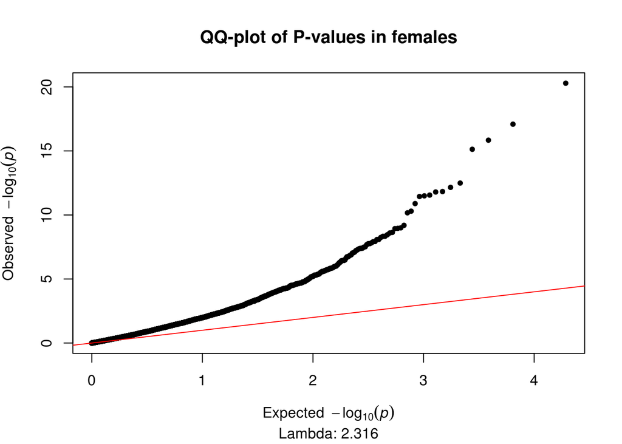

### Model 4 (4SV)

The ANOVA of diagnosis has been run with 4 SVs. Tables of the top 1000 DMPs have been produced for each variable of interest.

#### Top DMPs

**ANOVA:**  
44 probes pass the epigenome-wide significance threshold of 2.4x10-7  
*The top 50 diagnosis associated DMPs:*

| ProbeID | Position | F | p (F) | FDR.Anova | Difference | CI lower | CI upper | pCvM | FDR | Difference | CI lower | CI upper | pCvA | FDR | Difference | CI lower | CI upper | pMvA | FDR | UCSC Gene | UCSC Gene Group | UCSC Relation to CpG Island | Gene Closest TSS | Distance Closest TSS | GREAT Annotation 1 | GREAT Annotation 2 |
| --- | --- | --- | --- | --- | --- | --- | --- | --- | --- | --- | --- | --- | --- | --- | --- | --- | --- | --- | --- | --- | --- | --- | --- | --- | --- | --- |
| cg22822140 | chr X: 153046577 | 59.413 | 3.25e-20 | 3.14e-16 | 0.001 | -0.021 | 0.023 | 0.991 | 1 | -0.087 | -0.109 | -0.065 | 4.85e-14 | 4.68e-10 | -0.088 | -0.11 | -0.067 | 4.88e-14 | 1.32e-10 | SRPK3;SRPK3;SRPK3 | 1stExon;1stExon;1stExon | Island | SRPK3 | 122 | SRPK3 (122) | (NA) |
| cg12230162 | chr X: 153046482 | 47.451 | 4.81e-17 | 2.32e-13 | 0.010 | -0.015 | 0.035 | 0.611 | 1 | -0.083 | -0.108 | -0.058 | 1.48e-12 | 3.57e-09 | -0.093 | -0.117 | -0.068 | 5.12e-14 | 1.32e-10 | SRPK3;SRPK3;SRPK3;SRPK3;SRPK3;SRPK3 | 5'UTR;1stExon;1stExon;5'UTR;5'UTR;1stExon | Island | SRPK3 | 27 | SRPK3 (27) | (NA) |
| cg24496423 | chr X: 153046480 | 46.804 | 7.28e-17 | 2.34e-13 | 0.006 | -0.013 | 0.026 | 0.746 | 1 | -0.066 | -0.086 | -0.046 | 9.98e-13 | 3.51e-09 | -0.072 | -0.092 | -0.053 | 5.47e-14 | 1.32e-10 | SRPK3;SRPK3;SRPK3;SRPK3;SRPK3;SRPK3 | 5'UTR;1stExon;1stExon;5'UTR;5'UTR;1stExon | Island | SRPK3 | 25 | SRPK3 (25) | (NA) |
| cg13009143 | chr X: 100548223 | 42.583 | 1.14e-15 | 2.74e-12 | -0.015 | -0.021 | -0.008 | 1.66e-06 | 6.66e-04 | 0.011 | 0.004 | 0.018 | 4.27e-04 | 0.032 | 0.026 | 0.019 | 0.033 | 4.77e-14 | 1.32e-10 | TAF7L | TSS200 | S_Shore | TAF7L | -164 | TAF7L (-165) | (NA) |
| cg24605338 | chr X: 17395856 | 32.142 | 1.55e-12 | 2.99e-09 | -0.037 | -0.048 | -0.026 | 5.92e-13 | 5.71e-09 | -0.02 | -0.031 | -0.009 | 1.09e-04 | 0.013 | 0.017 | 0.006 | 0.028 | 7.39e-04 | 0.061 | NHS | Body | S_Shore | NHS | 2314 | SCML1 (-359735) | NHS (2314) |
| cg16529483 | chr X: 153046451 | 31.708 | 2.12e-12 | 3.42e-09 | -0.004 | -0.028 | 0.021 | 0.933 | 1 | -0.073 | -0.097 | -0.048 | 1.60e-10 | 2.20e-07 | -0.069 | -0.093 | -0.045 | 5.74e-10 | 6.15e-07 | SRPK3;SRPK3;SRPK3 | TSS200;TSS200;TSS200 | Island | SRPK3 | -4 | SRPK3 (-4) | (NA) |
| cg12468189 | chr X: 153046767 | 31.393 | 2.67e-12 | 3.68e-09 | -0.023 | -0.038 | -0.008 | 0.001 | 0.072 | -0.052 | -0.067 | -0.036 | 1.09e-12 | 3.51e-09 | -0.029 | -0.044 | -0.014 | 4.29e-05 | 0.009 | SRPK3;SRPK3;SRPK3 | Body;Body;Body | Island | SRPK3 | 312 | SRPK3 (312) | (NA) |
| cg03360001 | chr X: 53453272 | 31.169 | 3.14e-12 | 3.79e-09 | -0.009 | -0.015 | -0.003 | 0.001 | 0.065 | 0.011 | 0.005 | 0.017 | 1.26e-04 | 0.014 | 0.02 | 0.014 | 0.026 | 1.17e-12 | 2.27e-09 | RIBC1;RIBC1 | Body;Body | S_Shelf | RIBC1 | 3434 | SMC1A (-3655) | (NA) |
| cg16152676 | chr X: 10126878 | 30.975 | 3.62e-12 | 3.88e-09 | 0.038 | 0.024 | 0.053 | 1.02e-08 | 1.09e-05 | -0.006 | -0.020 | 0.009 | 0.624 | 1 | -0.044 | -0.058 | -0.029 | 5.33e-11 | 7.34e-08 | CLCN4 | 5'UTR | Island | CLCN4 | 550 | CLCN4 (1894) | MID1 (724930) |
| cg19938385 | chr X: 107020894 | 30.002 | 7.38e-12 | 7.12e-09 | -0.047 | -0.065 | -0.029 | 1.84e-08 | 1.62e-05 | -0.056 | -0.075 | -0.038 | 5.75e-11 | 1.11e-07 | -0.009 | -0.027 | 0.009 | 0.471 | 1 |  |  | S_Shore | TSC22D3 | -1692 | TSC22D3 (-1878) | (NA) |
| cg09768654 | chr X: 153046386 | 29.718 | 9.10e-12 | 7.98e-09 | 0.012 | -0.01 | 0.035 | 0.402 | 1 | -0.057 | -0.080 | -0.034 | 6.74e-08 | 4.64e-05 | -0.07 | -0.092 | -0.047 | 3.87e-11 | 6.23e-08 | SRPK3;SRPK3;SRPK3 | TSS200;TSS200;TSS200 | Island | SRPK3 | -69 | SRPK3 (-69) | (NA) |
| cg19280671 | chr X: 149013642 | 28.991 | 1.56e-11 | 1.25e-08 | 0.016 | 0.01 | 0.022 | 1.94e-09 | 3.73e-06 | 7.25e-05 | -0.006 | 0.006 | 1 | 1 | -0.016 | -0.022 | -0.01 | 1.92e-09 | 1.86e-06 | MAGEA8;MAGEA8;MAGEA8 | Body;Body;Body |  | MAGEA8 | 596 | MAMLD1 (-517908) | MAGEA8 (3702) |
| cg21252909 | chr X: 30326328 | 25.637 | 1.95e-10 | 1.45e-07 | 0.037 | 0.014 | 0.060 | 5.65e-04 | 0.038 | -0.032 | -0.055 | -0.009 | 0.004 | 0.137 | -0.069 | -0.091 | -0.046 | 7.77e-11 | 9.37e-08 | NR0B1 | 1stExon | N_Shore | NR0B1 | 1167 | NR0B1 (1166) | (NA) |
| cg17003204 | chr X: 102861456 | 25.518 | 2.14e-10 | 1.47e-07 | -0.031 | -0.042 | -0.020 | 1.20e-09 | 3.73e-06 | -0.005 | -0.016 | 0.006 | 0.483 | 1 | 0.025 | 0.014 | 0.036 | 4.06e-07 | 1.96e-04 | TCEAL3;TCEAL3 | TSS1500;TSS1500 | N_Shore | TCEAL3 | -1377 | TCEAL3 (-1377) | (NA) |
| cg17405188 | chr X: 73164102 | 25.104 | 2.94e-10 | 1.89e-07 | 0.006 | 0.001 | 0.011 | 0.008 | 0.194 | 0.014 | 0.010 | 0.019 | 1.31e-10 | 2.11e-07 | 0.008 | 0.004 | 0.013 | 1.73e-04 | 0.023 | LOC554203 | TSS200 | Island | JPX | -56 | ZCCHC13 (-359922) | CHIC1 (381119) |
| cg11179997 | chr X: 119125670 | 23.755 | 8.34e-10 | 4.75e-07 | 0.028 | 0.017 | 0.039 | 6.36e-08 | 4.72e-05 | -3.71e-04 | -0.012 | 0.011 | 0.997 | 1 | -0.028 | -0.039 | -0.017 | 3.72e-08 | 2.25e-05 |  |  | Island | AK123976 | -44530 | NKAP (-47936) | RHOXF2 (86036) |
| cg17219209 | chr X: 149009840 | 23.750 | 8.37e-10 | 4.75e-07 | 0.022 | 0.014 | 0.030 | 2.62e-09 | 4.21e-06 | 0.005 | -0.003 | 0.013 | 0.363 | 1 | -0.017 | -0.025 | -0.009 | 2.19e-06 | 9.19e-04 | MAGEA8;MAGEA8;MAGEA8 | TSS200;TSS200;TSS200 |  | MAGEA8 | -100 | MAGEA8 (-100) | (NA) |
| cg09661041 | chr X: 153141905 | 23.039 | 1.46e-09 | 7.82e-07 | -0.005 | -0.028 | 0.018 | 0.876 | 1 | -0.06 | -0.084 | -0.037 | 2.50e-08 | 2.57e-05 | -0.055 | -0.078 | -0.032 | 1.72e-07 | 9.19e-05 | L1CAM;L1CAM;L1CAM | TSS1500;TSS1500;TSS1500 |  | L1CAM | -506 | L1CAM (-507) | (NA) |
| cg25896901 | chr X: 125300481 | 22.598 | 2.06e-09 | 1.05e-06 | 0.011 | -0.014 | 0.036 | 0.564 | 1 | -0.056 | -0.082 | -0.031 | 1.81e-06 | 7.28e-04 | -0.067 | -0.093 | -0.042 | 7.33e-09 | 6.43e-06 | DCAF12L2 | TSS1500 | S_Shore | DCAF12L2 | -401 | DCAF12L1 (386360) | (NA) |
| cg15907464 | chr X: 70712790 | 22.343 | 2.52e-09 | 1.22e-06 | -0.035 | -0.047 | -0.022 | 1.07e-09 | 3.73e-06 | -0.02 | -0.032 | -0.007 | 6.51e-04 | 0.041 | 0.015 | 0.003 | 0.027 | 0.013 | 0.344 | BCYRN1;INGX | Body;TSS200 | Island | INGX | -186 | OGT (-40121) | TAF1 (126677) |
| cg14917571 | chr X: 79269151 | 21.837 | 3.76e-09 | 1.73e-06 | -0.052 | -0.07 | -0.033 | 1.56e-09 | 3.73e-06 | -0.029 | -0.048 | -0.01 | 0.001 | 0.058 | 0.023 | 0.004 | 0.041 | 0.011 | 0.312 | TBX22;TBX22 | TSS1500;TSS1500 |  | TBX22 | -1103 | ITM2A (-646103) | TBX22 (-8590) |
| cg16122592 | chr X: 26210712 | 21.199 | 6.25e-09 | 2.74e-06 | -0.030 | -0.041 | -0.018 | 1.63e-08 | 1.57e-05 | -0.024 | -0.036 | -0.013 | 4.82e-06 | 0.002 | 0.005 | -0.006 | 0.017 | 0.503 | 1 | MAGEB6 | 5'UTR |  | MAGEB6 | 156 | MAGEB6 (156) | (NA) |
| cg07069575 | chr X: 49688313 | 21.087 | 6.83e-09 | 2.87e-06 | 0.007 | -0.004 | 0.019 | 0.315 | 1 | -0.024 | -0.035 | -0.012 | 1.64e-05 | 0.004 | -0.031 | -0.042 | -0.019 | 1.03e-08 | 8.31e-06 | CLCN5;CLCN5 | 5'UTR;5'UTR | S_Shore | CLCN5 | 1089 | CLCN5 (1089) | AKAP4 (277350) |
| cg22926378 | chr X: 6144633 | 20.941 | 7.67e-09 | 3.08e-06 | 0.014 | 0.007 | 0.021 | 1.35e-05 | 0.003 | -0.004 | -0.011 | 0.003 | 0.361 | 1 | -0.018 | -0.025 | -0.011 | 1.65e-08 | 1.14e-05 | NLGN4X;NLGN4X | 5'UTR;5'UTR | Island | NLGN4X | 483 | NLGN4X (2072) | (NA) |
| cg17513789 | chr X: 73073251 | 20.762 | 8.85e-09 | 3.42e-06 | -0.039 | -0.053 | -0.025 | 4.02e-09 | 5.54e-06 | -0.017 | -0.032 | -0.003 | 0.015 | 0.275 | 0.022 | 0.007 | 0.036 | 0.001 | 0.089 | XIST | TSS1500 |  | XIST | -663 | ZCCHC13 (-450773) | CHIC1 (290268) |
| cg12039689 | chr X: 153141750 | 20.656 | 9.65e-09 | 3.58e-06 | -0.018 | -0.039 | 0.003 | 0.104 | 0.723 | -0.056 | -0.077 | -0.035 | 8.30e-09 | 1.00e-05 | -0.038 | -0.058 | -0.017 | 7.43e-05 | 0.012 | L1CAM;L1CAM;L1CAM | TSS1500;TSS1500;TSS1500 |  | L1CAM | -351 | L1CAM (-352) | (NA) |
| cg09513996 | chr X: 48685182 | 20.297 | 1.29e-08 | 4.60e-06 | 0.006 | -0.007 | 0.020 | 0.516 | 1 | -0.028 | -0.041 | -0.014 | 9.02e-06 | 0.002 | -0.034 | -0.047 | -0.021 | 3.18e-08 | 2.05e-05 |  |  | Island | ERAS | -2100 | ERAS (-2100) | (NA) |
| cg06452970 | chr X: 13835264 | 19.822 | 1.89e-08 | 6.47e-06 | 0.046 | 0.027 | 0.065 | 1.46e-07 | 8.81e-05 | 0.005 | -0.014 | 0.024 | 0.79 | 1 | -0.04 | -0.059 | -0.022 | 3.01e-06 | 0.001 | GPM6B;GPM6B;GPM6B;GPM6B;GPM6B;GPM6B;GPM6B | 1stExon;5'UTR;5'UTR;Body;5'UTR;1stExon;1stExon |  | GPM6B | 50 | GPM6B (49) | (NA) |
| cg08630881 | chr X: 70713213 | 19.785 | 1.94e-08 | 6.47e-06 | -0.029 | -0.039 | -0.018 | 9.94e-09 | 1.09e-05 | -0.018 | -0.029 | -0.007 | 5.64e-04 | 0.038 | 0.011 | 1.53e-04 | 0.022 | 0.046 | 0.64 | BCYRN1;INGX | Body;TSS1500 | S_Shore | INGX | -609 | OGT (-39698) | TAF1 (127100) |
| cg01737010 | chr X: 101772014 | 19.725 | 2.04e-08 | 6.55e-06 | 0.008 | -0.002 | 0.017 | 0.151 | 0.842 | -0.018 | -0.027 | -0.008 | 1.28e-04 | 0.014 | -0.025 | -0.035 | -0.016 | 1.65e-08 | 1.14e-05 | TMSB15A | TSS1500 | S_Shore | TMSB15A | -315 | TMSB15A (-316) | (NA) |
| cg04768884 | chr X: 19443172 | 19.687 | 2.10e-08 | 6.55e-06 | 0.005 | -0.009 | 0.019 | 0.645 | 1 | 0.034 | 0.020 | 0.048 | 9.93e-08 | 6.38e-05 | 0.029 | 0.015 | 0.043 | 4.30e-06 | 0.001 | MAP3K15 | Body |  | MAP3K15 | 35099 | PDHA1 (81162) | MAP3K15 (90206) |
| cg26484667 | chr X: 2733164 | 19.259 | 2.98e-08 | 8.97e-06 | -0.027 | -0.038 | -0.016 | 2.34e-07 | 1.25e-04 | -0.003 | -0.014 | 0.009 | 0.815 | 1 | 0.024 | 0.013 | 0.035 | 3.81e-06 | 0.001 | XG;XG;XG | 3'UTR;3'UTR;3'UTR |  | GYG2 | -13698 | GYG2 (-13698) | XG (63072) |
| ch.X.153018199F | chr X: 153365005 | 19.155 | 3.24e-08 | 9.47e-06 | -0.011 | -0.016 | -0.007 | 2.53e-08 | 2.03e-05 | -0.004 | -0.008 | 5.89e-04 | 0.104 | 0.734 | 0.007 | 0.003 | 0.012 | 2.68e-04 | 0.029 |  |  | S_Shore | MECP2 | -1817 | MECP2 (-1818) | (NA) |
| cg04710661 | chr X: 2848381 | 18.716 | 4.64e-08 | 1.32e-05 | 0.007 | -3.24e-05 | 0.014 | 0.051 | 0.526 | 0.018 | 0.011 | 0.024 | 2.67e-08 | 2.57e-05 | 0.011 | 0.004 | 0.018 | 5.93e-04 | 0.053 | ARSD;ARSD | TSS1500;TSS1500 | S_Shore | ARSD | -965 | ARSD (-966) | (NA) |
| cg00072799 | chr X: 78427682 | 18.502 | 5.52e-08 | 1.52e-05 | -0.007 | -0.021 | 0.007 | 0.435 | 1 | -0.035 | -0.049 | -0.02 | 1.24e-07 | 7.46e-05 | -0.027 | -0.041 | -0.013 | 2.35e-05 | 0.005 | GPR174;GPR174 | 1stExon;3'UTR |  | GPR174 | 1214 | GPR174 (1214) | ITM2A (195366) |
| cg21364342 | chr X: 107226611 | 18.362 | 6.19e-08 | 1.66e-05 | -0.019 | -0.027 | -0.010 | 5.32e-06 | 0.002 | -0.021 | -0.030 | -0.012 | 3.58e-07 | 2.03e-04 | -0.002 | -0.011 | 0.006 | 0.79 | 1 | TEX13B | TSS1500 |  | TEX13B | -1011 | VSIG1 (-61588) | MID2 (157528) |
| cg07344627 | chr X: 125687011 | 18.140 | 7.43e-08 | 1.90e-05 | -0.032 | -0.056 | -0.008 | 0.006 | 0.173 | -0.062 | -0.087 | -0.038 | 3.17e-08 | 2.59e-05 | -0.03 | -0.055 | -0.006 | 0.009 | 0.272 | DCAF12L1 | TSS200 | S_Shore | DCAF12L1 | -169 | DCAF12L1 (-170) | (NA) |
| cg22574818 | chr X: 55479616 | 18.134 | 7.47e-08 | 1.90e-05 | -0.031 | -0.054 | -0.008 | 0.004 | 0.142 | -0.059 | -0.082 | -0.036 | 3.23e-08 | 2.59e-05 | -0.028 | -0.051 | -0.005 | 0.013 | 0.337 | MAGEH1;MAGEH1 | 1stExon;3'UTR |  | MAGEH1 | 1079 | MAGEH1 (1079) | USP51 (36014) |
| cg08464958 | chr X: 2852845 | 17.966 | 8.57e-08 | 2.12e-05 | -0.022 | -0.032 | -0.013 | 3.11e-07 | 1.58e-04 | -0.004 | -0.013 | 0.006 | 0.628 | 1 | 0.018 | 0.009 | 0.028 | 1.99e-05 | 0.004 | ARSE | 3'UTR |  | ARSD | -5429 | ARSD (-5430) | ARSE (29648) |
| cg00805156 | chr X: 3264341 | 17.621 | 1.14e-07 | 2.75e-05 | 0.034 | 0.017 | 0.051 | 8.55e-06 | 0.002 | 0.039 | 0.022 | 0.056 | 6.02e-07 | 3.06e-04 | 0.005 | -0.012 | 0.021 | 0.792 | 1 | MXRA5 | 5'UTR | Island | MXRA5 | 343 | MXRA5 (342) | (NA) |
| cg23914849 | chr X: 52950051 | 17.503 | 1.26e-07 | 2.95e-05 | 0.003 | 5.88e-04 | 0.005 | 0.009 | 0.208 | 0.006 | 0.003 | 0.008 | 5.43e-08 | 4.03e-05 | 0.003 | 5.98e-04 | 0.005 | 0.008 | 0.265 |  |  | Island | FAM156A | 13799 | FAM156B (21967) | FAM156A (74599) |
| cg00190642 | chr X: 103268431 | 17.159 | 1.67e-07 | 3.83e-05 | -0.013 | -0.028 | 0.003 | 0.126 | 0.772 | 0.024 | 0.009 | 0.04 | 7.17e-04 | 0.044 | 0.037 | 0.022 | 0.052 | 1.08e-07 | 6.14e-05 | H2BFWT;MIR1256 | TSS200;Body | Island | H2BFWT | -175 | H2BFWT (-176) | (NA) |
| cg09953945 | chr X: 150345040 | 17.083 | 1.78e-07 | 3.99e-05 | -0.025 | -0.035 | -0.015 | 8.70e-08 | 5.99e-05 | -0.015 | -0.025 | -0.005 | 0.002 | 0.1 | 0.01 | 8.99e-06 | 0.02 | 0.05 | 0.672 | GPR50 | TSS200 | N_Shore | GPR50 | -15 | GPR50 (-15) | (NA) |
| cg24834461 | chr X: 153637645 | 16.923 | 2.03e-07 | 4.45e-05 | 0.017 | 0.01 | 0.024 | 1.02e-07 | 6.55e-05 | 0.01 | 0.003 | 0.017 | 0.002 | 0.096 | -0.007 | -0.013 | 1.49e-04 | 0.057 | 0.715 | DNASE1L1;DNASE1L1;DNASE1L1;DNASE1L1 | TSS200;5'UTR;5'UTR;5'UTR | N_Shelf | DNASE1L1 | -70 | TAZ (-2231) | (NA) |
| cg25433595 | chr X: 100183764 | 16.394 | 3.16e-07 | 6.77e-05 | 0.043 | 0.025 | 0.062 | 3.82e-07 | 1.84e-04 | 0.033 | 0.014 | 0.052 | 1.68e-04 | 0.016 | -0.011 | -0.029 | 0.008 | 0.374 | 1 | XKRX;XKRX | 5'UTR;1stExon | N_Shore | XKRX | 134 | XKRX (133) | (NA) |
| cg24352688 | chr X: 13751727 | 16.301 | 3.41e-07 | 7.16e-05 | 0.002 | -0.005 | 0.008 | 0.853 | 1 | 0.015 | 0.008 | 0.022 | 2.07e-06 | 7.97e-04 | 0.014 | 0.007 | 0.021 | 1.53e-05 | 0.003 | TRAPPC2;OFD1;TRAPPC2;TRAPPC2 | 5'UTR;TSS1500;5'UTR;5'UTR | N_Shore | TRAPPC2 | 1027 | OFD1 (-1104) | TRAPPC2 (1026) |
| cg04817724 | chr X: 103809991 | 16.228 | 3.63e-07 | 7.45e-05 | 0.048 | 0.028 | 0.069 | 1.62e-07 | 9.21e-05 | 0.024 | 0.004 | 0.045 | 0.015 | 0.281 | -0.024 | -0.044 | -0.004 | 0.013 | 0.344 | IL1RAPL2 | TSS1500 | Island | IL1RAPL2 | -1004 | IL1RAPL2 (-1004) | (NA) |
| cg00632130 | chr X: 47931806 | 16.122 | 3.96e-07 | 7.97e-05 | -0.009 | -0.022 | 0.005 | 0.297 | 1 | 0.023 | 0.009 | 0.037 | 3.42e-04 | 0.028 | 0.031 | 0.018 | 0.045 | 3.89e-07 | 1.96e-04 | ZNF630 | TSS1500 | S_Shore | ZNF630 | -781 | ZNF630 (-1299) | (NA) |
| cg00123001 | chr X: 13395880 | 15.727 | 5.52e-07 | 1.09e-04 | -0.015 | -0.022 | -0.008 | 8.64e-06 | 0.002 | -0.015 | -0.023 | -0.008 | 6.54e-06 | 0.002 | -3.92e-04 | -0.008 | 0.007 | 0.991 | 1 |  |  | N_Shore | LOC100133123 | 42521 | EGFL6 (-191813) | ATXN3L (-57363) |
| cg13788827 | chr X: 12990209 | 15.683 | 5.73e-07 | 1.11e-04 | -0.005 | -0.014 | 0.004 | 0.34 | 1 | 0.015 | 0.006 | 0.024 | 3.48e-04 | 0.028 | 0.02 | 0.011 | 0.029 | 6.05e-07 | 2.78e-04 |  |  | N_Shelf | TMSB4X | -3016 | TMSB4X (-3016) | (NA) |

**CTL vs MCI:**  
18 probes pass the epigenome-wide significance threshold of 2.4x10-7

*The top 50 CTL vs MCI associated DMPs:*

| ProbeID | Position | F | p (F) | FDR.Anova | Difference | CI lower | CI upper | pCvM | FDR | Difference | CI lower | CI upper | pCvA | FDR | Difference | CI lower | CI upper | pMvA | FDR | UCSC Gene | UCSC Gene Group | UCSC Relation to CpG Island | Gene Closest TSS | Distance Closest TSS | GREAT Annotation 1 | GREAT Annotation 2 |
| --- | --- | --- | --- | --- | --- | --- | --- | --- | --- | --- | --- | --- | --- | --- | --- | --- | --- | --- | --- | --- | --- | --- | --- | --- | --- | --- |
| cg24605338 | chr X: 17395856 | 32.142 | 1.55e-12 | 2.99e-09 | -0.037 | -0.048 | -0.026 | 5.92e-13 | 5.71e-09 | -0.02 | -0.031 | -0.009 | 1.09e-04 | 0.013 | 0.017 | 0.006 | 0.028 | 7.39e-04 | 0.061 | NHS | Body | S_Shore | NHS | 2314 | SCML1 (-359735) | NHS (2314) |
| cg15907464 | chr X: 70712790 | 22.343 | 2.52e-09 | 1.22e-06 | -0.035 | -0.047 | -0.022 | 1.07e-09 | 3.73e-06 | -0.02 | -0.032 | -0.007 | 6.51e-04 | 0.041 | 0.015 | 0.003 | 0.027 | 0.013 | 0.344 | BCYRN1;INGX | Body;TSS200 | Island | INGX | -186 | OGT (-40121) | TAF1 (126677) |
| cg17003204 | chr X: 102861456 | 25.518 | 2.14e-10 | 1.47e-07 | -0.031 | -0.042 | -0.020 | 1.20e-09 | 3.73e-06 | -0.005 | -0.016 | 0.006 | 0.483 | 1 | 0.025 | 0.014 | 0.036 | 4.06e-07 | 1.96e-04 | TCEAL3;TCEAL3 | TSS1500;TSS1500 | N_Shore | TCEAL3 | -1377 | TCEAL3 (-1377) | (NA) |
| cg14917571 | chr X: 79269151 | 21.837 | 3.76e-09 | 1.73e-06 | -0.052 | -0.070 | -0.033 | 1.56e-09 | 3.73e-06 | -0.029 | -0.048 | -0.01 | 0.001 | 0.058 | 0.023 | 0.004 | 0.041 | 0.011 | 0.312 | TBX22;TBX22 | TSS1500;TSS1500 |  | TBX22 | -1103 | ITM2A (-646103) | TBX22 (-8590) |
| cg19280671 | chr X: 149013642 | 28.991 | 1.56e-11 | 1.25e-08 | 0.016 | 0.010 | 0.022 | 1.94e-09 | 3.73e-06 | 7.25e-05 | -0.006 | 0.006 | 1 | 1 | -0.016 | -0.022 | -0.01 | 1.92e-09 | 1.86e-06 | MAGEA8;MAGEA8;MAGEA8 | Body;Body;Body |  | MAGEA8 | 596 | MAMLD1 (-517908) | MAGEA8 (3702) |
| cg17219209 | chr X: 149009840 | 23.750 | 8.37e-10 | 4.75e-07 | 0.022 | 0.014 | 0.030 | 2.62e-09 | 4.21e-06 | 0.005 | -0.003 | 0.013 | 0.363 | 1 | -0.017 | -0.025 | -0.009 | 2.19e-06 | 9.19e-04 | MAGEA8;MAGEA8;MAGEA8 | TSS200;TSS200;TSS200 |  | MAGEA8 | -100 | MAGEA8 (-100) | (NA) |
| cg17513789 | chr X: 73073251 | 20.762 | 8.85e-09 | 3.42e-06 | -0.039 | -0.053 | -0.025 | 4.02e-09 | 5.54e-06 | -0.017 | -0.032 | -0.003 | 0.015 | 0.275 | 0.022 | 0.007 | 0.036 | 0.001 | 0.089 | XIST | TSS1500 |  | XIST | -663 | ZCCHC13 (-450773) | CHIC1 (290268) |
| cg08630881 | chr X: 70713213 | 19.785 | 1.94e-08 | 6.47e-06 | -0.029 | -0.039 | -0.018 | 9.94e-09 | 1.09e-05 | -0.018 | -0.029 | -0.007 | 5.64e-04 | 0.038 | 0.011 | 1.53e-04 | 0.022 | 0.046 | 0.64 | BCYRN1;INGX | Body;TSS1500 | S_Shore | INGX | -609 | OGT (-39698) | TAF1 (127100) |
| cg16152676 | chr X: 10126878 | 30.975 | 3.62e-12 | 3.88e-09 | 0.038 | 0.024 | 0.053 | 1.02e-08 | 1.09e-05 | -0.006 | -0.020 | 0.009 | 0.624 | 1 | -0.044 | -0.058 | -0.029 | 5.33e-11 | 7.34e-08 | CLCN4 | 5'UTR | Island | CLCN4 | 550 | CLCN4 (1894) | MID1 (724930) |
| cg16122592 | chr X: 26210712 | 21.199 | 6.25e-09 | 2.74e-06 | -0.030 | -0.041 | -0.018 | 1.63e-08 | 1.57e-05 | -0.024 | -0.036 | -0.013 | 4.82e-06 | 0.002 | 0.005 | -0.006 | 0.017 | 0.503 | 1 | MAGEB6 | 5'UTR |  | MAGEB6 | 156 | MAGEB6 (156) | (NA) |
| cg19938385 | chr X: 107020894 | 30.002 | 7.38e-12 | 7.12e-09 | -0.047 | -0.065 | -0.029 | 1.84e-08 | 1.62e-05 | -0.056 | -0.075 | -0.038 | 5.75e-11 | 1.11e-07 | -0.009 | -0.027 | 0.009 | 0.471 | 1 |  |  | S_Shore | TSC22D3 | -1692 | TSC22D3 (-1878) | (NA) |
| ch.X.153018199F | chr X: 153365005 | 19.155 | 3.24e-08 | 9.47e-06 | -0.011 | -0.016 | -0.007 | 2.53e-08 | 2.03e-05 | -0.004 | -0.008 | 5.89e-04 | 0.104 | 0.734 | 0.007 | 0.003 | 0.012 | 2.68e-04 | 0.029 |  |  | S_Shore | MECP2 | -1817 | MECP2 (-1818) | (NA) |
| cg11179997 | chr X: 119125670 | 23.755 | 8.34e-10 | 4.75e-07 | 0.028 | 0.017 | 0.039 | 6.36e-08 | 4.72e-05 | -3.71e-04 | -0.012 | 0.011 | 0.997 | 1 | -0.028 | -0.039 | -0.017 | 3.72e-08 | 2.25e-05 |  |  | Island | AK123976 | -44530 | NKAP (-47936) | RHOXF2 (86036) |
| cg09953945 | chr X: 150345040 | 17.083 | 1.78e-07 | 3.99e-05 | -0.025 | -0.035 | -0.015 | 8.70e-08 | 5.99e-05 | -0.015 | -0.025 | -0.005 | 0.002 | 0.1 | 0.01 | 8.99e-06 | 0.02 | 0.05 | 0.672 | GPR50 | TSS200 | N_Shore | GPR50 | -15 | GPR50 (-15) | (NA) |
| cg24834461 | chr X: 153637645 | 16.923 | 2.03e-07 | 4.45e-05 | 0.017 | 0.010 | 0.024 | 1.02e-07 | 6.55e-05 | 0.01 | 0.003 | 0.017 | 0.002 | 0.096 | -0.007 | -0.013 | 1.49e-04 | 0.057 | 0.715 | DNASE1L1;DNASE1L1;DNASE1L1;DNASE1L1 | TSS200;5'UTR;5'UTR;5'UTR | N_Shelf | DNASE1L1 | -70 | TAZ (-2231) | (NA) |
| cg06452970 | chr X: 13835264 | 19.822 | 1.89e-08 | 6.47e-06 | 0.046 | 0.027 | 0.065 | 1.46e-07 | 8.81e-05 | 0.005 | -0.014 | 0.024 | 0.79 | 1 | -0.04 | -0.059 | -0.022 | 3.01e-06 | 0.001 | GPM6B;GPM6B;GPM6B;GPM6B;GPM6B;GPM6B;GPM6B | 1stExon;5'UTR;5'UTR;Body;5'UTR;1stExon;1stExon |  | GPM6B | 50 | GPM6B (49) | (NA) |
| cg04817724 | chr X: 103809991 | 16.228 | 3.63e-07 | 7.45e-05 | 0.048 | 0.028 | 0.069 | 1.62e-07 | 9.21e-05 | 0.024 | 0.004 | 0.045 | 0.015 | 0.281 | -0.024 | -0.044 | -0.004 | 0.013 | 0.344 | IL1RAPL2 | TSS1500 | Island | IL1RAPL2 | -1004 | IL1RAPL2 (-1004) | (NA) |
| cg26484667 | chr X: 2733164 | 19.259 | 2.98e-08 | 8.97e-06 | -0.027 | -0.038 | -0.016 | 2.34e-07 | 1.25e-04 | -0.003 | -0.014 | 0.009 | 0.815 | 1 | 0.024 | 0.013 | 0.035 | 3.81e-06 | 0.001 | XG;XG;XG | 3'UTR;3'UTR;3'UTR |  | GYG2 | -13698 | GYG2 (-13698) | XG (63072) |
| cg08464958 | chr X: 2852845 | 17.966 | 8.57e-08 | 2.12e-05 | -0.022 | -0.032 | -0.013 | 3.11e-07 | 1.58e-04 | -0.004 | -0.013 | 0.006 | 0.628 | 1 | 0.018 | 0.009 | 0.028 | 1.99e-05 | 0.004 | ARSE | 3'UTR |  | ARSD | -5429 | ARSD (-5430) | ARSE (29648) |
| cg25433595 | chr X: 100183764 | 16.394 | 3.16e-07 | 6.77e-05 | 0.043 | 0.025 | 0.062 | 3.82e-07 | 1.84e-04 | 0.033 | 0.014 | 0.052 | 1.68e-04 | 0.016 | -0.011 | -0.029 | 0.008 | 0.374 | 1 | XKRX;XKRX | 5'UTR;1stExon | N_Shore | XKRX | 134 | XKRX (133) | (NA) |
| cg25177692 | chr X: 129193893 | 15.342 | 7.64e-07 | 1.37e-04 | -0.025 | -0.036 | -0.014 | 7.65e-07 | 3.51e-04 | -0.019 | -0.030 | -0.007 | 4.06e-04 | 0.032 | 0.007 | -0.004 | 0.018 | 0.328 | 1 |  |  | N_Shore | BCORL1 | 34929 | ELF4 (50794) | BCORL1 (54730) |
| cg14306994 | chr X: 49019804 | 14.082 | 2.23e-06 | 3.26e-04 | 0.030 | 0.016 | 0.043 | 1.32e-06 | 5.71e-04 | 0.012 | -0.002 | 0.025 | 0.1 | 0.724 | -0.018 | -0.031 | -0.005 | 0.005 | 0.194 | MAGIX;MAGIX;MAGIX;MAGIX | Body;Body;Body;TSS1500 | Island | MAGIX | -316 | GPKOW (-39726) | PLP2 (-8379) |
| cg08867267 | chr X: 130033963 | 13.849 | 2.72e-06 | 3.75e-04 | -0.022 | -0.032 | -0.012 | 1.36e-06 | 5.71e-04 | -0.013 | -0.023 | -0.003 | 0.009 | 0.217 | 0.009 | -5.55e-04 | 0.019 | 0.069 | 0.775 | ENOX2;ENOX2 | 5'UTR;5'UTR | N_Shelf | ENOX2 | 3245 | ENOX2 (3244) | RBMX2 (498021) |
| cg13009143 | chr X: 100548223 | 42.583 | 1.14e-15 | 2.74e-12 | -0.015 | -0.021 | -0.008 | 1.66e-06 | 6.66e-04 | 0.011 | 0.004 | 0.018 | 4.27e-04 | 0.032 | 0.026 | 0.019 | 0.033 | 4.77e-14 | 1.32e-10 | TAF7L | TSS200 | S_Shore | TAF7L | -164 | TAF7L (-165) | (NA) |
| cg27558057 | chr X: 70712724 | 13.186 | 4.82e-06 | 6.04e-04 | -0.029 | -0.042 | -0.015 | 2.68e-06 | 0.001 | -0.012 | -0.026 | 0.001 | 0.088 | 0.69 | 0.017 | 0.003 | 0.03 | 0.01 | 0.283 | BCYRN1;INGX | Body;TSS200 | Island | INGX | -120 | OGT (-40187) | TAF1 (126611) |
| cg01325935 | chr X: 67905522 | 13.137 | 5.03e-06 | 6.22e-04 | -0.016 | -0.024 | -0.009 | 3.28e-06 | 0.001 | -0.006 | -0.014 | 0.002 | 0.148 | 0.865 | 0.01 | 0.003 | 0.018 | 0.005 | 0.199 | STARD8;STARD8 | 5'UTR;Body | N_Shore | STARD8 | -7959 | EFNB1 (-143317) | STARD8 (38012) |
| cg25396787 | chr X: 3733991 | 12.877 | 6.30e-06 | 6.90e-04 | 0.027 | 0.014 | 0.039 | 3.29e-06 | 0.001 | 0.016 | 0.003 | 0.028 | 0.011 | 0.244 | -0.011 | -0.024 | 0.001 | 0.092 | 0.892 |  |  | Island | TRNA_Ile | 22500 | PRKX (-102317) | (NA) |
| cg11315455 | chr X: 122997585 | 14.276 | 1.89e-06 | 2.96e-04 | -0.026 | -0.038 | -0.014 | 3.96e-06 | 0.001 | -0.005 | -0.017 | 0.007 | 0.588 | 1 | 0.021 | 0.009 | 0.033 | 2.40e-04 | 0.027 | XIAP | 5'UTR | S_Shelf | XIAP | 3569 | STAG2 (-96889) | XIAP (3569) |
| cg05547600 | chr X: 134847106 | 13.033 | 5.50e-06 | 6.39e-04 | -0.031 | -0.046 | -0.016 | 4.15e-06 | 0.001 | -0.011 | -0.026 | 0.004 | 0.207 | 0.984 | 0.02 | 0.006 | 0.035 | 0.003 | 0.157 | CT45A1 | TSS200 |  | CT45A1 | -78 | MMGT1 (209027) | ZNF449 (368411) |
| cg12461113 | chr X: 13587550 | 12.615 | 7.91e-06 | 8.20e-04 | -0.073 | -0.107 | -0.038 | 4.34e-06 | 0.001 | -0.031 | -0.066 | 0.004 | 0.089 | 0.691 | 0.042 | 0.007 | 0.076 | 0.013 | 0.344 | EGFL6;EGFL6 | TSS200;TSS200 | N_Shore | EGFL6 | -143 | EGFL6 (-143) | (NA) |
| cg10841064 | chr X: 22292462 | 12.511 | 8.65e-06 | 8.63e-04 | -0.031 | -0.046 | -0.016 | 4.70e-06 | 0.001 | -0.014 | -0.029 | 0.001 | 0.085 | 0.675 | 0.018 | 0.003 | 0.032 | 0.015 | 0.365 | ZNF645;ZNF645 | 3'UTR;1stExon |  | ZNF645 | 1433 | DDX53 (-725615) | ZNF645 (1433) |
| cg21364342 | chr X: 107226611 | 18.362 | 6.19e-08 | 1.66e-05 | -0.019 | -0.027 | -0.010 | 5.32e-06 | 0.002 | -0.021 | -0.030 | -0.012 | 3.58e-07 | 2.03e-04 | -0.002 | -0.011 | 0.006 | 0.79 | 1 | TEX13B | TSS1500 |  | TEX13B | -1011 | VSIG1 (-61588) | MID2 (157528) |
| cg25549901 | chr X: 137951118 | 14.200 | 2.02e-06 | 3.04e-04 | -0.021 | -0.031 | -0.011 | 5.34e-06 | 0.002 | -0.018 | -0.028 | -0.008 | 1.16e-04 | 0.013 | 0.003 | -0.007 | 0.013 | 0.778 | 1 | FGF13;FGF13;FGF13;FGF13 | 5'UTR;Body;TSS1500;Body |  | FGF13 | -1401 | FGF13 (336066) | (NA) |
| cg26468081 | chr X: 69501565 | 13.057 | 5.39e-06 | 6.39e-04 | -0.013 | -0.020 | -0.007 | 6.16e-06 | 0.002 | -0.004 | -0.010 | 0.003 | 0.384 | 1 | 0.01 | 0.003 | 0.016 | 0.001 | 0.085 | ARR3;RAB41 | Body;TSS1500 |  | RAB41 | -456 | RAB41 (-456) | (NA) |
| cg09979033 | chr X: 16726904 | 12.953 | 5.89e-06 | 6.53e-04 | -0.016 | -0.024 | -0.008 | 7.14e-06 | 0.002 | -0.012 | -0.020 | -0.004 | 7.84e-04 | 0.046 | 0.004 | -0.004 | 0.011 | 0.502 | 1 | CTPS2;CTPS2;CTPS2 | 5'UTR;5'UTR;5'UTR | N_Shelf | CTPS2 | 3436 | CTPS2 (4154) | S100G (58624) |
| cg00805156 | chr X: 3264341 | 17.621 | 1.14e-07 | 2.75e-05 | 0.034 | 0.017 | 0.051 | 8.55e-06 | 0.002 | 0.039 | 0.022 | 0.056 | 6.02e-07 | 3.06e-04 | 0.005 | -0.012 | 0.021 | 0.792 | 1 | MXRA5 | 5'UTR | Island | MXRA5 | 343 | MXRA5 (342) | (NA) |
| cg00123001 | chr X: 13395880 | 15.727 | 5.52e-07 | 1.09e-04 | -0.015 | -0.022 | -0.008 | 8.64e-06 | 0.002 | -0.015 | -0.023 | -0.008 | 6.54e-06 | 0.002 | -3.92e-04 | -0.008 | 0.007 | 0.991 | 1 |  |  | N_Shore | LOC100133123 | 42521 | EGFL6 (-191813) | ATXN3L (-57363) |
| cg25958561 | chr X: 110187179 | 12.508 | 8.67e-06 | 8.63e-04 | 0.029 | 0.015 | 0.043 | 8.92e-06 | 0.002 | 0.022 | 0.007 | 0.036 | 0.001 | 0.069 | -0.007 | -0.022 | 0.007 | 0.44 | 1 | PAK3;PAK3 | TSS1500;TSS1500 |  | PAK3 | -333 | PAK3 (-179125) | CHRDL1 (-148104) |
| cg07089438 | chr X: 133988190 | 11.444 | 2.20e-05 | 0.002 | -0.021 | -0.031 | -0.011 | 1.13e-05 | 0.003 | -0.011 | -0.022 | -9.67e-04 | 0.029 | 0.403 | 0.009 | -8.26e-04 | 0.02 | 0.078 | 0.823 | FAM122C;FAM122C | 3'UTR;Body |  | MOSPD1 | 45374 | PLAC1 (-195678) | MOSPD1 (61106) |
| cg17970282 | chr X: 70712810 | 11.504 | 2.09e-05 | 0.002 | -0.032 | -0.048 | -0.016 | 1.14e-05 | 0.003 | -0.014 | -0.030 | 0.002 | 0.093 | 0.705 | 0.018 | 0.002 | 0.034 | 0.023 | 0.459 | BCYRN1;INGX | Body;TSS1500 | Island | INGX | -206 | OGT (-40101) | TAF1 (126697) |
| cg05860920 | chr X: 11679501 | 11.668 | 1.81e-05 | 0.002 | 0.052 | 0.026 | 0.077 | 1.20e-05 | 0.003 | 0.034 | 0.008 | 0.06 | 0.006 | 0.183 | -0.018 | -0.043 | 0.008 | 0.238 | 1 | ARHGAP6;ARHGAP6 | Body;Body | N_Shelf | ARHGAP6 | 4320 | ARHGAP6 (4319) | AMELX (367969) |
| cg05889382 | chr X: 70887722 | 13.681 | 3.15e-06 | 4.22e-04 | -0.018 | -0.027 | -0.009 | 1.24e-05 | 0.003 | -0.016 | -0.026 | -0.007 | 8.73e-05 | 0.011 | 0.002 | -0.007 | 0.01 | 0.91 | 1 | BCYRN1 | Body | Island | LOC100132741 | -29323 | PIN4 (-513803) | CXCR3 (-49356) |
| cg16508637 | chr X: 132094977 | 12.965 | 5.84e-06 | 6.53e-04 | 0.022 | 0.011 | 0.034 | 1.34e-05 | 0.003 | 0.004 | -0.007 | 0.015 | 0.685 | 1 | -0.018 | -0.03 | -0.007 | 3.78e-04 | 0.036 | HS6ST2;HS6ST2 | 5'UTR;5'UTR | S_Shelf | HS6ST2 | 446 | HS6ST2 (445) | (NA) |
| cg22926378 | chr X: 6144633 | 20.941 | 7.67e-09 | 3.08e-06 | 0.014 | 0.007 | 0.021 | 1.35e-05 | 0.003 | -0.004 | -0.011 | 0.003 | 0.361 | 1 | -0.018 | -0.025 | -0.011 | 1.65e-08 | 1.14e-05 | NLGN4X;NLGN4X | 5'UTR;5'UTR | Island | NLGN4X | 483 | NLGN4X (2072) | (NA) |
| cg20881335 | chr X: 14547172 | 11.557 | 1.99e-05 | 0.002 | 0.062 | 0.031 | 0.093 | 1.38e-05 | 0.003 | 0.023 | -0.009 | 0.054 | 0.204 | 0.977 | -0.039 | -0.07 | -0.009 | 0.008 | 0.261 | GLRA2;GLRA2;GLRA2 | TSS1500;TSS1500;TSS1500 |  | GLRA2 | -247 | GLRA2 (-247) | (NA) |
| cg07892139 | chr X: 84192519 | 13.918 | 2.57e-06 | 3.59e-04 | -0.035 | -0.053 | -0.018 | 1.39e-05 | 0.003 | -0.033 | -0.051 | -0.015 | 5.22e-05 | 0.009 | 0.002 | -0.016 | 0.019 | 0.964 | 1 |  |  | S_Shelf | UBE2DNL | 3363 | APOOL (-66378) | UBE2DNL (3363) |
| cg18497064 | chr X: 134715899 | 11.459 | 2.17e-05 | 0.002 | -0.037 | -0.056 | -0.019 | 1.46e-05 | 0.003 | -0.014 | -0.033 | 0.005 | 0.194 | 0.955 | 0.023 | 0.005 | 0.042 | 0.009 | 0.281 | DDX26B | 3'UTR |  | DDX26B | 12638 | ZNF449 (237204) | MMGT1 (340234) |
| cg03035653 | chr X: 99662932 | 11.343 | 2.40e-05 | 0.002 | 0.036 | 0.018 | 0.054 | 1.77e-05 | 0.003 | 0.013 | -0.006 | 0.031 | 0.239 | 1 | -0.023 | -0.041 | -0.005 | 0.007 | 0.247 | PCDH19;PCDH19 | 1stExon;1stExon | Island | PCDH19 | 2339 | PCDH19 (2338) | (NA) |
| cg17397814 | chr X: 100670855 | 11.015 | 3.21e-05 | 0.002 | 0.042 | 0.021 | 0.064 | 1.80e-05 | 0.003 | 0.025 | 0.004 | 0.047 | 0.018 | 0.308 | -0.017 | -0.038 | 0.004 | 0.143 | 1 |  |  | N_Shelf | ARMCX4 | -2410 | ARMCX1 (-134658) | HNRNPH2 (7735) |
| cg25831435 | chr X: 137714452 | 11.153 | 2.84e-05 | 0.002 | -0.027 | -0.040 | -0.013 | 1.81e-05 | 0.003 | -0.017 | -0.031 | -0.004 | 0.009 | 0.222 | 0.009 | -0.004 | 0.023 | 0.222 | 1 | FGF13;FGF13;FGF13;FGF13;FGF13;FGF13 | 3'UTR;3'UTR;3'UTR;3'UTR;3'UTR;3'UTR |  | LOC158696 | -14653 | FGF13 (572732) | (NA) |

**CTL vs AD:**  
16 probes pass the epigenome-wide significance threshold of 2.4x10-7  
*The top 50 CTL vs AD associated DMPs:*

| ProbeID | Position | F | p (F) | FDR.Anova | Difference | CI lower | CI upper | pCvM | FDR | Difference | CI lower | CI upper | pCvA | FDR | Difference | CI lower | CI upper | pMvA | FDR | UCSC Gene | UCSC Gene Group | UCSC Relation to CpG Island | Gene Closest TSS | Distance Closest TSS | GREAT Annotation 1 | GREAT Annotation 2 |
| --- | --- | --- | --- | --- | --- | --- | --- | --- | --- | --- | --- | --- | --- | --- | --- | --- | --- | --- | --- | --- | --- | --- | --- | --- | --- | --- |
| cg22822140 | chr X: 153046577 | 59.413 | 3.25e-20 | 3.14e-16 | 0.001 | -0.021 | 0.023 | 0.991 | 1 | -0.087 | -0.109 | -0.065 | 4.85e-14 | 4.68e-10 | -0.088 | -0.11 | -0.067 | 4.88e-14 | 1.32e-10 | SRPK3;SRPK3;SRPK3 | 1stExon;1stExon;1stExon | Island | SRPK3 | 122 | SRPK3 (122) | (NA) |
| cg24496423 | chr X: 153046480 | 46.804 | 7.28e-17 | 2.34e-13 | 0.006 | -0.013 | 0.026 | 0.746 | 1 | -0.066 | -0.086 | -0.046 | 9.98e-13 | 3.51e-09 | -0.072 | -0.092 | -0.053 | 5.47e-14 | 1.32e-10 | SRPK3;SRPK3;SRPK3;SRPK3;SRPK3;SRPK3 | 5'UTR;1stExon;1stExon;5'UTR;5'UTR;1stExon | Island | SRPK3 | 25 | SRPK3 (25) | (NA) |
| cg12468189 | chr X: 153046767 | 31.393 | 2.67e-12 | 3.68e-09 | -0.023 | -0.038 | -0.008 | 0.001 | 0.072 | -0.052 | -0.067 | -0.036 | 1.09e-12 | 3.51e-09 | -0.029 | -0.044 | -0.014 | 4.29e-05 | 0.009 | SRPK3;SRPK3;SRPK3 | Body;Body;Body | Island | SRPK3 | 312 | SRPK3 (312) | (NA) |
| cg12230162 | chr X: 153046482 | 47.451 | 4.81e-17 | 2.32e-13 | 0.01 | -0.015 | 0.035 | 0.611 | 1 | -0.083 | -0.108 | -0.058 | 1.48e-12 | 3.57e-09 | -0.093 | -0.117 | -0.068 | 5.12e-14 | 1.32e-10 | SRPK3;SRPK3;SRPK3;SRPK3;SRPK3;SRPK3 | 5'UTR;1stExon;1stExon;5'UTR;5'UTR;1stExon | Island | SRPK3 | 27 | SRPK3 (27) | (NA) |
| cg19938385 | chr X: 107020894 | 30.002 | 7.38e-12 | 7.12e-09 | -0.047 | -0.065 | -0.029 | 1.84e-08 | 1.62e-05 | -0.056 | -0.075 | -0.038 | 5.75e-11 | 1.11e-07 | -0.009 | -0.027 | 0.009 | 0.471 | 1 |  |  | S_Shore | TSC22D3 | -1692 | TSC22D3 (-1878) | (NA) |
| cg17405188 | chr X: 73164102 | 25.104 | 2.94e-10 | 1.89e-07 | 0.006 | 0.001 | 0.011 | 0.008 | 0.194 | 0.014 | 0.010 | 0.019 | 1.31e-10 | 2.11e-07 | 0.008 | 0.004 | 0.013 | 1.73e-04 | 0.023 | LOC554203 | TSS200 | Island | JPX | -56 | ZCCHC13 (-359922) | CHIC1 (381119) |
| cg16529483 | chr X: 153046451 | 31.708 | 2.12e-12 | 3.42e-09 | -0.004 | -0.028 | 0.021 | 0.933 | 1 | -0.073 | -0.097 | -0.048 | 1.60e-10 | 2.20e-07 | -0.069 | -0.093 | -0.045 | 5.74e-10 | 6.15e-07 | SRPK3;SRPK3;SRPK3 | TSS200;TSS200;TSS200 | Island | SRPK3 | -4 | SRPK3 (-4) | (NA) |
| cg12039689 | chr X: 153141750 | 20.656 | 9.65e-09 | 3.58e-06 | -0.018 | -0.039 | 0.003 | 0.104 | 0.723 | -0.056 | -0.077 | -0.035 | 8.30e-09 | 1.00e-05 | -0.038 | -0.058 | -0.017 | 7.43e-05 | 0.012 | L1CAM;L1CAM;L1CAM | TSS1500;TSS1500;TSS1500 |  | L1CAM | -351 | L1CAM (-352) | (NA) |
| cg09661041 | chr X: 153141905 | 23.039 | 1.46e-09 | 7.82e-07 | -0.005 | -0.028 | 0.018 | 0.876 | 1 | -0.060 | -0.084 | -0.037 | 2.50e-08 | 2.57e-05 | -0.055 | -0.078 | -0.032 | 1.72e-07 | 9.19e-05 | L1CAM;L1CAM;L1CAM | TSS1500;TSS1500;TSS1500 |  | L1CAM | -506 | L1CAM (-507) | (NA) |
| cg04710661 | chr X: 2848381 | 18.716 | 4.64e-08 | 1.32e-05 | 0.007 | -3.24e-05 | 0.014 | 0.051 | 0.526 | 0.018 | 0.011 | 0.024 | 2.67e-08 | 2.57e-05 | 0.011 | 0.004 | 0.018 | 5.93e-04 | 0.053 | ARSD;ARSD | TSS1500;TSS1500 | S_Shore | ARSD | -965 | ARSD (-966) | (NA) |
| cg07344627 | chr X: 125687011 | 18.140 | 7.43e-08 | 1.90e-05 | -0.032 | -0.056 | -0.008 | 0.006 | 0.173 | -0.062 | -0.087 | -0.038 | 3.17e-08 | 2.59e-05 | -0.03 | -0.055 | -0.006 | 0.009 | 0.272 | DCAF12L1 | TSS200 | S_Shore | DCAF12L1 | -169 | DCAF12L1 (-170) | (NA) |
| cg22574818 | chr X: 55479616 | 18.134 | 7.47e-08 | 1.90e-05 | -0.031 | -0.054 | -0.008 | 0.004 | 0.142 | -0.059 | -0.082 | -0.036 | 3.23e-08 | 2.59e-05 | -0.028 | -0.051 | -0.005 | 0.013 | 0.337 | MAGEH1;MAGEH1 | 1stExon;3'UTR |  | MAGEH1 | 1079 | MAGEH1 (1079) | USP51 (36014) |
| cg23914849 | chr X: 52950051 | 17.503 | 1.26e-07 | 2.95e-05 | 0.003 | 5.88e-04 | 0.005 | 0.009 | 0.208 | 0.006 | 0.003 | 0.008 | 5.43e-08 | 4.03e-05 | 0.003 | 5.98e-04 | 0.005 | 0.008 | 0.265 |  |  | Island | FAM156A | 13799 | FAM156B (21967) | FAM156A (74599) |
| cg09768654 | chr X: 153046386 | 29.718 | 9.10e-12 | 7.98e-09 | 0.012 | -0.01 | 0.035 | 0.402 | 1 | -0.057 | -0.080 | -0.034 | 6.74e-08 | 4.64e-05 | -0.07 | -0.092 | -0.047 | 3.87e-11 | 6.23e-08 | SRPK3;SRPK3;SRPK3 | TSS200;TSS200;TSS200 | Island | SRPK3 | -69 | SRPK3 (-69) | (NA) |
| cg04768884 | chr X: 19443172 | 19.687 | 2.10e-08 | 6.55e-06 | 0.005 | -0.009 | 0.019 | 0.645 | 1 | 0.034 | 0.020 | 0.048 | 9.93e-08 | 6.38e-05 | 0.029 | 0.015 | 0.043 | 4.30e-06 | 0.001 | MAP3K15 | Body |  | MAP3K15 | 35099 | PDHA1 (81162) | MAP3K15 (90206) |
| cg00072799 | chr X: 78427682 | 18.502 | 5.52e-08 | 1.52e-05 | -0.007 | -0.021 | 0.007 | 0.435 | 1 | -0.035 | -0.049 | -0.020 | 1.24e-07 | 7.46e-05 | -0.027 | -0.041 | -0.013 | 2.35e-05 | 0.005 | GPR174;GPR174 | 1stExon;3'UTR |  | GPR174 | 1214 | GPR174 (1214) | ITM2A (195366) |
| cg21364342 | chr X: 107226611 | 18.362 | 6.19e-08 | 1.66e-05 | -0.019 | -0.027 | -0.01 | 5.32e-06 | 0.002 | -0.021 | -0.030 | -0.012 | 3.58e-07 | 2.03e-04 | -0.002 | -0.011 | 0.006 | 0.79 | 1 | TEX13B | TSS1500 |  | TEX13B | -1011 | VSIG1 (-61588) | MID2 (157528) |
| cg06616051 | chr X: 153094332 | 15.548 | 6.42e-07 | 1.19e-04 | 0.015 | -0.002 | 0.033 | 0.101 | 0.713 | 0.042 | 0.024 | 0.059 | 4.05e-07 | 2.17e-04 | 0.026 | 0.009 | 0.044 | 0.002 | 0.096 | PDZD4 | Body | Island | PDZD4 | 1019 | IDH3G (-34366) | PDZD4 (1670) |
| cg00805156 | chr X: 3264341 | 17.621 | 1.14e-07 | 2.75e-05 | 0.034 | 0.017 | 0.051 | 8.55e-06 | 0.002 | 0.039 | 0.022 | 0.056 | 6.02e-07 | 3.06e-04 | 0.005 | -0.012 | 0.021 | 0.792 | 1 | MXRA5 | 5'UTR | Island | MXRA5 | 343 | MXRA5 (342) | (NA) |
| cg02329520 | chr X: 153740317 | 15.085 | 9.50e-07 | 1.67e-04 | -0.013 | -0.021 | -0.005 | 2.69e-04 | 0.024 | -0.017 | -0.025 | -0.009 | 1.21e-06 | 5.77e-04 | -0.004 | -0.012 | 0.003 | 0.375 | 1 | FAM3A;FAM3A;FAM3A;FAM3A;FAM3A | Body;Body;Body;Body;Body | N_Shelf | FAM3A | 4249 | SLC10A3 (-21316) | FAM3A (4248) |
| cg11138004 | chr X: 154283466 | 14.440 | 1.64e-06 | 2.69e-04 | 0.006 | -0.002 | 0.014 | 0.18 | 0.907 | 0.018 | 0.010 | 0.026 | 1.26e-06 | 5.77e-04 | 0.012 | 0.004 | 0.02 | 0.001 | 0.09 | FUNDC2 | 3'UTR |  | MTCP1 | 16081 | MTCP1NB (16080) | FUNDC2 (28403) |
| cg00779763 | chr X: 47479114 | 14.219 | 1.98e-06 | 3.04e-04 | 0.008 | -0.002 | 0.019 | 0.137 | 0.804 | 0.024 | 0.013 | 0.034 | 1.32e-06 | 5.80e-04 | 0.015 | 0.005 | 0.025 | 0.002 | 0.125 | SYN1;SYN1 | 1stExon;1stExon | Island | SYN1 | 142 | SYN1 (141) | (NA) |
| cg00928753 | chr X: 36976515 | 13.702 | 3.09e-06 | 4.20e-04 | 0.02 | -0.001 | 0.041 | 0.067 | 0.598 | 0.047 | 0.026 | 0.069 | 1.63e-06 | 6.83e-04 | 0.027 | 0.006 | 0.048 | 0.008 | 0.247 |  |  | S_Shore | FAM47C | -49916 | PRRG1 (-232012) | CXorf59 (911463) |
| cg25896901 | chr X: 125300481 | 22.598 | 2.06e-09 | 1.05e-06 | 0.011 | -0.014 | 0.036 | 0.564 | 1 | -0.056 | -0.082 | -0.031 | 1.81e-06 | 7.28e-04 | -0.067 | -0.093 | -0.042 | 7.33e-09 | 6.43e-06 | DCAF12L2 | TSS1500 | S_Shore | DCAF12L2 | -401 | DCAF12L1 (386360) | (NA) |
| cg24352688 | chr X: 13751727 | 16.301 | 3.41e-07 | 7.16e-05 | 0.002 | -0.005 | 0.008 | 0.853 | 1 | 0.015 | 0.008 | 0.022 | 2.07e-06 | 7.97e-04 | 0.014 | 0.007 | 0.021 | 1.53e-05 | 0.003 | TRAPPC2;OFD1;TRAPPC2;TRAPPC2 | 5'UTR;TSS1500;5'UTR;5'UTR | N_Shore | TRAPPC2 | 1027 | OFD1 (-1104) | TRAPPC2 (1026) |
| cg20814574 | chr X: 92928640 | 14.045 | 2.30e-06 | 3.32e-04 | 0.003 | -0.002 | 0.009 | 0.283 | 1 | 0.012 | 0.006 | 0.017 | 2.25e-06 | 8.36e-04 | 0.008 | 0.003 | 0.014 | 8.42e-04 | 0.067 | FAM133A;FAM133A;NAP1L3;FAM133A;FAM133A | TSS1500;TSS1500;TSS200;TSS1500;TSS1500 | Island | NAP1L3 | 42 | NAP1L3 (41) | (NA) |
| cg16170760 | chr X: 153708103 | 13.040 | 5.47e-06 | 6.39e-04 | -0.007 | -0.015 | 0.001 | 0.122 | 0.764 | -0.018 | -0.026 | -0.009 | 3.31e-06 | 0.001 | -0.011 | -0.019 | -0.003 | 0.005 | 0.199 | LAGE3 | TSS1500 | S_Shore | LAGE3 | -507 | LAGE3 (-508) | (NA) |
| cg06068202 | chr X: 150343148 | 14.719 | 1.30e-06 | 2.23e-04 | 0.034 | 0.015 | 0.052 | 9.49e-05 | 0.012 | 0.040 | 0.022 | 0.059 | 3.32e-06 | 0.001 | 0.007 | -0.012 | 0.025 | 0.672 | 1 |  |  | Island | GPR50 | -1907 | GPR50 (-1907) | (NA) |
| cg16122592 | chr X: 26210712 | 21.199 | 6.25e-09 | 2.74e-06 | -0.03 | -0.041 | -0.018 | 1.63e-08 | 1.57e-05 | -0.024 | -0.036 | -0.013 | 4.82e-06 | 0.002 | 0.005 | -0.006 | 0.017 | 0.503 | 1 | MAGEB6 | 5'UTR |  | MAGEB6 | 156 | MAGEB6 (156) | (NA) |
| cg08850124 | chr X: 118207749 | 13.460 | 3.81e-06 | 4.89e-04 | -0.011 | -0.018 | -0.004 | 5.55e-04 | 0.037 | -0.015 | -0.022 | -0.008 | 4.88e-06 | 0.002 | -0.004 | -0.01 | 0.003 | 0.441 | 1 |  |  | Island | KIAA1210 | 76793 | PGRMC1 (-162461) | LONRF3 (99037) |
| cg01975035 | chr X: 24761808 | 12.646 | 7.69e-06 | 8.06e-04 | -0.008 | -0.017 | 0.002 | 0.149 | 0.836 | -0.020 | -0.030 | -0.011 | 4.92e-06 | 0.002 | -0.013 | -0.022 | -0.003 | 0.005 | 0.198 | SCARNA23;POLA1 | TSS1500;Body |  | SCARNA23 | -749 | POLA1 (49745) | ARX (272256) |
| cg16975981 | chr X: 55246829 | 14.658 | 1.37e-06 | 2.29e-04 | -0.004 | -0.019 | 0.012 | 0.833 | 1 | -0.033 | -0.049 | -0.017 | 6.09e-06 | 0.002 | -0.029 | -0.045 | -0.014 | 5.03e-05 | 0.009 | PAGE5;PAGE5;PAGE5;PAGE5 | 5'UTR;5'UTR;1stExon;1stExon |  | PAGE5 | 38 | MAGEH1 (-231708) | MTRNR2L10 (-37886) |
| ch.X.1639000R | chr X: 113225430 | 12.050 | 1.29e-05 | 0.001 | 0.007 | 2.31e-04 | 0.014 | 0.041 | 0.469 | 0.014 | 0.007 | 0.021 | 6.46e-06 | 0.002 | 0.007 | 4.80e-04 | 0.014 | 0.032 | 0.541 |  |  |  | HTR2C | -593120 | HTR2C (-593120) | (NA) |
| cg00123001 | chr X: 13395880 | 15.727 | 5.52e-07 | 1.09e-04 | -0.015 | -0.022 | -0.008 | 8.64e-06 | 0.002 | -0.015 | -0.023 | -0.008 | 6.54e-06 | 0.002 | -3.92e-04 | -0.008 | 0.007 | 0.991 | 1 |  |  | N_Shore | LOC100133123 | 42521 | EGFL6 (-191813) | ATXN3L (-57363) |
| cg23247524 | chr X: 35816354 | 12.699 | 7.35e-06 | 7.89e-04 | -0.025 | -0.042 | -0.008 | 0.001 | 0.071 | -0.035 | -0.052 | -0.018 | 7.17e-06 | 0.002 | -0.01 | -0.026 | 0.007 | 0.347 | 1 | MAGEB16 | TSS200 |  | MAGEB16 | -104 | CXorf59 (-248698) | (NA) |
| cg09513996 | chr X: 48685182 | 20.297 | 1.29e-08 | 4.60e-06 | 0.006 | -0.007 | 0.02 | 0.516 | 1 | -0.028 | -0.041 | -0.014 | 9.02e-06 | 0.002 | -0.034 | -0.047 | -0.021 | 3.18e-08 | 2.05e-05 |  |  | Island | ERAS | -2100 | ERAS (-2100) | (NA) |
| cg20784188 | chr X: 44703983 | 15.559 | 6.36e-07 | 1.19e-04 | 2.13e-04 | -0.01 | 0.01 | 0.999 | 1 | -0.020 | -0.030 | -0.010 | 1.20e-05 | 0.003 | -0.02 | -0.03 | -0.01 | 6.59e-06 | 0.002 | DUSP21;DUSP21 | 3'UTR;1stExon | S_Shore | DUSP21 | 735 | DUSP21 (735) | (NA) |
| cg13145750 | chr X: 110512115 | 12.579 | 8.15e-06 | 8.37e-04 | -0.017 | -0.028 | -0.007 | 4.28e-04 | 0.032 | -0.021 | -0.032 | -0.010 | 1.53e-05 | 0.004 | -0.004 | -0.014 | 0.006 | 0.648 | 1 | CAPN6 | 5'UTR |  | CAPN6 | 1659 | CAPN6 (1658) | PAK3 (145811) |
| cg07069575 | chr X: 49688313 | 21.087 | 6.83e-09 | 2.87e-06 | 0.007 | -0.004 | 0.019 | 0.315 | 1 | -0.024 | -0.035 | -0.012 | 1.64e-05 | 0.004 | -0.031 | -0.042 | -0.019 | 1.03e-08 | 8.31e-06 | CLCN5;CLCN5 | 5'UTR;5'UTR | S_Shore | CLCN5 | 1089 | CLCN5 (1089) | AKAP4 (277350) |
| cg26101161 | chr X: 122736584 | 13.660 | 3.20e-06 | 4.23e-04 | -0.016 | -0.025 | -0.008 | 6.26e-05 | 0.009 | -0.018 | -0.027 | -0.009 | 1.67e-05 | 0.004 | -0.001 | -0.01 | 0.007 | 0.925 | 1 | THOC2 | 3'UTR |  | THOC2 | 8230 | THOC2 (130319) | GRIA3 (418489) |
| cg13492609 | chr X: 151308320 | 11.067 | 3.07e-05 | 0.002 | -0.008 | -0.018 | 0.002 | 0.12 | 0.763 | -0.020 | -0.030 | -0.010 | 1.75e-05 | 0.004 | -0.012 | -0.022 | -0.002 | 0.017 | 0.396 | MAGEA10;MAGEA10 | TSS1500;TSS1500 |  | MAGEA10 | -1270 | MAGEA5 (-21910) | GABRA3 (311510) |
| cg02754763 | chr X: 44403388 | 15.458 | 6.93e-07 | 1.26e-04 | 6.45e-04 | -0.006 | 0.008 | 0.974 | 1 | -0.014 | -0.021 | -0.007 | 1.89e-05 | 0.004 | -0.014 | -0.021 | -0.008 | 4.99e-06 | 0.002 | FUNDC1 | TSS1500 |  | FUNDC1 | -1167 | DUSP21 (-299860) | EFHC2 (-200466) |
| cg14403309 | chr X: 37213086 | 10.739 | 4.10e-05 | 0.003 | -0.014 | -0.027 | -0.001 | 0.031 | 0.414 | -0.026 | -0.039 | -0.013 | 2.18e-05 | 0.005 | -0.012 | -0.025 | 0.001 | 0.083 | 0.855 | PRRG1;PRRG1 | 5'UTR;5'UTR | S_Shelf | PRRG1 | 4504 | LANCL3 (-217735) | PRRG1 (4559) |
| cg25877387 | chr X: 49965358 | 11.413 | 2.26e-05 | 0.002 | -0.014 | -0.024 | -0.004 | 0.002 | 0.095 | -0.020 | -0.030 | -0.010 | 2.38e-05 | 0.005 | -0.005 | -0.015 | 0.005 | 0.433 | 1 | AKAP4;AKAP4 | TSS1500;Body |  | AKAP4 | 306 | AKAP4 (305) | (NA) |
| cg14736837 | chr X: 15333837 | 11.267 | 2.57e-05 | 0.002 | -0.017 | -0.029 | -0.005 | 0.002 | 0.097 | -0.023 | -0.035 | -0.011 | 2.74e-05 | 0.006 | -0.006 | -0.018 | 0.006 | 0.446 | 1 | ASB11;ASB11 | TSS1500;TSS200 |  | ASB11 | -91 | ASB11 (-92) | (NA) |
| cg10288121 | chr X: 53247489 | 13.007 | 5.63e-06 | 6.39e-04 | 8.17e-04 | -0.004 | 0.006 | 0.925 | 1 | 0.010 | 0.005 | 0.015 | 2.88e-05 | 0.006 | 0.009 | 0.004 | 0.014 | 9.77e-05 | 0.015 | KDM5C;KDM5C | Body;Body |  | KDM5C | 7115 | KDM5C (7114) | TSPYL2 (135948) |
| cg02048654 | chr X: 132551786 | 10.809 | 3.85e-05 | 0.003 | 0.017 | -0.01 | 0.044 | 0.303 | 1 | 0.052 | 0.025 | 0.080 | 3.12e-05 | 0.006 | 0.036 | 0.009 | 0.062 | 0.006 | 0.208 |  |  | S_Shore | GPC4 | -2581 | GPC4 (-2582) | (NA) |
| cg19138060 | chr X: 48455227 | 10.317 | 5.96e-05 | 0.004 | -0.007 | -0.015 | 8.51e-04 | 0.089 | 0.682 | -0.016 | -0.024 | -0.008 | 3.23e-05 | 0.006 | -0.009 | -0.017 | -4.23e-04 | 0.037 | 0.576 | WDR13;WDR13;WDR13 | TSS1500;TSS1500;TSS1500 | N_Shore | WDR13 | -652 | WDR13 (-652) | (NA) |
| cg14295696 | chr X: 135230717 | 10.196 | 6.64e-05 | 0.004 | -0.01 | -0.019 | -0.001 | 0.021 | 0.329 | -0.017 | -0.027 | -0.008 | 3.91e-05 | 0.008 | -0.007 | -0.016 | 0.002 | 0.156 | 1 | FHL1;FHL1;FHL1;FHL1;FHL1 | Body;5'UTR;5'UTR;5'UTR;TSS200 | S_Shore | FHL1 | -19 | FHL1 (1159) | MAP7D3 (103020) |
| cg20430101 | chr X: 47003160 | 10.921 | 3.49e-05 | 0.003 | -0.004 | -0.011 | 0.004 | 0.495 | 1 | -0.015 | -0.022 | -0.007 | 4.15e-05 | 0.008 | -0.011 | -0.019 | -0.003 | 0.002 | 0.126 | NDUFB11;RBM10;NDUFB11;RBM10;NDUFB11;NDUFB11 | Body;TSS1500;Body;TSS1500;Body;Body | N_Shore | NDUFB11 | 1449 | RBM10 (-1456) | NDUFB11 (1448) |

**MCI vs AD:**  
18 probes pass the epigenome-wide significance threshold of 2.4x10-7

*The top 50 MCI vs AD associated DMPs:*

| ProbeID | Position | F | p (F) | FDR.Anova | Difference | CI lower | CI upper | pCvM | FDR | Difference | CI lower | CI upper | pCvA | FDR | Difference | CI lower | CI upper | pMvA | FDR | UCSC Gene | UCSC Gene Group | UCSC Relation to CpG Island | Gene Closest TSS | Distance Closest TSS | GREAT Annotation 1 | GREAT Annotation 2 |
| --- | --- | --- | --- | --- | --- | --- | --- | --- | --- | --- | --- | --- | --- | --- | --- | --- | --- | --- | --- | --- | --- | --- | --- | --- | --- | --- |
| cg13009143 | chr X: 100548223 | 42.583 | 1.14e-15 | 2.74e-12 | -0.015 | -0.021 | -0.008 | 1.66e-06 | 6.66e-04 | 0.011 | 0.004 | 0.018 | 4.27e-04 | 0.032 | 0.026 | 0.019 | 0.033 | 4.77e-14 | 1.32e-10 | TAF7L | TSS200 | S_Shore | TAF7L | -164 | TAF7L (-165) | (NA) |
| cg22822140 | chr X: 153046577 | 59.413 | 3.25e-20 | 3.14e-16 | 0.001 | -0.021 | 0.023 | 0.991 | 1 | -0.087 | -0.109 | -0.065 | 4.85e-14 | 4.68e-10 | -0.088 | -0.110 | -0.067 | 4.88e-14 | 1.32e-10 | SRPK3;SRPK3;SRPK3 | 1stExon;1stExon;1stExon | Island | SRPK3 | 122 | SRPK3 (122) | (NA) |
| cg12230162 | chr X: 153046482 | 47.451 | 4.81e-17 | 2.32e-13 | 0.01 | -0.015 | 0.035 | 0.611 | 1 | -0.083 | -0.108 | -0.058 | 1.48e-12 | 3.57e-09 | -0.093 | -0.117 | -0.068 | 5.12e-14 | 1.32e-10 | SRPK3;SRPK3;SRPK3;SRPK3;SRPK3;SRPK3 | 5'UTR;1stExon;1stExon;5'UTR;5'UTR;1stExon | Island | SRPK3 | 27 | SRPK3 (27) | (NA) |
| cg24496423 | chr X: 153046480 | 46.804 | 7.28e-17 | 2.34e-13 | 0.006 | -0.013 | 0.026 | 0.746 | 1 | -0.066 | -0.086 | -0.046 | 9.98e-13 | 3.51e-09 | -0.072 | -0.092 | -0.053 | 5.47e-14 | 1.32e-10 | SRPK3;SRPK3;SRPK3;SRPK3;SRPK3;SRPK3 | 5'UTR;1stExon;1stExon;5'UTR;5'UTR;1stExon | Island | SRPK3 | 25 | SRPK3 (25) | (NA) |
| cg03360001 | chr X: 53453272 | 31.169 | 3.14e-12 | 3.79e-09 | -0.009 | -0.015 | -0.003 | 0.001 | 0.065 | 0.011 | 0.005 | 0.017 | 1.26e-04 | 0.014 | 0.020 | 0.014 | 0.026 | 1.17e-12 | 2.27e-09 | RIBC1;RIBC1 | Body;Body | S_Shelf | RIBC1 | 3434 | SMC1A (-3655) | (NA) |
| cg09768654 | chr X: 153046386 | 29.718 | 9.10e-12 | 7.98e-09 | 0.012 | -0.01 | 0.035 | 0.402 | 1 | -0.057 | -0.080 | -0.034 | 6.74e-08 | 4.64e-05 | -0.070 | -0.092 | -0.047 | 3.87e-11 | 6.23e-08 | SRPK3;SRPK3;SRPK3 | TSS200;TSS200;TSS200 | Island | SRPK3 | -69 | SRPK3 (-69) | (NA) |
| cg16152676 | chr X: 10126878 | 30.975 | 3.62e-12 | 3.88e-09 | 0.038 | 0.024 | 0.053 | 1.02e-08 | 1.09e-05 | -0.006 | -0.020 | 0.009 | 0.624 | 1 | -0.044 | -0.058 | -0.029 | 5.33e-11 | 7.34e-08 | CLCN4 | 5'UTR | Island | CLCN4 | 550 | CLCN4 (1894) | MID1 (724930) |
| cg21252909 | chr X: 30326328 | 25.637 | 1.95e-10 | 1.45e-07 | 0.037 | 0.014 | 0.060 | 5.65e-04 | 0.038 | -0.032 | -0.055 | -0.009 | 0.004 | 0.137 | -0.069 | -0.091 | -0.046 | 7.77e-11 | 9.37e-08 | NR0B1 | 1stExon | N_Shore | NR0B1 | 1167 | NR0B1 (1166) | (NA) |
| cg16529483 | chr X: 153046451 | 31.708 | 2.12e-12 | 3.42e-09 | -0.004 | -0.028 | 0.021 | 0.933 | 1 | -0.073 | -0.097 | -0.048 | 1.60e-10 | 2.20e-07 | -0.069 | -0.093 | -0.045 | 5.74e-10 | 6.15e-07 | SRPK3;SRPK3;SRPK3 | TSS200;TSS200;TSS200 | Island | SRPK3 | -4 | SRPK3 (-4) | (NA) |
| cg19280671 | chr X: 149013642 | 28.991 | 1.56e-11 | 1.25e-08 | 0.016 | 0.01 | 0.022 | 1.94e-09 | 3.73e-06 | 7.25e-05 | -0.006 | 0.006 | 1 | 1 | -0.016 | -0.022 | -0.010 | 1.92e-09 | 1.86e-06 | MAGEA8;MAGEA8;MAGEA8 | Body;Body;Body |  | MAGEA8 | 596 | MAMLD1 (-517908) | MAGEA8 (3702) |
| cg25896901 | chr X: 125300481 | 22.598 | 2.06e-09 | 1.05e-06 | 0.011 | -0.014 | 0.036 | 0.564 | 1 | -0.056 | -0.082 | -0.031 | 1.81e-06 | 7.28e-04 | -0.067 | -0.093 | -0.042 | 7.33e-09 | 6.43e-06 | DCAF12L2 | TSS1500 | S_Shore | DCAF12L2 | -401 | DCAF12L1 (386360) | (NA) |
| cg07069575 | chr X: 49688313 | 21.087 | 6.83e-09 | 2.87e-06 | 0.007 | -0.004 | 0.019 | 0.315 | 1 | -0.024 | -0.035 | -0.012 | 1.64e-05 | 0.004 | -0.031 | -0.042 | -0.019 | 1.03e-08 | 8.31e-06 | CLCN5;CLCN5 | 5'UTR;5'UTR | S_Shore | CLCN5 | 1089 | CLCN5 (1089) | AKAP4 (277350) |
| cg22926378 | chr X: 6144633 | 20.941 | 7.67e-09 | 3.08e-06 | 0.014 | 0.007 | 0.021 | 1.35e-05 | 0.003 | -0.004 | -0.011 | 0.003 | 0.361 | 1 | -0.018 | -0.025 | -0.011 | 1.65e-08 | 1.14e-05 | NLGN4X;NLGN4X | 5'UTR;5'UTR | Island | NLGN4X | 483 | NLGN4X (2072) | (NA) |
| cg01737010 | chr X: 101772014 | 19.725 | 2.04e-08 | 6.55e-06 | 0.008 | -0.002 | 0.017 | 0.151 | 0.842 | -0.018 | -0.027 | -0.008 | 1.28e-04 | 0.014 | -0.025 | -0.035 | -0.016 | 1.65e-08 | 1.14e-05 | TMSB15A | TSS1500 | S_Shore | TMSB15A | -315 | TMSB15A (-316) | (NA) |
| cg09513996 | chr X: 48685182 | 20.297 | 1.29e-08 | 4.60e-06 | 0.006 | -0.007 | 0.020 | 0.516 | 1 | -0.028 | -0.041 | -0.014 | 9.02e-06 | 0.002 | -0.034 | -0.047 | -0.021 | 3.18e-08 | 2.05e-05 |  |  | Island | ERAS | -2100 | ERAS (-2100) | (NA) |
| cg11179997 | chr X: 119125670 | 23.755 | 8.34e-10 | 4.75e-07 | 0.028 | 0.017 | 0.039 | 6.36e-08 | 4.72e-05 | -3.71e-04 | -0.012 | 0.011 | 0.997 | 1 | -0.028 | -0.039 | -0.017 | 3.72e-08 | 2.25e-05 |  |  | Island | AK123976 | -44530 | NKAP (-47936) | RHOXF2 (86036) |
| cg00190642 | chr X: 103268431 | 17.159 | 1.67e-07 | 3.83e-05 | -0.013 | -0.028 | 0.003 | 0.126 | 0.772 | 0.024 | 0.009 | 0.040 | 7.17e-04 | 0.044 | 0.037 | 0.022 | 0.052 | 1.08e-07 | 6.14e-05 | H2BFWT;MIR1256 | TSS200;Body | Island | H2BFWT | -175 | H2BFWT (-176) | (NA) |
| cg09661041 | chr X: 153141905 | 23.039 | 1.46e-09 | 7.82e-07 | -0.005 | -0.028 | 0.018 | 0.876 | 1 | -0.06 | -0.084 | -0.037 | 2.50e-08 | 2.57e-05 | -0.055 | -0.078 | -0.032 | 1.72e-07 | 9.19e-05 | L1CAM;L1CAM;L1CAM | TSS1500;TSS1500;TSS1500 |  | L1CAM | -506 | L1CAM (-507) | (NA) |
| cg00632130 | chr X: 47931806 | 16.122 | 3.96e-07 | 7.97e-05 | -0.009 | -0.022 | 0.005 | 0.297 | 1 | 0.023 | 0.009 | 0.037 | 3.42e-04 | 0.028 | 0.031 | 0.018 | 0.045 | 3.89e-07 | 1.96e-04 | ZNF630 | TSS1500 | S_Shore | ZNF630 | -781 | ZNF630 (-1299) | (NA) |
| cg17003204 | chr X: 102861456 | 25.518 | 2.14e-10 | 1.47e-07 | -0.031 | -0.042 | -0.020 | 1.20e-09 | 3.73e-06 | -0.005 | -0.016 | 0.006 | 0.483 | 1 | 0.025 | 0.014 | 0.036 | 4.06e-07 | 1.96e-04 | TCEAL3;TCEAL3 | TSS1500;TSS1500 | N_Shore | TCEAL3 | -1377 | TCEAL3 (-1377) | (NA) |
| cg13788827 | chr X: 12990209 | 15.683 | 5.73e-07 | 1.11e-04 | -0.005 | -0.014 | 0.004 | 0.34 | 1 | 0.015 | 0.006 | 0.024 | 3.48e-04 | 0.028 | 0.020 | 0.011 | 0.029 | 6.05e-07 | 2.78e-04 |  |  | N_Shelf | TMSB4X | -3016 | TMSB4X (-3016) | (NA) |
| cg09167861 | chr X: 135251741 | 13.987 | 2.42e-06 | 3.43e-04 | 0.007 | -0.002 | 0.016 | 0.192 | 0.926 | -0.014 | -0.023 | -0.004 | 0.002 | 0.103 | -0.020 | -0.030 | -0.011 | 1.62e-06 | 7.12e-04 | FHL1;FHL1;FHL1;FHL1;FHL1;FHL1;FHL1;FHL1 | Body;1stExon;5'UTR;5'UTR;TSS200;5'UTR;5'UTR;5'UTR |  | FHL1 | -54 | FHL1 (22183) | MAP7D3 (81996) |
| cg17219209 | chr X: 149009840 | 23.750 | 8.37e-10 | 4.75e-07 | 0.022 | 0.014 | 0.030 | 2.62e-09 | 4.21e-06 | 0.005 | -0.003 | 0.013 | 0.363 | 1 | -0.017 | -0.025 | -0.009 | 2.19e-06 | 9.19e-04 | MAGEA8;MAGEA8;MAGEA8 | TSS200;TSS200;TSS200 |  | MAGEA8 | -100 | MAGEA8 (-100) | (NA) |
| cg03198117 | chr X: 152939967 | 14.389 | 1.72e-06 | 2.76e-04 | 0.029 | 0.011 | 0.047 | 4.84e-04 | 0.034 | -0.009 | -0.027 | 0.009 | 0.432 | 1 | -0.038 | -0.056 | -0.021 | 2.36e-06 | 9.47e-04 | PNCK;PNCK | TSS1500;TSS200 | S_Shore | PNCK | -151 | PNCK (-152) | (NA) |
| cg06452970 | chr X: 13835264 | 19.822 | 1.89e-08 | 6.47e-06 | 0.046 | 0.027 | 0.065 | 1.46e-07 | 8.81e-05 | 0.005 | -0.014 | 0.024 | 0.79 | 1 | -0.040 | -0.059 | -0.022 | 3.01e-06 | 0.001 | GPM6B;GPM6B;GPM6B;GPM6B;GPM6B;GPM6B;GPM6B | 1stExon;5'UTR;5'UTR;Body;5'UTR;1stExon;1stExon |  | GPM6B | 50 | GPM6B (49) | (NA) |
| cg17662252 | chr X: 54560704 | 14.269 | 1.90e-06 | 2.96e-04 | -0.02 | -0.032 | -0.008 | 3.08e-04 | 0.026 | 0.005 | -0.007 | 0.017 | 0.554 | 1 | 0.025 | 0.013 | 0.037 | 3.45e-06 | 0.001 | GNL3L | Body | S_Shelf | GNL3L | 4061 | GNL3L (4061) | ITIH6 (263968) |
| cg26484667 | chr X: 2733164 | 19.259 | 2.98e-08 | 8.97e-06 | -0.027 | -0.038 | -0.016 | 2.34e-07 | 1.25e-04 | -0.003 | -0.014 | 0.009 | 0.815 | 1 | 0.024 | 0.013 | 0.035 | 3.81e-06 | 0.001 | XG;XG;XG | 3'UTR;3'UTR;3'UTR |  | GYG2 | -13698 | GYG2 (-13698) | XG (63072) |
| cg06472309 | chr X: 108776114 | 13.607 | 3.35e-06 | 4.37e-04 | -0.007 | -0.022 | 0.007 | 0.447 | 1 | 0.023 | 0.008 | 0.037 | 7.31e-04 | 0.045 | 0.030 | 0.016 | 0.044 | 3.82e-06 | 0.001 |  |  | N_Shelf | NXT2 | -2895 | NXT2 (-2895) | (NA) |
| cg22090245 | chr X: 99661860 | 14.646 | 1.38e-06 | 2.29e-04 | -0.008 | -0.035 | 0.019 | 0.785 | 1 | 0.05 | 0.022 | 0.077 | 9.33e-05 | 0.012 | 0.057 | 0.030 | 0.084 | 3.93e-06 | 0.001 | PCDH19;PCDH19 | 1stExon;1stExon | Island | PCDH19 | 3411 | PCDH19 (3410) | (NA) |
| cg04768884 | chr X: 19443172 | 19.687 | 2.10e-08 | 6.55e-06 | 0.005 | -0.009 | 0.019 | 0.645 | 1 | 0.034 | 0.020 | 0.048 | 9.93e-08 | 6.38e-05 | 0.029 | 0.015 | 0.043 | 4.30e-06 | 0.001 | MAP3K15 | Body |  | MAP3K15 | 35099 | PDHA1 (81162) | MAP3K15 (90206) |
| cg09626131 | chr X: 82764537 | 13.224 | 4.66e-06 | 5.92e-04 | 0.011 | -0.008 | 0.029 | 0.373 | 1 | -0.028 | -0.047 | -0.010 | 0.001 | 0.069 | -0.039 | -0.057 | -0.020 | 4.42e-06 | 0.001 | POU3F4;POU3F4 | 3'UTR;1stExon | N_Shore | POU3F4 | 1269 | CYLC1 (-351632) | POU3F4 (1269) |
| cg02754763 | chr X: 44403388 | 15.458 | 6.93e-07 | 1.26e-04 | 6.45e-04 | -0.006 | 0.008 | 0.974 | 1 | -0.014 | -0.021 | -0.007 | 1.89e-05 | 0.004 | -0.014 | -0.021 | -0.008 | 4.99e-06 | 0.002 | FUNDC1 | TSS1500 |  | FUNDC1 | -1167 | DUSP21 (-299860) | EFHC2 (-200466) |
| cg20784188 | chr X: 44703983 | 15.559 | 6.36e-07 | 1.19e-04 | 2.13e-04 | -0.01 | 0.010 | 0.999 | 1 | -0.02 | -0.030 | -0.010 | 1.20e-05 | 0.003 | -0.020 | -0.030 | -0.010 | 6.59e-06 | 0.002 | DUSP21;DUSP21 | 3'UTR;1stExon | S_Shore | DUSP21 | 735 | DUSP21 (735) | (NA) |
| cg25880538 | chr X: 68840309 | 13.036 | 5.49e-06 | 6.39e-04 | -0.015 | -0.024 | -0.005 | 7.31e-04 | 0.046 | 0.004 | -0.005 | 0.014 | 0.531 | 1 | 0.019 | 0.010 | 0.028 | 8.28e-06 | 0.002 | EDA;EDA;EDA;EDA;EDA | Body;Body;Body;Body;Body | S_Shelf | EDA | 4399 | EDA (4399) | AWAT2 (429478) |
| cg16801826 | chr X: 54587084 | 12.074 | 1.27e-05 | 0.001 | -0.009 | -0.016 | -0.002 | 0.008 | 0.195 | 0.005 | -0.002 | 0.013 | 0.183 | 0.942 | 0.015 | 0.008 | 0.022 | 8.33e-06 | 0.002 | GNL3L | 3'UTR |  | GNL3L | 30441 | GNL3L (30441) | ITIH6 (237588) |
| cg26486175 | chr X: 18658942 | 13.071 | 5.32e-06 | 6.39e-04 | 0.009 | -0.014 | 0.032 | 0.637 | 1 | -0.038 | -0.062 | -0.015 | 4.69e-04 | 0.034 | -0.047 | -0.070 | -0.024 | 8.73e-06 | 0.002 | CDKL5;CDKL5;RS1 | Body;Body;3'UTR |  | RS1 | 31281 | RS1 (31280) | CDKL5 (215218) |
| cg04867253 | chr X: 70472827 | 11.894 | 1.48e-05 | 0.001 | -0.011 | -0.027 | 0.005 | 0.244 | 1 | 0.022 | 0.005 | 0.038 | 0.006 | 0.176 | 0.033 | 0.017 | 0.049 | 1.01e-05 | 0.003 | ZMYM3;ZMYM3;BCYRN1;ZMYM3;ZMYM3 | Body;Body;Body;Body;Body | N_Shore | ZMYM3 | 1211 | ZMYM3 (1210) | GJB1 (37766) |
| cg10482495 | chr X: 71351314 | 12.670 | 7.53e-06 | 7.99e-04 | -0.004 | -0.013 | 0.005 | 0.594 | 1 | 0.015 | 0.006 | 0.024 | 7.17e-04 | 0.044 | 0.019 | 0.010 | 0.028 | 1.08e-05 | 0.003 | NHSL2;RGAG4 | Body;1stExon | Island | RGAG4 | 76 | CXCR3 (-512948) | PIN4 (-50211) |
| cg07395961 | chr X: 25041645 | 12.196 | 1.14e-05 | 0.001 | -0.028 | -0.048 | -0.008 | 0.003 | 0.104 | 0.011 | -0.008 | 0.031 | 0.367 | 1 | 0.039 | 0.020 | 0.059 | 1.12e-05 | 0.003 |  |  | S_Shore | ARX | -7580 | ARX (-7581) | (NA) |
| cg08333400 | chr X: 10126881 | 14.142 | 2.12e-06 | 3.14e-04 | 0.045 | 0.021 | 0.070 | 5.55e-05 | 0.008 | -0.003 | -0.028 | 0.022 | 0.949 | 1 | -0.049 | -0.073 | -0.024 | 1.35e-05 | 0.003 | CLCN4 | 5'UTR | Island | CLCN4 | 553 | CLCN4 (1897) | MID1 (724927) |
| cg24743423 | chr X: 8701002 | 11.812 | 1.59e-05 | 0.001 | 0.023 | 0.006 | 0.039 | 0.003 | 0.122 | -0.01 | -0.026 | 0.007 | 0.357 | 1 | -0.032 | -0.049 | -0.016 | 1.48e-05 | 0.003 | KAL1 | TSS1500 | S_Shore | KAL1 | -775 | KAL1 (-776) | (NA) |
| cg04553232 | chr X: 8700576 | 11.481 | 2.13e-05 | 0.002 | 0.011 | -0.006 | 0.027 | 0.283 | 1 | -0.022 | -0.039 | -0.005 | 0.006 | 0.179 | -0.032 | -0.049 | -0.016 | 1.53e-05 | 0.003 | KAL1 | TSS1500 | S_Shore | KAL1 | -349 | KAL1 (-350) | (NA) |
| cg24352688 | chr X: 13751727 | 16.301 | 3.41e-07 | 7.16e-05 | 0.002 | -0.005 | 0.008 | 0.853 | 1 | 0.015 | 0.008 | 0.022 | 2.07e-06 | 7.97e-04 | 0.014 | 0.007 | 0.021 | 1.53e-05 | 0.003 | TRAPPC2;OFD1;TRAPPC2;TRAPPC2 | 5'UTR;TSS1500;5'UTR;5'UTR | N_Shore | TRAPPC2 | 1027 | OFD1 (-1104) | TRAPPC2 (1026) |
| cg24401049 | chr X: 11157158 | 11.164 | 2.81e-05 | 0.002 | 0.034 | 0.005 | 0.062 | 0.015 | 0.277 | -0.022 | -0.051 | 0.007 | 0.164 | 0.9 | -0.056 | -0.084 | -0.028 | 1.72e-05 | 0.004 | ARHGAP6;ARHGAP6 | Body;Body | Island | HCCS | 27753 | AMELX (-154374) | HCCS (27753) |
| cg08464958 | chr X: 2852845 | 17.966 | 8.57e-08 | 2.12e-05 | -0.022 | -0.032 | -0.013 | 3.11e-07 | 1.58e-04 | -0.004 | -0.013 | 0.006 | 0.628 | 1 | 0.018 | 0.009 | 0.028 | 1.99e-05 | 0.004 | ARSE | 3'UTR |  | ARSD | -5429 | ARSD (-5430) | ARSE (29648) |
| cg00072799 | chr X: 78427682 | 18.502 | 5.52e-08 | 1.52e-05 | -0.007 | -0.021 | 0.007 | 0.435 | 1 | -0.035 | -0.049 | -0.020 | 1.24e-07 | 7.46e-05 | -0.027 | -0.041 | -0.013 | 2.35e-05 | 0.005 | GPR174;GPR174 | 1stExon;3'UTR |  | GPR174 | 1214 | GPR174 (1214) | ITM2A (195366) |
| cg12468189 | chr X: 153046767 | 31.393 | 2.67e-12 | 3.68e-09 | -0.023 | -0.038 | -0.008 | 0.001 | 0.072 | -0.052 | -0.067 | -0.036 | 1.09e-12 | 3.51e-09 | -0.029 | -0.044 | -0.014 | 4.29e-05 | 0.009 | SRPK3;SRPK3;SRPK3 | Body;Body;Body | Island | SRPK3 | 312 | SRPK3 (312) | (NA) |
| cg13530507 | chr X: 54833796 | 10.230 | 6.44e-05 | 0.004 | 0.016 | 0.002 | 0.030 | 0.017 | 0.29 | -0.01 | -0.024 | 0.004 | 0.229 | 1 | -0.026 | -0.039 | -0.012 | 4.29e-05 | 0.009 | MAGED2;MAGED2 | TSS1500;TSS1500 | N_Shore | MAGED2 | -374 | TRO (-113452) | ITIH6 (-9124) |
| cg06578851 | chr X: 101315561 | 9.946 | 8.30e-05 | 0.004 | 0.03 | -6.36e-04 | 0.061 | 0.056 | 0.553 | -0.027 | -0.058 | 0.004 | 0.094 | 0.708 | -0.057 | -0.088 | -0.027 | 4.51e-05 | 0.009 |  |  |  | TCEAL2 | -65098 | ZMAT1 (-128523) | TCEAL2 (-65098) |
| cg13278829 | chr X: 13733633 | 10.893 | 3.58e-05 | 0.003 | 0.013 | 0.004 | 0.022 | 0.002 | 0.103 | -0.004 | -0.013 | 0.005 | 0.568 | 1 | -0.017 | -0.026 | -0.008 | 4.71e-05 | 0.009 | TRAPPC2;TRAPPC2;TRAPPC2 | 3'UTR;Body;Body |  | RAB9A | 6768 | TRAPPC2 (19120) | RAB9A (26394) |

#### Q-Q plot

To inspect whether there is any inflation, a Q-Q plot of p-values has been created and lambda has been calculated as a measure of inflation.

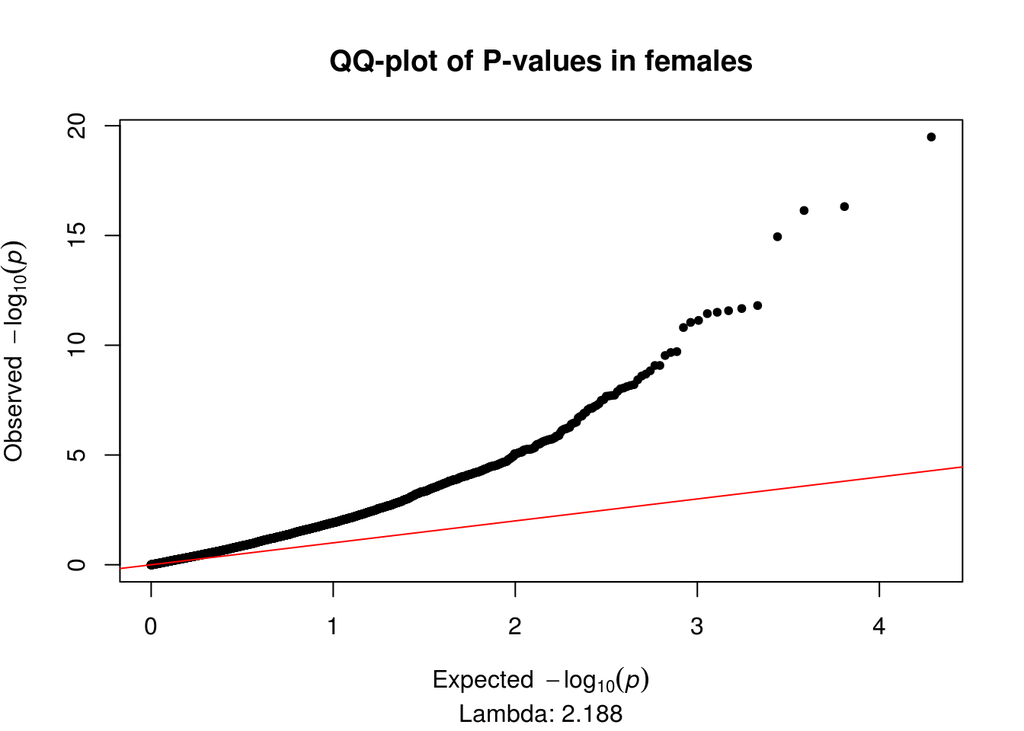

### Model 5 (5SV)

The ANOVA of diagnosis has been run with 5 SVs. Tables of the top 1000 DMPs have been produced for each variable of interest.

#### Top DMPs

**ANOVA:**  
45 probes pass the epigenome-wide significance threshold of 2.4x10-7  
*The top 50 diagnosis associated DMPs:*

| ProbeID | Position | F | p (F) | FDR.Anova | Difference | CI lower | CI upper | pCvM | FDR | Difference | CI lower | CI upper | pCvA | FDR | Difference | CI lower | CI upper | pMvA | FDR | UCSC Gene | UCSC Gene Group | UCSC Relation to CpG Island | Gene Closest TSS | Distance Closest TSS | GREAT Annotation 1 | GREAT Annotation 2 |
| --- | --- | --- | --- | --- | --- | --- | --- | --- | --- | --- | --- | --- | --- | --- | --- | --- | --- | --- | --- | --- | --- | --- | --- | --- | --- | --- |
| cg22822140 | chr X: 153046577 | 60.112 | 2.16e-20 | 2.09e-16 | 9.33e-04 | -0.021 | 0.023 | 0.994 | 1 | -0.087 | -0.109 | -0.065 | 4.83e-14 | 4.66e-10 | -0.088 | -0.11 | -0.067 | 4.90e-14 | 1.29e-10 | SRPK3;SRPK3;SRPK3 | 1stExon;1stExon;1stExon | Island | SRPK3 | 122 | SRPK3 (122) | (NA) |
| cg12230162 | chr X: 153046482 | 47.713 | 4.07e-17 | 1.81e-13 | 0.01 | -0.015 | 0.034 | 0.621 | 1 | -0.083 | -0.108 | -0.058 | 1.23e-12 | 3.04e-09 | -0.093 | -0.117 | -0.068 | 5.05e-14 | 1.29e-10 | SRPK3;SRPK3;SRPK3;SRPK3;SRPK3;SRPK3 | 5'UTR;1stExon;1stExon;5'UTR;5'UTR;1stExon | Island | SRPK3 | 27 | SRPK3 (27) | (NA) |
| cg24496423 | chr X: 153046480 | 47.202 | 5.64e-17 | 1.81e-13 | 0.006 | -0.014 | 0.025 | 0.76 | 1 | -0.066 | -0.086 | -0.047 | 7.65e-13 | 3.04e-09 | -0.072 | -0.092 | -0.053 | 5.34e-14 | 1.29e-10 | SRPK3;SRPK3;SRPK3;SRPK3;SRPK3;SRPK3 | 5'UTR;1stExon;1stExon;5'UTR;5'UTR;1stExon | Island | SRPK3 | 25 | SRPK3 (25) | (NA) |
| cg13009143 | chr X: 100548223 | 42.881 | 9.34e-16 | 2.25e-12 | -0.015 | -0.021 | -0.008 | 1.80e-06 | 6.42e-04 | 0.011 | 0.004 | 0.018 | 3.51e-04 | 0.027 | 0.026 | 0.019 | 0.033 | 4.87e-14 | 1.29e-10 | TAF7L | TSS200 | S_Shore | TAF7L | -164 | TAF7L (-165) | (NA) |
| cg16152676 | chr X: 10126878 | 32.873 | 9.17e-13 | 1.77e-09 | 0.039 | 0.025 | 0.053 | 2.64e-09 | 3.64e-06 | -0.005 | -0.019 | 0.009 | 0.677 | 1 | -0.044 | -0.058 | -0.03 | 2.03e-11 | 3.26e-08 | CLCN4 | 5'UTR | Island | CLCN4 | 550 | CLCN4 (1894) | MID1 (724930) |
| cg16529483 | chr X: 153046451 | 32.446 | 1.25e-12 | 2.00e-09 | -0.004 | -0.028 | 0.020 | 0.914 | 1 | -0.073 | -0.098 | -0.049 | 9.07e-11 | 1.46e-07 | -0.069 | -0.093 | -0.045 | 4.24e-10 | 4.54e-07 | SRPK3;SRPK3;SRPK3 | TSS200;TSS200;TSS200 | Island | SRPK3 | -4 | SRPK3 (-4) | (NA) |
| cg24605338 | chr X: 17395856 | 32.143 | 1.55e-12 | 2.14e-09 | -0.037 | -0.048 | -0.026 | 5.91e-13 | 5.70e-09 | -0.02 | -0.031 | -0.009 | 1.09e-04 | 0.012 | 0.017 | 0.006 | 0.028 | 7.39e-04 | 0.057 | NHS | Body | S_Shore | NHS | 2314 | SCML1 (-359735) | NHS (2314) |
| cg03360001 | chr X: 53453272 | 31.237 | 2.99e-12 | 3.29e-09 | -0.009 | -0.015 | -0.003 | 0.001 | 0.058 | 0.011 | 0.005 | 0.017 | 1.38e-04 | 0.014 | 0.020 | 0.014 | 0.026 | 1.11e-12 | 2.15e-09 | RIBC1;RIBC1 | Body;Body | S_Shelf | RIBC1 | 3434 | SMC1A (-3655) | (NA) |
| cg12468189 | chr X: 153046767 | 31.199 | 3.07e-12 | 3.29e-09 | -0.023 | -0.038 | -0.008 | 0.002 | 0.076 | -0.052 | -0.067 | -0.036 | 1.26e-12 | 3.04e-09 | -0.029 | -0.044 | -0.014 | 4.33e-05 | 0.008 | SRPK3;SRPK3;SRPK3 | Body;Body;Body | Island | SRPK3 | 312 | SRPK3 (312) | (NA) |
| cg19938385 | chr X: 107020894 | 29.767 | 8.77e-12 | 7.87e-09 | -0.047 | -0.065 | -0.029 | 2.09e-08 | 1.83e-05 | -0.056 | -0.074 | -0.037 | 6.72e-11 | 1.30e-07 | -0.009 | -0.027 | 0.009 | 0.474 | 1 |  |  | S_Shore | TSC22D3 | -1692 | TSC22D3 (-1878) | (NA) |
| cg09768654 | chr X: 153046386 | 29.736 | 8.98e-12 | 7.87e-09 | 0.012 | -0.01 | 0.035 | 0.403 | 1 | -0.057 | -0.080 | -0.034 | 6.61e-08 | 4.56e-05 | -0.070 | -0.092 | -0.047 | 3.85e-11 | 5.30e-08 | SRPK3;SRPK3;SRPK3 | TSS200;TSS200;TSS200 | Island | SRPK3 | -69 | SRPK3 (-69) | (NA) |
| cg19280671 | chr X: 149013642 | 28.959 | 1.60e-11 | 1.28e-08 | 0.016 | 0.01 | 0.022 | 2.12e-09 | 3.40e-06 | 7.27e-06 | -0.006 | 0.006 | 1 | 1 | -0.016 | -0.022 | -0.01 | 1.83e-09 | 1.76e-06 | MAGEA8;MAGEA8;MAGEA8 | Body;Body;Body |  | MAGEA8 | 596 | MAMLD1 (-517908) | MAGEA8 (3702) |
| cg17003204 | chr X: 102861456 | 25.867 | 1.64e-10 | 1.21e-07 | -0.03 | -0.041 | -0.020 | 1.11e-09 | 2.80e-06 | -0.005 | -0.016 | 0.006 | 0.527 | 1 | 0.025 | 0.015 | 0.036 | 2.64e-07 | 1.27e-04 | TCEAL3;TCEAL3 | TSS1500;TSS1500 | N_Shore | TCEAL3 | -1377 | TCEAL3 (-1377) | (NA) |
| cg21252909 | chr X: 30326328 | 25.644 | 1.94e-10 | 1.34e-07 | 0.037 | 0.014 | 0.060 | 5.41e-04 | 0.036 | -0.032 | -0.055 | -0.009 | 0.004 | 0.132 | -0.069 | -0.091 | -0.046 | 7.76e-11 | 9.36e-08 | NR0B1 | 1stExon | N_Shore | NR0B1 | 1167 | NR0B1 (1166) | (NA) |
| cg17405188 | chr X: 73164102 | 24.952 | 3.30e-10 | 2.12e-07 | 0.006 | 0.001 | 0.011 | 0.008 | 0.196 | 0.014 | 0.009 | 0.019 | 1.49e-10 | 2.05e-07 | 0.008 | 0.003 | 0.013 | 1.75e-04 | 0.021 | LOC554203 | TSS200 | Island | JPX | -56 | ZCCHC13 (-359922) | CHIC1 (381119) |
| cg11179997 | chr X: 119125670 | 24.581 | 4.39e-10 | 2.65e-07 | 0.028 | 0.017 | 0.039 | 3.14e-08 | 2.33e-05 | -1.95e-05 | -0.011 | 0.011 | 1 | 1 | -0.028 | -0.039 | -0.017 | 2.66e-08 | 1.71e-05 |  |  | Island | AK123976 | -44530 | NKAP (-47936) | RHOXF2 (86036) |
| cg17219209 | chr X: 149009840 | 24.202 | 5.89e-10 | 3.34e-07 | 0.022 | 0.014 | 0.030 | 1.76e-09 | 3.39e-06 | 0.005 | -0.003 | 0.013 | 0.336 | 1 | -0.017 | -0.025 | -0.009 | 1.98e-06 | 7.97e-04 | MAGEA8;MAGEA8;MAGEA8 | TSS200;TSS200;TSS200 |  | MAGEA8 | -100 | MAGEA8 (-100) | (NA) |
| cg09661041 | chr X: 153141905 | 23.013 | 1.49e-09 | 7.97e-07 | -0.005 | -0.028 | 0.018 | 0.878 | 1 | -0.06 | -0.084 | -0.037 | 2.56e-08 | 2.25e-05 | -0.055 | -0.078 | -0.032 | 1.72e-07 | 8.76e-05 | L1CAM;L1CAM;L1CAM | TSS1500;TSS1500;TSS1500 |  | L1CAM | -506 | L1CAM (-507) | (NA) |
| cg25896901 | chr X: 125300481 | 22.689 | 1.92e-09 | 9.61e-07 | 0.011 | -0.015 | 0.036 | 0.572 | 1 | -0.057 | -0.082 | -0.031 | 1.65e-06 | 6.19e-04 | -0.067 | -0.093 | -0.042 | 7.06e-09 | 6.19e-06 | DCAF12L2 | TSS1500 | S_Shore | DCAF12L2 | -401 | DCAF12L1 (386360) | (NA) |
| cg15907464 | chr X: 70712790 | 22.641 | 1.99e-09 | 9.61e-07 | -0.035 | -0.047 | -0.023 | 8.45e-10 | 2.80e-06 | -0.02 | -0.033 | -0.008 | 5.65e-04 | 0.037 | 0.015 | 0.003 | 0.027 | 0.013 | 0.33 | BCYRN1;INGX | Body;TSS200 | Island | INGX | -186 | OGT (-40121) | TAF1 (126677) |
| cg14917571 | chr X: 79269151 | 22.182 | 2.86e-09 | 1.32e-06 | -0.051 | -0.069 | -0.033 | 1.16e-09 | 2.80e-06 | -0.028 | -0.046 | -0.01 | 0.001 | 0.061 | 0.023 | 0.005 | 0.041 | 0.009 | 0.259 | TBX22;TBX22 | TSS1500;TSS1500 |  | TBX22 | -1103 | ITM2A (-646103) | TBX22 (-8590) |
| cg22926378 | chr X: 6144633 | 21.484 | 4.98e-09 | 2.18e-06 | 0.014 | 0.007 | 0.021 | 8.31e-06 | 0.002 | -0.004 | -0.011 | 0.003 | 0.392 | 1 | -0.018 | -0.025 | -0.011 | 1.23e-08 | 9.16e-06 | NLGN4X;NLGN4X | 5'UTR;5'UTR | Island | NLGN4X | 483 | NLGN4X (2072) | (NA) |
| cg07069575 | chr X: 49688313 | 21.219 | 6.15e-09 | 2.58e-06 | 0.007 | -0.005 | 0.019 | 0.324 | 1 | -0.024 | -0.036 | -0.012 | 1.43e-05 | 0.003 | -0.031 | -0.042 | -0.019 | 9.67e-09 | 7.77e-06 | CLCN5;CLCN5 | 5'UTR;5'UTR | S_Shore | CLCN5 | 1089 | CLCN5 (1089) | AKAP4 (277350) |
| cg16122592 | chr X: 26210712 | 21.001 | 7.31e-09 | 2.85e-06 | -0.03 | -0.041 | -0.018 | 1.83e-08 | 1.76e-05 | -0.024 | -0.036 | -0.013 | 5.64e-06 | 0.002 | 0.005 | -0.006 | 0.017 | 0.495 | 1 | MAGEB6 | 5'UTR |  | MAGEB6 | 156 | MAGEB6 (156) | (NA) |
| cg12039689 | chr X: 153141750 | 20.988 | 7.39e-09 | 2.85e-06 | -0.018 | -0.039 | 0.002 | 0.096 | 0.681 | -0.056 | -0.077 | -0.035 | 6.24e-09 | 6.69e-06 | -0.038 | -0.058 | -0.017 | 6.86e-05 | 0.011 | L1CAM;L1CAM;L1CAM | TSS1500;TSS1500;TSS1500 |  | L1CAM | -351 | L1CAM (-352) | (NA) |
| cg17513789 | chr X: 73073251 | 20.656 | 9.64e-09 | 3.58e-06 | -0.039 | -0.053 | -0.024 | 4.46e-09 | 5.38e-06 | -0.017 | -0.032 | -0.003 | 0.016 | 0.288 | 0.022 | 0.007 | 0.036 | 0.001 | 0.08 | XIST | TSS1500 |  | XIST | -663 | ZCCHC13 (-450773) | CHIC1 (290268) |
| cg07344627 | chr X: 125687011 | 20.491 | 1.10e-08 | 3.93e-06 | -0.033 | -0.056 | -0.010 | 0.003 | 0.106 | -0.064 | -0.087 | -0.04 | 4.50e-09 | 5.42e-06 | -0.031 | -0.054 | -0.008 | 0.006 | 0.203 | DCAF12L1 | TSS200 | S_Shore | DCAF12L1 | -169 | DCAF12L1 (-170) | (NA) |
| cg06452970 | chr X: 13835264 | 20.349 | 1.23e-08 | 4.21e-06 | 0.046 | 0.027 | 0.065 | 8.97e-08 | 5.89e-05 | 0.006 | -0.013 | 0.025 | 0.753 | 1 | -0.040 | -0.059 | -0.022 | 2.58e-06 | 9.95e-04 | GPM6B;GPM6B;GPM6B;GPM6B;GPM6B;GPM6B;GPM6B | 1stExon;5'UTR;5'UTR;Body;5'UTR;1stExon;1stExon |  | GPM6B | 50 | GPM6B (49) | (NA) |
| cg09513996 | chr X: 48685182 | 20.316 | 1.27e-08 | 4.21e-06 | 0.006 | -0.007 | 0.020 | 0.486 | 1 | -0.027 | -0.041 | -0.014 | 1.03e-05 | 0.003 | -0.034 | -0.047 | -0.021 | 2.90e-08 | 1.75e-05 |  |  | Island | ERAS | -2100 | ERAS (-2100) | (NA) |
| cg08630881 | chr X: 70713213 | 19.964 | 1.68e-08 | 5.41e-06 | -0.029 | -0.039 | -0.018 | 8.64e-09 | 9.27e-06 | -0.018 | -0.029 | -0.007 | 5.13e-04 | 0.035 | 0.011 | 1.57e-04 | 0.022 | 0.046 | 0.625 | BCYRN1;INGX | Body;TSS1500 | S_Shore | INGX | -609 | OGT (-39698) | TAF1 (127100) |
| cg04768884 | chr X: 19443172 | 19.767 | 1.97e-08 | 5.97e-06 | 0.005 | -0.009 | 0.019 | 0.638 | 1 | 0.035 | 0.020 | 0.049 | 9.20e-08 | 5.92e-05 | 0.029 | 0.015 | 0.043 | 4.21e-06 | 0.001 | MAP3K15 | Body |  | MAP3K15 | 35099 | PDHA1 (81162) | MAP3K15 (90206) |
| cg01737010 | chr X: 101772014 | 19.763 | 1.98e-08 | 5.97e-06 | 0.008 | -0.002 | 0.018 | 0.138 | 0.791 | -0.017 | -0.027 | -0.008 | 1.44e-04 | 0.014 | -0.025 | -0.035 | -0.016 | 1.53e-08 | 1.05e-05 | TMSB15A | TSS1500 | S_Shore | TMSB15A | -315 | TMSB15A (-316) | (NA) |
| cg26484667 | chr X: 2733164 | 19.344 | 2.78e-08 | 8.12e-06 | -0.027 | -0.038 | -0.015 | 2.51e-07 | 1.35e-04 | -0.003 | -0.014 | 0.009 | 0.847 | 1 | 0.024 | 0.013 | 0.035 | 3.07e-06 | 0.001 | XG;XG;XG | 3'UTR;3'UTR;3'UTR |  | GYG2 | -13698 | GYG2 (-13698) | XG (63072) |
| ch.X.153018199F | chr X: 153365005 | 19.065 | 3.49e-08 | 9.89e-06 | -0.011 | -0.016 | -0.007 | 2.77e-08 | 2.23e-05 | -0.004 | -0.008 | 6.33e-04 | 0.109 | 0.741 | 0.007 | 0.003 | 0.012 | 2.62e-04 | 0.027 |  |  | S_Shore | MECP2 | -1817 | MECP2 (-1818) | (NA) |
| cg04710661 | chr X: 2848381 | 18.813 | 4.28e-08 | 1.15e-05 | 0.007 | 3.33e-06 | 0.014 | 0.05 | 0.51 | 0.018 | 0.011 | 0.024 | 2.45e-08 | 2.25e-05 | 0.011 | 0.004 | 0.018 | 5.83e-04 | 0.049 | ARSD;ARSD | TSS1500;TSS1500 | S_Shore | ARSD | -965 | ARSD (-966) | (NA) |
| cg00072799 | chr X: 78427682 | 18.807 | 4.30e-08 | 1.15e-05 | -0.007 | -0.021 | 0.007 | 0.477 | 1 | -0.034 | -0.048 | -0.02 | 1.12e-07 | 6.77e-05 | -0.027 | -0.041 | -0.014 | 1.59e-05 | 0.003 | GPR174;GPR174 | 1stExon;3'UTR |  | GPR174 | 1214 | GPR174 (1214) | ITM2A (195366) |
| cg21364342 | chr X: 107226611 | 18.224 | 6.93e-08 | 1.81e-05 | -0.019 | -0.027 | -0.010 | 5.77e-06 | 0.002 | -0.021 | -0.030 | -0.012 | 3.96e-07 | 2.12e-04 | -0.002 | -0.011 | 0.006 | 0.792 | 1 | TEX13B | TSS1500 |  | TEX13B | -1011 | VSIG1 (-61588) | MID2 (157528) |
| cg22574818 | chr X: 55479616 | 18.027 | 8.15e-08 | 2.07e-05 | -0.031 | -0.054 | -0.008 | 0.004 | 0.14 | -0.059 | -0.082 | -0.036 | 3.53e-08 | 2.84e-05 | -0.028 | -0.051 | -0.005 | 0.013 | 0.324 | MAGEH1;MAGEH1 | 1stExon;3'UTR |  | MAGEH1 | 1079 | MAGEH1 (1079) | USP51 (36014) |
| cg08464958 | chr X: 2852845 | 17.989 | 8.41e-08 | 2.08e-05 | -0.022 | -0.031 | -0.013 | 3.38e-07 | 1.72e-04 | -0.003 | -0.013 | 0.006 | 0.662 | 1 | 0.018 | 0.009 | 0.028 | 1.69e-05 | 0.004 | ARSE | 3'UTR |  | ARSD | -5429 | ARSD (-5430) | ARSE (29648) |
| cg00190642 | chr X: 103268431 | 17.539 | 1.22e-07 | 2.94e-05 | -0.012 | -0.027 | 0.003 | 0.136 | 0.785 | 0.025 | 0.009 | 0.04 | 5.19e-04 | 0.035 | 0.037 | 0.022 | 0.052 | 8.31e-08 | 4.72e-05 | H2BFWT;MIR1256 | TSS200;Body | Island | H2BFWT | -175 | H2BFWT (-176) | (NA) |
| cg00805156 | chr X: 3264341 | 17.487 | 1.27e-07 | 2.99e-05 | 0.034 | 0.017 | 0.051 | 9.27e-06 | 0.002 | 0.039 | 0.022 | 0.055 | 6.64e-07 | 3.20e-04 | 0.005 | -0.012 | 0.021 | 0.793 | 1 | MXRA5 | 5'UTR | Island | MXRA5 | 343 | MXRA5 (342) | (NA) |
| cg23914849 | chr X: 52950051 | 17.393 | 1.38e-07 | 3.16e-05 | 0.003 | 5.73e-04 | 0.005 | 0.009 | 0.208 | 0.006 | 0.003 | 0.008 | 5.96e-08 | 4.42e-05 | 0.003 | 5.96e-04 | 0.005 | 0.009 | 0.258 |  |  | Island | FAM156A | 13799 | FAM156B (21967) | FAM156A (74599) |
| cg00632130 | chr X: 47931806 | 17.180 | 1.64e-07 | 3.68e-05 | -0.009 | -0.022 | 0.004 | 0.214 | 0.947 | 0.022 | 0.009 | 0.035 | 3.19e-04 | 0.025 | 0.031 | 0.018 | 0.044 | 1.39e-07 | 7.44e-05 | ZNF630 | TSS1500 | S_Shore | ZNF630 | -781 | ZNF630 (-1299) | (NA) |
| cg24834461 | chr X: 153637645 | 16.997 | 1.91e-07 | 4.19e-05 | 0.017 | 0.01 | 0.024 | 9.59e-08 | 5.89e-05 | 0.01 | 0.003 | 0.017 | 0.002 | 0.091 | -0.007 | -0.013 | 1.49e-04 | 0.057 | 0.694 | DNASE1L1;DNASE1L1;DNASE1L1;DNASE1L1 | TSS200;5'UTR;5'UTR;5'UTR | N_Shelf | DNASE1L1 | -70 | TAZ (-2231) | (NA) |
| cg09953945 | chr X: 150345040 | 16.933 | 2.01e-07 | 4.32e-05 | -0.025 | -0.035 | -0.015 | 9.78e-08 | 5.89e-05 | -0.015 | -0.025 | -0.004 | 0.003 | 0.106 | 0.010 | 6.15e-05 | 0.02 | 0.048 | 0.643 | GPR50 | TSS200 | N_Shore | GPR50 | -15 | GPR50 (-15) | (NA) |
| cg04817724 | chr X: 103809991 | 16.684 | 2.48e-07 | 5.18e-05 | 0.049 | 0.029 | 0.069 | 1.09e-07 | 6.21e-05 | 0.025 | 0.004 | 0.045 | 0.013 | 0.259 | -0.024 | -0.044 | -0.004 | 0.012 | 0.323 | IL1RAPL2 | TSS1500 | Island | IL1RAPL2 | -1004 | IL1RAPL2 (-1004) | (NA) |
| cg24352688 | chr X: 13751727 | 16.663 | 2.52e-07 | 5.18e-05 | 0.002 | -0.005 | 0.009 | 0.832 | 1 | 0.015 | 0.008 | 0.022 | 1.48e-06 | 5.94e-04 | 0.014 | 0.007 | 0.021 | 1.33e-05 | 0.003 | TRAPPC2;OFD1;TRAPPC2;TRAPPC2 | 5'UTR;TSS1500;5'UTR;5'UTR | N_Shore | TRAPPC2 | 1027 | OFD1 (-1104) | TRAPPC2 (1026) |
| cg25433595 | chr X: 100183764 | 16.459 | 2.99e-07 | 6.01e-05 | 0.043 | 0.025 | 0.062 | 3.64e-07 | 1.75e-04 | 0.033 | 0.014 | 0.052 | 1.61e-04 | 0.015 | -0.011 | -0.029 | 0.008 | 0.374 | 1 | XKRX;XKRX | 5'UTR;1stExon | N_Shore | XKRX | 134 | XKRX (133) | (NA) |
| cg00779763 | chr X: 47479114 | 16.395 | 3.15e-07 | 6.21e-05 | 0.009 | -9.50e-04 | 0.019 | 0.085 | 0.653 | 0.024 | 0.014 | 0.034 | 1.94e-07 | 1.10e-04 | 0.015 | 0.005 | 0.025 | 0.001 | 0.079 | SYN1;SYN1 | 1stExon;1stExon | Island | SYN1 | 142 | SYN1 (141) | (NA) |
| cg25549901 | chr X: 137951118 | 16.261 | 3.53e-07 | 6.81e-05 | -0.021 | -0.031 | -0.012 | 1.16e-06 | 4.68e-04 | -0.019 | -0.028 | -0.009 | 3.14e-05 | 0.006 | 0.003 | -0.007 | 0.012 | 0.772 | 1 | FGF13;FGF13;FGF13;FGF13 | 5'UTR;Body;TSS1500;Body |  | FGF13 | -1401 | FGF13 (336066) | (NA) |

**CTL vs MCI:**  
17 probes pass the epigenome-wide significance threshold of 2.4x10-7

*The top 50 CTL vs MCI associated DMPs:*

| ProbeID | Position | F | p (F) | FDR.Anova | Difference | CI lower | CI upper | pCvM | FDR | Difference | CI lower | CI upper | pCvA | FDR | Difference | CI lower | CI upper | pMvA | FDR | UCSC Gene | UCSC Gene Group | UCSC Relation to CpG Island | Gene Closest TSS | Distance Closest TSS | GREAT Annotation 1 | GREAT Annotation 2 |
| --- | --- | --- | --- | --- | --- | --- | --- | --- | --- | --- | --- | --- | --- | --- | --- | --- | --- | --- | --- | --- | --- | --- | --- | --- | --- | --- |
| cg24605338 | chr X: 17395856 | 32.143 | 1.55e-12 | 2.14e-09 | -0.037 | -0.048 | -0.026 | 5.91e-13 | 5.70e-09 | -0.02 | -0.031 | -0.009 | 1.09e-04 | 0.012 | 0.017 | 0.006 | 0.028 | 7.39e-04 | 0.057 | NHS | Body | S_Shore | NHS | 2314 | SCML1 (-359735) | NHS (2314) |
| cg15907464 | chr X: 70712790 | 22.641 | 1.99e-09 | 9.61e-07 | -0.035 | -0.047 | -0.023 | 8.45e-10 | 2.80e-06 | -0.02 | -0.033 | -0.008 | 5.65e-04 | 0.037 | 0.015 | 0.003 | 0.027 | 0.013 | 0.33 | BCYRN1;INGX | Body;TSS200 | Island | INGX | -186 | OGT (-40121) | TAF1 (126677) |
| cg17003204 | chr X: 102861456 | 25.867 | 1.64e-10 | 1.21e-07 | -0.030 | -0.041 | -0.020 | 1.11e-09 | 2.80e-06 | -0.005 | -0.016 | 0.006 | 0.527 | 1 | 0.025 | 0.015 | 0.036 | 2.64e-07 | 1.27e-04 | TCEAL3;TCEAL3 | TSS1500;TSS1500 | N_Shore | TCEAL3 | -1377 | TCEAL3 (-1377) | (NA) |
| cg14917571 | chr X: 79269151 | 22.182 | 2.86e-09 | 1.32e-06 | -0.051 | -0.069 | -0.033 | 1.16e-09 | 2.80e-06 | -0.028 | -0.046 | -0.01 | 0.001 | 0.061 | 0.023 | 0.005 | 0.041 | 0.009 | 0.259 | TBX22;TBX22 | TSS1500;TSS1500 |  | TBX22 | -1103 | ITM2A (-646103) | TBX22 (-8590) |
| cg17219209 | chr X: 149009840 | 24.202 | 5.89e-10 | 3.34e-07 | 0.022 | 0.014 | 0.030 | 1.76e-09 | 3.39e-06 | 0.005 | -0.003 | 0.013 | 0.336 | 1 | -0.017 | -0.025 | -0.009 | 1.98e-06 | 7.97e-04 | MAGEA8;MAGEA8;MAGEA8 | TSS200;TSS200;TSS200 |  | MAGEA8 | -100 | MAGEA8 (-100) | (NA) |
| cg19280671 | chr X: 149013642 | 28.959 | 1.60e-11 | 1.28e-08 | 0.016 | 0.010 | 0.022 | 2.12e-09 | 3.40e-06 | 7.27e-06 | -0.006 | 0.006 | 1 | 1 | -0.016 | -0.022 | -0.01 | 1.83e-09 | 1.76e-06 | MAGEA8;MAGEA8;MAGEA8 | Body;Body;Body |  | MAGEA8 | 596 | MAMLD1 (-517908) | MAGEA8 (3702) |
| cg16152676 | chr X: 10126878 | 32.873 | 9.17e-13 | 1.77e-09 | 0.039 | 0.025 | 0.053 | 2.64e-09 | 3.64e-06 | -0.005 | -0.019 | 0.009 | 0.677 | 1 | -0.044 | -0.058 | -0.03 | 2.03e-11 | 3.26e-08 | CLCN4 | 5'UTR | Island | CLCN4 | 550 | CLCN4 (1894) | MID1 (724930) |
| cg17513789 | chr X: 73073251 | 20.656 | 9.64e-09 | 3.58e-06 | -0.039 | -0.053 | -0.024 | 4.46e-09 | 5.38e-06 | -0.017 | -0.032 | -0.003 | 0.016 | 0.288 | 0.022 | 0.007 | 0.036 | 0.001 | 0.08 | XIST | TSS1500 |  | XIST | -663 | ZCCHC13 (-450773) | CHIC1 (290268) |
| cg08630881 | chr X: 70713213 | 19.964 | 1.68e-08 | 5.41e-06 | -0.029 | -0.039 | -0.018 | 8.64e-09 | 9.27e-06 | -0.018 | -0.029 | -0.007 | 5.13e-04 | 0.035 | 0.011 | 1.57e-04 | 0.022 | 0.046 | 0.625 | BCYRN1;INGX | Body;TSS1500 | S_Shore | INGX | -609 | OGT (-39698) | TAF1 (127100) |
| cg16122592 | chr X: 26210712 | 21.001 | 7.31e-09 | 2.85e-06 | -0.030 | -0.041 | -0.018 | 1.83e-08 | 1.76e-05 | -0.024 | -0.036 | -0.013 | 5.64e-06 | 0.002 | 0.005 | -0.006 | 0.017 | 0.495 | 1 | MAGEB6 | 5'UTR |  | MAGEB6 | 156 | MAGEB6 (156) | (NA) |
| cg19938385 | chr X: 107020894 | 29.767 | 8.77e-12 | 7.87e-09 | -0.047 | -0.065 | -0.029 | 2.09e-08 | 1.83e-05 | -0.056 | -0.074 | -0.037 | 6.72e-11 | 1.30e-07 | -0.009 | -0.027 | 0.009 | 0.474 | 1 |  |  | S_Shore | TSC22D3 | -1692 | TSC22D3 (-1878) | (NA) |
| ch.X.153018199F | chr X: 153365005 | 19.065 | 3.49e-08 | 9.89e-06 | -0.011 | -0.016 | -0.007 | 2.77e-08 | 2.23e-05 | -0.004 | -0.008 | 6.33e-04 | 0.109 | 0.741 | 0.007 | 0.003 | 0.012 | 2.62e-04 | 0.027 |  |  | S_Shore | MECP2 | -1817 | MECP2 (-1818) | (NA) |
| cg11179997 | chr X: 119125670 | 24.581 | 4.39e-10 | 2.65e-07 | 0.028 | 0.017 | 0.039 | 3.14e-08 | 2.33e-05 | -1.95e-05 | -0.011 | 0.011 | 1 | 1 | -0.028 | -0.039 | -0.017 | 2.66e-08 | 1.71e-05 |  |  | Island | AK123976 | -44530 | NKAP (-47936) | RHOXF2 (86036) |
| cg06452970 | chr X: 13835264 | 20.349 | 1.23e-08 | 4.21e-06 | 0.046 | 0.027 | 0.065 | 8.97e-08 | 5.89e-05 | 0.006 | -0.013 | 0.025 | 0.753 | 1 | -0.04 | -0.059 | -0.022 | 2.58e-06 | 9.95e-04 | GPM6B;GPM6B;GPM6B;GPM6B;GPM6B;GPM6B;GPM6B | 1stExon;5'UTR;5'UTR;Body;5'UTR;1stExon;1stExon |  | GPM6B | 50 | GPM6B (49) | (NA) |
| cg24834461 | chr X: 153637645 | 16.997 | 1.91e-07 | 4.19e-05 | 0.017 | 0.010 | 0.024 | 9.59e-08 | 5.89e-05 | 0.01 | 0.003 | 0.017 | 0.002 | 0.091 | -0.007 | -0.013 | 1.49e-04 | 0.057 | 0.694 | DNASE1L1;DNASE1L1;DNASE1L1;DNASE1L1 | TSS200;5'UTR;5'UTR;5'UTR | N_Shelf | DNASE1L1 | -70 | TAZ (-2231) | (NA) |
| cg09953945 | chr X: 150345040 | 16.933 | 2.01e-07 | 4.32e-05 | -0.025 | -0.035 | -0.015 | 9.78e-08 | 5.89e-05 | -0.015 | -0.025 | -0.004 | 0.003 | 0.106 | 0.01 | 6.15e-05 | 0.02 | 0.048 | 0.643 | GPR50 | TSS200 | N_Shore | GPR50 | -15 | GPR50 (-15) | (NA) |
| cg04817724 | chr X: 103809991 | 16.684 | 2.48e-07 | 5.18e-05 | 0.049 | 0.029 | 0.069 | 1.09e-07 | 6.21e-05 | 0.025 | 0.004 | 0.045 | 0.013 | 0.259 | -0.024 | -0.044 | -0.004 | 0.012 | 0.323 | IL1RAPL2 | TSS1500 | Island | IL1RAPL2 | -1004 | IL1RAPL2 (-1004) | (NA) |
| cg26484667 | chr X: 2733164 | 19.344 | 2.78e-08 | 8.12e-06 | -0.027 | -0.038 | -0.015 | 2.51e-07 | 1.35e-04 | -0.003 | -0.014 | 0.009 | 0.847 | 1 | 0.024 | 0.013 | 0.035 | 3.07e-06 | 0.001 | XG;XG;XG | 3'UTR;3'UTR;3'UTR |  | GYG2 | -13698 | GYG2 (-13698) | XG (63072) |
| cg08464958 | chr X: 2852845 | 17.989 | 8.41e-08 | 2.08e-05 | -0.022 | -0.031 | -0.013 | 3.38e-07 | 1.72e-04 | -0.003 | -0.013 | 0.006 | 0.662 | 1 | 0.018 | 0.009 | 0.028 | 1.69e-05 | 0.004 | ARSE | 3'UTR |  | ARSD | -5429 | ARSD (-5430) | ARSE (29648) |
| cg25433595 | chr X: 100183764 | 16.459 | 2.99e-07 | 6.01e-05 | 0.043 | 0.025 | 0.062 | 3.64e-07 | 1.75e-04 | 0.033 | 0.014 | 0.052 | 1.61e-04 | 0.015 | -0.011 | -0.029 | 0.008 | 0.374 | 1 | XKRX;XKRX | 5'UTR;1stExon | N_Shore | XKRX | 134 | XKRX (133) | (NA) |
| cg25177692 | chr X: 129193893 | 15.791 | 5.23e-07 | 9.52e-05 | -0.026 | -0.037 | -0.014 | 5.40e-07 | 2.48e-04 | -0.019 | -0.030 | -0.008 | 3.11e-04 | 0.025 | 0.007 | -0.004 | 0.018 | 0.327 | 1 |  |  | N_Shore | BCORL1 | 34929 | ELF4 (50794) | BCORL1 (54730) |
| cg17970282 | chr X: 70712810 | 14.654 | 1.37e-06 | 2.10e-04 | -0.033 | -0.048 | -0.019 | 6.59e-07 | 2.89e-04 | -0.016 | -0.030 | -8.65e-04 | 0.035 | 0.436 | 0.018 | 0.003 | 0.032 | 0.012 | 0.323 | BCYRN1;INGX | Body;TSS1500 | Island | INGX | -206 | OGT (-40101) | TAF1 (126697) |
| cg08867267 | chr X: 130033963 | 14.037 | 2.32e-06 | 3.24e-04 | -0.022 | -0.032 | -0.012 | 1.16e-06 | 4.68e-04 | -0.013 | -0.023 | -0.003 | 0.008 | 0.2 | 0.009 | -5.49e-04 | 0.019 | 0.069 | 0.747 | ENOX2;ENOX2 | 5'UTR;5'UTR | N_Shelf | ENOX2 | 3245 | ENOX2 (3244) | RBMX2 (498021) |
| cg25549901 | chr X: 137951118 | 16.261 | 3.53e-07 | 6.81e-05 | -0.021 | -0.031 | -0.012 | 1.16e-06 | 4.68e-04 | -0.019 | -0.028 | -0.009 | 3.14e-05 | 0.006 | 0.003 | -0.007 | 0.012 | 0.772 | 1 | FGF13;FGF13;FGF13;FGF13 | 5'UTR;Body;TSS1500;Body |  | FGF13 | -1401 | FGF13 (336066) | (NA) |
| cg14306994 | chr X: 49019804 | 13.985 | 2.42e-06 | 3.29e-04 | 0.030 | 0.016 | 0.043 | 1.46e-06 | 5.64e-04 | 0.012 | -0.002 | 0.025 | 0.107 | 0.734 | -0.018 | -0.031 | -0.005 | 0.005 | 0.184 | MAGIX;MAGIX;MAGIX;MAGIX | Body;Body;Body;TSS1500 | Island | MAGIX | -316 | GPKOW (-39726) | PLP2 (-8379) |
| cg11315455 | chr X: 122997585 | 15.246 | 8.29e-07 | 1.38e-04 | -0.026 | -0.038 | -0.014 | 1.60e-06 | 5.95e-04 | -0.006 | -0.018 | 0.006 | 0.512 | 1 | 0.021 | 0.009 | 0.033 | 1.79e-04 | 0.021 | XIAP | 5'UTR | S_Shelf | XIAP | 3569 | STAG2 (-96889) | XIAP (3569) |
| cg13009143 | chr X: 100548223 | 42.881 | 9.34e-16 | 2.25e-12 | -0.015 | -0.021 | -0.008 | 1.80e-06 | 6.42e-04 | 0.011 | 0.004 | 0.018 | 3.51e-04 | 0.027 | 0.026 | 0.019 | 0.033 | 4.87e-14 | 1.29e-10 | TAF7L | TSS200 | S_Shore | TAF7L | -164 | TAF7L (-165) | (NA) |
| cg27558057 | chr X: 70712724 | 13.382 | 4.07e-06 | 4.89e-04 | -0.029 | -0.042 | -0.016 | 2.23e-06 | 7.67e-04 | -0.012 | -0.026 | 0.001 | 0.082 | 0.643 | 0.017 | 0.003 | 0.03 | 0.009 | 0.27 | BCYRN1;INGX | Body;TSS200 | Island | INGX | -120 | OGT (-40187) | TAF1 (126611) |
| cg12461113 | chr X: 13587550 | 13.134 | 5.04e-06 | 5.59e-04 | -0.074 | -0.108 | -0.040 | 2.68e-06 | 8.91e-04 | -0.032 | -0.067 | 0.002 | 0.073 | 0.608 | 0.041 | 0.007 | 0.075 | 0.012 | 0.323 | EGFL6;EGFL6 | TSS200;TSS200 | N_Shore | EGFL6 | -143 | EGFL6 (-143) | (NA) |
| cg01325935 | chr X: 67905522 | 13.215 | 4.70e-06 | 5.40e-04 | -0.016 | -0.024 | -0.009 | 3.03e-06 | 9.76e-04 | -0.006 | -0.014 | 0.002 | 0.143 | 0.837 | 0.01 | 0.003 | 0.018 | 0.005 | 0.191 | STARD8;STARD8 | 5'UTR;Body | N_Shore | STARD8 | -7959 | EFNB1 (-143317) | STARD8 (38012) |
| cg25396787 | chr X: 3733991 | 12.866 | 6.36e-06 | 6.52e-04 | 0.027 | 0.014 | 0.039 | 3.32e-06 | 0.001 | 0.016 | 0.003 | 0.028 | 0.011 | 0.238 | -0.011 | -0.024 | 0.001 | 0.092 | 0.87 |  |  | Island | TRNA_Ile | 22500 | PRKX (-102317) | (NA) |
| cg18497064 | chr X: 134715899 | 12.875 | 6.30e-06 | 6.52e-04 | -0.038 | -0.056 | -0.020 | 3.89e-06 | 0.001 | -0.015 | -0.033 | 0.003 | 0.131 | 0.801 | 0.023 | 0.005 | 0.041 | 0.007 | 0.232 | DDX26B | 3'UTR |  | DDX26B | 12638 | ZNF449 (237204) | MMGT1 (340234) |
| cg05547600 | chr X: 134847106 | 13.056 | 5.39e-06 | 5.91e-04 | -0.031 | -0.046 | -0.016 | 4.05e-06 | 0.001 | -0.011 | -0.026 | 0.004 | 0.205 | 0.963 | 0.02 | 0.006 | 0.035 | 0.003 | 0.148 | CT45A1 | TSS200 |  | CT45A1 | -78 | MMGT1 (209027) | ZNF449 (368411) |
| cg25958561 | chr X: 110187179 | 13.379 | 4.08e-06 | 4.89e-04 | 0.030 | 0.016 | 0.044 | 4.44e-06 | 0.001 | 0.022 | 0.008 | 0.036 | 8.05e-04 | 0.047 | -0.007 | -0.021 | 0.007 | 0.434 | 1 | PAK3;PAK3 | TSS1500;TSS1500 |  | PAK3 | -333 | PAK3 (-179125) | CHRDL1 (-148104) |
| cg10841064 | chr X: 22292462 | 12.417 | 9.39e-06 | 8.97e-04 | -0.031 | -0.046 | -0.016 | 5.16e-06 | 0.001 | -0.013 | -0.028 | 0.002 | 0.091 | 0.673 | 0.018 | 0.003 | 0.032 | 0.014 | 0.346 | ZNF645;ZNF645 | 3'UTR;1stExon |  | ZNF645 | 1433 | DDX53 (-725615) | ZNF645 (1433) |
| cg21364342 | chr X: 107226611 | 18.224 | 6.93e-08 | 1.81e-05 | -0.019 | -0.027 | -0.010 | 5.77e-06 | 0.002 | -0.021 | -0.030 | -0.012 | 3.96e-07 | 2.12e-04 | -0.002 | -0.011 | 0.006 | 0.792 | 1 | TEX13B | TSS1500 |  | TEX13B | -1011 | VSIG1 (-61588) | MID2 (157528) |
| cg26468081 | chr X: 69501565 | 12.992 | 5.70e-06 | 6.11e-04 | -0.013 | -0.020 | -0.007 | 6.69e-06 | 0.002 | -0.004 | -0.010 | 0.003 | 0.398 | 1 | 0.01 | 0.003 | 0.016 | 0.001 | 0.08 | ARR3;RAB41 | Body;TSS1500 |  | RAB41 | -456 | RAB41 (-456) | (NA) |
| cg09979033 | chr X: 16726904 | 12.884 | 6.26e-06 | 6.52e-04 | -0.016 | -0.023 | -0.008 | 7.23e-06 | 0.002 | -0.012 | -0.020 | -0.004 | 8.90e-04 | 0.051 | 0.004 | -0.004 | 0.011 | 0.482 | 1 | CTPS2;CTPS2;CTPS2 | 5'UTR;5'UTR;5'UTR | N_Shelf | CTPS2 | 3436 | CTPS2 (4154) | S100G (58624) |
| cg17397814 | chr X: 100670855 | 11.950 | 1.41e-05 | 0.001 | 0.043 | 0.022 | 0.064 | 7.88e-06 | 0.002 | 0.026 | 0.005 | 0.047 | 0.011 | 0.245 | -0.017 | -0.038 | 0.004 | 0.135 | 0.989 |  |  | N_Shelf | ARMCX4 | -2410 | ARMCX1 (-134658) | HNRNPH2 (7735) |
| cg22926378 | chr X: 6144633 | 21.484 | 4.98e-09 | 2.18e-06 | 0.014 | 0.007 | 0.021 | 8.31e-06 | 0.002 | -0.004 | -0.011 | 0.003 | 0.392 | 1 | -0.018 | -0.025 | -0.011 | 1.23e-08 | 9.16e-06 | NLGN4X;NLGN4X | 5'UTR;5'UTR | Island | NLGN4X | 483 | NLGN4X (2072) | (NA) |
| cg00123001 | chr X: 13395880 | 15.726 | 5.53e-07 | 9.88e-05 | -0.015 | -0.022 | -0.008 | 8.64e-06 | 0.002 | -0.015 | -0.023 | -0.008 | 6.54e-06 | 0.002 | -3.92e-04 | -0.008 | 0.007 | 0.991 | 1 |  |  | N_Shore | LOC100133123 | 42521 | EGFL6 (-191813) | ATXN3L (-57363) |
| cg00805156 | chr X: 3264341 | 17.487 | 1.27e-07 | 2.99e-05 | 0.034 | 0.017 | 0.051 | 9.27e-06 | 0.002 | 0.039 | 0.022 | 0.055 | 6.64e-07 | 3.20e-04 | 0.005 | -0.012 | 0.021 | 0.793 | 1 | MXRA5 | 5'UTR | Island | MXRA5 | 343 | MXRA5 (342) | (NA) |
| cg05860920 | chr X: 11679501 | 11.840 | 1.55e-05 | 0.001 | 0.052 | 0.026 | 0.077 | 1.04e-05 | 0.002 | 0.034 | 0.008 | 0.06 | 0.006 | 0.166 | -0.017 | -0.043 | 0.008 | 0.238 | 1 | ARHGAP6;ARHGAP6 | Body;Body | N_Shelf | ARHGAP6 | 4320 | ARHGAP6 (4319) | AMELX (367969) |
| cg20881335 | chr X: 14547172 | 11.950 | 1.41e-05 | 0.001 | 0.061 | 0.031 | 0.091 | 1.06e-05 | 0.002 | 0.021 | -0.009 | 0.051 | 0.235 | 1 | -0.04 | -0.069 | -0.01 | 0.005 | 0.194 | GLRA2;GLRA2;GLRA2 | TSS1500;TSS1500;TSS1500 |  | GLRA2 | -247 | GLRA2 (-247) | (NA) |
| cg16508637 | chr X: 132094977 | 13.146 | 4.99e-06 | 5.59e-04 | 0.023 | 0.011 | 0.034 | 1.10e-05 | 0.002 | 0.004 | -0.007 | 0.015 | 0.662 | 1 | -0.018 | -0.03 | -0.007 | 3.68e-04 | 0.034 | HS6ST2;HS6ST2 | 5'UTR;5'UTR | S_Shelf | HS6ST2 | 446 | HS6ST2 (445) | (NA) |
| cg05889382 | chr X: 70887722 | 13.699 | 3.10e-06 | 4.04e-04 | -0.018 | -0.027 | -0.009 | 1.22e-05 | 0.002 | -0.016 | -0.026 | -0.007 | 8.62e-05 | 0.011 | 0.002 | -0.007 | 0.01 | 0.911 | 1 | BCYRN1 | Body | Island | LOC100132741 | -29323 | PIN4 (-513803) | CXCR3 (-49356) |
| cg03800724 | chr X: 53253348 | 12.342 | 1.00e-05 | 9.48e-04 | 0.022 | 0.011 | 0.034 | 1.23e-05 | 0.002 | 0.017 | 0.006 | 0.029 | 0.001 | 0.056 | -0.005 | -0.016 | 0.006 | 0.533 | 1 | KDM5C;KDM5C | Body;Body | N_Shore | KDM5C | 1256 | KDM5C (1255) | TSPYL2 (141807) |
| cg07089438 | chr X: 133988190 | 11.336 | 2.42e-05 | 0.002 | -0.021 | -0.031 | -0.010 | 1.24e-05 | 0.002 | -0.011 | -0.022 | -7.45e-04 | 0.032 | 0.422 | 0.01 | -6.97e-04 | 0.02 | 0.074 | 0.772 | FAM122C;FAM122C | 3'UTR;Body |  | MOSPD1 | 45374 | PLAC1 (-195678) | MOSPD1 (61106) |
| cg13613450 | chr X: 136657310 | 11.259 | 2.59e-05 | 0.002 | 0.035 | 0.018 | 0.053 | 1.50e-05 | 0.003 | 0.022 | 0.004 | 0.04 | 0.013 | 0.26 | -0.014 | -0.031 | 0.004 | 0.165 | 1 |  |  | S_Shore | ZIC3 | 8965 | ZIC3 (8965) | (NA) |
| cg07892139 | chr X: 84192519 | 13.737 | 3.00e-06 | 4.02e-04 | -0.035 | -0.052 | -0.017 | 1.56e-05 | 0.003 | -0.033 | -0.051 | -0.015 | 6.00e-05 | 0.009 | 0.002 | -0.015 | 0.019 | 0.962 | 1 |  |  | S_Shelf | UBE2DNL | 3363 | APOOL (-66378) | UBE2DNL (3363) |